# **Stage 04 — Operational Target Investigation**

## 3.9. Observaciones e interpretación

El análisis del target `DIR` permite extraer varias conclusiones preliminares sobre su comportamiento estadístico y operativo.

En primer lugar, la construcción del target resultó consistente. Las clases generadas son válidas, la cantidad de observaciones inválidas aumenta correctamente con el horizonte y no se observaron señales de cruce entre trading days. Esto confirma que `DIR` fue construido respetando la lógica temporal definida para el proyecto.

Desde el punto de vista de distribución global de clases, `DIR` presenta un comportamiento razonable. Las señales `LONG` y `SHORT` se mantienen bastante balanceadas, con una leve inclinación hacia `SHORT`, especialmente en percentiles más altos. La clase `NO_SIGNAL` aumenta de forma progresiva a medida que el threshold se vuelve más exigente.

La frecuencia operativa está controlada principalmente por el percentil seleccionado. Las variantes `p40` generan la mayor cantidad de señales, con una frecuencia operativa cercana al 64%. Las variantes `p50` quedan en un punto intermedio, alrededor del 54%. Las variantes `p60` son más restrictivas, con una frecuencia cercana al 44%.

Esto sugiere la siguiente lectura:

```
    p40 → variante más activa, pero potencialmente más ruidosa
    p50 → variante intermedia y más equilibrada
    p60 → variante más selectiva, pero con menor frecuencia operativa
```

El horizonte temporal, en cambio, no modifica demasiado la frecuencia operativa global. Para un mismo percentil, los horizontes `H30`, `H60` y `H90` presentan distribuciones muy similares. Esto indica que los thresholds por horizonte están calibrados de forma consistente.

Sin embargo, el análisis de estabilidad temporal muestra una conclusión importante: `DIR` no es completamente estable a lo largo del tiempo. La frecuencia operativa cambia de forma significativa entre años. Períodos como `2022`, `2025` y `2026` presentan una frecuencia de señales mucho mayor que años más tranquilos como `2021`. Esto indica que el target es sensible al contexto temporal del mercado.

La comparación entre `development_2020_2024` y `final_test_2025_2026` también muestra un aumento claro de la frecuencia operativa fuera de muestra. Por lo tanto, el período final debe interpretarse como un escenario de validación exigente o de estrés, no como un período para recalibrar el target.

El análisis por régimen intradiario muestra que `DIR` se comporta de manera bastante consistente entre `Overnight`, `Pre-market`, `Opening` y `Regular`. No aparece un régimen claramente dominante ni completamente desbalanceado. Sin embargo, `Closing` debe tratarse con cuidado, ya que para horizontes `H60` y `H90` no cuenta con suficiente ventana futura dentro del mismo trading day.

El análisis por contrato y contexto confirma que las diferencias más fuertes no parecen depender exclusivamente de la familia del contrato `H`, `M`, `U` o `Z`, sino del período histórico en el que se ubica cada contrato. Contratos correspondientes a años más activos presentan frecuencias operativas más altas, lo que refuerza la idea de que el contexto temporal del mercado es una variable importante para etapas posteriores.

En función de estos resultados, las variantes más razonables para pasar a la siguiente etapa son:

```
    dir_p50_h30
    dir_p50_h60
    dir_p50_h90
```

Estas variantes mantienen una frecuencia operativa intermedia, un balance razonable entre `LONG` y `SHORT`, y una interpretación operativa clara.

Adicionalmente, conviene conservar como variantes comparativas:

```
    dir_p40_h30, dir_p40_h60, dir_p40_h90 → alternativas más activas
    dir_p60_h30, dir_p60_h60, dir_p60_h90 → alternativas más selectivas
```

La selección definitiva todavía no debe realizarse en este punto. `DIR` debe ser comparado posteriormente con `BAR` y `OPC`, ya que estos targets incorporan una lógica operativa más cercana a una operación real mediante barreras de Take Profit y Stop Loss.

En síntesis, `DIR` es un target bien construido, interpretable y estadísticamente razonable. Sus principales fortalezas son el buen balance direccional y la facilidad de interpretación. Su principal debilidad es la sensibilidad temporal de la frecuencia operativa, lo que indica que futuras etapas deberán incorporar features capaces de describir el contexto de mercado en el instante `t`, como volatilidad reciente, rango intradiario, volumen, momentum y variables de sesión.

# **4. BAR - Resultado operativo por barreras TP/SL**

En esta sección se construirá, validará y analizará el target `BAR`, cuyo objetivo es evaluar el resultado operativo de una señal direccional mediante una lógica de barreras de Take Profit y Stop Loss.

A diferencia de `DIR`, que identifica si el precio tuvo un movimiento significativo hacia arriba, hacia abajo o sin dirección clara, `BAR` incorpora la trayectoria futura del precio y permite analizar qué ocurre primero después de una posible entrada:

```
    Take Profit o Stop Loss
```

En esta primera etapa, `BAR` no se utilizará para definir la dirección de la operación. La dirección será tomada desde `DIR`. Por lo tanto, `BAR` se construirá como una extensión operativa de las señales direccionales previamente identificadas.

El análisis se mantendrá alineado con las mismas restricciones metodológicas utilizadas en `DIR`:

```
    No cruzar trading days
    Usar ventanas futuras de H minutos
    Usar thresholds congelados de development_2020_2024
    No recalibrar reglas con final_test_2025_2026
```

El objetivo de esta sección no es seleccionar todavía una estrategia final de trading, sino evaluar si las señales `DIR` tienen suficiente calidad operativa bajo distintas configuraciones de Take Profit y Stop Loss.

## 4.1. Objetivo del target BAR

El objetivo del target `BAR` es evaluar si una señal direccional puede transformarse en una operación favorable bajo reglas explícitas de Take Profit y Stop Loss.

Mientras que `DIR` responde una pregunta direccional:

```
    ¿El precio tuvo un movimiento significativo hacia arriba, hacia abajo o sin dirección clara?
```

`BAR` responde una pregunta más operativa:

```
    Dada una dirección operativa, ¿el precio alcanza primero el Take Profit o el Stop Loss?
```

Por lo tanto, `BAR` no busca reemplazar a `DIR`, sino complementarlo. `DIR` identifica la dirección potencial de la operación, mientras que `BAR` evalúa la calidad de esa dirección desde el punto de vista de ejecución.

La lógica general será:

```
    DIR =  1  → se evalúa una operación LONG
    DIR = -1  → se evalúa una operación SHORT
    DIR =  0  → no se evalúa operación
    DIR = NaN → no existe ventana futura válida
```

La codificación general de `BAR` será:

```
    BAR =  1  → Take Profit alcanzado primero
    BAR = -1  → Stop Loss alcanzado primero
    BAR =  0  → no se alcanza ni TP ni SL dentro del horizonte
    BAR = NaN → no hay operación válida o no existe ventana futura suficiente
```

En síntesis, `BAR` representa el paso siguiente después de `DIR`: pasa de identificar movimientos direccionales significativos a evaluar si esos movimientos pueden sostener una estructura operativa de riesgo y beneficio.

## 4.2. Lógica metodológica de BAR

El target `BAR` será construido de forma condicionada por `DIR`. Esto significa que solo se evaluarán barreras de Take Profit y Stop Loss cuando `DIR` indique una dirección operativa válida.

Cuando `DIR = 0`, la observación representa un escenario sin dirección clara. En ese caso, no corresponde evaluar una operación y el valor de `BAR` será considerado no operable.

Una decisión importante es que el threshold utilizado para construir `DIR` no será interpretado directamente como el Take Profit definitivo. En cambio, será utilizado como una unidad base de movimiento significativo.

Esto es necesario porque, si se usara exactamente el mismo threshold de `DIR` como Take Profit, entonces en los casos donde `DIR != 0` el TP estaría prácticamente garantizado por construcción. En ese escenario, `BAR` mediría únicamente si el TP ocurrió antes que el SL, pero no permitiría evaluar objetivos operativos más exigentes.

Por este motivo, `BAR` utilizará el threshold de `DIR` como referencia base y construirá las barreras mediante múltiplos:

```
    threshold DIR → unidad base de movimiento significativo
    TP            → múltiplo del threshold
    SL            → múltiplo del threshold
```

De esta manera, se podrán comparar distintas relaciones de riesgo/beneficio, por ejemplo:

```
    TP 1.0 / SL 1.0
    TP 1.5 / SL 1.0
    TP 2.0 / SL 1.0
```

Estas combinaciones permitirán evaluar si las señales `DIR` solo alcanzan movimientos mínimos o si también pueden sostener objetivos de Take Profit más exigentes.

Para mantener consistencia con la construcción de `DIR`, esta primera versión de `BAR` evaluará las barreras usando la columna `close`. No se utilizarán inicialmente `high` ni `low`, ya que eso introduciría mayor sensibilidad intrabar y requeriría reglas adicionales para resolver casos ambiguos.

La ventana futura se mantiene igual que en `DIR`:

```
    Future Window(t, H) = [t+1, ..., t+H]
```

Dentro de esa ventana se revisará, barra por barra, qué barrera se alcanza primero.

En síntesis, la metodología de `BAR` será:

```
    1. Tomar la dirección desde DIR.
    2. Usar el threshold de DIR como unidad base.
    3. Construir barreras TP/SL mediante múltiplos del threshold.
    4. Evaluar qué barrera se alcanza primero dentro del horizonte futuro.
    5. Analizar los resultados por horizonte, percentil, año, régimen y contrato.
```

La definición formal de las barreras para operaciones LONG y SHORT se desarrollará en el punto 4.3.

## 4.3. Reglas de TP/SL para LONG y SHORT

El target `BAR` será construido a partir de las señales generadas por `DIR`. Para cada variante de `DIR`, se construirá una familia de targets `BAR` usando distintas configuraciones de Take Profit y Stop Loss.

Las variantes de `DIR` consideradas serán las mismas nueve utilizadas en el análisis anterior:

```
    dir_p40_h30
    dir_p50_h30
    dir_p60_h30

    dir_p40_h60
    dir_p50_h60
    dir_p60_h60

    dir_p40_h90
    dir_p50_h90
    dir_p60_h90
```

Para cada una de estas variantes, se utilizará el threshold correspondiente como unidad base de movimiento significativo. Ese threshold depende de:

```
    horizon
    percentile
    regime_id
```

Sin embargo, el threshold no será interpretado directamente como el Take Profit definitivo. En cambio, se utilizará como una unidad base para construir diferentes relaciones de riesgo/beneficio.

La lógica general será:

```
    TP = tp_mult × threshold
    SL = sl_mult × threshold
```

donde:

```
    tp_mult = múltiplo aplicado al Take Profit
    sl_mult = múltiplo aplicado al Stop Loss
```

Las configuraciones iniciales a evaluar serán:

```
    TP 1.0 / SL 1.0
    TP 1.5 / SL 1.0
    TP 2.0 / SL 1.0
    TP 2.5 / SL 1.0

    TP 1.0 / SL 0.5
    TP 1.5 / SL 0.5
    TP 2.0 / SL 0.5
```

Estas combinaciones permiten evaluar distintos escenarios operativos.

Las configuraciones con `SL = 1.0` mantienen el Stop Loss igual a la unidad base del movimiento significativo y aumentan progresivamente la exigencia del Take Profit.

```
    TP 1.0 / SL 1.0 → benchmark 1:1
    TP 1.5 / SL 1.0 → objetivo más exigente
    TP 2.0 / SL 1.0 → objetivo amplio
    TP 2.5 / SL 1.0 → objetivo muy exigente
```

Las configuraciones con `SL = 0.5` evalúan escenarios con Stop Loss más ajustado. Esto permite analizar si las señales de `DIR` pueden sostener operaciones con menor tolerancia al movimiento adverso.

```
    TP 1.0 / SL 0.5
    TP 1.5 / SL 0.5
    TP 2.0 / SL 0.5
```

Para una operación `LONG`, el precio de entrada será el cierre actual:

```
    entry_price = close_t
```

Las barreras se definen como:

```
    TP_LONG = close_t + (tp_mult × threshold)
    SL_LONG = close_t - (sl_mult × threshold)
```

Para una operación `SHORT`, el precio de entrada también será el cierre actual:

```
    entry_price = close_t
```

Las barreras se definen de forma inversa:

```
    TP_SHORT = close_t - (tp_mult × threshold)
    SL_SHORT = close_t + (sl_mult × threshold)
```

Luego, dentro de la ventana futura:

```
    Future Window(t, H) = [t+1, ..., t+H]
```

se revisa barra por barra qué barrera se alcanza primero.

La codificación del target será:

```
    BAR =  1  → Take Profit alcanzado primero
    BAR = -1  → Stop Loss alcanzado primero
    BAR =  0  → no se alcanza ni TP ni SL dentro del horizonte
    BAR = NaN → no hay operación válida o no existe ventana futura suficiente
```

Cuando `DIR = 0`, no se evalúa operación y `BAR` será considerado no operable. Cuando `DIR = NaN`, tampoco se evalúa `BAR`, ya que no existe una ventana futura válida.

Para evitar nombres ambiguos, las columnas `BAR` seguirán una nomenclatura explícita. Por ejemplo:

```
    bar_p50_h30_tp10_sl10
    bar_p50_h30_tp15_sl10
    bar_p50_h30_tp20_sl10
    bar_p50_h30_tp25_sl10

    bar_p50_h30_tp10_sl05
    bar_p50_h30_tp15_sl05
    bar_p50_h30_tp20_sl05
```

donde:

```
    tp10 → TP = 1.0 × threshold
    tp15 → TP = 1.5 × threshold
    tp20 → TP = 2.0 × threshold
    tp25 → TP = 2.5 × threshold

    sl10 → SL = 1.0 × threshold
    sl05 → SL = 0.5 × threshold
```

En total, se construirán:

```
    9 variantes DIR × 7 configuraciones TP/SL = 63 variantes BAR
```

Estas variantes no implican que todas deban ser utilizadas posteriormente para entrenar modelos. Su objetivo inicial es permitir un análisis estadístico y operativo amplio, para identificar cuáles combinaciones de dirección, horizonte, percentil y relación TP/SL merecen pasar a las siguientes etapas.

Desde el punto de vista de equilibrio teórico, cada relación TP/SL requiere una tasa mínima de acierto distinta antes de considerar costos.

En este contexto, estar en equilibrio significa no ganar ni perder dinero en promedio. Es decir, después de muchas operaciones, las ganancias compensan exactamente las pérdidas y el resultado total queda aproximadamente en cero.

Por ejemplo, si una operación tiene:

```
    TP = +10 puntos
    SL = -10 puntos
```

entonces una estrategia con 50 operaciones ganadoras y 50 operaciones perdedoras tendría:

```
    50 ganadoras × +10 puntos = +500 puntos
    50 perdedoras × -10 puntos = -500 puntos

    Resultado total = 0 puntos
```

Ese sería el punto de equilibrio para una relación `TP 1.0 / SL 1.0`. No se gana ni se pierde, sin considerar costos.

En cambio, si una operación tiene:

```
    TP = +20 puntos
    SL = -10 puntos
```

cada operación ganadora vale el doble que una operación perdedora. En ese caso, no hace falta acertar el 50% de las veces para estar cerca del equilibrio.

Por ejemplo:

```
    34 ganadoras × +20 puntos = +680 puntos
    66 perdedoras × -10 puntos = -660 puntos

    Resultado total = +20 puntos
```

Por eso, una relación `TP 2.0 / SL 1.0` necesita una tasa de acierto aproximada de solo 33% para estar cerca del equilibrio antes de costos.

La fórmula general del punto de equilibrio es:

```
    win_rate_mínimo = SL / (TP + SL)
```

Aplicando esa fórmula a las configuraciones iniciales:

```
    TP 1.0 / SL 1.0 → necesita superar aproximadamente 50%
    TP 1.5 / SL 1.0 → necesita superar aproximadamente 40%
    TP 2.0 / SL 1.0 → necesita superar aproximadamente 33%
    TP 2.5 / SL 1.0 → necesita superar aproximadamente 29%

    TP 1.0 / SL 0.5 → necesita superar aproximadamente 33%
    TP 1.5 / SL 0.5 → necesita superar aproximadamente 25%
    TP 2.0 / SL 0.5 → necesita superar aproximadamente 20%
```

Estos valores son solo referencias teóricas, ya que todavía no incluyen comisiones, spread, slippage ni otras restricciones operativas.

Además, una relación TP/SL más alta no significa automáticamente que sea mejor. Por ejemplo, un `TP 2.0 / SL 1.0` necesita menor tasa de acierto que un `TP 1.0 / SL 1.0`, pero también será más difícil de alcanzar porque el Take Profit está más lejos.

Por lo tanto, el análisis de `BAR` permitirá evaluar empíricamente qué configuraciones TP/SL tienen un comportamiento más razonable en los datos, considerando no solo la tasa de TP y SL, sino también su estabilidad por horizonte, percentil, régimen, año y contrato.

En síntesis, `BAR` permitirá evaluar si las señales `DIR` no solo indican una dirección futura significativa, sino si esa dirección puede sostener diferentes estructuras de riesgo y beneficio dentro del horizonte definido.

## 4.4. Construcción práctica de BAR

En este punto se construyen los targets `BAR` a partir de las señales `DIR`, los thresholds calibrados previamente y las configuraciones TP/SL definidas.

Para cada una de las nueve variantes de `DIR`, se evaluarán distintas relaciones de Take Profit y Stop Loss dentro de la ventana futura correspondiente. El resultado indicará si primero se alcanza el TP, si primero se alcanza el SL, si no ocurre ningún evento o si la fila no es operable.

Esta construcción mantiene la misma lógica temporal utilizada en `DIR`: no cruzar días, usar solo la ventana futura válida y conservar los thresholds congelados del período `development_2020_2024`.

- Celda 1 — Configuración general de BAR
- Celda 2 — Validación de inputs
- Celda 3 — Función para parsear nombres DIR
- Celda 4 — Función para construir un target BAR
- Celda 5 — Construcción de los 63 targets BAR
- Celda 6 — Resumen rápido de targets construidos
- Celda 7 — Guardado del dataset BAR

### Celda 1 — Configuración general de BAR.

Esta celda solo deja preparada la configuración. En la Celda 2 validamos que existan los inputs necesarios: `df_targets_dir`, los 9 `DIR`, `df_dir_thresholds_primary`, `close`, `date`, `regime_id`, etc.

```python
# Celda 1 — Configuración general
# ============================================================

import numpy as np
import pandas as pd
from pathlib import Path

print("Construcción práctica de BAR")
print("=" * 80)

# ------------------------------------------------------------
# Configuración base
# ------------------------------------------------------------

BAR_HORIZONS = [30, 60, 90]
BAR_PERCENTILES = [40, 50, 60]

PRICE_COL = "close"
DATE_COL = "date"
REGIME_COL = "regime_id"
THRESHOLD_COL = "threshold_common_pts"

# ------------------------------------------------------------
# Configuraciones TP/SL a evaluar
# ------------------------------------------------------------
# tp_mult y sl_mult son múltiplos del threshold base
# ------------------------------------------------------------

BAR_TP_SL_CONFIGS = [
    {"tp_mult": 1.0, "sl_mult": 1.0, "tp_label": "tp10", "sl_label": "sl10"},
    {"tp_mult": 1.5, "sl_mult": 1.0, "tp_label": "tp15", "sl_label": "sl10"},
    {"tp_mult": 2.0, "sl_mult": 1.0, "tp_label": "tp20", "sl_label": "sl10"},
    {"tp_mult": 2.5, "sl_mult": 1.0, "tp_label": "tp25", "sl_label": "sl10"},

    {"tp_mult": 1.0, "sl_mult": 0.5, "tp_label": "tp10", "sl_label": "sl05"},
    {"tp_mult": 1.5, "sl_mult": 0.5, "tp_label": "tp15", "sl_label": "sl05"},
    {"tp_mult": 2.0, "sl_mult": 0.5, "tp_label": "tp20", "sl_label": "sl05"},
]

# ------------------------------------------------------------
# Targets DIR base
# ------------------------------------------------------------

dir_target_cols = [
    f"dir_p{p}_h{h}"
    for h in BAR_HORIZONS
    for p in BAR_PERCENTILES
]

# Variantes centrales para análisis y gráficos posteriores
selected_dir_targets_bar = [
    "dir_p50_h30",
    "dir_p50_h60",
    "dir_p50_h90",
]

# ------------------------------------------------------------
# Nombres esperados de targets BAR
# ------------------------------------------------------------

bar_target_cols = []

for h in BAR_HORIZONS:
    for p in BAR_PERCENTILES:
        for cfg in BAR_TP_SL_CONFIGS:
            bar_col = (
                f"bar_p{p}_h{h}_"
                f"{cfg['tp_label']}_{cfg['sl_label']}"
            )
            bar_target_cols.append(bar_col)

# Columnas auxiliares para tiempo hasta evento
bar_event_step_cols = [
    f"{bar_col}_event_step"
    for bar_col in bar_target_cols
]

# ------------------------------------------------------------
# Rutas de guardado
# ------------------------------------------------------------

MNQ_TARGETS_PATH = PROJECT_ROOT / "data" / "04_mnq_targets"
MNQ_TARGETS_PATH.mkdir(parents=True, exist_ok=True)

MNQ_TARGETS_BAR_PARQUET = MNQ_TARGETS_PATH / "mnq_targets_bar.parquet"
MNQ_TARGETS_BAR_SUMMARY_CSV = MNQ_TARGETS_PATH / "mnq_targets_bar_summary.csv"

# ------------------------------------------------------------
# Resumen de configuración
# ------------------------------------------------------------

print(f"Horizontes BAR: {BAR_HORIZONS}")
print(f"Percentiles BAR: {BAR_PERCENTILES}")
print(f"Configuraciones TP/SL: {len(BAR_TP_SL_CONFIGS)}")
print(f"Targets DIR base: {len(dir_target_cols)}")
print(f"Targets BAR a construir: {len(bar_target_cols)}")
print(f"Columnas event_step a construir: {len(bar_event_step_cols)}")

print("\nConfiguraciones TP/SL:")
for cfg in BAR_TP_SL_CONFIGS:
    print(
        f"  {cfg['tp_label']}_{cfg['sl_label']} "
        f"→ TP={cfg['tp_mult']}x threshold, "
        f"SL={cfg['sl_mult']}x threshold"
    )

print("\nEjemplos de targets BAR:")
for col in bar_target_cols[:7]:
    print(f"  {col}")

print(f"\nArchivo de salida BAR: {MNQ_TARGETS_BAR_PARQUET}")
```

```
Construcción práctica de BAR
================================================================================
Horizontes BAR: [30, 60, 90]
Percentiles BAR: [40, 50, 60]
Configuraciones TP/SL: 7
Targets DIR base: 9
Targets BAR a construir: 63
Columnas event_step a construir: 63

Configuraciones TP/SL:
  tp10_sl10 → TP=1.0x threshold, SL=1.0x threshold
  tp15_sl10 → TP=1.5x threshold, SL=1.0x threshold
  tp20_sl10 → TP=2.0x threshold, SL=1.0x threshold
  tp25_sl10 → TP=2.5x threshold, SL=1.0x threshold
  tp10_sl05 → TP=1.0x threshold, SL=0.5x threshold
  tp15_sl05 → TP=1.5x threshold, SL=0.5x threshold
  tp20_sl05 → TP=2.0x threshold, SL=0.5x threshold

Ejemplos de targets BAR:
  bar_p40_h30_tp10_sl10
  bar_p40_h30_tp15_sl10
  bar_p40_h30_tp20_sl10
  bar_p40_h30_tp25_sl10
  bar_p40_h30_tp10_sl05
  bar_p40_h30_tp15_sl05
  bar_p40_h30_tp20_sl05

Archivo de salida BAR: c:\Users\heguu\OneDrive\Escritorio\neural_profit_local\data\04_mnq_targets\mnq_targets_bar.parquet
```

### Celda 2 — Validación de inputs para BAR.

Esta celda deja listo `df_targets_bar` y `df_bar_thresholds`, que serán la base para construir los 63 targets `BAR`.

```python
# Celda 2 — Validación de inputs
# ============================================================

print("Validación de inputs para construir BAR")
print("=" * 80)

# ------------------------------------------------------------
# 1. Validar existencia de datasets base
# ------------------------------------------------------------

if "df_targets_dir" not in globals():
    raise NameError("No existe df_targets_dir. Primero debes construir o cargar los targets DIR.")

if "df_dir_thresholds_primary" not in globals():
    raise NameError("No existe df_dir_thresholds_primary. Primero debes cargar los thresholds principales.")

# Copia de trabajo para BAR
df_targets_bar = df_targets_dir.copy()

# ------------------------------------------------------------
# 2. Validar índice temporal
# ------------------------------------------------------------

if not isinstance(df_targets_bar.index, pd.DatetimeIndex):
    raise TypeError("El índice de df_targets_bar debe ser un DatetimeIndex.")

if not df_targets_bar.index.is_monotonic_increasing:
    print("El índice no estaba ordenado. Se ordena por datetime.")
    df_targets_bar = df_targets_bar.sort_index()

if df_targets_bar.index.has_duplicates:
    raise ValueError("El índice contiene timestamps duplicados. Revisar antes de construir BAR.")

print("Índice temporal validado correctamente.")

# ------------------------------------------------------------
# 3. Validar columnas mínimas necesarias
# ------------------------------------------------------------

required_base_cols = [
    PRICE_COL,
    DATE_COL,
    REGIME_COL,
]

missing_base_cols = [
    col for col in required_base_cols
    if col not in df_targets_bar.columns
]

if missing_base_cols:
    raise KeyError(f"Faltan columnas base necesarias: {missing_base_cols}")

print("Columnas base validadas correctamente.")

# ------------------------------------------------------------
# 4. Validar targets DIR necesarios
# ------------------------------------------------------------

missing_dir_cols = [
    col for col in dir_target_cols
    if col not in df_targets_bar.columns
]

if missing_dir_cols:
    raise KeyError(f"Faltan targets DIR necesarios para construir BAR: {missing_dir_cols}")

print(f"Targets DIR disponibles: {len(dir_target_cols)}")

# Validar valores permitidos en DIR
valid_dir_values = {-1, 0, 1}

for col in dir_target_cols:
    values = set(df_targets_bar[col].dropna().unique())

    invalid_values = values - valid_dir_values

    if invalid_values:
        raise ValueError(
            f"El target {col} contiene valores inválidos: {invalid_values}. "
            "Solo se permiten -1, 0, 1 o NaN."
        )

print("Valores de targets DIR validados correctamente.")

# ------------------------------------------------------------
# 5. Validar tabla de thresholds
# ------------------------------------------------------------

required_threshold_cols = [
    "horizon",
    "percentile",
    REGIME_COL,
    THRESHOLD_COL,
]

missing_threshold_cols = [
    col for col in required_threshold_cols
    if col not in df_dir_thresholds_primary.columns
]

if missing_threshold_cols:
    raise KeyError(
        f"Faltan columnas necesarias en df_dir_thresholds_primary: {missing_threshold_cols}"
    )

# Nos quedamos solo con los thresholds necesarios para BAR
df_bar_thresholds = df_dir_thresholds_primary[
    df_dir_thresholds_primary["horizon"].isin(BAR_HORIZONS)
    & df_dir_thresholds_primary["percentile"].isin(BAR_PERCENTILES)
].copy()

# Validar duplicados en claves
threshold_key_cols = ["horizon", "percentile", REGIME_COL]

duplicated_thresholds = df_bar_thresholds.duplicated(
    subset=threshold_key_cols,
    keep=False
)

if duplicated_thresholds.any():
    duplicated_rows = df_bar_thresholds.loc[
        duplicated_thresholds,
        threshold_key_cols + [THRESHOLD_COL]
    ]

    raise ValueError(
        "Existen thresholds duplicados para la misma combinación "
        "(horizon, percentile, regime_id). Revisar df_bar_thresholds.\n"
        f"{duplicated_rows}"
    )

print("Tabla de thresholds validada correctamente.")

# ------------------------------------------------------------
# 6. Validar que los thresholds sean positivos
# ------------------------------------------------------------

invalid_threshold_values = df_bar_thresholds[
    df_bar_thresholds[THRESHOLD_COL].isna()
    | (df_bar_thresholds[THRESHOLD_COL] <= 0)
]

if len(invalid_threshold_values) > 0:
    raise ValueError(
        "Existen thresholds nulos o menores/iguales a cero. "
        "Revisar df_bar_thresholds."
    )

print("Valores de thresholds validados correctamente.")

# ------------------------------------------------------------
# 7. Validar cobertura de thresholds para filas operables
# ------------------------------------------------------------
# No exigimos thresholds para combinaciones sin filas operables.
# Por ejemplo, Closing en H60/H90 puede no tener ventanas válidas.
# ------------------------------------------------------------

threshold_keys_available = set(
    df_bar_thresholds[threshold_key_cols]
    .apply(tuple, axis=1)
    .tolist()
)

missing_required_thresholds = []

for h in BAR_HORIZONS:
    for p in BAR_PERCENTILES:
        dir_col = f"dir_p{p}_h{h}"

        # Solo revisamos filas donde DIR es operable: LONG o SHORT
        operable_mask = df_targets_bar[dir_col].isin([1, -1])

        required_keys = set(
            df_targets_bar.loc[
                operable_mask,
                ["regime_id"]
            ]
            .assign(horizon=h, percentile=p)
            [["horizon", "percentile", "regime_id"]]
            .apply(tuple, axis=1)
            .tolist()
        )

        missing_keys = required_keys - threshold_keys_available

        if missing_keys:
            missing_required_thresholds.extend(
                [
                    {
                        "target_dir": dir_col,
                        "horizon": key[0],
                        "percentile": key[1],
                        "regime_id": key[2],
                    }
                    for key in missing_keys
                ]
            )

if missing_required_thresholds:
    df_missing_required_thresholds = pd.DataFrame(missing_required_thresholds)
    raise ValueError(
        "Faltan thresholds para algunas filas operables de DIR. "
        "Revisar df_missing_required_thresholds."
    )

print("Cobertura de thresholds para filas operables validada correctamente.")

# ------------------------------------------------------------
# 8. Resumen final de validación
# ------------------------------------------------------------

print("\nResumen:")
print(f"Filas en df_targets_bar: {len(df_targets_bar):,}")
print(f"Columnas actuales: {df_targets_bar.shape[1]}")
print(f"Targets DIR validados: {len(dir_target_cols)}")
print(f"Thresholds disponibles para BAR: {len(df_bar_thresholds)}")
print(f"Targets BAR esperados: {len(bar_target_cols)}")
print(f"Columnas event_step esperadas: {len(bar_event_step_cols)}")

print("\nValidación finalizada correctamente.")
```

```
Validación de inputs para construir BAR
================================================================================
Índice temporal validado correctamente.
Columnas base validadas correctamente.
Targets DIR disponibles: 9
Valores de targets DIR validados correctamente.
Tabla de thresholds validada correctamente.
Valores de thresholds validados correctamente.
Cobertura de thresholds para filas operables validada correctamente.

Resumen:
Filas en df_targets_bar: 1,024,062
Columnas actuales: 43
Targets DIR validados: 9
Thresholds disponibles para BAR: 39
Targets BAR esperados: 63
Columnas event_step esperadas: 63

Validación finalizada correctamente.
```

### Celda 3 — Funciones auxiliares para BAR.

Esta celda deja preparado el parseo de nombres y el `threshold_lookup`. En la Celda 4 ya podemos construir la función principal que evalúa TP/SL dentro de la ventana futura.

```python
# Celda 3 — Funciones auxiliares
# ============================================================

import re

print("Funciones auxiliares para construir BAR")
print("=" * 80)

# ------------------------------------------------------------
# 1. Parsear nombre de target DIR
# ------------------------------------------------------------
# Ejemplo:
# dir_p50_h30 -> percentile=50, horizon=30
# ------------------------------------------------------------

def parse_dir_target_name(dir_col):
    """
    Extrae percentile y horizon desde un nombre de target DIR.

    Ejemplo:
        dir_p50_h30 -> percentile=50, horizon=30
    """

    pattern = r"^dir_p(?P<percentile>\d+)_h(?P<horizon>\d+)$"
    match = re.match(pattern, dir_col)

    if match is None:
        raise ValueError(f"Nombre de target DIR inválido: {dir_col}")

    percentile = int(match.group("percentile"))
    horizon = int(match.group("horizon"))

    return percentile, horizon


# ------------------------------------------------------------
# 2. Crear nombre de target BAR
# ------------------------------------------------------------
# Ejemplo:
# dir_p50_h30 + tp15/sl10 -> bar_p50_h30_tp15_sl10
# ------------------------------------------------------------

def make_bar_target_name(dir_col, tp_label, sl_label):
    """
    Crea el nombre del target BAR a partir de un target DIR
    y una configuración TP/SL.
    """

    percentile, horizon = parse_dir_target_name(dir_col)

    bar_col = (
        f"bar_p{percentile}_h{horizon}_"
        f"{tp_label}_{sl_label}"
    )

    return bar_col


# ------------------------------------------------------------
# 3. Crear nombre de columna event_step
# ------------------------------------------------------------
# Ejemplo:
# bar_p50_h30_tp15_sl10 -> bar_p50_h30_tp15_sl10_event_step
# ------------------------------------------------------------

def make_bar_event_step_name(bar_col):
    """
    Crea el nombre de la columna que guarda el tiempo hasta evento.
    """

    return f"{bar_col}_event_step"


# ------------------------------------------------------------
# 4. Crear lookup de thresholds
# ------------------------------------------------------------
# Clave:
# (horizon, percentile, regime_id)
# ------------------------------------------------------------

threshold_lookup = {
    (
        int(row["horizon"]),
        int(row["percentile"]),
        int(row[REGIME_COL]),
    ): float(row[THRESHOLD_COL])
    for _, row in df_bar_thresholds.iterrows()
}

print(f"Thresholds en lookup: {len(threshold_lookup)}")


# ------------------------------------------------------------
# 5. Validación rápida de nombres esperados
# ------------------------------------------------------------

parsed_dir_targets = []

for dir_col in dir_target_cols:
    percentile, horizon = parse_dir_target_name(dir_col)

    parsed_dir_targets.append(
        {
            "dir_col": dir_col,
            "percentile": percentile,
            "horizon": horizon,
        }
    )

df_parsed_dir_targets = pd.DataFrame(parsed_dir_targets)

print("\nTargets DIR parseados:")
print(df_parsed_dir_targets.to_string(index=False))


# ------------------------------------------------------------
# 6. Validar nombres BAR esperados
# ------------------------------------------------------------

generated_bar_cols_check = []

for dir_col in dir_target_cols:
    for cfg in BAR_TP_SL_CONFIGS:
        bar_col = make_bar_target_name(
            dir_col=dir_col,
            tp_label=cfg["tp_label"],
            sl_label=cfg["sl_label"],
        )

        generated_bar_cols_check.append(bar_col)

if len(generated_bar_cols_check) != len(set(generated_bar_cols_check)):
    raise ValueError("Existen nombres duplicados en los targets BAR generados.")

print("\nValidación de nombres BAR:")
print(f"Targets BAR generados: {len(generated_bar_cols_check)}")
print(f"Targets BAR únicos: {len(set(generated_bar_cols_check))}")

print("\nEjemplos:")
for col in generated_bar_cols_check[:10]:
    print(f"  {col}")

print("\nFunciones auxiliares listas.")
```

```
Funciones auxiliares para construir BAR
================================================================================
Thresholds en lookup: 39

Targets DIR parseados:
    dir_col  percentile  horizon
dir_p40_h30          40       30
dir_p50_h30          50       30
dir_p60_h30          60       30
dir_p40_h60          40       60
dir_p50_h60          50       60
dir_p60_h60          60       60
dir_p40_h90          40       90
dir_p50_h90          50       90
dir_p60_h90          60       90

Validación de nombres BAR:
Targets BAR generados: 63
Targets BAR únicos: 63

Ejemplos:
  bar_p40_h30_tp10_sl10
  bar_p40_h30_tp15_sl10
  bar_p40_h30_tp20_sl10
  bar_p40_h30_tp25_sl10
  bar_p40_h30_tp10_sl05
  bar_p40_h30_tp15_sl05
  bar_p40_h30_tp20_sl05
  bar_p50_h30_tp10_sl10
  bar_p50_h30_tp15_sl10
  bar_p50_h30_tp20_sl10

Funciones auxiliares listas.
```

### Celda 4 — Función para construir un target BAR.

Esta función todavía no construye los 63 targets. Solo deja preparada la lógica para construir un BAR específico, por ejemplo:

```
    dir_p50_h30 + TP 1.5 / SL 1.0
```

En la Celda 5 hacemos el loop completo para construir las 63 variantes.

```python
# Celda 4 — Función para construir un target BAR
# ============================================================

print("Función para construir un target BAR")
print("=" * 80)

# ------------------------------------------------------------
# Función auxiliar: primer paso donde ocurre una condición
# ------------------------------------------------------------

def first_true_step(hit_matrix):
    """
    Devuelve el primer paso donde una condición es True.

    Parámetros
    ----------
    hit_matrix : np.ndarray
        Matriz booleana de forma (n_observaciones, horizon).

    Retorna
    -------
    first_step : np.ndarray
        Paso del primer True, usando numeración 1, 2, ..., H.
        Si nunca ocurre True, devuelve NaN.
    """

    has_hit = hit_matrix.any(axis=1)

    first_step = np.full(hit_matrix.shape[0], np.nan)

    if has_hit.any():
        first_step[has_hit] = np.argmax(hit_matrix[has_hit], axis=1) + 1

    return first_step


# ------------------------------------------------------------
# Función principal: construir un BAR para una variante DIR
# ------------------------------------------------------------

def build_single_bar_target(
    df,
    dir_col,
    tp_mult,
    sl_mult,
    tp_label,
    sl_label,
    threshold_lookup,
    price_col=PRICE_COL,
    date_col=DATE_COL,
    regime_col=REGIME_COL,
):
    """
    Construye un target BAR a partir de un target DIR y una configuración TP/SL.

    BAR =  1  -> TP alcanzado primero
    BAR = -1  -> SL alcanzado primero
    BAR =  0  -> no se alcanza TP ni SL dentro del horizonte
    BAR = NaN -> no operable o sin ventana futura válida

    Además construye una columna event_step que indica en qué barra futura
    ocurrió el evento TP o SL.
    """

    # --------------------------------------------------------
    # 1. Identificar percentil, horizonte y nombres de columnas
    # --------------------------------------------------------

    percentile, horizon = parse_dir_target_name(dir_col)

    bar_col = make_bar_target_name(
        dir_col=dir_col,
        tp_label=tp_label,
        sl_label=sl_label,
    )

    event_step_col = make_bar_event_step_name(bar_col)

    # --------------------------------------------------------
    # 2. Inicializar arrays de salida
    # --------------------------------------------------------

    n_rows = len(df)

    bar_values = np.full(n_rows, np.nan)
    event_steps = np.full(n_rows, np.nan)

    # Copia mínima de trabajo con posición numérica
    work = df[[price_col, date_col, regime_col, dir_col]].copy()
    work["_pos"] = np.arange(n_rows)

    # --------------------------------------------------------
    # 3. Procesar día por día para no cruzar trading days
    # --------------------------------------------------------

    for _, day_df in work.groupby(date_col, sort=False):
        n_day = len(day_df)

        # Si el día no tiene suficientes barras para el horizonte, se omite
        if n_day <= horizon:
            continue

        close_arr = day_df[price_col].to_numpy(dtype=float)
        regime_arr = day_df[regime_col].to_numpy()
        dir_arr = day_df[dir_col].to_numpy(dtype=float)
        pos_arr = day_df["_pos"].to_numpy()

        # Número de filas con ventana futura completa
        n_valid = n_day - horizon

        entry_price = close_arr[:n_valid]
        regime_valid = regime_arr[:n_valid]
        dir_valid = dir_arr[:n_valid]
        pos_valid = pos_arr[:n_valid]

        # ----------------------------------------------------
        # 4. Construir matriz de precios futuros
        # ----------------------------------------------------
        # Cada fila contiene:
        # [close_{t+1}, close_{t+2}, ..., close_{t+H}]
        # ----------------------------------------------------

        future_windows = np.lib.stride_tricks.sliding_window_view(
            close_arr,
            window_shape=horizon + 1,
        )[:, 1:]

        # ----------------------------------------------------
        # 5. Asignar threshold por régimen
        # ----------------------------------------------------

        thresholds = np.full(n_valid, np.nan)

        for regime_id in np.unique(regime_valid):
            key = (horizon, percentile, int(regime_id))
            threshold_value = threshold_lookup.get(key, np.nan)

            thresholds[regime_valid == regime_id] = threshold_value

        # ----------------------------------------------------
        # 6. Identificar filas operables
        # ----------------------------------------------------

        long_mask = (dir_valid == 1) & np.isfinite(thresholds)
        short_mask = (dir_valid == -1) & np.isfinite(thresholds)

        operable_mask = long_mask | short_mask

        # Las filas operables empiezan como 0:
        # no se alcanzó ni TP ni SL
        bar_day = np.full(n_valid, np.nan)
        step_day = np.full(n_valid, np.nan)

        bar_day[operable_mask] = 0

        # ----------------------------------------------------
        # 7. Calcular barreras
        # ----------------------------------------------------

        tp_distance = tp_mult * thresholds
        sl_distance = sl_mult * thresholds

        # ----------------------------------------------------
        # 8. Evaluar operaciones LONG
        # ----------------------------------------------------

        if long_mask.any():
            long_idx = np.where(long_mask)[0]

            long_tp_level = entry_price[long_idx] + tp_distance[long_idx]
            long_sl_level = entry_price[long_idx] - sl_distance[long_idx]

            long_future = future_windows[long_idx]

            long_tp_hits = long_future >= long_tp_level[:, None]
            long_sl_hits = long_future <= long_sl_level[:, None]

            long_tp_step = first_true_step(long_tp_hits)
            long_sl_step = first_true_step(long_sl_hits)

            tp_first = (
                np.isfinite(long_tp_step)
                & (
                    ~np.isfinite(long_sl_step)
                    | (long_tp_step < long_sl_step)
                )
            )

            sl_first = (
                np.isfinite(long_sl_step)
                & (
                    ~np.isfinite(long_tp_step)
                    | (long_sl_step < long_tp_step)
                )
            )

            bar_day[long_idx[tp_first]] = 1
            step_day[long_idx[tp_first]] = long_tp_step[tp_first]

            bar_day[long_idx[sl_first]] = -1
            step_day[long_idx[sl_first]] = long_sl_step[sl_first]

        # ----------------------------------------------------
        # 9. Evaluar operaciones SHORT
        # ----------------------------------------------------

        if short_mask.any():
            short_idx = np.where(short_mask)[0]

            short_tp_level = entry_price[short_idx] - tp_distance[short_idx]
            short_sl_level = entry_price[short_idx] + sl_distance[short_idx]

            short_future = future_windows[short_idx]

            short_tp_hits = short_future <= short_tp_level[:, None]
            short_sl_hits = short_future >= short_sl_level[:, None]

            short_tp_step = first_true_step(short_tp_hits)
            short_sl_step = first_true_step(short_sl_hits)

            tp_first = (
                np.isfinite(short_tp_step)
                & (
                    ~np.isfinite(short_sl_step)
                    | (short_tp_step < short_sl_step)
                )
            )

            sl_first = (
                np.isfinite(short_sl_step)
                & (
                    ~np.isfinite(short_tp_step)
                    | (short_sl_step < short_tp_step)
                )
            )

            bar_day[short_idx[tp_first]] = 1
            step_day[short_idx[tp_first]] = short_tp_step[tp_first]

            bar_day[short_idx[sl_first]] = -1
            step_day[short_idx[sl_first]] = short_sl_step[sl_first]

        # ----------------------------------------------------
        # 10. Guardar resultados del día en los arrays globales
        # ----------------------------------------------------

        bar_values[pos_valid] = bar_day
        event_steps[pos_valid] = step_day

    return bar_col, event_step_col, bar_values, event_steps


print("Función build_single_bar_target lista.")
```

```
Función para construir un target BAR
================================================================================
Función build_single_bar_target lista.
```

### Celda 5 — Construcción de los 63 targets BAR.

Esta celda crea:

```
    63 columnas BAR
    63 columnas event_step
```

Después seguimos con la Celda 6, que sería un resumen rápido para revisar si los targets quedaron razonables antes de guardar.

```python
# Celda 5 — Construcción de los targets BAR
# ============================================================

import time
import gc

print("Construcción de targets BAR")
print("=" * 80)

start_time = time.time()

# ------------------------------------------------------------
# 1. Eliminar columnas BAR previas si la celda se vuelve a correr
# ------------------------------------------------------------

existing_bar_cols = [
    col for col in df_targets_bar.columns
    if col.startswith("bar_")
]

if existing_bar_cols:
    df_targets_bar = df_targets_bar.drop(columns=existing_bar_cols)
    print(f"Se eliminaron columnas BAR previas: {len(existing_bar_cols)}")

# ------------------------------------------------------------
# 2. Construcción de targets BAR
# ------------------------------------------------------------

bar_new_cols = {}
bar_metadata_rows = []

total_targets = len(dir_target_cols) * len(BAR_TP_SL_CONFIGS)
target_counter = 0

for dir_col in dir_target_cols:
    percentile, horizon = parse_dir_target_name(dir_col)

    for cfg in BAR_TP_SL_CONFIGS:
        target_counter += 1

        tp_mult = cfg["tp_mult"]
        sl_mult = cfg["sl_mult"]
        tp_label = cfg["tp_label"]
        sl_label = cfg["sl_label"]

        bar_col, event_step_col, bar_values, event_steps = build_single_bar_target(
            df=df_targets_bar,
            dir_col=dir_col,
            tp_mult=tp_mult,
            sl_mult=sl_mult,
            tp_label=tp_label,
            sl_label=sl_label,
            threshold_lookup=threshold_lookup,
            price_col=PRICE_COL,
            date_col=DATE_COL,
            regime_col=REGIME_COL,
        )

        # Guardamos como tipos livianos:
        # BAR: Int8 permite -1, 0, 1 y NaN
        # event_step: Int16 permite pasos 1...90 y NaN
        bar_new_cols[bar_col] = (
            pd.Series(bar_values, index=df_targets_bar.index)
            .astype("Int8")
        )

        bar_new_cols[event_step_col] = (
            pd.Series(event_steps, index=df_targets_bar.index)
            .astype("Int16")
        )

        bar_metadata_rows.append(
            {
                "dir_col": dir_col,
                "bar_col": bar_col,
                "event_step_col": event_step_col,
                "horizon": horizon,
                "percentile": percentile,
                "tp_mult": tp_mult,
                "sl_mult": sl_mult,
                "tp_label": tp_label,
                "sl_label": sl_label,
            }
        )

        print(
            f"[{target_counter:02d}/{total_targets}] "
            f"{bar_col} construido"
        )

# ------------------------------------------------------------
# 3. Unir nuevas columnas al dataset BAR
# ------------------------------------------------------------

df_bar_new_cols = pd.DataFrame(bar_new_cols, index=df_targets_bar.index)

df_targets_bar = pd.concat(
    [df_targets_bar, df_bar_new_cols],
    axis=1
)

df_bar_metadata = pd.DataFrame(bar_metadata_rows)

# Liberar memoria auxiliar
del df_bar_new_cols
gc.collect()

# ------------------------------------------------------------
# 4. Resumen final
# ------------------------------------------------------------

elapsed_time = time.time() - start_time

bar_cols_created = [
    col for col in df_targets_bar.columns
    if col.startswith("bar_") and not col.endswith("_event_step")
]

bar_event_step_cols_created = [
    col for col in df_targets_bar.columns
    if col.startswith("bar_") and col.endswith("_event_step")
]

print("\nResumen de construcción BAR:")
print(f"Targets BAR construidos: {len(bar_cols_created)}")
print(f"Columnas event_step construidas: {len(bar_event_step_cols_created)}")
print(f"Filas del dataset: {len(df_targets_bar):,}")
print(f"Columnas totales del dataset: {df_targets_bar.shape[1]}")
print(f"Tiempo total: {elapsed_time:.2f} segundos")

print("\nEjemplos de columnas BAR:")
for col in bar_cols_created[:10]:
    print(f"  {col}")

print("\nConstrucción de targets BAR finalizada correctamente.")
```

```
Construcción de targets BAR
================================================================================
[01/63] bar_p40_h30_tp10_sl10 construido
[02/63] bar_p40_h30_tp15_sl10 construido
[03/63] bar_p40_h30_tp20_sl10 construido
[04/63] bar_p40_h30_tp25_sl10 construido
[05/63] bar_p40_h30_tp10_sl05 construido
[06/63] bar_p40_h30_tp15_sl05 construido
[07/63] bar_p40_h30_tp20_sl05 construido
[08/63] bar_p50_h30_tp10_sl10 construido
[09/63] bar_p50_h30_tp15_sl10 construido
[10/63] bar_p50_h30_tp20_sl10 construido
[11/63] bar_p50_h30_tp25_sl10 construido
[12/63] bar_p50_h30_tp10_sl05 construido
[13/63] bar_p50_h30_tp15_sl05 construido
[14/63] bar_p50_h30_tp20_sl05 construido
[15/63] bar_p60_h30_tp10_sl10 construido
[16/63] bar_p60_h30_tp15_sl10 construido
[17/63] bar_p60_h30_tp20_sl10 construido
[18/63] bar_p60_h30_tp25_sl10 construido
[19/63] bar_p60_h30_tp10_sl05 construido
[20/63] bar_p60_h30_tp15_sl05 construido
[21/63] bar_p60_h30_tp20_sl05 construido
[22/63] bar_p40_h60_tp10_sl10 construido
[23/63] bar_p40_h60_tp15_sl10 construido
[24/63] bar_p40_h60_tp20_sl10 construido
[25/63] bar_p40_h60_tp25_sl10 construido
[26/63] bar_p40_h60_tp10_sl05 construido
[27/63] bar_p40_h60_tp15_sl05 construido
[28/63] bar_p40_h60_tp20_sl05 construido
[29/63] bar_p50_h60_tp10_sl10 construido
[30/63] bar_p50_h60_tp15_sl10 construido
[31/63] bar_p50_h60_tp20_sl10 construido
[32/63] bar_p50_h60_tp25_sl10 construido
[33/63] bar_p50_h60_tp10_sl05 construido
[34/63] bar_p50_h60_tp15_sl05 construido
[35/63] bar_p50_h60_tp20_sl05 construido
[36/63] bar_p60_h60_tp10_sl10 construido
[37/63] bar_p60_h60_tp15_sl10 construido
[38/63] bar_p60_h60_tp20_sl10 construido
```

[output cut: 31 more lines]

```
Tiempo total: 26.32 segundos

Ejemplos de columnas BAR:
  bar_p40_h30_tp10_sl10
  bar_p40_h30_tp15_sl10
  bar_p40_h30_tp20_sl10
  bar_p40_h30_tp25_sl10
  bar_p40_h30_tp10_sl05
  bar_p40_h30_tp15_sl05
  bar_p40_h30_tp20_sl05
  bar_p50_h30_tp10_sl10
  bar_p50_h30_tp15_sl10
  bar_p50_h30_tp20_sl10

Construcción de targets BAR finalizada correctamente.
```

### Celda 6 — Resumen rápido de targets BAR

```python
# Celda 6 — Resumen rápido de targets BAR
# ============================================================

print("Resumen rápido de targets BAR")
print("=" * 80)

# ------------------------------------------------------------
# 1. Identificar columnas BAR construidas
# ------------------------------------------------------------

bar_cols_created = [
    col for col in df_targets_bar.columns
    if col.startswith("bar_") and not col.endswith("_event_step")
]

bar_event_step_cols_created = [
    col for col in df_targets_bar.columns
    if col.startswith("bar_") and col.endswith("_event_step")
]

print(f"Targets BAR encontrados: {len(bar_cols_created)}")
print(f"Columnas event_step encontradas: {len(bar_event_step_cols_created)}")

if len(bar_cols_created) == 0:
    raise ValueError("No se encontraron columnas BAR. Revisar la Celda 5.")

# ------------------------------------------------------------
# 2. Función para resumir targets BAR
# ------------------------------------------------------------

def summarize_bar_targets(df, bar_cols, metadata_df):
    """
    Resume la distribución de los targets BAR.

    BAR =  1  -> TP primero
    BAR = -1  -> SL primero
    BAR =  0  -> no se alcanza TP ni SL
    BAR = NaN -> no operable
    """

    rows = []

    metadata_lookup = (
        metadata_df
        .set_index("bar_col")
        .to_dict(orient="index")
    )

    for bar_col in bar_cols:
        event_step_col = f"{bar_col}_event_step"

        meta = metadata_lookup.get(bar_col, {})

        total_rows = len(df)

        valid_mask = df[bar_col].notna()
        valid_rows = int(valid_mask.sum())
        nan_rows = int(total_rows - valid_rows)

        valid_values = df.loc[valid_mask, bar_col].astype(int)

        tp_count = int((valid_values == 1).sum())
        sl_count = int((valid_values == -1).sum())
        no_event_count = int((valid_values == 0).sum())

        resolved_count = tp_count + sl_count

        if event_step_col in df.columns:
            event_steps = df.loc[df[event_step_col].notna(), event_step_col].astype(float)

            event_step_mean = event_steps.mean() if len(event_steps) > 0 else np.nan
            event_step_median = event_steps.median() if len(event_steps) > 0 else np.nan
            event_step_min = event_steps.min() if len(event_steps) > 0 else np.nan
            event_step_max = event_steps.max() if len(event_steps) > 0 else np.nan
        else:
            event_step_mean = np.nan
            event_step_median = np.nan
            event_step_min = np.nan
            event_step_max = np.nan

        row = {
            "bar_col": bar_col,
            "dir_col": meta.get("dir_col", np.nan),
            "horizon": meta.get("horizon", np.nan),
            "percentile": meta.get("percentile", np.nan),
            "tp_mult": meta.get("tp_mult", np.nan),
            "sl_mult": meta.get("sl_mult", np.nan),
            "tp_label": meta.get("tp_label", np.nan),
            "sl_label": meta.get("sl_label", np.nan),

            "total_rows": total_rows,
            "valid_rows": valid_rows,
            "nan_rows": nan_rows,

            "tp_count": tp_count,
            "sl_count": sl_count,
            "no_event_count": no_event_count,
            "resolved_count": resolved_count,

            "tp_rate": tp_count / valid_rows if valid_rows > 0 else np.nan,
            "sl_rate": sl_count / valid_rows if valid_rows > 0 else np.nan,
            "no_event_rate": no_event_count / valid_rows if valid_rows > 0 else np.nan,

            "tp_share_over_resolved": tp_count / resolved_count if resolved_count > 0 else np.nan,
            "sl_share_over_resolved": sl_count / resolved_count if resolved_count > 0 else np.nan,

            "event_step_mean": event_step_mean,
            "event_step_median": event_step_median,
            "event_step_min": event_step_min,
            "event_step_max": event_step_max,
        }

        rows.append(row)

    summary = pd.DataFrame(rows)

    summary = summary.sort_values(
        ["percentile", "horizon", "sl_mult", "tp_mult"]
    ).reset_index(drop=True)

    return summary


# ------------------------------------------------------------
# 3. Construir resumen
# ------------------------------------------------------------

df_bar_summary = summarize_bar_targets(
    df=df_targets_bar,
    bar_cols=bar_cols_created,
    metadata_df=df_bar_metadata,
)

# ------------------------------------------------------------
# 4. Mostrar resumen completo por bloques
# ------------------------------------------------------------

summary_view_cols = [
    "bar_col",
    "horizon",
    "percentile",
    "tp_mult",
    "sl_mult",
    "valid_rows",
    "nan_rows",
    "tp_rate",
    "sl_rate",
    "no_event_rate",
    "tp_share_over_resolved",
    "event_step_mean",
    "event_step_median",
]

formatters_bar_summary = {
    "tp_rate": "{:.2%}".format,
    "sl_rate": "{:.2%}".format,
    "no_event_rate": "{:.2%}".format,
    "tp_share_over_resolved": "{:.2%}".format,
    "event_step_mean": "{:.2f}".format,
    "event_step_median": "{:.2f}".format,
}

print("\nResumen completo de targets BAR por horizonte y percentil:")
print("=" * 100)

for p in BAR_PERCENTILES:
    for h in BAR_HORIZONS:
        tmp = df_bar_summary[
            (df_bar_summary["percentile"] == p)
            & (df_bar_summary["horizon"] == h)
        ].copy()

        tmp = tmp.sort_values(["sl_mult", "tp_mult"]).reset_index(drop=True)

        print("\n" + "-" * 100)
        print(f"Percentil p{p} | Horizonte H{h}")
        print("-" * 100)

        print(
            tmp[summary_view_cols]
            .to_string(
                index=False,
                formatters=formatters_bar_summary
            )
        )

# ------------------------------------------------------------
# 5. Resumen agregado por configuración TP/SL
# ------------------------------------------------------------

df_bar_summary_by_config = (
    df_bar_summary
    .groupby(["tp_mult", "sl_mult"], as_index=False)
    .agg(
        n_targets=("bar_col", "count"),
        tp_rate_mean=("tp_rate", "mean"),
        sl_rate_mean=("sl_rate", "mean"),
        no_event_rate_mean=("no_event_rate", "mean"),
        tp_share_over_resolved_mean=("tp_share_over_resolved", "mean"),
        event_step_mean=("event_step_mean", "mean"),
    )
    .sort_values(["sl_mult", "tp_mult"])
    .reset_index(drop=True)
)

print("\n" + "=" * 100)
print("Resumen promedio por configuración TP/SL")
print("=" * 100)

print(
    df_bar_summary_by_config.to_string(
        index=False,
        formatters={
            "tp_rate_mean": "{:.2%}".format,
            "sl_rate_mean": "{:.2%}".format,
            "no_event_rate_mean": "{:.2%}".format,
            "tp_share_over_resolved_mean": "{:.2%}".format,
            "event_step_mean": "{:.2f}".format,
        }
    )
)

print("\nResumen rápido de BAR finalizado correctamente.")
```

```
Resumen rápido de targets BAR
================================================================================
Targets BAR encontrados: 63
Columnas event_step encontradas: 63

Resumen completo de targets BAR por horizonte y percentil:
====================================================================================================

----------------------------------------------------------------------------------------------------
Percentil p40 | Horizonte H30
----------------------------------------------------------------------------------------------------
              bar_col  horizon  percentile  tp_mult  sl_mult  valid_rows  nan_rows tp_rate sl_rate no_event_rate tp_share_over_resolved event_step_mean event_step_median
bar_p40_h30_tp10_sl05       30          40      1.0      0.5      623736    400326  78.98%  21.02%         0.00%                 78.98%           11.18              9.00
bar_p40_h30_tp15_sl05       30          40      1.5      0.5      623736    400326  48.14%  25.07%        26.79%                 65.76%           12.46             11.00
bar_p40_h30_tp20_sl05       30          40      2.0      0.5      623736    400326  29.68%  26.94%        43.38%                 52.42%           12.70             11.00
bar_p40_h30_tp10_sl10       30          40      1.0      1.0      623736    400326  93.84%   6.16%         0.00%                 93.84%           13.20             12.00
bar_p40_h30_tp15_sl10       30          40      1.5      1.0      623736    400326  57.52%   7.35%        35.13%                 88.67%           14.83             14.00
bar_p40_h30_tp20_sl10       30          40      2.0      1.0      623736    400326  35.63%   8.35%        56.03%                 81.02%           15.66             15.00
bar_p40_h30_tp25_sl10       30          40      2.5      1.0      623736    400326  22.59%   8.92%        68.49%                 71.69%           15.97             16.00

----------------------------------------------------------------------------------------------------
Percentil p40 | Horizonte H60
----------------------------------------------------------------------------------------------------
              bar_col  horizon  percentile  tp_mult  sl_mult  valid_rows  nan_rows tp_rate sl_rate no_event_rate tp_share_over_resolved event_step_mean event_step_median
bar_p40_h60_tp10_sl05       60          40      1.0      0.5      597024    427038  77.94%  22.06%         0.00%                 77.94%           21.95             18.00
bar_p40_h60_tp15_sl05       60          40      1.5      0.5      597024    427038  46.45%  26.43%        27.12%                 63.74%           24.35             21.00
bar_p40_h60_tp20_sl05       60          40      2.0      0.5      597024    427038  27.84%  28.31%        43.85%                 49.58%           24.57             21.00
bar_p40_h60_tp10_sl10       60          40      1.0      1.0      597024    427038  94.00%   6.00%         0.00%                 94.00%           26.19             24.00
bar_p40_h60_tp15_sl10       60          40      1.5      1.0      597024    427038  56.30%   7.31%        36.39%                 88.51%           29.41             28.00
bar_p40_h60_tp20_sl10       60          40      2.0      1.0      597024    427038  34.08%   8.30%        57.61%                 80.41%           31.05             30.00
bar_p40_h60_tp25_sl10       60          40      2.5      1.0      597024    427038  21.05%   8.84%        70.11%                 70.42%           31.48             31.00

----------------------------------------------------------------------------------------------------
Percentil p40 | Horizonte H90
----------------------------------------------------------------------------------------------------
              bar_col  horizon  percentile  tp_mult  sl_mult  valid_rows  nan_rows tp_rate sl_rate no_event_rate tp_share_over_resolved event_step_mean event_step_median
bar_p40_h90_tp10_sl05       90          40      1.0      0.5      567970    456092  77.10%  22.90%         0.00%                 77.10%           32.93             27.00
bar_p40_h90_tp15_sl05       90          40      1.5      0.5      567970    456092  45.52%  27.32%        27.16%                 62.49%           36.63             32.00
bar_p40_h90_tp20_sl05       90          40      2.0      0.5      567970    456092  27.45%  29.21%        43.34%                 48.45%           37.08             32.00
bar_p40_h90_tp10_sl10       90          40      1.0      1.0      567970    456092  93.57%   6.43%         0.00%                 93.57%           39.52             36.00
```

[output cut: 74 more lines]

```
bar_p60_h90_tp25_sl10       90          60      2.5      1.0      394501    629561  14.40%   5.42%        80.18%                 72.67%           53.00             56.00

====================================================================================================
Resumen promedio por configuración TP/SL
====================================================================================================
 tp_mult  sl_mult  n_targets tp_rate_mean sl_rate_mean no_event_rate_mean tp_share_over_resolved_mean event_step_mean
     1.0      0.5          9       81.07%       18.93%              0.00%                      81.07%           24.41
     1.5      0.5          9       44.39%       22.71%             32.89%                      66.29%           26.43
     2.0      0.5          9       25.21%       24.24%             50.55%                      51.08%           26.20
     1.0      1.0          9       95.18%        4.82%              0.00%                      95.18%           28.32
     1.5      1.0          9       52.73%        5.85%             41.42%                      90.13%           31.56
     2.0      1.0          9       30.26%        6.65%             63.10%                      82.20%           33.08
     2.5      1.0          9       18.02%        7.06%             74.92%                      72.07%           33.39

Resumen rápido de BAR finalizado correctamente.
```

### Celda 7 — Guardado del dataset BAR

```python
# Celda 7 — Guardado del dataset BAR
# ============================================================

print("Guardado del dataset BAR")
print("=" * 80)

# ------------------------------------------------------------
# 1. Definir rutas adicionales de guardado
# ------------------------------------------------------------

MNQ_TARGETS_BAR_METADATA_CSV = MNQ_TARGETS_PATH / "mnq_targets_bar_metadata.csv"
MNQ_TARGETS_BAR_METADATA_PARQUET = MNQ_TARGETS_PATH / "mnq_targets_bar_metadata.parquet"

# ------------------------------------------------------------
# 2. Validaciones antes de guardar
# ------------------------------------------------------------

if "df_targets_bar" not in globals():
    raise NameError("No existe df_targets_bar. Primero debes construir los targets BAR.")

if "df_bar_summary" not in globals():
    raise NameError("No existe df_bar_summary. Primero debes correr la Celda 6.")

if "df_bar_metadata" not in globals():
    raise NameError("No existe df_bar_metadata. Primero debes correr la Celda 5.")

bar_cols_to_save = [
    col for col in df_targets_bar.columns
    if col.startswith("bar_") and not col.endswith("_event_step")
]

bar_event_step_cols_to_save = [
    col for col in df_targets_bar.columns
    if col.startswith("bar_") and col.endswith("_event_step")
]

if len(bar_cols_to_save) != 63:
    print(f"Advertencia: se esperaban 63 targets BAR, pero se encontraron {len(bar_cols_to_save)}.")

if len(bar_event_step_cols_to_save) != 63:
    print(f"Advertencia: se esperaban 63 columnas event_step, pero se encontraron {len(bar_event_step_cols_to_save)}.")

print(f"Targets BAR a guardar: {len(bar_cols_to_save)}")
print(f"Columnas event_step a guardar: {len(bar_event_step_cols_to_save)}")
print(f"Filas del dataset: {len(df_targets_bar):,}")
print(f"Columnas totales: {df_targets_bar.shape[1]}")

# ------------------------------------------------------------
# 3. Guardar dataset completo BAR
# ------------------------------------------------------------
# Nota:
# Las columnas event_step se guardan para análisis del target.
# No deben usarse como features de modelos predictivos.
# ------------------------------------------------------------

df_targets_bar.to_parquet(MNQ_TARGETS_BAR_PARQUET)

# ------------------------------------------------------------
# 4. Guardar resumen y metadata
# ------------------------------------------------------------

df_bar_summary.to_csv(MNQ_TARGETS_BAR_SUMMARY_CSV, index=False)

df_bar_metadata.to_csv(MNQ_TARGETS_BAR_METADATA_CSV, index=False)
df_bar_metadata.to_parquet(MNQ_TARGETS_BAR_METADATA_PARQUET)

# ------------------------------------------------------------
# 5. Confirmación final
# ------------------------------------------------------------

print("\nArchivos guardados:")
print(f"Dataset BAR:     {MNQ_TARGETS_BAR_PARQUET}")
print(f"Resumen BAR:     {MNQ_TARGETS_BAR_SUMMARY_CSV}")
print(f"Metadata BAR CSV:{MNQ_TARGETS_BAR_METADATA_CSV}")
print(f"Metadata BAR PQ: {MNQ_TARGETS_BAR_METADATA_PARQUET}")

print("\nGuardado finalizado correctamente.")
```

```
Guardado del dataset BAR
================================================================================
Targets BAR a guardar: 63
Columnas event_step a guardar: 63
Filas del dataset: 1,024,062
Columnas totales: 169

Archivos guardados:
Dataset BAR:     c:\Users\heguu\OneDrive\Escritorio\neural_profit_local\data\04_mnq_targets\mnq_targets_bar.parquet
Resumen BAR:     c:\Users\heguu\OneDrive\Escritorio\neural_profit_local\data\04_mnq_targets\mnq_targets_bar_summary.csv
Metadata BAR CSV:c:\Users\heguu\OneDrive\Escritorio\neural_profit_local\data\04_mnq_targets\mnq_targets_bar_metadata.csv
Metadata BAR PQ: c:\Users\heguu\OneDrive\Escritorio\neural_profit_local\data\04_mnq_targets\mnq_targets_bar_metadata.parquet

Guardado finalizado correctamente.
```

### Observaciones breves

Primero, las variantes `TP 1.0 / SL 1.0` y `TP 1.0 / SL 0.5` tienen `no_event_rate = 0%`. Esto es esperable porque `DIR` ya exige que exista una excursión favorable igual o superior al threshold. Por eso, cuando el TP es `1.0 × threshold`, el TP se alcanza en algún momento de la ventana. La diferencia está en si ocurre antes o después del SL.

Segundo, `TP 1.0 / SL 1.0` es el caso más favorable: en promedio alcanza TP primero el `95.18%` de las veces y SL primero solo el `4.82%`. Pero este resultado está muy condicionado por la lógica de construcción de `DIR`, así que debe interpretarse como **benchmark**, no como una señal de trading definitiva.

Tercero, al aumentar el TP, cae la tasa de TP y sube mucho el `no_event_rate`. Por ejemplo, en promedio:

```
    TP 1.5 / SL 1.0 → TP 52.73%, no_event 41.42%
    TP 2.0 / SL 1.0 → TP 30.26%, no_event 63.10%
    TP 2.5 / SL 1.0 → TP 18.02%, no_event 74.92%
```

Esto indica que objetivos más ambiciosos son mucho más difíciles de alcanzar dentro del horizonte.

Cuarto, las configuraciones con `SL = 0.5` son más exigentes porque el Stop Loss está más cerca. Por eso aumentan bastante los SL. Por ejemplo:

```
    TP 1.0 / SL 0.5 → SL 18.93%
    TP 1.5 / SL 0.5 → SL 22.71%
    TP 2.0 / SL 0.5 → SL 24.24%
```

Esto tiene sentido: cuanto más ajustado el SL, más fácil es que el precio lo toque antes de llegar al TP.

Quinto, las variantes `TP 2.0 / SL 0.5` parecen poco atractivas inicialmente, porque el TP y el SL quedan casi equilibrados entre los eventos resueltos: `tp_share_over_resolved = 51.08%`, pero con `no_event_rate = 50.55%`. Es decir, cuando resuelve, no muestra una ventaja clara.

Sexto, las variantes `TP 1.5 / SL 1.0` parecen interesantes para seguir analizando. Tienen un TP promedio de `52.73%`, SL bajo de `5.85%` y un `tp_share_over_resolved` de `90.13%`. El problema es que dejan un `41.42%` como no resuelto, así que habrá que ver qué pasa con esos casos en análisis posteriores.

Séptimo, las variantes `TP 2.0 / SL 1.0` también podrían analizarse, pero son más exigentes. El TP promedio cae a `30.26%` y el `no_event_rate` sube a `63.10%`. Podrían ser útiles solo si los eventos TP tienen suficiente valor operativo y los no resueltos no son perjudiciales.

### Lectura preliminar

Todavía no descartaremos ninguna familia, pero para análisis posteriores me enfocaría en:

```
    Benchmark:
    TP 1.0 / SL 1.0

    Candidata principal:
    TP 1.5 / SL 1.0

    Candidata exigente:
    TP 2.0 / SL 1.0

    Candidata con SL ajustado:
    TP 1.5 / SL 0.5
```

Las variantes `TP 2.5 / SL 1.0` parecen demasiado exigentes por ahora, porque dejan cerca del `75%` de casos sin evento. Y `TP 2.0 / SL 0.5` parece demasiado agresiva porque combina TP lejano con SL muy ajustado.

La conclusión importante es: **BAR está funcionando como esperábamos**. A medida que exigimos más TP o ajustamos más el SL, el target se vuelve más difícil, menos frecuente y más selectivo.

## 4.5. Validación de consistencia de BAR

Antes de analizar los resultados operativos de `BAR`, es necesario validar que los targets fueron construidos correctamente.

El objetivo de este punto es comprobar que las columnas `BAR` respeten la lógica definida previamente: solo deben tomar valores válidos, deben estar correctamente condicionadas por `DIR`, no deben cruzar trading days y las columnas auxiliares de tiempo hasta evento deben ser consistentes con el resultado del target.

En esta etapa no se busca determinar si una configuración TP/SL es buena o mala. El objetivo es verificar que la construcción del target sea temporalmente correcta, lógica y libre de errores estructurales.

Las validaciones principales serán:

```
    1. Confirmar que existan los 63 targets BAR y sus 63 columnas event_step.
    2. Verificar que BAR solo contenga valores -1, 0, 1 o NaN.
    3. Confirmar que BAR sea NaN cuando DIR sea 0 o NaN.
    4. Confirmar que BAR solo tenga valor cuando DIR sea LONG o SHORT.
    5. Verificar que event_step solo exista cuando BAR sea 1 o -1.
    6. Confirmar que event_step esté dentro del horizonte correspondiente.
    7. Validar que no exista cruce entre trading days.
    8. Revisar casos esperados, como la ausencia de no_event cuando TP = 1.0 × threshold.
```

Si estas validaciones son correctas, se podrá avanzar con mayor confianza al análisis de distribución global, frecuencia de TP/SL, tiempo hasta evento, estabilidad temporal, régimen y contrato.

### 4.5.1. Validación de columnas construidas

Esta celda solo confirma que la estructura está completa.

```python
# 4.5.1 — Validación de columnas construidas
# ============================================================

print("4.5.1 Validación de columnas construidas - BAR")
print("=" * 80)

# ------------------------------------------------------------
# 1. Validar existencia de objetos necesarios
# ------------------------------------------------------------

if "df_targets_bar" not in globals():
    raise NameError("No existe df_targets_bar. Primero debes construir los targets BAR.")

if "df_bar_metadata" not in globals():
    raise NameError("No existe df_bar_metadata. Primero debes construir df_bar_metadata.")

# ------------------------------------------------------------
# 2. Identificar columnas BAR reales en el dataset
# ------------------------------------------------------------

bar_cols_found = [
    col for col in df_targets_bar.columns
    if col.startswith("bar_") and not col.endswith("_event_step")
]

bar_event_step_cols_found = [
    col for col in df_targets_bar.columns
    if col.startswith("bar_") and col.endswith("_event_step")
]

# ------------------------------------------------------------
# 3. Identificar columnas BAR esperadas según metadata
# ------------------------------------------------------------

bar_cols_expected = df_bar_metadata["bar_col"].tolist()
bar_event_step_cols_expected = df_bar_metadata["event_step_col"].tolist()

# ------------------------------------------------------------
# 4. Validar cantidad esperada
# ------------------------------------------------------------

expected_n_bar = 63
expected_n_event_step = 63

print(f"Targets BAR encontrados: {len(bar_cols_found)}")
print(f"Targets BAR esperados:   {expected_n_bar}")

print(f"Columnas event_step encontradas: {len(bar_event_step_cols_found)}")
print(f"Columnas event_step esperadas:   {expected_n_event_step}")

if len(bar_cols_found) != expected_n_bar:
    raise ValueError(
        f"Cantidad incorrecta de targets BAR. "
        f"Esperados: {expected_n_bar}, encontrados: {len(bar_cols_found)}"
    )

if len(bar_event_step_cols_found) != expected_n_event_step:
    raise ValueError(
        f"Cantidad incorrecta de columnas event_step. "
        f"Esperadas: {expected_n_event_step}, encontradas: {len(bar_event_step_cols_found)}"
    )

# ------------------------------------------------------------
# 5. Validar columnas faltantes o inesperadas
# ------------------------------------------------------------

missing_bar_cols = sorted(set(bar_cols_expected) - set(bar_cols_found))
unexpected_bar_cols = sorted(set(bar_cols_found) - set(bar_cols_expected))

missing_event_step_cols = sorted(set(bar_event_step_cols_expected) - set(bar_event_step_cols_found))
unexpected_event_step_cols = sorted(set(bar_event_step_cols_found) - set(bar_event_step_cols_expected))

if missing_bar_cols:
    raise ValueError(f"Faltan targets BAR esperados: {missing_bar_cols}")

if unexpected_bar_cols:
    raise ValueError(f"Existen targets BAR no esperados: {unexpected_bar_cols}")

if missing_event_step_cols:
    raise ValueError(f"Faltan columnas event_step esperadas: {missing_event_step_cols}")

if unexpected_event_step_cols:
    raise ValueError(f"Existen columnas event_step no esperadas: {unexpected_event_step_cols}")

# ------------------------------------------------------------
# 6. Validar duplicados en metadata
# ------------------------------------------------------------

duplicated_bar_metadata = df_bar_metadata["bar_col"].duplicated().sum()
duplicated_event_metadata = df_bar_metadata["event_step_col"].duplicated().sum()

if duplicated_bar_metadata > 0:
    raise ValueError("Existen nombres duplicados en df_bar_metadata['bar_col'].")

if duplicated_event_metadata > 0:
    raise ValueError("Existen nombres duplicados en df_bar_metadata['event_step_col'].")

# ------------------------------------------------------------
# 7. Resumen final
# ------------------------------------------------------------

print("\nValidación de columnas construidas:")
print("OK - Existen los 63 targets BAR.")
print("OK - Existen las 63 columnas event_step.")
print("OK - No faltan columnas esperadas.")
print("OK - No existen columnas inesperadas.")
print("OK - No hay duplicados en metadata.")

print("\nEjemplos de targets BAR:")
for col in bar_cols_found[:10]:
    print(f"  {col}")

print("\nValidación 4.5.1 finalizada correctamente.")
```

```
4.5.1 Validación de columnas construidas - BAR
================================================================================
Targets BAR encontrados: 63
Targets BAR esperados:   63
Columnas event_step encontradas: 63
Columnas event_step esperadas:   63

Validación de columnas construidas:
OK - Existen los 63 targets BAR.
OK - Existen las 63 columnas event_step.
OK - No faltan columnas esperadas.
OK - No existen columnas inesperadas.
OK - No hay duplicados en metadata.

Ejemplos de targets BAR:
  bar_p40_h30_tp10_sl10
  bar_p40_h30_tp15_sl10
  bar_p40_h30_tp20_sl10
  bar_p40_h30_tp25_sl10
  bar_p40_h30_tp10_sl05
  bar_p40_h30_tp15_sl05
  bar_p40_h30_tp20_sl05
  bar_p50_h30_tp10_sl10
  bar_p50_h30_tp15_sl10
  bar_p50_h30_tp20_sl10

Validación 4.5.1 finalizada correctamente.
```

### 4.5.2. Validación de valores permitidos

Esta celda confirma que ningún target BAR tenga valores raros.

```python
# 4.5.2 — Validación de valores permitidos
# ============================================================

print("4.5.2 Validación de valores permitidos - BAR")
print("=" * 80)

# ------------------------------------------------------------
# 1. Valores permitidos
# ------------------------------------------------------------

valid_bar_values = {-1, 0, 1}

validation_rows = []
invalid_value_rows = []

# ------------------------------------------------------------
# 2. Revisar cada target BAR
# ------------------------------------------------------------

for bar_col in bar_cols_found:
    series = df_targets_bar[bar_col]

    non_na_values = series.dropna()

    unique_values = sorted(non_na_values.astype(int).unique().tolist())

    invalid_values = set(unique_values) - valid_bar_values

    value_counts = series.value_counts(dropna=False)

    count_tp = int((series == 1).sum())
    count_sl = int((series == -1).sum())
    count_no_event = int((series == 0).sum())
    count_nan = int(series.isna().sum())

    validation_rows.append(
        {
            "bar_col": bar_col,
            "unique_values": unique_values,
            "count_tp_1": count_tp,
            "count_sl_minus_1": count_sl,
            "count_no_event_0": count_no_event,
            "count_nan": count_nan,
            "invalid_values": sorted(list(invalid_values)),
            "has_invalid_values": len(invalid_values) > 0,
        }
    )

    if invalid_values:
        invalid_value_rows.append(
            {
                "bar_col": bar_col,
                "invalid_values": sorted(list(invalid_values)),
            }
        )

# ------------------------------------------------------------
# 3. Crear resumen de validación
# ------------------------------------------------------------

df_bar_value_validation = pd.DataFrame(validation_rows)

n_targets_checked = len(df_bar_value_validation)
n_targets_with_invalid_values = int(df_bar_value_validation["has_invalid_values"].sum())

print(f"Targets BAR revisados: {n_targets_checked}")
print(f"Targets BAR con valores inválidos: {n_targets_with_invalid_values}")

# ------------------------------------------------------------
# 4. Detener si existen valores inválidos
# ------------------------------------------------------------

if n_targets_with_invalid_values > 0:
    df_invalid_bar_values = pd.DataFrame(invalid_value_rows)

    print("\nTargets con valores inválidos:")
    print(df_invalid_bar_values.to_string(index=False))

    raise ValueError(
        "Existen targets BAR con valores fuera de {-1, 0, 1, NaN}. "
        "Revisar df_invalid_bar_values."
    )

# ------------------------------------------------------------
# 5. Mostrar vista de resumen
# ------------------------------------------------------------

print("\nVista previa de validación de valores:")
print(
    df_bar_value_validation[
        [
            "bar_col",
            "unique_values",
            "count_tp_1",
            "count_sl_minus_1",
            "count_no_event_0",
            "count_nan",
        ]
    ]
    .head(15)
    .to_string(index=False)
)

# ------------------------------------------------------------
# 6. Validación agregada
# ------------------------------------------------------------

total_tp = df_bar_value_validation["count_tp_1"].sum()
total_sl = df_bar_value_validation["count_sl_minus_1"].sum()
total_no_event = df_bar_value_validation["count_no_event_0"].sum()
total_nan = df_bar_value_validation["count_nan"].sum()

print("\nResumen agregado de valores BAR:")
print(f"Total TP primero     (1):  {total_tp:,}")
print(f"Total SL primero    (-1):  {total_sl:,}")
print(f"Total no_event       (0):  {total_no_event:,}")
print(f"Total NaN / no operable:  {total_nan:,}")

print("\nValidación de valores permitidos:")
print("OK - Todos los targets BAR contienen únicamente -1, 0, 1 o NaN.")

print("\nValidación 4.5.2 finalizada correctamente.")
```

```
4.5.2 Validación de valores permitidos - BAR
================================================================================
Targets BAR revisados: 63
Targets BAR con valores inválidos: 0

Vista previa de validación de valores:
              bar_col unique_values  count_tp_1  count_sl_minus_1  count_no_event_0  count_nan
bar_p40_h30_tp10_sl10       [-1, 1]      585334             38402                 0     400326
bar_p40_h30_tp15_sl10    [-1, 0, 1]      358774             45854            219108     400326
bar_p40_h30_tp20_sl10    [-1, 0, 1]      222218             52061            349457     400326
bar_p40_h30_tp25_sl10    [-1, 0, 1]      140906             55648            427182     400326
bar_p40_h30_tp10_sl05       [-1, 1]      492645            131091                 0     400326
bar_p40_h30_tp15_sl05    [-1, 0, 1]      300268            156341            167127     400326
bar_p40_h30_tp20_sl05    [-1, 0, 1]      185138            168011            270587     400326
bar_p50_h30_tp10_sl10       [-1, 1]      504861             25121                 0     494080
bar_p50_h30_tp15_sl10    [-1, 0, 1]      284054             30244            215684     494080
bar_p50_h30_tp20_sl10    [-1, 0, 1]      164678             34387            330917     494080
bar_p50_h30_tp25_sl10    [-1, 0, 1]       98753             36576            394653     494080
bar_p50_h30_tp10_sl05       [-1, 1]      434203             95779                 0     494080
bar_p50_h30_tp15_sl05    [-1, 0, 1]      242389            114830            172763     494080
bar_p50_h30_tp20_sl05    [-1, 0, 1]      139429            122917            267636     494080
bar_p60_h30_tp10_sl10       [-1, 1]      419380             15615                 0     589067

Resumen agregado de valores BAR:
Total TP primero     (1):  15,857,316
Total SL primero    (-1):  4,193,918
Total no_event       (0):  11,796,169
Total NaN / no operable:  32,668,503

Validación de valores permitidos:
OK - Todos los targets BAR contienen únicamente -1, 0, 1 o NaN.

Validación 4.5.2 finalizada correctamente.
```

### 4.5.3. Consistencia entre DIR y BAR

```python
# 4.5.3 — Consistencia entre DIR y BAR
# ============================================================

print("4.5.3 Consistencia entre DIR y BAR")
print("=" * 80)

# ------------------------------------------------------------
# Objetivo:
# Validar que BAR solo exista cuando DIR sea operable.
#
# Reglas esperadas:
# DIR =  1  -> BAR debe tener valor: 1, -1 o 0
# DIR = -1  -> BAR debe tener valor: 1, -1 o 0
# DIR =  0  -> BAR debe ser NaN
# DIR = NaN -> BAR debe ser NaN
# ------------------------------------------------------------

dir_bar_consistency_rows = []
dir_bar_error_rows = []

# ------------------------------------------------------------
# 1. Revisar cada target BAR contra su DIR fuente
# ------------------------------------------------------------

for _, meta in df_bar_metadata.iterrows():
    dir_col = meta["dir_col"]
    bar_col = meta["bar_col"]

    if dir_col not in df_targets_bar.columns:
        raise KeyError(f"No existe el target DIR requerido: {dir_col}")

    if bar_col not in df_targets_bar.columns:
        raise KeyError(f"No existe el target BAR requerido: {bar_col}")

    dir_series = df_targets_bar[dir_col]
    bar_series = df_targets_bar[bar_col]

    # DIR operable: LONG o SHORT
    dir_operable_mask = dir_series.isin([1, -1])

    # BAR válido: cualquier valor no NaN
    bar_valid_mask = bar_series.notna()

    # Casos correctos esperados
    dir_operable_count = int(dir_operable_mask.sum())
    bar_valid_count = int(bar_valid_mask.sum())

    # Error 1:
    # BAR tiene valor, pero DIR no era operable
    bar_valid_when_dir_not_operable = bar_valid_mask & (~dir_operable_mask)

    # Error 2:
    # DIR era operable, pero BAR quedó NaN
    bar_nan_when_dir_operable = dir_operable_mask & (~bar_valid_mask)

    n_error_bar_valid_when_dir_not_operable = int(bar_valid_when_dir_not_operable.sum())
    n_error_bar_nan_when_dir_operable = int(bar_nan_when_dir_operable.sum())

    has_error = (
        n_error_bar_valid_when_dir_not_operable > 0
        or n_error_bar_nan_when_dir_operable > 0
    )

    dir_bar_consistency_rows.append(
        {
            "dir_col": dir_col,
            "bar_col": bar_col,
            "horizon": meta["horizon"],
            "percentile": meta["percentile"],
            "tp_mult": meta["tp_mult"],
            "sl_mult": meta["sl_mult"],
            "dir_operable_count": dir_operable_count,
            "bar_valid_count": bar_valid_count,
            "diff_bar_vs_dir_operable": bar_valid_count - dir_operable_count,
            "bar_valid_when_dir_not_operable": n_error_bar_valid_when_dir_not_operable,
            "bar_nan_when_dir_operable": n_error_bar_nan_when_dir_operable,
            "has_error": has_error,
        }
    )

    if has_error:
        dir_bar_error_rows.append(
            {
                "dir_col": dir_col,
                "bar_col": bar_col,
                "bar_valid_when_dir_not_operable": n_error_bar_valid_when_dir_not_operable,
                "bar_nan_when_dir_operable": n_error_bar_nan_when_dir_operable,
            }
        )

# ------------------------------------------------------------
# 2. Crear resumen de consistencia
# ------------------------------------------------------------

df_bar_dir_consistency = pd.DataFrame(dir_bar_consistency_rows)

n_targets_checked = len(df_bar_dir_consistency)
n_targets_with_errors = int(df_bar_dir_consistency["has_error"].sum())

print(f"Targets BAR revisados: {n_targets_checked}")
print(f"Targets BAR con errores de consistencia DIR/BAR: {n_targets_with_errors}")

# ------------------------------------------------------------
# 3. Detener si existen errores
# ------------------------------------------------------------

if n_targets_with_errors > 0:
    df_bar_dir_errors = pd.DataFrame(dir_bar_error_rows)

    print("\nErrores encontrados:")
    print(df_bar_dir_errors.to_string(index=False))

    raise ValueError(
        "Existen inconsistencias entre DIR y BAR. "
        "Revisar df_bar_dir_errors."
    )

# ------------------------------------------------------------
# 4. Mostrar vista de validación
# ------------------------------------------------------------

view_cols = [
    "dir_col",
    "bar_col",
    "horizon",
    "percentile",
    "tp_mult",
    "sl_mult",
    "dir_operable_count",
    "bar_valid_count",
    "diff_bar_vs_dir_operable",
]

print("\nVista previa de consistencia DIR/BAR:")
print(
    df_bar_dir_consistency[view_cols]
    .head(20)
    .to_string(index=False)
)

# ------------------------------------------------------------
# 5. Resumen agregado por DIR
# ------------------------------------------------------------

df_bar_dir_consistency_by_dir = (
    df_bar_dir_consistency
    .groupby(["dir_col", "horizon", "percentile"], as_index=False)
    .agg(
        n_bar_variants=("bar_col", "count"),
        dir_operable_count=("dir_operable_count", "first"),
        min_bar_valid_count=("bar_valid_count", "min"),
        max_bar_valid_count=("bar_valid_count", "max"),
        max_abs_diff=("diff_bar_vs_dir_operable", lambda x: int(np.abs(x).max())),
    )
    .sort_values(["horizon", "percentile"])
    .reset_index(drop=True)
)

print("\nResumen por target DIR:")
print(
    df_bar_dir_consistency_by_dir
    .to_string(index=False)
)

# ------------------------------------------------------------
# 6. Confirmación final
# ------------------------------------------------------------

print("\nValidación de consistencia DIR/BAR:")
print("OK - BAR es NaN cuando DIR = 0 o DIR = NaN.")
print("OK - BAR solo tiene valor cuando DIR = 1 o DIR = -1.")
print("OK - La cantidad de filas operables en DIR coincide con la cantidad de filas válidas en BAR.")
print("OK - Todas las variantes TP/SL de un mismo DIR tienen la misma base operable.")

print("\nValidación 4.5.3 finalizada correctamente.")
```

```
4.5.3 Consistencia entre DIR y BAR
================================================================================
Targets BAR revisados: 63
Targets BAR con errores de consistencia DIR/BAR: 0

Vista previa de consistencia DIR/BAR:
    dir_col               bar_col  horizon  percentile  tp_mult  sl_mult  dir_operable_count  bar_valid_count  diff_bar_vs_dir_operable
dir_p40_h30 bar_p40_h30_tp10_sl10       30          40      1.0      1.0              623736           623736                         0
dir_p40_h30 bar_p40_h30_tp15_sl10       30          40      1.5      1.0              623736           623736                         0
dir_p40_h30 bar_p40_h30_tp20_sl10       30          40      2.0      1.0              623736           623736                         0
dir_p40_h30 bar_p40_h30_tp25_sl10       30          40      2.5      1.0              623736           623736                         0
dir_p40_h30 bar_p40_h30_tp10_sl05       30          40      1.0      0.5              623736           623736                         0
dir_p40_h30 bar_p40_h30_tp15_sl05       30          40      1.5      0.5              623736           623736                         0
dir_p40_h30 bar_p40_h30_tp20_sl05       30          40      2.0      0.5              623736           623736                         0
dir_p50_h30 bar_p50_h30_tp10_sl10       30          50      1.0      1.0              529982           529982                         0
dir_p50_h30 bar_p50_h30_tp15_sl10       30          50      1.5      1.0              529982           529982                         0
dir_p50_h30 bar_p50_h30_tp20_sl10       30          50      2.0      1.0              529982           529982                         0
dir_p50_h30 bar_p50_h30_tp25_sl10       30          50      2.5      1.0              529982           529982                         0
dir_p50_h30 bar_p50_h30_tp10_sl05       30          50      1.0      0.5              529982           529982                         0
dir_p50_h30 bar_p50_h30_tp15_sl05       30          50      1.5      0.5              529982           529982                         0
dir_p50_h30 bar_p50_h30_tp20_sl05       30          50      2.0      0.5              529982           529982                         0
dir_p60_h30 bar_p60_h30_tp10_sl10       30          60      1.0      1.0              434995           434995                         0
dir_p60_h30 bar_p60_h30_tp15_sl10       30          60      1.5      1.0              434995           434995                         0
dir_p60_h30 bar_p60_h30_tp20_sl10       30          60      2.0      1.0              434995           434995                         0
dir_p60_h30 bar_p60_h30_tp25_sl10       30          60      2.5      1.0              434995           434995                         0
dir_p60_h30 bar_p60_h30_tp10_sl05       30          60      1.0      0.5              434995           434995                         0
dir_p60_h30 bar_p60_h30_tp15_sl05       30          60      1.5      0.5              434995           434995                         0

Resumen por target DIR:
    dir_col  horizon  percentile  n_bar_variants  dir_operable_count  min_bar_valid_count  max_bar_valid_count  max_abs_diff
dir_p40_h30       30          40               7              623736               623736               623736             0
dir_p50_h30       30          50               7              529982               529982               529982             0
dir_p60_h30       30          60               7              434995               434995               434995             0
dir_p40_h60       60          40               7              597024               597024               597024             0
dir_p50_h60       60          50               7              505020               505020               505020             0
dir_p60_h60       60          60               7              413798               413798               413798             0
dir_p40_h90       90          40               7              567970               567970               567970             0
dir_p50_h90       90          50               7              482603               482603               482603             0
dir_p60_h90       90          60               7              394501               394501               394501             0

Validación de consistencia DIR/BAR:
OK - BAR es NaN cuando DIR = 0 o DIR = NaN.
OK - BAR solo tiene valor cuando DIR = 1 o DIR = -1.
OK - La cantidad de filas operables en DIR coincide con la cantidad de filas válidas en BAR.
OK - Todas las variantes TP/SL de un mismo DIR tienen la misma base operable.

Validación 4.5.3 finalizada correctamente.
```

### 4.5.4. Consistencia de event_step

Esta validación revisa que la columna `event_step` tenga sentido:

```
BAR =  1  → debe existir event_step
BAR = -1  → debe existir event_step
BAR =  0  → event_step debe ser NaN
BAR = NaN → event_step debe ser NaN
```

Además, `event_step` debe estar entre `1` y el horizonte `H`.

```python
# 4.5.4 — Consistencia de event_step
# ============================================================

print("4.5.4 Consistencia de event_step - BAR")
print("=" * 80)

# ------------------------------------------------------------
# Objetivo:
# Validar que event_step sea coherente con BAR.
#
# Reglas esperadas:
# BAR =  1  -> event_step debe existir
# BAR = -1  -> event_step debe existir
# BAR =  0  -> event_step debe ser NaN
# BAR = NaN -> event_step debe ser NaN
#
# Además:
# event_step debe estar entre 1 y horizon
# ------------------------------------------------------------

event_step_validation_rows = []
event_step_error_rows = []

# ------------------------------------------------------------
# 1. Revisar cada target BAR y su event_step
# ------------------------------------------------------------

for _, meta in df_bar_metadata.iterrows():
    bar_col = meta["bar_col"]
    event_step_col = meta["event_step_col"]
    horizon = int(meta["horizon"])

    if bar_col not in df_targets_bar.columns:
        raise KeyError(f"No existe el target BAR requerido: {bar_col}")

    if event_step_col not in df_targets_bar.columns:
        raise KeyError(f"No existe la columna event_step requerida: {event_step_col}")

    bar_series = df_targets_bar[bar_col]
    step_series = df_targets_bar[event_step_col]

    # Máscaras principales
    bar_tp_or_sl_mask = bar_series.isin([1, -1])
    bar_no_event_mask = bar_series == 0
    bar_nan_mask = bar_series.isna()

    step_valid_mask = step_series.notna()

    # --------------------------------------------------------
    # Errores posibles
    # --------------------------------------------------------

    # Error 1:
    # Hay TP o SL, pero event_step está NaN
    missing_step_when_event = bar_tp_or_sl_mask & (~step_valid_mask)

    # Error 2:
    # BAR = 0, pero event_step tiene valor
    step_when_no_event = bar_no_event_mask & step_valid_mask

    # Error 3:
    # BAR = NaN, pero event_step tiene valor
    step_when_bar_nan = bar_nan_mask & step_valid_mask

    # Error 4:
    # event_step menor a 1
    step_less_than_1 = step_valid_mask & (step_series.astype(float) < 1)

    # Error 5:
    # event_step mayor al horizonte
    step_greater_than_horizon = step_valid_mask & (step_series.astype(float) > horizon)

    n_missing_step_when_event = int(missing_step_when_event.sum())
    n_step_when_no_event = int(step_when_no_event.sum())
    n_step_when_bar_nan = int(step_when_bar_nan.sum())
    n_step_less_than_1 = int(step_less_than_1.sum())
    n_step_greater_than_horizon = int(step_greater_than_horizon.sum())

    has_error = (
        n_missing_step_when_event > 0
        or n_step_when_no_event > 0
        or n_step_when_bar_nan > 0
        or n_step_less_than_1 > 0
        or n_step_greater_than_horizon > 0
    )

    # Estadísticas de event_step
    if step_valid_mask.sum() > 0:
        step_values = step_series.loc[step_valid_mask].astype(float)

        step_min = step_values.min()
        step_max = step_values.max()
        step_mean = step_values.mean()
        step_median = step_values.median()
    else:
        step_min = np.nan
        step_max = np.nan
        step_mean = np.nan
        step_median = np.nan

    event_step_validation_rows.append(
        {
            "bar_col": bar_col,
            "event_step_col": event_step_col,
            "horizon": horizon,
            "percentile": meta["percentile"],
            "tp_mult": meta["tp_mult"],
            "sl_mult": meta["sl_mult"],

            "bar_event_count": int(bar_tp_or_sl_mask.sum()),
            "event_step_valid_count": int(step_valid_mask.sum()),

            "step_min": step_min,
            "step_max": step_max,
            "step_mean": step_mean,
            "step_median": step_median,

            "missing_step_when_event": n_missing_step_when_event,
            "step_when_no_event": n_step_when_no_event,
            "step_when_bar_nan": n_step_when_bar_nan,
            "step_less_than_1": n_step_less_than_1,
            "step_greater_than_horizon": n_step_greater_than_horizon,

            "has_error": has_error,
        }
    )

    if has_error:
        event_step_error_rows.append(
            {
                "bar_col": bar_col,
                "event_step_col": event_step_col,
                "horizon": horizon,
                "missing_step_when_event": n_missing_step_when_event,
                "step_when_no_event": n_step_when_no_event,
                "step_when_bar_nan": n_step_when_bar_nan,
                "step_less_than_1": n_step_less_than_1,
                "step_greater_than_horizon": n_step_greater_than_horizon,
            }
        )

# ------------------------------------------------------------
# 2. Crear resumen de validación
# ------------------------------------------------------------

df_bar_event_step_validation = pd.DataFrame(event_step_validation_rows)

n_targets_checked = len(df_bar_event_step_validation)
n_targets_with_errors = int(df_bar_event_step_validation["has_error"].sum())

print(f"Targets BAR revisados: {n_targets_checked}")
print(f"Targets BAR con errores en event_step: {n_targets_with_errors}")

# ------------------------------------------------------------
# 3. Detener si existen errores
# ------------------------------------------------------------

if n_targets_with_errors > 0:
    df_bar_event_step_errors = pd.DataFrame(event_step_error_rows)

    print("\nErrores encontrados:")
    print(df_bar_event_step_errors.to_string(index=False))

    raise ValueError(
        "Existen inconsistencias entre BAR y event_step. "
        "Revisar df_bar_event_step_errors."
    )

# ------------------------------------------------------------
# 4. Vista previa de validación
# ------------------------------------------------------------

view_cols = [
    "bar_col",
    "horizon",
    "percentile",
    "tp_mult",
    "sl_mult",
    "bar_event_count",
    "event_step_valid_count",
    "step_min",
    "step_max",
    "step_mean",
    "step_median",
]

print("\nVista previa de consistencia event_step:")
print(
    df_bar_event_step_validation[view_cols]
    .head(20)
    .to_string(
        index=False,
        formatters={
            "step_min": "{:.0f}".format,
            "step_max": "{:.0f}".format,
            "step_mean": "{:.2f}".format,
            "step_median": "{:.2f}".format,
        }
    )
)

# ------------------------------------------------------------
# 5. Resumen agregado por horizonte y configuración TP/SL
# ------------------------------------------------------------

df_bar_event_step_by_config = (
    df_bar_event_step_validation
    .groupby(["horizon", "tp_mult", "sl_mult"], as_index=False)
    .agg(
        n_targets=("bar_col", "count"),
        event_step_mean=("step_mean", "mean"),
        event_step_median=("step_median", "mean"),
        min_step_observed=("step_min", "min"),
        max_step_observed=("step_max", "max"),
    )
    .sort_values(["horizon", "sl_mult", "tp_mult"])
    .reset_index(drop=True)
)

print("\nResumen de event_step por horizonte y configuración TP/SL:")
print(
    df_bar_event_step_by_config.to_string(
        index=False,
        formatters={
            "event_step_mean": "{:.2f}".format,
            "event_step_median": "{:.2f}".format,
            "min_step_observed": "{:.0f}".format,
            "max_step_observed": "{:.0f}".format,
        }
    )
)

# ------------------------------------------------------------
# 6. Confirmación final
# ------------------------------------------------------------

print("\nValidación de event_step:")
print("OK - event_step existe cuando BAR = 1 o BAR = -1.")
print("OK - event_step es NaN cuando BAR = 0.")
print("OK - event_step es NaN cuando BAR = NaN.")
print("OK - event_step siempre está entre 1 y H.")

print("\nValidación 4.5.4 finalizada correctamente.")
```

```
4.5.4 Consistencia de event_step - BAR
================================================================================
Targets BAR revisados: 63
Targets BAR con errores en event_step: 0

Vista previa de consistencia event_step:
              bar_col  horizon  percentile  tp_mult  sl_mult  bar_event_count  event_step_valid_count step_min step_max step_mean step_median
bar_p40_h30_tp10_sl10       30          40      1.0      1.0           623736                  623736        1       30     13.20       12.00
bar_p40_h30_tp15_sl10       30          40      1.5      1.0           404628                  404628        1       30     14.83       14.00
bar_p40_h30_tp20_sl10       30          40      2.0      1.0           274279                  274279        1       30     15.66       15.00
bar_p40_h30_tp25_sl10       30          40      2.5      1.0           196554                  196554        1       30     15.97       16.00
bar_p40_h30_tp10_sl05       30          40      1.0      0.5           623736                  623736        1       30     11.18        9.00
bar_p40_h30_tp15_sl05       30          40      1.5      0.5           456609                  456609        1       30     12.46       11.00
bar_p40_h30_tp20_sl05       30          40      2.0      0.5           353149                  353149        1       30     12.70       11.00
bar_p50_h30_tp10_sl10       30          50      1.0      1.0           529982                  529982        1       30     14.21       13.00
bar_p50_h30_tp15_sl10       30          50      1.5      1.0           314298                  314298        1       30     15.74       15.00
bar_p50_h30_tp20_sl10       30          50      2.0      1.0           199065                  199065        1       30     16.50       17.00
bar_p50_h30_tp25_sl10       30          50      2.5      1.0           135329                  135329        1       30     16.70       17.00
bar_p50_h30_tp10_sl05       30          50      1.0      0.5           529982                  529982        1       30     12.37       11.00
bar_p50_h30_tp15_sl05       30          50      1.5      0.5           357219                  357219        1       30     13.40       12.00
bar_p50_h30_tp20_sl05       30          50      2.0      0.5           262346                  262346        1       30     13.39       12.00
bar_p60_h30_tp10_sl10       30          60      1.0      1.0           434995                  434995        1       30     15.14       15.00
bar_p60_h30_tp15_sl10       30          60      1.5      1.0           234426                  234426        1       30     16.62       17.00
bar_p60_h30_tp20_sl10       30          60      2.0      1.0           137975                  137975        1       30     17.26       18.00
bar_p60_h30_tp25_sl10       30          60      2.5      1.0            88176                   88176        1       30     17.32       18.00
bar_p60_h30_tp10_sl05       30          60      1.0      0.5           434995                  434995        1       30     13.51       12.00
bar_p60_h30_tp15_sl05       30          60      1.5      0.5           267487                  267487        1       30     14.34       14.00

Resumen de event_step por horizonte y configuración TP/SL:
 horizon  tp_mult  sl_mult  n_targets event_step_mean event_step_median min_step_observed max_step_observed
      30      1.0      0.5          3           12.35             10.67                 1                30
      30      1.5      0.5          3           13.40             12.33                 1                30
      30      2.0      0.5          3           13.39             12.00                 1                30
      30      1.0      1.0          3           14.18             13.33                 1                30
      30      1.5      1.0          3           15.73             15.33                 1                30
      30      2.0      1.0          3           16.47             16.67                 1                30
      30      2.5      1.0          3           16.66             17.00                 1                30
      60      1.0      0.5          3           24.32             21.00                 1                60
      60      1.5      0.5          3           26.22             24.00                 1                60
      60      2.0      0.5          3           25.88             23.00                 1                60
      60      1.0      1.0          3           28.15             26.33                 1                60
      60      1.5      1.0          3           31.22             30.67                 1                60
      60      2.0      1.0          3           32.62             32.67                 1                60
      60      2.5      1.0          3           32.81             33.33                 1                60
      90      1.0      0.5          3           36.55             32.00                 1                90
      90      1.5      0.5          3           39.67             36.33                 1                90
      90      2.0      0.5          3           39.33             35.33                 1                90
      90      1.0      1.0          3           42.63             40.00                 1                90
      90      1.5      1.0          3           47.73             47.33                 1                90
      90      2.0      1.0          3           50.14             51.00                 1                90
      90      2.5      1.0          3           50.71             52.67                 1                90

Validación de event_step:
OK - event_step existe cuando BAR = 1 o BAR = -1.
OK - event_step es NaN cuando BAR = 0.
OK - event_step es NaN cuando BAR = NaN.
OK - event_step siempre está entre 1 y H.

Validación 4.5.4 finalizada correctamente.
```

### 4.5.5. Validación de ventanas futuras y no cruce de días

```python
# 4.5.5 — Validación de ventanas futuras y no cruce de días
# ============================================================

print("4.5.5 Validación de ventanas futuras y no cruce de días - BAR")
print("=" * 80)

# ------------------------------------------------------------
# Objetivo:
# Validar que BAR solo tenga valores cuando existe una ventana
# futura completa dentro del mismo trading day.
#
# Reglas esperadas:
# - Si una fila no tiene al menos H barras futuras dentro del día,
#   BAR debe ser NaN.
# - Si BAR tiene valor, entonces debe existir ventana futura completa.
# - event_step no puede superar la cantidad de barras futuras disponibles.
# ------------------------------------------------------------

# ------------------------------------------------------------
# 1. Calcular posición intradía y barras futuras disponibles
# ------------------------------------------------------------

df_bar_temporal_check = df_targets_bar[[DATE_COL]].copy()

df_bar_temporal_check["_bar_position_in_day"] = (
    df_bar_temporal_check
    .groupby(DATE_COL)
    .cumcount()
)

df_bar_temporal_check["_bars_in_day"] = (
    df_bar_temporal_check
    .groupby(DATE_COL)[DATE_COL]
    .transform("size")
)

df_bar_temporal_check["_future_bars_available"] = (
    df_bar_temporal_check["_bars_in_day"]
    - df_bar_temporal_check["_bar_position_in_day"]
    - 1
)

# ------------------------------------------------------------
# 2. Validar cada target BAR
# ------------------------------------------------------------

temporal_validation_rows = []
temporal_error_rows = []

for _, meta in df_bar_metadata.iterrows():
    bar_col = meta["bar_col"]
    event_step_col = meta["event_step_col"]
    horizon = int(meta["horizon"])

    bar_series = df_targets_bar[bar_col]
    step_series = df_targets_bar[event_step_col]

    future_bars_available = df_bar_temporal_check["_future_bars_available"]

    full_window_mask = future_bars_available >= horizon
    insufficient_window_mask = ~full_window_mask

    bar_valid_mask = bar_series.notna()
    step_valid_mask = step_series.notna()

    # Error 1:
    # BAR tiene valor aunque no existe ventana futura completa
    bar_valid_without_full_window = bar_valid_mask & insufficient_window_mask

    # Error 2:
    # event_step tiene valor aunque no existe ventana futura completa
    step_valid_without_full_window = step_valid_mask & insufficient_window_mask

    # Error 3:
    # event_step supera las barras futuras disponibles
    step_greater_than_available = (
        step_valid_mask
        & (
            step_series.astype(float)
            > future_bars_available.astype(float)
        )
    )

    n_bar_valid_without_full_window = int(bar_valid_without_full_window.sum())
    n_step_valid_without_full_window = int(step_valid_without_full_window.sum())
    n_step_greater_than_available = int(step_greater_than_available.sum())

    total_rows = len(df_targets_bar)
    full_window_rows = int(full_window_mask.sum())
    insufficient_window_rows = int(insufficient_window_mask.sum())

    bar_valid_rows = int(bar_valid_mask.sum())
    bar_nan_insufficient_window = int(
        bar_series.loc[insufficient_window_mask].isna().sum()
    )

    has_error = (
        n_bar_valid_without_full_window > 0
        or n_step_valid_without_full_window > 0
        or n_step_greater_than_available > 0
    )

    temporal_validation_rows.append(
        {
            "bar_col": bar_col,
            "event_step_col": event_step_col,
            "horizon": horizon,
            "percentile": meta["percentile"],
            "tp_mult": meta["tp_mult"],
            "sl_mult": meta["sl_mult"],

            "total_rows": total_rows,
            "full_window_rows": full_window_rows,
            "insufficient_window_rows": insufficient_window_rows,
            "bar_valid_rows": bar_valid_rows,
            "bar_nan_insufficient_window": bar_nan_insufficient_window,

            "bar_valid_without_full_window": n_bar_valid_without_full_window,
            "step_valid_without_full_window": n_step_valid_without_full_window,
            "step_greater_than_available": n_step_greater_than_available,

            "has_error": has_error,
        }
    )

    if has_error:
        temporal_error_rows.append(
            {
                "bar_col": bar_col,
                "event_step_col": event_step_col,
                "horizon": horizon,
                "bar_valid_without_full_window": n_bar_valid_without_full_window,
                "step_valid_without_full_window": n_step_valid_without_full_window,
                "step_greater_than_available": n_step_greater_than_available,
            }
        )

# ------------------------------------------------------------
# 3. Crear resumen de validación
# ------------------------------------------------------------

df_bar_temporal_validation = pd.DataFrame(temporal_validation_rows)

n_targets_checked = len(df_bar_temporal_validation)
n_targets_with_errors = int(df_bar_temporal_validation["has_error"].sum())

print(f"Targets BAR revisados: {n_targets_checked}")
print(f"Targets BAR con errores temporales: {n_targets_with_errors}")

# ------------------------------------------------------------
# 4. Detener si existen errores
# ------------------------------------------------------------

if n_targets_with_errors > 0:
    df_bar_temporal_errors = pd.DataFrame(temporal_error_rows)

    print("\nErrores encontrados:")
    print(df_bar_temporal_errors.to_string(index=False))

    raise ValueError(
        "Existen inconsistencias temporales en BAR. "
        "Revisar df_bar_temporal_errors."
    )

# ------------------------------------------------------------
# 5. Vista previa de validación temporal
# ------------------------------------------------------------

view_cols = [
    "bar_col",
    "horizon",
    "percentile",
    "tp_mult",
    "sl_mult",
    "full_window_rows",
    "insufficient_window_rows",
    "bar_valid_rows",
    "bar_nan_insufficient_window",
]

print("\nVista previa de validación temporal:")
print(
    df_bar_temporal_validation[view_cols]
    .head(20)
    .to_string(index=False)
)

# ------------------------------------------------------------
# 6. Resumen por horizonte
# ------------------------------------------------------------

df_bar_temporal_by_horizon = (
    df_bar_temporal_validation
    .groupby("horizon", as_index=False)
    .agg(
        n_targets=("bar_col", "count"),
        full_window_rows=("full_window_rows", "first"),
        insufficient_window_rows=("insufficient_window_rows", "first"),
        min_bar_valid_rows=("bar_valid_rows", "min"),
        max_bar_valid_rows=("bar_valid_rows", "max"),
    )
    .sort_values("horizon")
    .reset_index(drop=True)
)

print("\nResumen temporal por horizonte:")
print(df_bar_temporal_by_horizon.to_string(index=False))

# ------------------------------------------------------------
# 7. Confirmación final
# ------------------------------------------------------------

print("\nValidación temporal de BAR:")
print("OK - BAR no tiene valores cuando no existe ventana futura completa.")
print("OK - event_step no aparece fuera de ventanas futuras válidas.")
print("OK - event_step no supera la cantidad de barras futuras disponibles.")
print("OK - La construcción respeta la regla de no cruzar trading days.")

print("\nValidación 4.5.5 finalizada correctamente.")
```

```
4.5.5 Validación de ventanas futuras y no cruce de días - BAR
================================================================================
Targets BAR revisados: 63
Targets BAR con errores temporales: 0

Vista previa de validación temporal:
              bar_col  horizon  percentile  tp_mult  sl_mult  full_window_rows  insufficient_window_rows  bar_valid_rows  bar_nan_insufficient_window
bar_p40_h30_tp10_sl10       30          40      1.0      1.0            979602                     44460          623736                        44460
bar_p40_h30_tp15_sl10       30          40      1.5      1.0            979602                     44460          623736                        44460
bar_p40_h30_tp20_sl10       30          40      2.0      1.0            979602                     44460          623736                        44460
bar_p40_h30_tp25_sl10       30          40      2.5      1.0            979602                     44460          623736                        44460
bar_p40_h30_tp10_sl05       30          40      1.0      0.5            979602                     44460          623736                        44460
bar_p40_h30_tp15_sl05       30          40      1.5      0.5            979602                     44460          623736                        44460
bar_p40_h30_tp20_sl05       30          40      2.0      0.5            979602                     44460          623736                        44460
bar_p50_h30_tp10_sl10       30          50      1.0      1.0            979602                     44460          529982                        44460
bar_p50_h30_tp15_sl10       30          50      1.5      1.0            979602                     44460          529982                        44460
bar_p50_h30_tp20_sl10       30          50      2.0      1.0            979602                     44460          529982                        44460
bar_p50_h30_tp25_sl10       30          50      2.5      1.0            979602                     44460          529982                        44460
bar_p50_h30_tp10_sl05       30          50      1.0      0.5            979602                     44460          529982                        44460
bar_p50_h30_tp15_sl05       30          50      1.5      0.5            979602                     44460          529982                        44460
bar_p50_h30_tp20_sl05       30          50      2.0      0.5            979602                     44460          529982                        44460
bar_p60_h30_tp10_sl10       30          60      1.0      1.0            979602                     44460          434995                        44460
bar_p60_h30_tp15_sl10       30          60      1.5      1.0            979602                     44460          434995                        44460
bar_p60_h30_tp20_sl10       30          60      2.0      1.0            979602                     44460          434995                        44460
bar_p60_h30_tp25_sl10       30          60      2.5      1.0            979602                     44460          434995                        44460
bar_p60_h30_tp10_sl05       30          60      1.0      0.5            979602                     44460          434995                        44460
bar_p60_h30_tp15_sl05       30          60      1.5      0.5            979602                     44460          434995                        44460

Resumen temporal por horizonte:
 horizon  n_targets  full_window_rows  insufficient_window_rows  min_bar_valid_rows  max_bar_valid_rows
      30         21            979602                     44460              434995              623736
      60         21            935142                     88920              413798              597024
      90         21            890682                    133380              394501              567970

Validación temporal de BAR:
OK - BAR no tiene valores cuando no existe ventana futura completa.
OK - event_step no aparece fuera de ventanas futuras válidas.
OK - event_step no supera la cantidad de barras futuras disponibles.
OK - La construcción respeta la regla de no cruzar trading days.

Validación 4.5.5 finalizada correctamente.
```

### 4.5.6. Validación específica de TP base

```python
# 4.5.6 — Validación específica de TP base
# ============================================================

print("4.5.6 Validación específica de TP base - BAR")
print("=" * 80)

# ------------------------------------------------------------
# Objetivo:
# Validar que cuando TP = 1.0 × threshold, no existan casos
# no_event entre las filas operables.
#
# Motivo:
# Si DIR = 1 o DIR = -1, significa que dentro del horizonte
# el precio alcanzó una excursión favorable >= threshold.
#
# Por lo tanto, si TP = 1.0 × threshold, el TP debería ser
# alcanzado en algún momento de la ventana futura.
#
# Entonces:
# BAR debe resolver como TP primero o SL primero.
# No debería quedar BAR = 0.
# ------------------------------------------------------------

tp_base_validation_rows = []
tp_base_error_rows = []

# ------------------------------------------------------------
# 1. Filtrar metadata de configuraciones con TP base
# ------------------------------------------------------------

df_tp_base_metadata = df_bar_metadata[
    df_bar_metadata["tp_mult"] == 1.0
].copy()

print(f"Targets BAR con TP base encontrados: {len(df_tp_base_metadata)}")

expected_tp_base_targets = len(BAR_HORIZONS) * len(BAR_PERCENTILES) * 2
print(f"Targets BAR con TP base esperados:   {expected_tp_base_targets}")

if len(df_tp_base_metadata) != expected_tp_base_targets:
    raise ValueError(
        "La cantidad de targets BAR con TP base no coincide con lo esperado."
    )

# ------------------------------------------------------------
# 2. Validar cada target con TP = 1.0 × threshold
# ------------------------------------------------------------

for _, meta in df_tp_base_metadata.iterrows():
    dir_col = meta["dir_col"]
    bar_col = meta["bar_col"]
    event_step_col = meta["event_step_col"]

    horizon = int(meta["horizon"])
    percentile = int(meta["percentile"])
    tp_mult = float(meta["tp_mult"])
    sl_mult = float(meta["sl_mult"])

    dir_series = df_targets_bar[dir_col]
    bar_series = df_targets_bar[bar_col]
    step_series = df_targets_bar[event_step_col]

    dir_operable_mask = dir_series.isin([1, -1])
    bar_valid_mask = bar_series.notna()

    no_event_mask = bar_series == 0
    tp_mask = bar_series == 1
    sl_mask = bar_series == -1

    operable_count = int(dir_operable_mask.sum())
    bar_valid_count = int(bar_valid_mask.sum())

    tp_count = int(tp_mask.sum())
    sl_count = int(sl_mask.sum())
    no_event_count = int(no_event_mask.sum())

    resolved_count = tp_count + sl_count

    # Errores esperados para TP base
    error_no_event = no_event_count > 0
    error_not_fully_resolved = resolved_count != bar_valid_count
    error_bar_valid_vs_operable = bar_valid_count != operable_count

    has_error = (
        error_no_event
        or error_not_fully_resolved
        or error_bar_valid_vs_operable
    )

    tp_base_validation_rows.append(
        {
            "dir_col": dir_col,
            "bar_col": bar_col,
            "horizon": horizon,
            "percentile": percentile,
            "tp_mult": tp_mult,
            "sl_mult": sl_mult,

            "operable_count": operable_count,
            "bar_valid_count": bar_valid_count,
            "tp_count": tp_count,
            "sl_count": sl_count,
            "resolved_count": resolved_count,
            "no_event_count": no_event_count,

            "tp_rate": tp_count / bar_valid_count if bar_valid_count > 0 else np.nan,
            "sl_rate": sl_count / bar_valid_count if bar_valid_count > 0 else np.nan,
            "no_event_rate": no_event_count / bar_valid_count if bar_valid_count > 0 else np.nan,

            "error_no_event": error_no_event,
            "error_not_fully_resolved": error_not_fully_resolved,
            "error_bar_valid_vs_operable": error_bar_valid_vs_operable,
            "has_error": has_error,
        }
    )

    if has_error:
        tp_base_error_rows.append(
            {
                "dir_col": dir_col,
                "bar_col": bar_col,
                "horizon": horizon,
                "percentile": percentile,
                "tp_mult": tp_mult,
                "sl_mult": sl_mult,
                "operable_count": operable_count,
                "bar_valid_count": bar_valid_count,
                "tp_count": tp_count,
                "sl_count": sl_count,
                "resolved_count": resolved_count,
                "no_event_count": no_event_count,
            }
        )

# ------------------------------------------------------------
# 3. Crear resumen de validación
# ------------------------------------------------------------

df_bar_tp_base_validation = pd.DataFrame(tp_base_validation_rows)

n_targets_checked = len(df_bar_tp_base_validation)
n_targets_with_errors = int(df_bar_tp_base_validation["has_error"].sum())

print(f"\nTargets TP base revisados: {n_targets_checked}")
print(f"Targets TP base con errores: {n_targets_with_errors}")

# ------------------------------------------------------------
# 4. Detener si existen errores
# ------------------------------------------------------------

if n_targets_with_errors > 0:
    df_bar_tp_base_errors = pd.DataFrame(tp_base_error_rows)

    print("\nErrores encontrados:")
    print(df_bar_tp_base_errors.to_string(index=False))

    raise ValueError(
        "Existen inconsistencias en la validación de TP base. "
        "Revisar df_bar_tp_base_errors."
    )

# ------------------------------------------------------------
# 5. Mostrar tabla de validación
# ------------------------------------------------------------

view_cols = [
    "bar_col",
    "horizon",
    "percentile",
    "tp_mult",
    "sl_mult",
    "bar_valid_count",
    "tp_rate",
    "sl_rate",
    "no_event_rate",
]

print("\nValidación de targets con TP base:")
print(
    df_bar_tp_base_validation[view_cols]
    .sort_values(["percentile", "horizon", "sl_mult"])
    .to_string(
        index=False,
        formatters={
            "tp_rate": "{:.2%}".format,
            "sl_rate": "{:.2%}".format,
            "no_event_rate": "{:.2%}".format,
        }
    )
)

# ------------------------------------------------------------
# 6. Resumen agregado por SL
# ------------------------------------------------------------

df_bar_tp_base_by_sl = (
    df_bar_tp_base_validation
    .groupby("sl_mult", as_index=False)
    .agg(
        n_targets=("bar_col", "count"),
        tp_rate_mean=("tp_rate", "mean"),
        sl_rate_mean=("sl_rate", "mean"),
        no_event_rate_mean=("no_event_rate", "mean"),
        min_no_event_count=("no_event_count", "min"),
        max_no_event_count=("no_event_count", "max"),
    )
    .sort_values("sl_mult")
    .reset_index(drop=True)
)

print("\nResumen agregado de TP base por SL:")
print(
    df_bar_tp_base_by_sl.to_string(
        index=False,
        formatters={
            "tp_rate_mean": "{:.2%}".format,
            "sl_rate_mean": "{:.2%}".format,
            "no_event_rate_mean": "{:.2%}".format,
        }
    )
)

# ------------------------------------------------------------
# 7. Confirmación final
# ------------------------------------------------------------

print("\nValidación específica de TP base:")
print("OK - Cuando TP = 1.0 × threshold, no existen casos no_event.")
print("OK - Todos los casos operables resuelven como TP primero o SL primero.")
print("OK - La lógica de BAR es consistente con la construcción previa de DIR.")

print("\nValidación 4.5.6 finalizada correctamente.")
```

```
4.5.6 Validación específica de TP base - BAR
================================================================================
Targets BAR con TP base encontrados: 18
Targets BAR con TP base esperados:   18

Targets TP base revisados: 18
Targets TP base con errores: 0

Validación de targets con TP base:
              bar_col  horizon  percentile  tp_mult  sl_mult  bar_valid_count tp_rate sl_rate no_event_rate
bar_p40_h30_tp10_sl05       30          40      1.0      0.5           623736  78.98%  21.02%         0.00%
bar_p40_h30_tp10_sl10       30          40      1.0      1.0           623736  93.84%   6.16%         0.00%
bar_p40_h60_tp10_sl05       60          40      1.0      0.5           597024  77.94%  22.06%         0.00%
bar_p40_h60_tp10_sl10       60          40      1.0      1.0           597024  94.00%   6.00%         0.00%
bar_p40_h90_tp10_sl05       90          40      1.0      0.5           567970  77.10%  22.90%         0.00%
bar_p40_h90_tp10_sl10       90          40      1.0      1.0           567970  93.57%   6.43%         0.00%
bar_p50_h30_tp10_sl05       30          50      1.0      0.5           529982  81.93%  18.07%         0.00%
bar_p50_h30_tp10_sl10       30          50      1.0      1.0           529982  95.26%   4.74%         0.00%
bar_p50_h60_tp10_sl05       60          50      1.0      0.5           505020  81.32%  18.68%         0.00%
bar_p50_h60_tp10_sl10       60          50      1.0      1.0           505020  95.45%   4.55%         0.00%
bar_p50_h90_tp10_sl05       90          50      1.0      0.5           482603  80.23%  19.77%         0.00%
bar_p50_h90_tp10_sl10       90          50      1.0      1.0           482603  95.11%   4.89%         0.00%
bar_p60_h30_tp10_sl05       30          60      1.0      0.5           434995  84.78%  15.22%         0.00%
bar_p60_h30_tp10_sl10       30          60      1.0      1.0           434995  96.41%   3.59%         0.00%
bar_p60_h60_tp10_sl05       60          60      1.0      0.5           413798  84.19%  15.81%         0.00%
bar_p60_h60_tp10_sl10       60          60      1.0      1.0           413798  96.62%   3.38%         0.00%
bar_p60_h90_tp10_sl05       90          60      1.0      0.5           394501  83.19%  16.81%         0.00%
bar_p60_h90_tp10_sl10       90          60      1.0      1.0           394501  96.37%   3.63%         0.00%

Resumen agregado de TP base por SL:
 sl_mult  n_targets tp_rate_mean sl_rate_mean no_event_rate_mean  min_no_event_count  max_no_event_count
     0.5          9       81.07%       18.93%              0.00%                   0                   0
     1.0          9       95.18%        4.82%              0.00%                   0                   0

Validación específica de TP base:
OK - Cuando TP = 1.0 × threshold, no existen casos no_event.
OK - Todos los casos operables resuelven como TP primero o SL primero.
OK - La lógica de BAR es consistente con la construcción previa de DIR.

Validación 4.5.6 finalizada correctamente.
```

### 4.5.7. Resumen final de validación

```python
# 4.5.7 — Resumen final de validación
# ============================================================

print("4.5.7 Resumen final de validación - BAR")
print("=" * 80)

# ------------------------------------------------------------
# 1. Validar que existan los objetos de validación previos
# ------------------------------------------------------------

required_validation_objects = [
    "df_bar_value_validation",
    "df_bar_dir_consistency",
    "df_bar_event_step_validation",
    "df_bar_temporal_validation",
    "df_bar_tp_base_validation",
]

missing_objects = [
    obj for obj in required_validation_objects
    if obj not in globals()
]

if missing_objects:
    raise NameError(
        "Faltan objetos de validación previos. "
        f"Debes correr primero: {missing_objects}"
    )

# ------------------------------------------------------------
# 2. Construir resumen general de validaciones
# ------------------------------------------------------------

validation_summary_rows = []

def add_validation_result(validation_name, checked_items, error_count, status_ok_message):
    """
    Agrega una fila al resumen final de validaciones.
    """

    status = "OK" if error_count == 0 else "ERROR"

    validation_summary_rows.append(
        {
            "validation": validation_name,
            "checked_items": checked_items,
            "error_count": error_count,
            "status": status,
            "message": status_ok_message if status == "OK" else "Revisar errores.",
        }
    )


# ------------------------------------------------------------
# 3. Validación 4.5.1 — Columnas construidas
# ------------------------------------------------------------

n_bar_cols = len(bar_cols_found)
n_event_step_cols = len(bar_event_step_cols_found)

columns_error_count = 0

if n_bar_cols != 63:
    columns_error_count += abs(n_bar_cols - 63)

if n_event_step_cols != 63:
    columns_error_count += abs(n_event_step_cols - 63)

add_validation_result(
    validation_name="4.5.1 Columnas construidas",
    checked_items=n_bar_cols + n_event_step_cols,
    error_count=columns_error_count,
    status_ok_message="Existen 63 targets BAR y 63 columnas event_step.",
)

# ------------------------------------------------------------
# 4. Validación 4.5.2 — Valores permitidos
# ------------------------------------------------------------

value_error_count = int(df_bar_value_validation["has_invalid_values"].sum())

add_validation_result(
    validation_name="4.5.2 Valores permitidos",
    checked_items=len(df_bar_value_validation),
    error_count=value_error_count,
    status_ok_message="Todos los targets BAR contienen solo -1, 0, 1 o NaN.",
)

# ------------------------------------------------------------
# 5. Validación 4.5.3 — Consistencia DIR/BAR
# ------------------------------------------------------------

dir_bar_error_count = int(df_bar_dir_consistency["has_error"].sum())

add_validation_result(
    validation_name="4.5.3 Consistencia DIR/BAR",
    checked_items=len(df_bar_dir_consistency),
    error_count=dir_bar_error_count,
    status_ok_message="BAR solo tiene valor cuando DIR es operable.",
)

# ------------------------------------------------------------
# 6. Validación 4.5.4 — Consistencia event_step
# ------------------------------------------------------------

event_step_error_count = int(df_bar_event_step_validation["has_error"].sum())

add_validation_result(
    validation_name="4.5.4 Consistencia event_step",
    checked_items=len(df_bar_event_step_validation),
    error_count=event_step_error_count,
    status_ok_message="event_step es coherente con TP, SL, no_event y NaN.",
)

# ------------------------------------------------------------
# 7. Validación 4.5.5 — Ventanas futuras y no cruce de días
# ------------------------------------------------------------

temporal_error_count = int(df_bar_temporal_validation["has_error"].sum())

add_validation_result(
    validation_name="4.5.5 Ventanas futuras",
    checked_items=len(df_bar_temporal_validation),
    error_count=temporal_error_count,
    status_ok_message="BAR respeta ventanas futuras completas y no cruza días.",
)

# ------------------------------------------------------------
# 8. Validación 4.5.6 — TP base
# ------------------------------------------------------------

tp_base_error_count = int(df_bar_tp_base_validation["has_error"].sum())

add_validation_result(
    validation_name="4.5.6 TP base",
    checked_items=len(df_bar_tp_base_validation),
    error_count=tp_base_error_count,
    status_ok_message="Cuando TP = 1.0 × threshold, no existen casos no_event.",
)

# ------------------------------------------------------------
# 9. Crear DataFrame final de validación
# ------------------------------------------------------------

df_bar_validation_summary = pd.DataFrame(validation_summary_rows)

total_errors = int(df_bar_validation_summary["error_count"].sum())

print("\nResumen final de validaciones BAR:")
print(df_bar_validation_summary.to_string(index=False))

# ------------------------------------------------------------
# 10. Resumen estructural de targets BAR
# ------------------------------------------------------------

print("\nResumen estructural:")
print(f"Targets BAR construidos:        {len(bar_cols_found)}")
print(f"Columnas event_step construidas:{len(bar_event_step_cols_found)}")
print(f"Filas del dataset BAR:          {len(df_targets_bar):,}")
print(f"Columnas totales dataset BAR:   {df_targets_bar.shape[1]}")

# ------------------------------------------------------------
# 11. Resumen rápido de distribución general
# ------------------------------------------------------------

if "df_bar_summary" in globals():
    print("\nResumen promedio por configuración TP/SL:")

    summary_by_config_view = (
        df_bar_summary
        .groupby(["tp_mult", "sl_mult"], as_index=False)
        .agg(
            n_targets=("bar_col", "count"),
            tp_rate_mean=("tp_rate", "mean"),
            sl_rate_mean=("sl_rate", "mean"),
            no_event_rate_mean=("no_event_rate", "mean"),
            tp_share_over_resolved_mean=("tp_share_over_resolved", "mean"),
            event_step_mean=("event_step_mean", "mean"),
        )
        .sort_values(["sl_mult", "tp_mult"])
        .reset_index(drop=True)
    )

    print(
        summary_by_config_view.to_string(
            index=False,
            formatters={
                "tp_rate_mean": "{:.2%}".format,
                "sl_rate_mean": "{:.2%}".format,
                "no_event_rate_mean": "{:.2%}".format,
                "tp_share_over_resolved_mean": "{:.2%}".format,
                "event_step_mean": "{:.2f}".format,
            }
        )
    )

# ------------------------------------------------------------
# 12. Guardar resumen final de validación
# ------------------------------------------------------------

MNQ_TARGETS_BAR_VALIDATION_SUMMARY_CSV = (
    MNQ_TARGETS_PATH / "mnq_targets_bar_validation_summary.csv"
)

df_bar_validation_summary.to_csv(
    MNQ_TARGETS_BAR_VALIDATION_SUMMARY_CSV,
    index=False
)

print(f"\nResumen de validación guardado en:")
print(MNQ_TARGETS_BAR_VALIDATION_SUMMARY_CSV)

# ------------------------------------------------------------
# 13. Resultado final
# ------------------------------------------------------------

if total_errors > 0:
    raise ValueError(
        "La validación final de BAR encontró errores. "
        "Revisar df_bar_validation_summary."
    )

print("\nResultado final:")
print("OK - Todas las validaciones de consistencia de BAR fueron superadas.")
print("OK - Los targets BAR están listos para análisis de distribución, TP/SL, tiempo hasta evento, estabilidad, régimen y contrato.")

print("\nValidación 4.5 finalizada correctamente.")
```

```
4.5.7 Resumen final de validación - BAR
================================================================================

Resumen final de validaciones BAR:
                   validation  checked_items  error_count status                                                 message
   4.5.1 Columnas construidas            126            0     OK        Existen 63 targets BAR y 63 columnas event_step.
     4.5.2 Valores permitidos             63            0     OK    Todos los targets BAR contienen solo -1, 0, 1 o NaN.
   4.5.3 Consistencia DIR/BAR             63            0     OK            BAR solo tiene valor cuando DIR es operable.
4.5.4 Consistencia event_step             63            0     OK     event_step es coherente con TP, SL, no_event y NaN.
       4.5.5 Ventanas futuras             63            0     OK BAR respeta ventanas futuras completas y no cruza días.
                4.5.6 TP base             18            0     OK Cuando TP = 1.0 × threshold, no existen casos no_event.

Resumen estructural:
Targets BAR construidos:        63
Columnas event_step construidas:63
Filas del dataset BAR:          1,024,062
Columnas totales dataset BAR:   174

Resumen promedio por configuración TP/SL:
 tp_mult  sl_mult  n_targets tp_rate_mean sl_rate_mean no_event_rate_mean tp_share_over_resolved_mean event_step_mean
     1.0      0.5          9       81.07%       18.93%              0.00%                      81.07%           24.41
     1.5      0.5          9       44.39%       22.71%             32.89%                      66.29%           26.43
     2.0      0.5          9       25.21%       24.24%             50.55%                      51.08%           26.20
     1.0      1.0          9       95.18%        4.82%              0.00%                      95.18%           28.32
     1.5      1.0          9       52.73%        5.85%             41.42%                      90.13%           31.56
     2.0      1.0          9       30.26%        6.65%             63.10%                      82.20%           33.08
     2.5      1.0          9       18.02%        7.06%             74.92%                      72.07%           33.39

Resumen de validación guardado en:
c:\Users\heguu\OneDrive\Escritorio\neural_profit_local\data\04_mnq_targets\mnq_targets_bar_validation_summary.csv

Resultado final:
OK - Todas las validaciones de consistencia de BAR fueron superadas.
OK - Los targets BAR están listos para análisis de distribución, TP/SL, tiempo hasta evento, estabilidad, régimen y contrato.

Validación 4.5 finalizada correctamente.
```

## 4.6. Distribución global de resultados

En este punto se analiza la distribución global de los targets `BAR`.

El objetivo es revisar, para cada combinación de horizonte, percentil y relación TP/SL, qué proporción de casos termina en Take Profit, Stop Loss, no_event o NaN.

Este análisis permite entender qué configuraciones son demasiado fáciles, cuáles son demasiado exigentes y cuáles podrían tener un comportamiento operativo razonable para continuar hacia análisis más detallados.

### Celda 1 — Preparación del resumen global de BAR

Esta celda deja preparado df_bar_global_distribution, que será la tabla base para analizar la distribución global de BAR.

```python
# Celda 1 — Preparación del resumen global de BAR
# ============================================================

print("4.6. Distribución global de resultados - BAR")
print("=" * 80)

# ------------------------------------------------------------
# Validar objetos necesarios
# ------------------------------------------------------------

if "df_bar_summary" not in globals():
    raise NameError("No existe df_bar_summary. Primero debes correr el resumen de BAR en el punto 4.4.")

if "df_bar_metadata" not in globals():
    raise NameError("No existe df_bar_metadata. Primero debes construir los targets BAR.")

# ------------------------------------------------------------
# Copia de trabajo
# ------------------------------------------------------------

df_bar_global_distribution = df_bar_summary.copy()

# ------------------------------------------------------------
# Agregar etiquetas útiles
# ------------------------------------------------------------

df_bar_global_distribution["target_base"] = (
    "p" + df_bar_global_distribution["percentile"].astype(str)
    + "_h" + df_bar_global_distribution["horizon"].astype(str)
)

df_bar_global_distribution["tp_sl_config"] = (
    "TP " + df_bar_global_distribution["tp_mult"].astype(str)
    + " / SL " + df_bar_global_distribution["sl_mult"].astype(str)
)

df_bar_global_distribution["risk_reward_ratio"] = (
    df_bar_global_distribution["tp_mult"]
    / df_bar_global_distribution["sl_mult"]
)

# Punto de equilibrio teórico sin costos
df_bar_global_distribution["breakeven_win_rate"] = (
    df_bar_global_distribution["sl_mult"]
    / (
        df_bar_global_distribution["tp_mult"]
        + df_bar_global_distribution["sl_mult"]
    )
)

# Expectativa simple en unidades de threshold
# Supone:
# TP = +tp_mult
# SL = -sl_mult
# no_event = 0
df_bar_global_distribution["expectancy_units"] = (
    df_bar_global_distribution["tp_rate"] * df_bar_global_distribution["tp_mult"]
    - df_bar_global_distribution["sl_rate"] * df_bar_global_distribution["sl_mult"]
)

# Diferencia entre TP rate observado y punto de equilibrio teórico
df_bar_global_distribution["tp_rate_vs_breakeven"] = (
    df_bar_global_distribution["tp_rate"]
    - df_bar_global_distribution["breakeven_win_rate"]
)

# ------------------------------------------------------------
# Ordenar columnas principales
# ------------------------------------------------------------

global_distribution_cols = [
    "bar_col",
    "target_base",
    "horizon",
    "percentile",
    "tp_mult",
    "sl_mult",
    "tp_sl_config",
    "risk_reward_ratio",
    "valid_rows",
    "nan_rows",
    "tp_rate",
    "sl_rate",
    "no_event_rate",
    "tp_share_over_resolved",
    "breakeven_win_rate",
    "tp_rate_vs_breakeven",
    "expectancy_units",
    "event_step_mean",
    "event_step_median",
]

df_bar_global_distribution = (
    df_bar_global_distribution[global_distribution_cols]
    .sort_values(["percentile", "horizon", "sl_mult", "tp_mult"])
    .reset_index(drop=True)
)

# ------------------------------------------------------------
# Mostrar vista inicial
# ------------------------------------------------------------

print("Targets BAR analizados:", len(df_bar_global_distribution))

print("\nVista inicial de distribución global BAR:")
print(
    df_bar_global_distribution
    .head(21)
    .to_string(
        index=False,
        formatters={
            "risk_reward_ratio": "{:.2f}".format,
            "tp_rate": "{:.2%}".format,
            "sl_rate": "{:.2%}".format,
            "no_event_rate": "{:.2%}".format,
            "tp_share_over_resolved": "{:.2%}".format,
            "breakeven_win_rate": "{:.2%}".format,
            "tp_rate_vs_breakeven": "{:.2%}".format,
            "expectancy_units": "{:.3f}".format,
            "event_step_mean": "{:.2f}".format,
            "event_step_median": "{:.2f}".format,
        }
    )
)

print("\nPreparación del resumen global finalizada correctamente.")
```

```
4.6. Distribución global de resultados - BAR
================================================================================
Targets BAR analizados: 63

Vista inicial de distribución global BAR:
              bar_col target_base  horizon  percentile  tp_mult  sl_mult    tp_sl_config risk_reward_ratio  valid_rows  nan_rows tp_rate sl_rate no_event_rate tp_share_over_resolved breakeven_win_rate tp_rate_vs_breakeven expectancy_units event_step_mean event_step_median
bar_p40_h30_tp10_sl05     p40_h30       30          40      1.0      0.5 TP 1.0 / SL 0.5              2.00      623736    400326  78.98%  21.02%         0.00%                 78.98%             33.33%               45.65%            0.685           11.18              9.00
bar_p40_h30_tp15_sl05     p40_h30       30          40      1.5      0.5 TP 1.5 / SL 0.5              3.00      623736    400326  48.14%  25.07%        26.79%                 65.76%             25.00%               23.14%            0.597           12.46             11.00
bar_p40_h30_tp20_sl05     p40_h30       30          40      2.0      0.5 TP 2.0 / SL 0.5              4.00      623736    400326  29.68%  26.94%        43.38%                 52.42%             20.00%                9.68%            0.459           12.70             11.00
bar_p40_h30_tp10_sl10     p40_h30       30          40      1.0      1.0 TP 1.0 / SL 1.0              1.00      623736    400326  93.84%   6.16%         0.00%                 93.84%             50.00%               43.84%            0.877           13.20             12.00
bar_p40_h30_tp15_sl10     p40_h30       30          40      1.5      1.0 TP 1.5 / SL 1.0              1.50      623736    400326  57.52%   7.35%        35.13%                 88.67%             40.00%               17.52%            0.789           14.83             14.00
bar_p40_h30_tp20_sl10     p40_h30       30          40      2.0      1.0 TP 2.0 / SL 1.0              2.00      623736    400326  35.63%   8.35%        56.03%                 81.02%             33.33%                2.29%            0.629           15.66             15.00
bar_p40_h30_tp25_sl10     p40_h30       30          40      2.5      1.0 TP 2.5 / SL 1.0              2.50      623736    400326  22.59%   8.92%        68.49%                 71.69%             28.57%               -5.98%            0.476           15.97             16.00
bar_p40_h60_tp10_sl05     p40_h60       60          40      1.0      0.5 TP 1.0 / SL 0.5              2.00      597024    427038  77.94%  22.06%         0.00%                 77.94%             33.33%               44.61%            0.669           21.95             18.00
bar_p40_h60_tp15_sl05     p40_h60       60          40      1.5      0.5 TP 1.5 / SL 0.5              3.00      597024    427038  46.45%  26.43%        27.12%                 63.74%             25.00%               21.45%            0.565           24.35             21.00
bar_p40_h60_tp20_sl05     p40_h60       60          40      2.0      0.5 TP 2.0 / SL 0.5              4.00      597024    427038  27.84%  28.31%        43.85%                 49.58%             20.00%                7.84%            0.415           24.57             21.00
bar_p40_h60_tp10_sl10     p40_h60       60          40      1.0      1.0 TP 1.0 / SL 1.0              1.00      597024    427038  94.00%   6.00%         0.00%                 94.00%             50.00%               44.00%            0.880           26.19             24.00
bar_p40_h60_tp15_sl10     p40_h60       60          40      1.5      1.0 TP 1.5 / SL 1.0              1.50      597024    427038  56.30%   7.31%        36.39%                 88.51%             40.00%               16.30%            0.771           29.41             28.00
bar_p40_h60_tp20_sl10     p40_h60       60          40      2.0      1.0 TP 2.0 / SL 1.0              2.00      597024    427038  34.08%   8.30%        57.61%                 80.41%             33.33%                0.75%            0.599           31.05             30.00
```

[output cut: 10 more lines]

### Celda 2 — Tablas agregadas de distribución global

```python
# Celda 2 — Tablas agregadas de distribución global
# ============================================================

print("Tablas agregadas de distribución global - BAR")
print("=" * 80)

# ------------------------------------------------------------
# Validar tabla base
# ------------------------------------------------------------

if "df_bar_global_distribution" not in globals():
    raise NameError("No existe df_bar_global_distribution. Primero debes correr la Celda 1.")

# ------------------------------------------------------------
# 1. Resumen promedio por configuración TP/SL
# ------------------------------------------------------------

df_bar_distribution_by_config = (
    df_bar_global_distribution
    .groupby(["tp_mult", "sl_mult", "tp_sl_config"], as_index=False)
    .agg(
        n_targets=("bar_col", "count"),
        tp_rate_mean=("tp_rate", "mean"),
        sl_rate_mean=("sl_rate", "mean"),
        no_event_rate_mean=("no_event_rate", "mean"),
        tp_share_over_resolved_mean=("tp_share_over_resolved", "mean"),
        breakeven_win_rate=("breakeven_win_rate", "first"),
        tp_rate_vs_breakeven_mean=("tp_rate_vs_breakeven", "mean"),
        expectancy_units_mean=("expectancy_units", "mean"),
        expectancy_units_min=("expectancy_units", "min"),
        expectancy_units_max=("expectancy_units", "max"),
        event_step_mean=("event_step_mean", "mean"),
        event_step_median=("event_step_median", "mean"),
    )
    .sort_values(["sl_mult", "tp_mult"])
    .reset_index(drop=True)
)

print("\nResumen promedio por configuración TP/SL:")
print(
    df_bar_distribution_by_config.to_string(
        index=False,
        formatters={
            "tp_rate_mean": "{:.2%}".format,
            "sl_rate_mean": "{:.2%}".format,
            "no_event_rate_mean": "{:.2%}".format,
            "tp_share_over_resolved_mean": "{:.2%}".format,
            "breakeven_win_rate": "{:.2%}".format,
            "tp_rate_vs_breakeven_mean": "{:.2%}".format,
            "expectancy_units_mean": "{:.3f}".format,
            "expectancy_units_min": "{:.3f}".format,
            "expectancy_units_max": "{:.3f}".format,
            "event_step_mean": "{:.2f}".format,
            "event_step_median": "{:.2f}".format,
        }
    )
)

# ------------------------------------------------------------
# 2. Resumen por percentil y horizonte
# ------------------------------------------------------------

df_bar_distribution_by_target_base = (
    df_bar_global_distribution
    .groupby(["percentile", "horizon", "target_base"], as_index=False)
    .agg(
        n_configs=("bar_col", "count"),
        valid_rows_mean=("valid_rows", "mean"),
        tp_rate_mean=("tp_rate", "mean"),
        sl_rate_mean=("sl_rate", "mean"),
        no_event_rate_mean=("no_event_rate", "mean"),
        tp_share_over_resolved_mean=("tp_share_over_resolved", "mean"),
        expectancy_units_mean=("expectancy_units", "mean"),
        event_step_mean=("event_step_mean", "mean"),
    )
    .sort_values(["percentile", "horizon"])
    .reset_index(drop=True)
)

print("\nResumen promedio por percentil y horizonte:")
print(
    df_bar_distribution_by_target_base.to_string(
        index=False,
        formatters={
            "valid_rows_mean": "{:.0f}".format,
            "tp_rate_mean": "{:.2%}".format,
            "sl_rate_mean": "{:.2%}".format,
            "no_event_rate_mean": "{:.2%}".format,
            "tp_share_over_resolved_mean": "{:.2%}".format,
            "expectancy_units_mean": "{:.3f}".format,
            "event_step_mean": "{:.2f}".format,
        }
    )
)

# ------------------------------------------------------------
# 3. Vista enfocada en variantes centrales p50
# ------------------------------------------------------------

df_bar_distribution_p50 = (
    df_bar_global_distribution[
        df_bar_global_distribution["percentile"] == 50
    ]
    .copy()
    .sort_values(["horizon", "sl_mult", "tp_mult"])
    .reset_index(drop=True)
)

print("\nDetalle de variantes centrales p50:")
print(
    df_bar_distribution_p50[
        [
            "bar_col",
            "horizon",
            "tp_mult",
            "sl_mult",
            "tp_rate",
            "sl_rate",
            "no_event_rate",
            "tp_share_over_resolved",
            "breakeven_win_rate",
            "tp_rate_vs_breakeven",
            "expectancy_units",
            "event_step_mean",
            "event_step_median",
        ]
    ].to_string(
        index=False,
        formatters={
            "tp_rate": "{:.2%}".format,
            "sl_rate": "{:.2%}".format,
            "no_event_rate": "{:.2%}".format,
            "tp_share_over_resolved": "{:.2%}".format,
            "breakeven_win_rate": "{:.2%}".format,
            "tp_rate_vs_breakeven": "{:.2%}".format,
            "expectancy_units": "{:.3f}".format,
            "event_step_mean": "{:.2f}".format,
            "event_step_median": "{:.2f}".format,
        }
    )
)

# ------------------------------------------------------------
# 4. Ranking preliminar por expectativa simple
# ------------------------------------------------------------
# Nota:
# expectancy_units asume:
# TP = +tp_mult
# SL = -sl_mult
# no_event = 0
#
# Es una métrica diagnóstica, no una rentabilidad real.
# ------------------------------------------------------------

df_bar_distribution_ranking = (
    df_bar_global_distribution
    .copy()
    .sort_values(
        ["expectancy_units", "tp_rate", "no_event_rate"],
        ascending=[False, False, True]
    )
    .reset_index(drop=True)
)

print("\nTop 15 variantes por expectativa simple:")
print(
    df_bar_distribution_ranking[
        [
            "bar_col",
            "horizon",
            "percentile",
            "tp_mult",
            "sl_mult",
            "tp_rate",
            "sl_rate",
            "no_event_rate",
            "tp_share_over_resolved",
            "breakeven_win_rate",
            "expectancy_units",
        ]
    ]
    .head(15)
    .to_string(
        index=False,
        formatters={
            "tp_rate": "{:.2%}".format,
            "sl_rate": "{:.2%}".format,
            "no_event_rate": "{:.2%}".format,
            "tp_share_over_resolved": "{:.2%}".format,
            "breakeven_win_rate": "{:.2%}".format,
            "expectancy_units": "{:.3f}".format,
        }
    )
)

print("\nCelda 2 finalizada correctamente.")
```

```
Tablas agregadas de distribución global - BAR
================================================================================

Resumen promedio por configuración TP/SL:
 tp_mult  sl_mult    tp_sl_config  n_targets tp_rate_mean sl_rate_mean no_event_rate_mean tp_share_over_resolved_mean breakeven_win_rate tp_rate_vs_breakeven_mean expectancy_units_mean expectancy_units_min expectancy_units_max event_step_mean event_step_median
     1.0      0.5 TP 1.0 / SL 0.5          9       81.07%       18.93%              0.00%                      81.07%             33.33%                    47.74%                 0.716                0.656                0.772           24.41             21.22
     1.5      0.5 TP 1.5 / SL 0.5          9       44.39%       22.71%             32.89%                      66.29%             25.00%                    19.39%                 0.552                0.523                0.597           26.43             24.22
     2.0      0.5 TP 2.0 / SL 0.5          9       25.21%       24.24%             50.55%                      51.08%             20.00%                     5.21%                 0.383                0.329                0.459           26.20             23.44
     1.0      1.0 TP 1.0 / SL 1.0          9       95.18%        4.82%              0.00%                      95.18%             50.00%                    45.18%                 0.904                0.871                0.932           28.32             26.56
     1.5      1.0 TP 1.5 / SL 1.0          9       52.73%        5.85%             41.42%                      90.13%             40.00%                    12.73%                 0.733                0.683                0.789           31.56             31.11
     2.0      1.0 TP 2.0 / SL 1.0          9       30.26%        6.65%             63.10%                      82.20%             33.33%                    -3.08%                 0.539                0.462                0.629           33.08             33.44
     2.5      1.0 TP 2.5 / SL 1.0          9       18.02%        7.06%             74.92%                      72.07%             28.57%                   -10.56%                 0.380                0.306                0.476           33.39             34.33

Resumen promedio por percentil y horizonte:
 percentile  horizon target_base  n_configs valid_rows_mean tp_rate_mean sl_rate_mean no_event_rate_mean tp_share_over_resolved_mean expectancy_units_mean event_step_mean
         40       30     p40_h30          7          623736       52.34%       14.83%             32.83%                      76.06%                 0.644           13.71
         40       60     p40_h60          7          597024       51.09%       15.32%             33.58%                      74.94%                 0.620           27.00
         40       90     p40_h90          7          567970       50.70%       15.98%             33.32%                      74.01%                 0.610           40.97
         50       30     p50_h30          7          529982       50.36%       12.40%             37.24%                      77.75%                 0.617           14.62
         50       60     p50_h60          7          505020       49.20%       12.61%             38.19%                      76.93%                 0.596           28.81
         50       90     p50_h90          7          482603       49.04%       13.36%             37.61%                      75.97%                 0.590           43.86
         60       30     p60_h30          7          434995       48.39%       10.19%             41.42%                      79.43%                 0.590           15.47
         60       60     p60_h60          7          413798       47.41%       10.34%             42.25%                      78.79%                 0.572           30.42
         60       90     p60_h90          7          394501       47.43%       11.02%             41.55%                      77.86%                 0.569           46.64

Detalle de variantes centrales p50:
```

[output cut: 42 more lines]

### Celda 3 — Gráficos agrupados

Esto genera 3 figuras agrupadas:

```
    1. Distribución promedio TP / SL / no_event por configuración.
    2. Heatmaps p50 por horizonte y configuración.
    3. Expectativa simple promedio por configuración.
```

```
Gráficos agrupados de distribución global - BAR
================================================================================
```

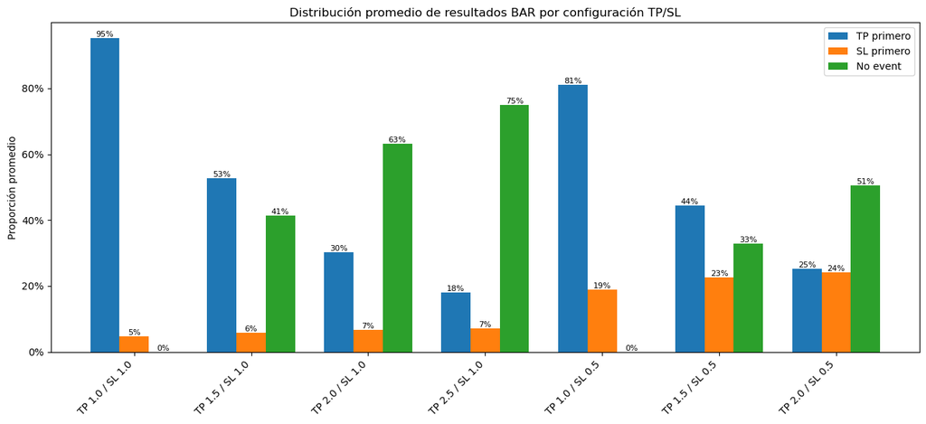

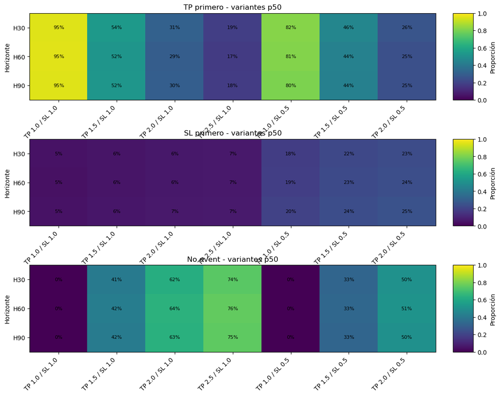

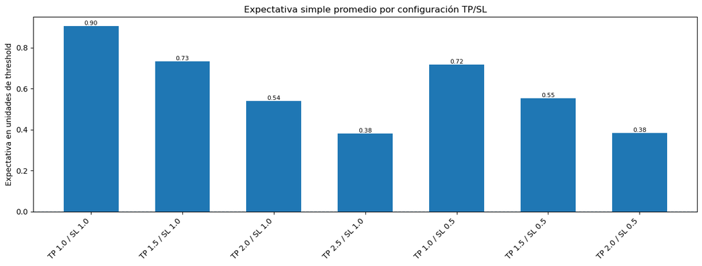

```
Celda 3 finalizada correctamente.
```

```python
# Celda 3 — Gráficos agrupados
# ============================================================

print("Gráficos agrupados de distribución global - BAR")
print("=" * 80)

# ------------------------------------------------------------
# Validar objetos necesarios
# ------------------------------------------------------------

if "df_bar_distribution_by_config" not in globals():
    raise NameError("No existe df_bar_distribution_by_config. Primero debes correr la Celda 2.")

if "df_bar_global_distribution" not in globals():
    raise NameError("No existe df_bar_global_distribution. Primero debes correr la Celda 1.")

# ------------------------------------------------------------
# Orden de configuraciones TP/SL
# ------------------------------------------------------------

config_order = [
    (1.0, 1.0),
    (1.5, 1.0),
    (2.0, 1.0),
    (2.5, 1.0),
    (1.0, 0.5),
    (1.5, 0.5),
    (2.0, 0.5),
]

config_labels = [
    f"TP {tp} / SL {sl}"
    for tp, sl in config_order
]

df_config_plot = df_bar_distribution_by_config.copy()

df_config_plot["config_order"] = df_config_plot.apply(
    lambda row: config_order.index((row["tp_mult"], row["sl_mult"]))
    if (row["tp_mult"], row["sl_mult"]) in config_order
    else 999,
    axis=1
)

df_config_plot = (
    df_config_plot
    .sort_values("config_order")
    .reset_index(drop=True)
)

# ============================================================
# Figura 1 — Distribución promedio por configuración TP/SL
# ============================================================

x = np.arange(len(df_config_plot))
bar_width = 0.25

fig, ax = plt.subplots(figsize=(13, 6))

ax.bar(
    x - bar_width,
    df_config_plot["tp_rate_mean"],
    width=bar_width,
    label="TP primero"
)

ax.bar(
    x,
    df_config_plot["sl_rate_mean"],
    width=bar_width,
    label="SL primero"
)

ax.bar(
    x + bar_width,
    df_config_plot["no_event_rate_mean"],
    width=bar_width,
    label="No event"
)

ax.set_title("Distribución promedio de resultados BAR por configuración TP/SL")
ax.set_ylabel("Proporción promedio")
ax.set_xticks(x)
ax.set_xticklabels(config_labels, rotation=45, ha="right")
ax.legend()

ax.yaxis.set_major_formatter(
    plt.FuncFormatter(lambda y, _: f"{y:.0%}")
)

for i, row in df_config_plot.iterrows():
    ax.text(
        i - bar_width,
        row["tp_rate_mean"],
        f"{row['tp_rate_mean']:.0%}",
        ha="center",
        va="bottom",
        fontsize=8
    )
    ax.text(
        i,
        row["sl_rate_mean"],
        f"{row['sl_rate_mean']:.0%}",
        ha="center",
        va="bottom",
        fontsize=8
    )
    ax.text(
        i + bar_width,
        row["no_event_rate_mean"],
        f"{row['no_event_rate_mean']:.0%}",
        ha="center",
        va="bottom",
        fontsize=8
    )

plt.tight_layout()
plt.show()

# ============================================================
# Figura 2 — Heatmaps p50 por horizonte y configuración TP/SL
# ============================================================

df_p50_plot = df_bar_global_distribution[
    df_bar_global_distribution["percentile"] == 50
].copy()

df_p50_plot["config_label"] = df_p50_plot.apply(
    lambda row: f"TP {row['tp_mult']} / SL {row['sl_mult']}",
    axis=1
)

df_p50_plot["config_order"] = df_p50_plot.apply(
    lambda row: config_order.index((row["tp_mult"], row["sl_mult"]))
    if (row["tp_mult"], row["sl_mult"]) in config_order
    else 999,
    axis=1
)

metrics_to_plot = [
    ("tp_rate", "TP primero"),
    ("sl_rate", "SL primero"),
    ("no_event_rate", "No event"),
]

fig = plt.figure(figsize=(13, 10))

gs = fig.add_gridspec(
    nrows=3,
    ncols=2,
    width_ratios=[20, 1],
    hspace=0.45,
    wspace=0.08
)

axes = [fig.add_subplot(gs[i, 0]) for i in range(3)]
caxes = [fig.add_subplot(gs[i, 1]) for i in range(3)]

for ax, cax, (metric_col, metric_title) in zip(axes, caxes, metrics_to_plot):
    tmp = df_p50_plot.copy()

    pivot_tmp = tmp.pivot(
        index="horizon",
        columns="config_label",
        values=metric_col
    )

    ordered_columns = [
        label for label in config_labels
        if label in pivot_tmp.columns
    ]

    pivot_tmp = pivot_tmp.reindex(index=BAR_HORIZONS)
    pivot_tmp = pivot_tmp.reindex(columns=ordered_columns)

    data = np.ma.masked_invalid(pivot_tmp.values)

    im = ax.imshow(
        data,
        aspect="auto",
        vmin=0,
        vmax=1
    )

    ax.set_title(f"{metric_title} - variantes p50")
    ax.set_ylabel("Horizonte")

    ax.set_yticks(np.arange(len(pivot_tmp.index)))
    ax.set_yticklabels([f"H{h}" for h in pivot_tmp.index])

    ax.set_xticks(np.arange(len(pivot_tmp.columns)))
    ax.set_xticklabels(pivot_tmp.columns, rotation=45, ha="right")

    for i in range(pivot_tmp.shape[0]):
        for j in range(pivot_tmp.shape[1]):
            value = pivot_tmp.iloc[i, j]

            if pd.notna(value):
                ax.text(
                    j,
                    i,
                    f"{value:.0%}",
                    ha="center",
                    va="center",
                    fontsize=8
                )

    fig.colorbar(
        im,
        cax=cax,
        label="Proporción"
    )

plt.show()

# ============================================================
# Figura 3 — Expectativa simple por configuración TP/SL
# ============================================================

fig, ax = plt.subplots(figsize=(13, 5))

ax.bar(
    x,
    df_config_plot["expectancy_units_mean"],
    width=0.6
)

ax.axhline(0, linestyle="--", linewidth=1)

ax.set_title("Expectativa simple promedio por configuración TP/SL")
ax.set_ylabel("Expectativa en unidades de threshold")
ax.set_xticks(x)
ax.set_xticklabels(config_labels, rotation=45, ha="right")

for i, row in df_config_plot.iterrows():
    ax.text(
        i,
        row["expectancy_units_mean"],
        f"{row['expectancy_units_mean']:.2f}",
        ha="center",
        va="bottom" if row["expectancy_units_mean"] >= 0 else "top",
        fontsize=8
    )

plt.tight_layout()
plt.show()

print("\nCelda 3 finalizada correctamente.")
```

### Celda 4 — Resumen guardado / tabla final para observaciones

```python
# Celda 4 — Guardado y tabla final para observaciones
# ============================================================

print("Guardado y tabla final de distribución global - BAR")
print("=" * 80)

# ------------------------------------------------------------
# Validar objetos necesarios
# ------------------------------------------------------------

required_objects = [
    "df_bar_global_distribution",
    "df_bar_distribution_by_config",
    "df_bar_distribution_by_target_base",
    "df_bar_distribution_p50",
    "df_bar_distribution_ranking",
]

missing_objects = [
    obj for obj in required_objects
    if obj not in globals()
]

if missing_objects:
    raise NameError(
        "Faltan objetos necesarios. "
        f"Debes correr las celdas anteriores: {missing_objects}"
    )

# ------------------------------------------------------------
# Definir rutas de guardado
# ------------------------------------------------------------

MNQ_TARGETS_BAR_GLOBAL_DISTRIBUTION_CSV = (
    MNQ_TARGETS_PATH / "mnq_targets_bar_global_distribution.csv"
)

MNQ_TARGETS_BAR_DISTRIBUTION_BY_CONFIG_CSV = (
    MNQ_TARGETS_PATH / "mnq_targets_bar_distribution_by_config.csv"
)

MNQ_TARGETS_BAR_DISTRIBUTION_BY_TARGET_BASE_CSV = (
    MNQ_TARGETS_PATH / "mnq_targets_bar_distribution_by_target_base.csv"
)

MNQ_TARGETS_BAR_DISTRIBUTION_RANKING_CSV = (
    MNQ_TARGETS_PATH / "mnq_targets_bar_distribution_ranking.csv"
)

MNQ_TARGETS_BAR_DISTRIBUTION_REPORT_TXT = (
    MNQ_TARGETS_PATH / "mnq_targets_bar_distribution_report.txt"
)

# ------------------------------------------------------------
# Guardar tablas principales
# ------------------------------------------------------------

df_bar_global_distribution.to_csv(
    MNQ_TARGETS_BAR_GLOBAL_DISTRIBUTION_CSV,
    index=False
)

df_bar_distribution_by_config.to_csv(
    MNQ_TARGETS_BAR_DISTRIBUTION_BY_CONFIG_CSV,
    index=False
)

df_bar_distribution_by_target_base.to_csv(
    MNQ_TARGETS_BAR_DISTRIBUTION_BY_TARGET_BASE_CSV,
    index=False
)

df_bar_distribution_ranking.to_csv(
    MNQ_TARGETS_BAR_DISTRIBUTION_RANKING_CSV,
    index=False
)

# ------------------------------------------------------------
# Crear tabla final compacta para observaciones
# ------------------------------------------------------------

df_bar_distribution_observation_table = (
    df_bar_distribution_by_config
    .copy()
    .sort_values(["sl_mult", "tp_mult"])
    .reset_index(drop=True)
)

observation_cols = [
    "tp_sl_config",
    "tp_mult",
    "sl_mult",
    "n_targets",
    "tp_rate_mean",
    "sl_rate_mean",
    "no_event_rate_mean",
    "tp_share_over_resolved_mean",
    "breakeven_win_rate",
    "tp_rate_vs_breakeven_mean",
    "expectancy_units_mean",
    "event_step_mean",
]

print("\nTabla compacta para observaciones:")
print(
    df_bar_distribution_observation_table[observation_cols]
    .to_string(
        index=False,
        formatters={
            "tp_rate_mean": "{:.2%}".format,
            "sl_rate_mean": "{:.2%}".format,
            "no_event_rate_mean": "{:.2%}".format,
            "tp_share_over_resolved_mean": "{:.2%}".format,
            "breakeven_win_rate": "{:.2%}".format,
            "tp_rate_vs_breakeven_mean": "{:.2%}".format,
            "expectancy_units_mean": "{:.3f}".format,
            "event_step_mean": "{:.2f}".format,
        }
    )
)

# ------------------------------------------------------------
# Tabla p50 compacta
# ------------------------------------------------------------

p50_cols = [
    "bar_col",
    "horizon",
    "tp_mult",
    "sl_mult",
    "tp_rate",
    "sl_rate",
    "no_event_rate",
    "tp_share_over_resolved",
    "breakeven_win_rate",
    "tp_rate_vs_breakeven",
    "expectancy_units",
    "event_step_mean",
    "event_step_median",
]

print("\nTabla compacta de variantes p50:")
print(
    df_bar_distribution_p50[p50_cols]
    .to_string(
        index=False,
        formatters={
            "tp_rate": "{:.2%}".format,
            "sl_rate": "{:.2%}".format,
            "no_event_rate": "{:.2%}".format,
            "tp_share_over_resolved": "{:.2%}".format,
            "breakeven_win_rate": "{:.2%}".format,
            "tp_rate_vs_breakeven": "{:.2%}".format,
            "expectancy_units": "{:.3f}".format,
            "event_step_mean": "{:.2f}".format,
            "event_step_median": "{:.2f}".format,
        }
    )
)

# ------------------------------------------------------------
# Top variantes por expectativa simple
# ------------------------------------------------------------

print("\nTop 20 variantes por expectativa simple:")
print(
    df_bar_distribution_ranking[
        [
            "bar_col",
            "horizon",
            "percentile",
            "tp_mult",
            "sl_mult",
            "tp_rate",
            "sl_rate",
            "no_event_rate",
            "tp_share_over_resolved",
            "breakeven_win_rate",
            "expectancy_units",
            "event_step_mean",
        ]
    ]
    .head(20)
    .to_string(
        index=False,
        formatters={
            "tp_rate": "{:.2%}".format,
            "sl_rate": "{:.2%}".format,
            "no_event_rate": "{:.2%}".format,
            "tp_share_over_resolved": "{:.2%}".format,
            "breakeven_win_rate": "{:.2%}".format,
            "expectancy_units": "{:.3f}".format,
            "event_step_mean": "{:.2f}".format,
        }
    )
)

# ------------------------------------------------------------
# Guardar reporte TXT completo
# ------------------------------------------------------------

with MNQ_TARGETS_BAR_DISTRIBUTION_REPORT_TXT.open("w", encoding="utf-8") as f:
    f.write("4.6. Distribución global de resultados - BAR\n")
    f.write("=" * 100 + "\n\n")

    f.write("Tabla compacta por configuración TP/SL\n")
    f.write("-" * 100 + "\n")
    f.write(
        df_bar_distribution_observation_table[observation_cols]
        .to_string(
            index=False,
            formatters={
                "tp_rate_mean": "{:.2%}".format,
                "sl_rate_mean": "{:.2%}".format,
                "no_event_rate_mean": "{:.2%}".format,
                "tp_share_over_resolved_mean": "{:.2%}".format,
                "breakeven_win_rate": "{:.2%}".format,
                "tp_rate_vs_breakeven_mean": "{:.2%}".format,
                "expectancy_units_mean": "{:.3f}".format,
                "event_step_mean": "{:.2f}".format,
            }
        )
    )

    f.write("\n\n")
    f.write("Tabla compacta de variantes p50\n")
    f.write("-" * 100 + "\n")
    f.write(
        df_bar_distribution_p50[p50_cols]
        .to_string(
            index=False,
            formatters={
                "tp_rate": "{:.2%}".format,
                "sl_rate": "{:.2%}".format,
                "no_event_rate": "{:.2%}".format,
                "tp_share_over_resolved": "{:.2%}".format,
                "breakeven_win_rate": "{:.2%}".format,
                "tp_rate_vs_breakeven": "{:.2%}".format,
                "expectancy_units": "{:.3f}".format,
                "event_step_mean": "{:.2f}".format,
                "event_step_median": "{:.2f}".format,
            }
        )
    )

    f.write("\n\n")
    f.write("Top 20 variantes por expectativa simple\n")
    f.write("-" * 100 + "\n")
    f.write(
        df_bar_distribution_ranking[
            [
                "bar_col",
                "horizon",
                "percentile",
                "tp_mult",
                "sl_mult",
                "tp_rate",
                "sl_rate",
                "no_event_rate",
                "tp_share_over_resolved",
                "breakeven_win_rate",
                "expectancy_units",
                "event_step_mean",
            ]
        ]
        .head(20)
        .to_string(
            index=False,
            formatters={
                "tp_rate": "{:.2%}".format,
                "sl_rate": "{:.2%}".format,
                "no_event_rate": "{:.2%}".format,
                "tp_share_over_resolved": "{:.2%}".format,
                "breakeven_win_rate": "{:.2%}".format,
                "expectancy_units": "{:.3f}".format,
                "event_step_mean": "{:.2f}".format,
            }
        )
    )

# ------------------------------------------------------------
# Confirmación final
# ------------------------------------------------------------

print("\nArchivos guardados:")
print(f"Distribución global BAR:       {MNQ_TARGETS_BAR_GLOBAL_DISTRIBUTION_CSV}")
print(f"Resumen por configuración:     {MNQ_TARGETS_BAR_DISTRIBUTION_BY_CONFIG_CSV}")
print(f"Resumen por target base:       {MNQ_TARGETS_BAR_DISTRIBUTION_BY_TARGET_BASE_CSV}")
print(f"Ranking BAR:                   {MNQ_TARGETS_BAR_DISTRIBUTION_RANKING_CSV}")
print(f"Reporte TXT:                   {MNQ_TARGETS_BAR_DISTRIBUTION_REPORT_TXT}")

print("\nCelda 4 finalizada correctamente.")
```

```
Guardado y tabla final de distribución global - BAR
================================================================================

Tabla compacta para observaciones:
   tp_sl_config  tp_mult  sl_mult  n_targets tp_rate_mean sl_rate_mean no_event_rate_mean tp_share_over_resolved_mean breakeven_win_rate tp_rate_vs_breakeven_mean expectancy_units_mean event_step_mean
TP 1.0 / SL 0.5      1.0      0.5          9       81.07%       18.93%              0.00%                      81.07%             33.33%                    47.74%                 0.716           24.41
TP 1.5 / SL 0.5      1.5      0.5          9       44.39%       22.71%             32.89%                      66.29%             25.00%                    19.39%                 0.552           26.43
TP 2.0 / SL 0.5      2.0      0.5          9       25.21%       24.24%             50.55%                      51.08%             20.00%                     5.21%                 0.383           26.20
TP 1.0 / SL 1.0      1.0      1.0          9       95.18%        4.82%              0.00%                      95.18%             50.00%                    45.18%                 0.904           28.32
TP 1.5 / SL 1.0      1.5      1.0          9       52.73%        5.85%             41.42%                      90.13%             40.00%                    12.73%                 0.733           31.56
TP 2.0 / SL 1.0      2.0      1.0          9       30.26%        6.65%             63.10%                      82.20%             33.33%                    -3.08%                 0.539           33.08
TP 2.5 / SL 1.0      2.5      1.0          9       18.02%        7.06%             74.92%                      72.07%             28.57%                   -10.56%                 0.380           33.39

Tabla compacta de variantes p50:
              bar_col  horizon  tp_mult  sl_mult tp_rate sl_rate no_event_rate tp_share_over_resolved breakeven_win_rate tp_rate_vs_breakeven expectancy_units event_step_mean event_step_median
bar_p50_h30_tp10_sl05       30      1.0      0.5  81.93%  18.07%         0.00%                 81.93%             33.33%               48.59%            0.729           12.37             11.00
bar_p50_h30_tp15_sl05       30      1.5      0.5  45.74%  21.67%        32.60%                 67.85%             25.00%               20.74%            0.578           13.40             12.00
bar_p50_h30_tp20_sl05       30      2.0      0.5  26.31%  23.19%        50.50%                 53.15%             20.00%                6.31%            0.410           13.39             12.00
bar_p50_h30_tp10_sl10       30      1.0      1.0  95.26%   4.74%         0.00%                 95.26%             50.00%               45.26%            0.905           14.21             13.00
bar_p50_h30_tp15_sl10       30      1.5      1.0  53.60%   5.71%        40.70%                 90.38%             40.00%               13.60%            0.747           15.74             15.00
bar_p50_h30_tp20_sl10       30      2.0      1.0  31.07%   6.49%        62.44%                 82.73%             33.33%               -2.26%            0.557           16.50             17.00
bar_p50_h30_tp25_sl10       30      2.5      1.0  18.63%   6.90%        74.47%                 72.97%             28.57%               -9.94%            0.397           16.70             17.00
bar_p50_h60_tp10_sl05       60      1.0      0.5  81.32%  18.68%         0.00%                 81.32%             33.33%               47.99%            0.720           24.40             21.00
bar_p50_h60_tp15_sl05       60      1.5      0.5  44.00%  22.52%        33.48%                 66.15%             25.00%               19.00%            0.547           26.28             24.00
bar_p50_h60_tp20_sl05       60      2.0      0.5  24.58%  23.99%        51.44%                 50.61%             20.00%                4.58%            0.372           25.95             23.00
bar_p50_h60_tp10_sl10       60      1.0      1.0  95.45%   4.55%         0.00%                 95.45%             50.00%               45.45%            0.909           28.22             26.00
```

[output cut: 42 more lines]

### Observaciones preliminares — Distribución global de resultados BAR

La distribución global de `BAR` muestra un comportamiento coherente con la lógica definida para las barreras TP/SL.

En primer lugar, las configuraciones con `TP = 1.0 × threshold` presentan `no_event = 0%`. Esto es esperable, porque `DIR` ya exige que exista una excursión favorable igual o superior al threshold base. Por lo tanto, cuando el TP se ubica exactamente en esa distancia, el evento necesariamente se resuelve como TP primero o SL primero.

La configuración `TP 1.0 / SL 1.0` muestra la mayor tasa de TP primero, con un promedio cercano al 95%. Sin embargo, este resultado debe interpretarse como un benchmark operativo, no como una señal definitiva de calidad, ya que está muy favorecido por la propia construcción de `DIR`.

Al aumentar la distancia del Take Profit, el target se vuelve más exigente. Esto se observa claramente en las configuraciones con `SL = 1.0`:

```
    TP 1.0 / SL 1.0 → TP alto y no_event nulo
    TP 1.5 / SL 1.0 → TP intermedio y no_event moderado
    TP 2.0 / SL 1.0 → TP bajo y no_event alto
    TP 2.5 / SL 1.0 → TP muy bajo y no_event muy alto
```

Esto indica que objetivos demasiado amplios no suelen alcanzarse dentro del horizonte definido. En particular, `TP 2.0 / SL 1.0` y `TP 2.5 / SL 1.0` dejan una gran proporción de casos sin resolución, por lo que parecen configuraciones demasiado exigentes para esta primera etapa.

Las configuraciones con `SL = 0.5` muestran una lógica diferente. Al tener el Stop Loss más cerca, aumenta la proporción de SL primero. Esto es esperable: cuanto más ajustado está el stop, más fácil es que el precio lo toque antes de alcanzar el TP.

Entre las configuraciones evaluadas, `TP 1.5 / SL 1.0` aparece como una de las alternativas más interesantes para continuar el análisis. No es tan fácil como `TP 1.0 / SL 1.0`, pero todavía mantiene una proporción razonable de TP primero, un SL bajo y una proporción de eventos resueltos aceptable.

Las variantes `p50` muestran un comportamiento bastante consistente entre horizontes `H30`, `H60` y `H90`. Para `TP 1.5 / SL 1.0`, las tasas de TP se mantienen alrededor del 52%–54%, con SL cercano al 5%–6% y no_event alrededor del 41%–42%. Esto sugiere que la configuración es relativamente estable entre horizontes.

El ranking por expectativa simple favorece principalmente las variantes `TP 1.0 / SL 1.0`, especialmente en `p60`. Sin embargo, esto no debe interpretarse automáticamente como la mejor opción, porque esa configuración está directamente relacionada con el threshold base usado para construir `DIR`. Por eso, su utilidad principal es servir como referencia.

En síntesis, la distribución global de `BAR` confirma que el target está funcionando de forma lógica: TP cercanos se alcanzan con mayor frecuencia, TP lejanos generan más casos sin evento y stops más ajustados aumentan la probabilidad de SL. Para los próximos análisis, conviene mantener como benchmark `TP 1.0 / SL 1.0`, pero prestar especial atención a `TP 1.5 / SL 1.0` como candidata operativa principal.

La lectura simple: **seguimos mirando todas**, pero el foco práctico debería estar en:

```
    Benchmark:        TP 1.0 / SL 1.0
    Candidata fuerte: TP 1.5 / SL 1.0
    Candidata dura:   TP 2.0 / SL 1.0
```

`TP 2.5 / SL 1.0` parece demasiado exigente, y las de `SL 0.5` son útiles como comparación, pero más agresivas.

## 4.7. Frecuencia de TP y SL

En este punto se analiza específicamente la frecuencia con la que los targets `BAR` alcanzan primero el Take Profit o el Stop Loss.

A diferencia del punto anterior, donde se revisó la distribución global incluyendo `no_event`, aquí el foco estará en comparar directamente la relación entre TP y SL.

El objetivo es identificar qué configuraciones generan una proporción favorable de TP primero, cuáles producen demasiados SL y cuáles mantienen una relación TP/SL razonable para continuar hacia análisis más detallados.

### Celda 1 — Preparación de métricas TP/SL

```python
# Celda 1 — Preparación de métricas TP/SL
# ============================================================

print("4.7. Frecuencia de TP y SL - BAR")
print("=" * 80)

# ------------------------------------------------------------
# Validar tabla base
# ------------------------------------------------------------

if "df_bar_global_distribution" not in globals():
    raise NameError("No existe df_bar_global_distribution. Primero debes correr el punto 4.6.")

# ------------------------------------------------------------
# Copia de trabajo
# ------------------------------------------------------------

df_bar_tp_sl_frequency = df_bar_global_distribution.copy()

# ------------------------------------------------------------
# Métricas específicas TP/SL
# ------------------------------------------------------------

# Casos que resolvieron: TP o SL
df_bar_tp_sl_frequency["resolved_rate"] = (
    df_bar_tp_sl_frequency["tp_rate"]
    + df_bar_tp_sl_frequency["sl_rate"]
)

# Diferencia directa entre TP y SL
df_bar_tp_sl_frequency["tp_minus_sl_rate"] = (
    df_bar_tp_sl_frequency["tp_rate"]
    - df_bar_tp_sl_frequency["sl_rate"]
)

# Relación TP / SL.
# Ejemplo: 10 significa que hubo 10 veces más TP que SL.
df_bar_tp_sl_frequency["tp_to_sl_ratio"] = np.where(
    df_bar_tp_sl_frequency["sl_rate"] > 0,
    df_bar_tp_sl_frequency["tp_rate"] / df_bar_tp_sl_frequency["sl_rate"],
    np.nan
)

# TP entre eventos resueltos.
# Esto ya existía como tp_share_over_resolved,
# pero lo renombramos conceptualmente para esta sección.
df_bar_tp_sl_frequency["tp_rate_resolved_only"] = (
    df_bar_tp_sl_frequency["tp_share_over_resolved"]
)

df_bar_tp_sl_frequency["sl_rate_resolved_only"] = (
    1 - df_bar_tp_sl_frequency["tp_share_over_resolved"]
)

# ------------------------------------------------------------
# Clasificación simple del balance TP/SL
# ------------------------------------------------------------

def classify_tp_sl_quality(row):
    """
    Clasificación simple y preliminar de la relación TP/SL.
    No selecciona target final, solo ayuda a leer la tabla.
    """

    tp_resolved = row["tp_rate_resolved_only"]
    no_event = row["no_event_rate"]

    if pd.isna(tp_resolved):
        return "sin_eventos"

    if tp_resolved >= 0.85 and no_event <= 0.45:
        return "muy_favorable"

    if tp_resolved >= 0.70 and no_event <= 0.65:
        return "favorable"

    if tp_resolved >= 0.55:
        return "moderada"

    return "débil"


df_bar_tp_sl_frequency["tp_sl_quality"] = df_bar_tp_sl_frequency.apply(
    classify_tp_sl_quality,
    axis=1
)

# ------------------------------------------------------------
# Orden de columnas para análisis
# ------------------------------------------------------------

tp_sl_frequency_cols = [
    "bar_col",
    "target_base",
    "horizon",
    "percentile",
    "tp_mult",
    "sl_mult",
    "tp_sl_config",
    "valid_rows",
    "tp_rate",
    "sl_rate",
    "no_event_rate",
    "resolved_rate",
    "tp_minus_sl_rate",
    "tp_to_sl_ratio",
    "tp_rate_resolved_only",
    "sl_rate_resolved_only",
    "breakeven_win_rate",
    "tp_rate_vs_breakeven",
    "expectancy_units",
    "tp_sl_quality",
]

df_bar_tp_sl_frequency = (
    df_bar_tp_sl_frequency[tp_sl_frequency_cols]
    .sort_values(["percentile", "horizon", "sl_mult", "tp_mult"])
    .reset_index(drop=True)
)

# ------------------------------------------------------------
# Vista inicial
# ------------------------------------------------------------

print(f"Targets BAR analizados: {len(df_bar_tp_sl_frequency)}")

print("\nVista inicial de frecuencia TP/SL:")
print(
    df_bar_tp_sl_frequency
    .head(21)
    .to_string(
        index=False,
        formatters={
            "tp_rate": "{:.2%}".format,
            "sl_rate": "{:.2%}".format,
            "no_event_rate": "{:.2%}".format,
            "resolved_rate": "{:.2%}".format,
            "tp_minus_sl_rate": "{:.2%}".format,
            "tp_to_sl_ratio": "{:.2f}".format,
            "tp_rate_resolved_only": "{:.2%}".format,
            "sl_rate_resolved_only": "{:.2%}".format,
            "breakeven_win_rate": "{:.2%}".format,
            "tp_rate_vs_breakeven": "{:.2%}".format,
            "expectancy_units": "{:.3f}".format,
        }
    )
)

print("\nPreparación de métricas TP/SL finalizada correctamente.")
```

```
4.7. Frecuencia de TP y SL - BAR
================================================================================
Targets BAR analizados: 63

Vista inicial de frecuencia TP/SL:
              bar_col target_base  horizon  percentile  tp_mult  sl_mult    tp_sl_config  valid_rows tp_rate sl_rate no_event_rate resolved_rate tp_minus_sl_rate tp_to_sl_ratio tp_rate_resolved_only sl_rate_resolved_only breakeven_win_rate tp_rate_vs_breakeven expectancy_units tp_sl_quality
bar_p40_h30_tp10_sl05     p40_h30       30          40      1.0      0.5 TP 1.0 / SL 0.5      623736  78.98%  21.02%         0.00%       100.00%           57.97%           3.76                78.98%                21.02%             33.33%               45.65%            0.685     favorable
bar_p40_h30_tp15_sl05     p40_h30       30          40      1.5      0.5 TP 1.5 / SL 0.5      623736  48.14%  25.07%        26.79%        73.21%           23.07%           1.92                65.76%                34.24%             25.00%               23.14%            0.597      moderada
bar_p40_h30_tp20_sl05     p40_h30       30          40      2.0      0.5 TP 2.0 / SL 0.5      623736  29.68%  26.94%        43.38%        56.62%            2.75%           1.10                52.42%                47.58%             20.00%                9.68%            0.459         débil
bar_p40_h30_tp10_sl10     p40_h30       30          40      1.0      1.0 TP 1.0 / SL 1.0      623736  93.84%   6.16%         0.00%       100.00%           87.69%          15.24                93.84%                 6.16%             50.00%               43.84%            0.877 muy_favorable
bar_p40_h30_tp15_sl10     p40_h30       30          40      1.5      1.0 TP 1.5 / SL 1.0      623736  57.52%   7.35%        35.13%        64.87%           50.17%           7.82                88.67%                11.33%             40.00%               17.52%            0.789 muy_favorable
bar_p40_h30_tp20_sl10     p40_h30       30          40      2.0      1.0 TP 2.0 / SL 1.0      623736  35.63%   8.35%        56.03%        43.97%           27.28%           4.27                81.02%                18.98%             33.33%                2.29%            0.629     favorable
bar_p40_h30_tp25_sl10     p40_h30       30          40      2.5      1.0 TP 2.5 / SL 1.0      623736  22.59%   8.92%        68.49%        31.51%           13.67%           2.53                71.69%                28.31%             28.57%               -5.98%            0.476      moderada
bar_p40_h60_tp10_sl05     p40_h60       60          40      1.0      0.5 TP 1.0 / SL 0.5      597024  77.94%  22.06%         0.00%       100.00%           55.88%           3.53                77.94%                22.06%             33.33%               44.61%            0.669     favorable
bar_p40_h60_tp15_sl05     p40_h60       60          40      1.5      0.5 TP 1.5 / SL 0.5      597024  46.45%  26.43%        27.12%        72.88%           20.02%           1.76                63.74%                36.26%             25.00%               21.45%            0.565      moderada
bar_p40_h60_tp20_sl05     p40_h60       60          40      2.0      0.5 TP 2.0 / SL 0.5      597024  27.84%  28.31%        43.85%        56.15%           -0.47%           0.98                49.58%                50.42%             20.00%                7.84%            0.415         débil
bar_p40_h60_tp10_sl10     p40_h60       60          40      1.0      1.0 TP 1.0 / SL 1.0      597024  94.00%   6.00%         0.00%       100.00%           88.00%          15.66                94.00%                 6.00%             50.00%               44.00%            0.880 muy_favorable
bar_p40_h60_tp15_sl10     p40_h60       60          40      1.5      1.0 TP 1.5 / SL 1.0      597024  56.30%   7.31%        36.39%        63.61%           48.99%           7.70                88.51%                11.49%             40.00%               16.30%            0.771 muy_favorable
bar_p40_h60_tp20_sl10     p40_h60       60          40      2.0      1.0 TP 2.0 / SL 1.0      597024  34.08%   8.30%        57.61%        42.39%           25.78%           4.10                80.41%                19.59%             33.33%                0.75%            0.599     favorable
```

[output cut: 10 more lines]

### Celda 2 — Tablas agregadas por configuración, percentil y horizonte

```python
# Celda 2 — Tablas agregadas de frecuencia TP/SL
# ============================================================

print("Tablas agregadas de frecuencia TP/SL - BAR")
print("=" * 80)

# ------------------------------------------------------------
# Validar tabla base
# ------------------------------------------------------------

if "df_bar_tp_sl_frequency" not in globals():
    raise NameError("No existe df_bar_tp_sl_frequency. Primero debes correr la Celda 1.")

# ------------------------------------------------------------
# 1. Resumen por configuración TP/SL
# ------------------------------------------------------------

df_bar_tp_sl_by_config = (
    df_bar_tp_sl_frequency
    .groupby(["tp_mult", "sl_mult", "tp_sl_config"], as_index=False)
    .agg(
        n_targets=("bar_col", "count"),
        tp_rate_mean=("tp_rate", "mean"),
        sl_rate_mean=("sl_rate", "mean"),
        no_event_rate_mean=("no_event_rate", "mean"),
        resolved_rate_mean=("resolved_rate", "mean"),
        tp_minus_sl_rate_mean=("tp_minus_sl_rate", "mean"),
        tp_to_sl_ratio_mean=("tp_to_sl_ratio", "mean"),
        tp_rate_resolved_only_mean=("tp_rate_resolved_only", "mean"),
        sl_rate_resolved_only_mean=("sl_rate_resolved_only", "mean"),
        expectancy_units_mean=("expectancy_units", "mean"),
    )
    .sort_values(["sl_mult", "tp_mult"])
    .reset_index(drop=True)
)

print("\nResumen por configuración TP/SL:")
print(
    df_bar_tp_sl_by_config.to_string(
        index=False,
        formatters={
            "tp_rate_mean": "{:.2%}".format,
            "sl_rate_mean": "{:.2%}".format,
            "no_event_rate_mean": "{:.2%}".format,
            "resolved_rate_mean": "{:.2%}".format,
            "tp_minus_sl_rate_mean": "{:.2%}".format,
            "tp_to_sl_ratio_mean": "{:.2f}".format,
            "tp_rate_resolved_only_mean": "{:.2%}".format,
            "sl_rate_resolved_only_mean": "{:.2%}".format,
            "expectancy_units_mean": "{:.3f}".format,
        }
    )
)

# ------------------------------------------------------------
# 2. Resumen por percentil y horizonte
# ------------------------------------------------------------

df_bar_tp_sl_by_target_base = (
    df_bar_tp_sl_frequency
    .groupby(["percentile", "horizon", "target_base"], as_index=False)
    .agg(
        n_configs=("bar_col", "count"),
        tp_rate_mean=("tp_rate", "mean"),
        sl_rate_mean=("sl_rate", "mean"),
        no_event_rate_mean=("no_event_rate", "mean"),
        resolved_rate_mean=("resolved_rate", "mean"),
        tp_minus_sl_rate_mean=("tp_minus_sl_rate", "mean"),
        tp_to_sl_ratio_mean=("tp_to_sl_ratio", "mean"),
        tp_rate_resolved_only_mean=("tp_rate_resolved_only", "mean"),
        expectancy_units_mean=("expectancy_units", "mean"),
    )
    .sort_values(["percentile", "horizon"])
    .reset_index(drop=True)
)

print("\nResumen por percentil y horizonte:")
print(
    df_bar_tp_sl_by_target_base.to_string(
        index=False,
        formatters={
            "tp_rate_mean": "{:.2%}".format,
            "sl_rate_mean": "{:.2%}".format,
            "no_event_rate_mean": "{:.2%}".format,
            "resolved_rate_mean": "{:.2%}".format,
            "tp_minus_sl_rate_mean": "{:.2%}".format,
            "tp_to_sl_ratio_mean": "{:.2f}".format,
            "tp_rate_resolved_only_mean": "{:.2%}".format,
            "expectancy_units_mean": "{:.3f}".format,
        }
    )
)

# ------------------------------------------------------------
# 3. Detalle de variantes centrales p50
# ------------------------------------------------------------

df_bar_tp_sl_p50 = (
    df_bar_tp_sl_frequency[
        df_bar_tp_sl_frequency["percentile"] == 50
    ]
    .copy()
    .sort_values(["horizon", "sl_mult", "tp_mult"])
    .reset_index(drop=True)
)

print("\nDetalle de frecuencia TP/SL para variantes p50:")
print(
    df_bar_tp_sl_p50[
        [
            "bar_col",
            "horizon",
            "tp_mult",
            "sl_mult",
            "tp_rate",
            "sl_rate",
            "no_event_rate",
            "resolved_rate",
            "tp_minus_sl_rate",
            "tp_to_sl_ratio",
            "tp_rate_resolved_only",
            "sl_rate_resolved_only",
            "expectancy_units",
            "tp_sl_quality",
        ]
    ].to_string(
        index=False,
        formatters={
            "tp_rate": "{:.2%}".format,
            "sl_rate": "{:.2%}".format,
            "no_event_rate": "{:.2%}".format,
            "resolved_rate": "{:.2%}".format,
            "tp_minus_sl_rate": "{:.2%}".format,
            "tp_to_sl_ratio": "{:.2f}".format,
            "tp_rate_resolved_only": "{:.2%}".format,
            "sl_rate_resolved_only": "{:.2%}".format,
            "expectancy_units": "{:.3f}".format,
        }
    )
)

# ------------------------------------------------------------
# 4. Ranking por relación TP/SL resuelta
# ------------------------------------------------------------
# Este ranking mira solamente los casos que resolvieron como TP o SL.
# No reemplaza el análisis global, porque puede ocultar muchos no_event.
# ------------------------------------------------------------

df_bar_tp_sl_resolved_ranking = (
    df_bar_tp_sl_frequency
    .copy()
    .sort_values(
        ["tp_rate_resolved_only", "tp_minus_sl_rate", "resolved_rate"],
        ascending=[False, False, False]
    )
    .reset_index(drop=True)
)

print("\nTop 20 por proporción de TP entre eventos resueltos:")
print(
    df_bar_tp_sl_resolved_ranking[
        [
            "bar_col",
            "horizon",
            "percentile",
            "tp_mult",
            "sl_mult",
            "tp_rate",
            "sl_rate",
            "no_event_rate",
            "resolved_rate",
            "tp_rate_resolved_only",
            "tp_to_sl_ratio",
            "tp_sl_quality",
        ]
    ]
    .head(20)
    .to_string(
        index=False,
        formatters={
            "tp_rate": "{:.2%}".format,
            "sl_rate": "{:.2%}".format,
            "no_event_rate": "{:.2%}".format,
            "resolved_rate": "{:.2%}".format,
            "tp_rate_resolved_only": "{:.2%}".format,
            "tp_to_sl_ratio": "{:.2f}".format,
        }
    )
)

# ------------------------------------------------------------
# 5. Conteo de calidad preliminar
# ------------------------------------------------------------

df_bar_tp_sl_quality_counts = (
    df_bar_tp_sl_frequency
    .groupby(["tp_sl_quality"], as_index=False)
    .agg(
        n_targets=("bar_col", "count"),
        tp_rate_mean=("tp_rate", "mean"),
        sl_rate_mean=("sl_rate", "mean"),
        no_event_rate_mean=("no_event_rate", "mean"),
        tp_rate_resolved_only_mean=("tp_rate_resolved_only", "mean"),
        expectancy_units_mean=("expectancy_units", "mean"),
    )
    .sort_values("n_targets", ascending=False)
    .reset_index(drop=True)
)

print("\nConteo por clasificación preliminar TP/SL:")
print(
    df_bar_tp_sl_quality_counts.to_string(
        index=False,
        formatters={
            "tp_rate_mean": "{:.2%}".format,
            "sl_rate_mean": "{:.2%}".format,
            "no_event_rate_mean": "{:.2%}".format,
            "tp_rate_resolved_only_mean": "{:.2%}".format,
            "expectancy_units_mean": "{:.3f}".format,
        }
    )
)

print("\nCelda 2 finalizada correctamente.")
```

```
Tablas agregadas de frecuencia TP/SL - BAR
================================================================================

Resumen por configuración TP/SL:
 tp_mult  sl_mult    tp_sl_config  n_targets tp_rate_mean sl_rate_mean no_event_rate_mean resolved_rate_mean tp_minus_sl_rate_mean tp_to_sl_ratio_mean tp_rate_resolved_only_mean sl_rate_resolved_only_mean expectancy_units_mean
     1.0      0.5 TP 1.0 / SL 0.5          9       81.07%       18.93%              0.00%            100.00%                62.15%                4.38                     81.07%                     18.93%                 0.716
     1.5      0.5 TP 1.5 / SL 0.5          9       44.39%       22.71%             32.89%             67.11%                21.68%                1.98                     66.29%                     33.71%                 0.552
     2.0      0.5 TP 2.0 / SL 0.5          9       25.21%       24.24%             50.55%             49.45%                 0.97%                1.05                     51.08%                     48.92%                 0.383
     1.0      1.0 TP 1.0 / SL 1.0          9       95.18%        4.82%              0.00%            100.00%                90.36%               20.89                     95.18%                      4.82%                 0.904
     1.5      1.0 TP 1.5 / SL 1.0          9       52.73%        5.85%             41.42%             58.58%                46.89%                9.36                     90.13%                      9.87%                 0.733
     2.0      1.0 TP 2.0 / SL 1.0          9       30.26%        6.65%             63.10%             36.90%                23.61%                4.66                     82.20%                     17.80%                 0.539
     2.5      1.0 TP 2.5 / SL 1.0          9       18.02%        7.06%             74.92%             25.08%                10.96%                2.59                     72.07%                     27.93%                 0.380

Resumen por percentil y horizonte:
 percentile  horizon target_base  n_configs tp_rate_mean sl_rate_mean no_event_rate_mean resolved_rate_mean tp_minus_sl_rate_mean tp_to_sl_ratio_mean tp_rate_resolved_only_mean expectancy_units_mean
         40       30     p40_h30          7       52.34%       14.83%             32.83%             67.17%                37.51%                5.24                     76.06%                 0.644
         40       60     p40_h60          7       51.09%       15.32%             33.58%             66.42%                35.77%                5.16                     74.94%                 0.620
         40       90     p40_h90          7       50.70%       15.98%             33.32%             66.68%                34.72%                4.83                     74.01%                 0.610
         50       30     p50_h30          7       50.36%       12.40%             37.24%             62.76%                37.97%                6.39                     77.75%                 0.617
         50       60     p50_h60          7       49.20%       12.61%             38.19%             61.81%                36.60%                6.43                     76.93%                 0.596
         50       90     p50_h90          7       49.04%       13.36%             37.61%             62.39%                35.68%                6.00                     75.97%                 0.590
         60       30     p60_h30          7       48.39%       10.19%             41.42%             58.58%                38.20%                7.94                     79.43%                 0.590
         60       60     p60_h60          7       47.41%       10.34%             42.25%             57.75%                37.07%                8.15                     78.79%                 0.572
         60       90     p60_h90          7       47.43%       11.02%             41.55%             58.45%                36.42%                7.58                     77.86%                 0.569

Detalle de frecuencia TP/SL para variantes p50:
```

[output cut: 54 more lines]

### Celda 3 — Gráficos agrupados

```
Gráficos agrupados de frecuencia TP/SL - BAR
================================================================================
```

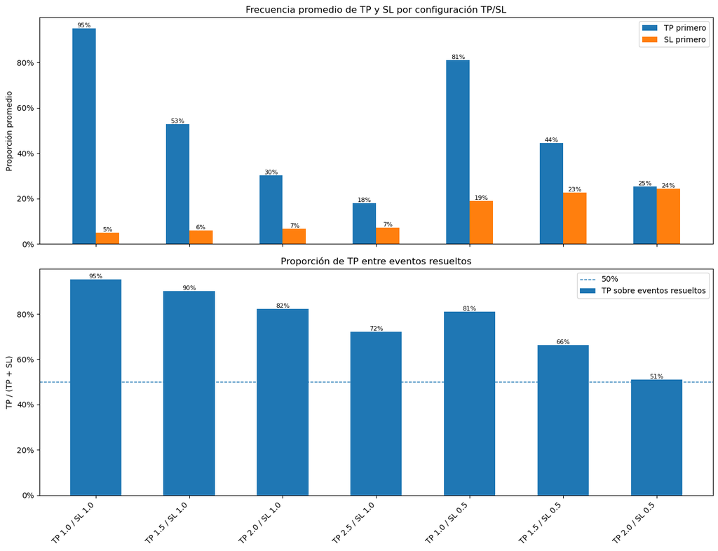

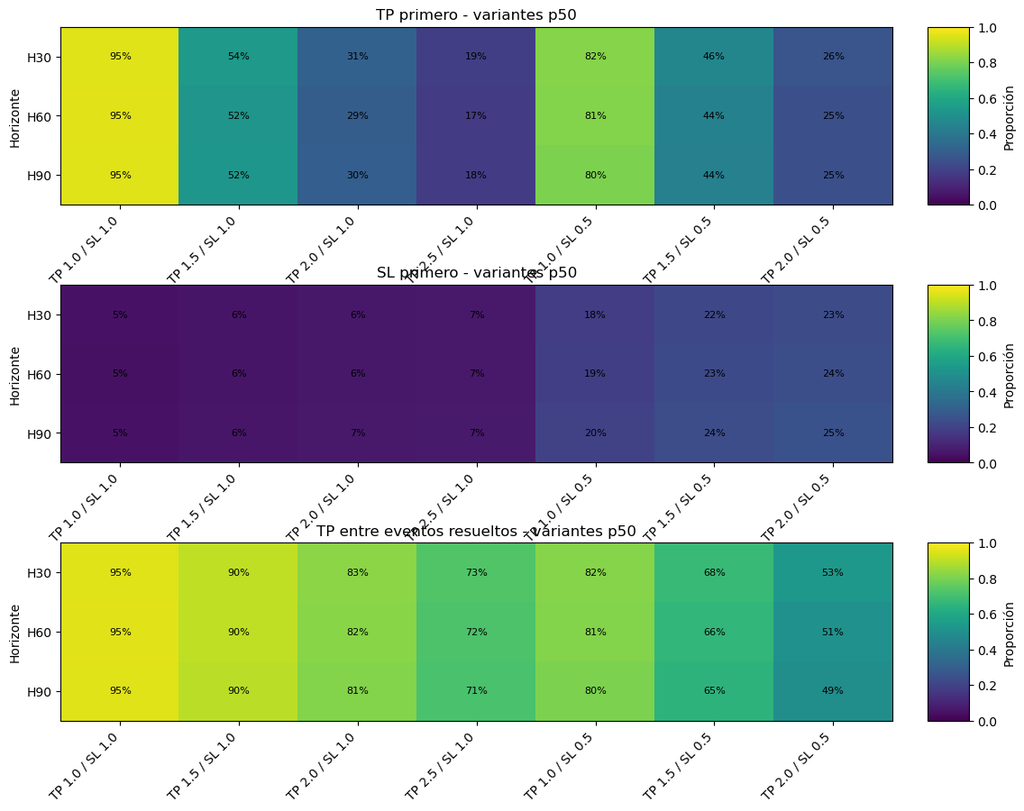

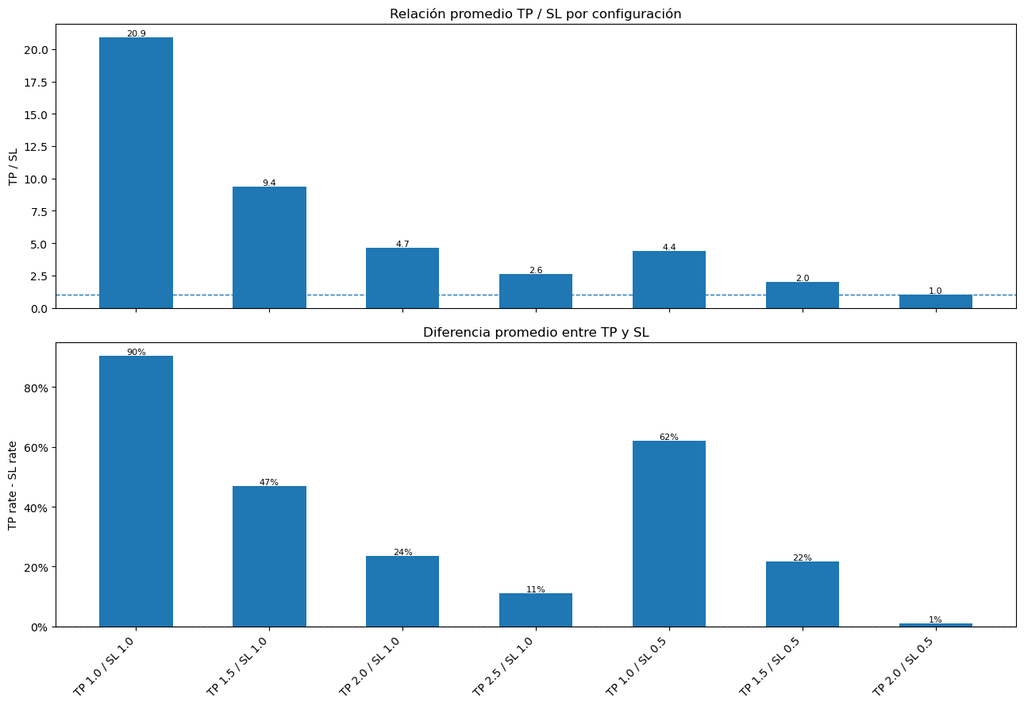

```
Celda 3 finalizada correctamente.
```

```python
# Celda 3 — Gráficos agrupados
# ============================================================

print("Gráficos agrupados de frecuencia TP/SL - BAR")
print("=" * 80)

# ------------------------------------------------------------
# Validar objetos necesarios
# ------------------------------------------------------------

if "df_bar_tp_sl_by_config" not in globals():
    raise NameError("No existe df_bar_tp_sl_by_config. Primero debes correr la Celda 2.")

if "df_bar_tp_sl_frequency" not in globals():
    raise NameError("No existe df_bar_tp_sl_frequency. Primero debes correr la Celda 1.")

if "df_bar_tp_sl_p50" not in globals():
    raise NameError("No existe df_bar_tp_sl_p50. Primero debes correr la Celda 2.")

# ------------------------------------------------------------
# Orden de configuraciones TP/SL
# ------------------------------------------------------------

config_order = [
    (1.0, 1.0),
    (1.5, 1.0),
    (2.0, 1.0),
    (2.5, 1.0),
    (1.0, 0.5),
    (1.5, 0.5),
    (2.0, 0.5),
]

config_labels = [
    f"TP {tp} / SL {sl}"
    for tp, sl in config_order
]

df_config_plot = df_bar_tp_sl_by_config.copy()

df_config_plot["config_order"] = df_config_plot.apply(
    lambda row: config_order.index((row["tp_mult"], row["sl_mult"]))
    if (row["tp_mult"], row["sl_mult"]) in config_order
    else 999,
    axis=1
)

df_config_plot = (
    df_config_plot
    .sort_values("config_order")
    .reset_index(drop=True)
)

# ============================================================
# Figura 1 — TP vs SL vs eventos resueltos por configuración
# ============================================================

x = np.arange(len(df_config_plot))
bar_width = 0.25

fig, axes = plt.subplots(
    nrows=2,
    ncols=1,
    figsize=(13, 10),
    sharex=True
)

# ------------------------------------------------------------
# Gráfico 1A — TP y SL globales
# ------------------------------------------------------------

axes[0].bar(
    x - bar_width / 2,
    df_config_plot["tp_rate_mean"],
    width=bar_width,
    label="TP primero"
)

axes[0].bar(
    x + bar_width / 2,
    df_config_plot["sl_rate_mean"],
    width=bar_width,
    label="SL primero"
)

axes[0].set_title("Frecuencia promedio de TP y SL por configuración TP/SL")
axes[0].set_ylabel("Proporción promedio")
axes[0].legend()

axes[0].yaxis.set_major_formatter(
    plt.FuncFormatter(lambda y, _: f"{y:.0%}")
)

for i, row in df_config_plot.iterrows():
    axes[0].text(
        i - bar_width / 2,
        row["tp_rate_mean"],
        f"{row['tp_rate_mean']:.0%}",
        ha="center",
        va="bottom",
        fontsize=8
    )

    axes[0].text(
        i + bar_width / 2,
        row["sl_rate_mean"],
        f"{row['sl_rate_mean']:.0%}",
        ha="center",
        va="bottom",
        fontsize=8
    )

# ------------------------------------------------------------
# Gráfico 1B — TP sobre eventos resueltos
# ------------------------------------------------------------

axes[1].bar(
    x,
    df_config_plot["tp_rate_resolved_only_mean"],
    width=0.55,
    label="TP sobre eventos resueltos"
)

axes[1].axhline(
    0.5,
    linestyle="--",
    linewidth=1,
    label="50%"
)

axes[1].set_title("Proporción de TP entre eventos resueltos")
axes[1].set_ylabel("TP / (TP + SL)")
axes[1].set_xticks(x)
axes[1].set_xticklabels(config_labels, rotation=45, ha="right")
axes[1].legend()

axes[1].yaxis.set_major_formatter(
    plt.FuncFormatter(lambda y, _: f"{y:.0%}")
)

for i, row in df_config_plot.iterrows():
    axes[1].text(
        i,
        row["tp_rate_resolved_only_mean"],
        f"{row['tp_rate_resolved_only_mean']:.0%}",
        ha="center",
        va="bottom",
        fontsize=8
    )

plt.tight_layout()
plt.show()

# ============================================================
# Figura 2 — Heatmaps p50 por horizonte y configuración
# ============================================================

df_p50_plot = df_bar_tp_sl_p50.copy()

df_p50_plot["config_label"] = df_p50_plot.apply(
    lambda row: f"TP {row['tp_mult']} / SL {row['sl_mult']}",
    axis=1
)

metrics_to_plot = [
    ("tp_rate", "TP primero"),
    ("sl_rate", "SL primero"),
    ("tp_rate_resolved_only", "TP entre eventos resueltos"),
]

fig = plt.figure(figsize=(13, 10))

gs = fig.add_gridspec(
    nrows=3,
    ncols=2,
    width_ratios=[20, 1],
    hspace=0.45,
    wspace=0.08
)

axes = [fig.add_subplot(gs[i, 0]) for i in range(3)]
caxes = [fig.add_subplot(gs[i, 1]) for i in range(3)]

for ax, cax, (metric_col, metric_title) in zip(axes, caxes, metrics_to_plot):
    pivot_tmp = df_p50_plot.pivot(
        index="horizon",
        columns="config_label",
        values=metric_col
    )

    ordered_columns = [
        label for label in config_labels
        if label in pivot_tmp.columns
    ]

    pivot_tmp = pivot_tmp.reindex(index=BAR_HORIZONS)
    pivot_tmp = pivot_tmp.reindex(columns=ordered_columns)

    data = np.ma.masked_invalid(pivot_tmp.values)

    im = ax.imshow(
        data,
        aspect="auto",
        vmin=0,
        vmax=1
    )

    ax.set_title(f"{metric_title} - variantes p50")
    ax.set_ylabel("Horizonte")

    ax.set_yticks(np.arange(len(pivot_tmp.index)))
    ax.set_yticklabels([f"H{h}" for h in pivot_tmp.index])

    ax.set_xticks(np.arange(len(pivot_tmp.columns)))
    ax.set_xticklabels(pivot_tmp.columns, rotation=45, ha="right")

    for i in range(pivot_tmp.shape[0]):
        for j in range(pivot_tmp.shape[1]):
            value = pivot_tmp.iloc[i, j]

            if pd.notna(value):
                ax.text(
                    j,
                    i,
                    f"{value:.0%}",
                    ha="center",
                    va="center",
                    fontsize=8
                )

    fig.colorbar(
        im,
        cax=cax,
        label="Proporción"
    )

plt.show()

# ============================================================
# Figura 3 — Relación TP/SL y diferencia TP - SL
# ============================================================

fig, axes = plt.subplots(
    nrows=2,
    ncols=1,
    figsize=(13, 9),
    sharex=True
)

# ------------------------------------------------------------
# Gráfico 3A — Ratio TP/SL observado
# ------------------------------------------------------------

axes[0].bar(
    x,
    df_config_plot["tp_to_sl_ratio_mean"],
    width=0.55
)

axes[0].axhline(
    1,
    linestyle="--",
    linewidth=1
)

axes[0].set_title("Relación promedio TP / SL por configuración")
axes[0].set_ylabel("TP / SL")

for i, row in df_config_plot.iterrows():
    axes[0].text(
        i,
        row["tp_to_sl_ratio_mean"],
        f"{row['tp_to_sl_ratio_mean']:.1f}",
        ha="center",
        va="bottom",
        fontsize=8
    )

# ------------------------------------------------------------
# Gráfico 3B — Diferencia TP - SL
# ------------------------------------------------------------

axes[1].bar(
    x,
    df_config_plot["tp_minus_sl_rate_mean"],
    width=0.55
)

axes[1].axhline(
    0,
    linestyle="--",
    linewidth=1
)

axes[1].set_title("Diferencia promedio entre TP y SL")
axes[1].set_ylabel("TP rate - SL rate")
axes[1].set_xticks(x)
axes[1].set_xticklabels(config_labels, rotation=45, ha="right")

axes[1].yaxis.set_major_formatter(
    plt.FuncFormatter(lambda y, _: f"{y:.0%}")
)

for i, row in df_config_plot.iterrows():
    axes[1].text(
        i,
        row["tp_minus_sl_rate_mean"],
        f"{row['tp_minus_sl_rate_mean']:.0%}",
        ha="center",
        va="bottom" if row["tp_minus_sl_rate_mean"] >= 0 else "top",
        fontsize=8
    )

plt.tight_layout()
plt.show()

print("\nCelda 3 finalizada correctamente.")
```

### Celda 4 — Tabla final para observaciones

```python
# Celda 4 — Guardado y tabla final para observaciones
# ============================================================

print("Guardado y tabla final de frecuencia TP/SL - BAR")
print("=" * 80)

# ------------------------------------------------------------
# Validar objetos necesarios
# ------------------------------------------------------------

required_objects = [
    "df_bar_tp_sl_frequency",
    "df_bar_tp_sl_by_config",
    "df_bar_tp_sl_by_target_base",
    "df_bar_tp_sl_p50",
    "df_bar_tp_sl_resolved_ranking",
    "df_bar_tp_sl_quality_counts",
]

missing_objects = [
    obj for obj in required_objects
    if obj not in globals()
]

if missing_objects:
    raise NameError(
        "Faltan objetos necesarios. "
        f"Debes correr las celdas anteriores: {missing_objects}"
    )

# ------------------------------------------------------------
# Definir rutas de guardado
# ------------------------------------------------------------

MNQ_TARGETS_BAR_TP_SL_FREQUENCY_CSV = (
    MNQ_TARGETS_PATH / "mnq_targets_bar_tp_sl_frequency.csv"
)

MNQ_TARGETS_BAR_TP_SL_BY_CONFIG_CSV = (
    MNQ_TARGETS_PATH / "mnq_targets_bar_tp_sl_by_config.csv"
)

MNQ_TARGETS_BAR_TP_SL_BY_TARGET_BASE_CSV = (
    MNQ_TARGETS_PATH / "mnq_targets_bar_tp_sl_by_target_base.csv"
)

MNQ_TARGETS_BAR_TP_SL_RESOLVED_RANKING_CSV = (
    MNQ_TARGETS_PATH / "mnq_targets_bar_tp_sl_resolved_ranking.csv"
)

MNQ_TARGETS_BAR_TP_SL_REPORT_TXT = (
    MNQ_TARGETS_PATH / "mnq_targets_bar_tp_sl_report.txt"
)

# ------------------------------------------------------------
# Guardar tablas principales
# ------------------------------------------------------------

df_bar_tp_sl_frequency.to_csv(
    MNQ_TARGETS_BAR_TP_SL_FREQUENCY_CSV,
    index=False
)

df_bar_tp_sl_by_config.to_csv(
    MNQ_TARGETS_BAR_TP_SL_BY_CONFIG_CSV,
    index=False
)

df_bar_tp_sl_by_target_base.to_csv(
    MNQ_TARGETS_BAR_TP_SL_BY_TARGET_BASE_CSV,
    index=False
)

df_bar_tp_sl_resolved_ranking.to_csv(
    MNQ_TARGETS_BAR_TP_SL_RESOLVED_RANKING_CSV,
    index=False
)

# ------------------------------------------------------------
# Tabla compacta por configuración TP/SL
# ------------------------------------------------------------

tp_sl_config_cols = [
    "tp_sl_config",
    "tp_mult",
    "sl_mult",
    "n_targets",
    "tp_rate_mean",
    "sl_rate_mean",
    "no_event_rate_mean",
    "resolved_rate_mean",
    "tp_minus_sl_rate_mean",
    "tp_to_sl_ratio_mean",
    "tp_rate_resolved_only_mean",
    "sl_rate_resolved_only_mean",
    "expectancy_units_mean",
]

print("\nTabla compacta por configuración TP/SL:")
print(
    df_bar_tp_sl_by_config[tp_sl_config_cols]
    .to_string(
        index=False,
        formatters={
            "tp_rate_mean": "{:.2%}".format,
            "sl_rate_mean": "{:.2%}".format,
            "no_event_rate_mean": "{:.2%}".format,
            "resolved_rate_mean": "{:.2%}".format,
            "tp_minus_sl_rate_mean": "{:.2%}".format,
            "tp_to_sl_ratio_mean": "{:.2f}".format,
            "tp_rate_resolved_only_mean": "{:.2%}".format,
            "sl_rate_resolved_only_mean": "{:.2%}".format,
            "expectancy_units_mean": "{:.3f}".format,
        }
    )
)

# ------------------------------------------------------------
# Tabla compacta de variantes p50
# ------------------------------------------------------------

p50_tp_sl_cols = [
    "bar_col",
    "horizon",
    "tp_mult",
    "sl_mult",
    "tp_rate",
    "sl_rate",
    "no_event_rate",
    "resolved_rate",
    "tp_minus_sl_rate",
    "tp_to_sl_ratio",
    "tp_rate_resolved_only",
    "sl_rate_resolved_only",
    "expectancy_units",
    "tp_sl_quality",
]

print("\nTabla compacta de frecuencia TP/SL para variantes p50:")
print(
    df_bar_tp_sl_p50[p50_tp_sl_cols]
    .to_string(
        index=False,
        formatters={
            "tp_rate": "{:.2%}".format,
            "sl_rate": "{:.2%}".format,
            "no_event_rate": "{:.2%}".format,
            "resolved_rate": "{:.2%}".format,
            "tp_minus_sl_rate": "{:.2%}".format,
            "tp_to_sl_ratio": "{:.2f}".format,
            "tp_rate_resolved_only": "{:.2%}".format,
            "sl_rate_resolved_only": "{:.2%}".format,
            "expectancy_units": "{:.3f}".format,
        }
    )
)

# ------------------------------------------------------------
# Top 20 por proporción TP entre eventos resueltos
# ------------------------------------------------------------

resolved_ranking_cols = [
    "bar_col",
    "horizon",
    "percentile",
    "tp_mult",
    "sl_mult",
    "tp_rate",
    "sl_rate",
    "no_event_rate",
    "resolved_rate",
    "tp_rate_resolved_only",
    "tp_to_sl_ratio",
    "expectancy_units",
    "tp_sl_quality",
]

print("\nTop 20 por proporción de TP entre eventos resueltos:")
print(
    df_bar_tp_sl_resolved_ranking[resolved_ranking_cols]
    .head(20)
    .to_string(
        index=False,
        formatters={
            "tp_rate": "{:.2%}".format,
            "sl_rate": "{:.2%}".format,
            "no_event_rate": "{:.2%}".format,
            "resolved_rate": "{:.2%}".format,
            "tp_rate_resolved_only": "{:.2%}".format,
            "tp_to_sl_ratio": "{:.2f}".format,
            "expectancy_units": "{:.3f}".format,
        }
    )
)

# ------------------------------------------------------------
# Conteo por clasificación preliminar
# ------------------------------------------------------------

print("\nConteo por clasificación preliminar TP/SL:")
print(
    df_bar_tp_sl_quality_counts
    .to_string(
        index=False,
        formatters={
            "tp_rate_mean": "{:.2%}".format,
            "sl_rate_mean": "{:.2%}".format,
            "no_event_rate_mean": "{:.2%}".format,
            "tp_rate_resolved_only_mean": "{:.2%}".format,
            "expectancy_units_mean": "{:.3f}".format,
        }
    )
)

# ------------------------------------------------------------
# Guardar reporte TXT completo
# ------------------------------------------------------------

with MNQ_TARGETS_BAR_TP_SL_REPORT_TXT.open("w", encoding="utf-8") as f:
    f.write("4.7. Frecuencia de TP y SL - BAR\n")
    f.write("=" * 100 + "\n\n")

    f.write("Tabla compacta por configuración TP/SL\n")
    f.write("-" * 100 + "\n")
    f.write(
        df_bar_tp_sl_by_config[tp_sl_config_cols]
        .to_string(
            index=False,
            formatters={
                "tp_rate_mean": "{:.2%}".format,
                "sl_rate_mean": "{:.2%}".format,
                "no_event_rate_mean": "{:.2%}".format,
                "resolved_rate_mean": "{:.2%}".format,
                "tp_minus_sl_rate_mean": "{:.2%}".format,
                "tp_to_sl_ratio_mean": "{:.2f}".format,
                "tp_rate_resolved_only_mean": "{:.2%}".format,
                "sl_rate_resolved_only_mean": "{:.2%}".format,
                "expectancy_units_mean": "{:.3f}".format,
            }
        )
    )

    f.write("\n\n")
    f.write("Tabla compacta de frecuencia TP/SL para variantes p50\n")
    f.write("-" * 100 + "\n")
    f.write(
        df_bar_tp_sl_p50[p50_tp_sl_cols]
        .to_string(
            index=False,
            formatters={
                "tp_rate": "{:.2%}".format,
                "sl_rate": "{:.2%}".format,
                "no_event_rate": "{:.2%}".format,
                "resolved_rate": "{:.2%}".format,
                "tp_minus_sl_rate": "{:.2%}".format,
                "tp_to_sl_ratio": "{:.2f}".format,
                "tp_rate_resolved_only": "{:.2%}".format,
                "sl_rate_resolved_only": "{:.2%}".format,
                "expectancy_units": "{:.3f}".format,
            }
        )
    )

    f.write("\n\n")
    f.write("Top 20 por proporción de TP entre eventos resueltos\n")
    f.write("-" * 100 + "\n")
    f.write(
        df_bar_tp_sl_resolved_ranking[resolved_ranking_cols]
        .head(20)
        .to_string(
            index=False,
            formatters={
                "tp_rate": "{:.2%}".format,
                "sl_rate": "{:.2%}".format,
                "no_event_rate": "{:.2%}".format,
                "resolved_rate": "{:.2%}".format,
                "tp_rate_resolved_only": "{:.2%}".format,
                "tp_to_sl_ratio": "{:.2f}".format,
                "expectancy_units": "{:.3f}".format,
            }
        )
    )

    f.write("\n\n")
    f.write("Conteo por clasificación preliminar TP/SL\n")
    f.write("-" * 100 + "\n")
    f.write(
        df_bar_tp_sl_quality_counts
        .to_string(
            index=False,
            formatters={
                "tp_rate_mean": "{:.2%}".format,
                "sl_rate_mean": "{:.2%}".format,
                "no_event_rate_mean": "{:.2%}".format,
                "tp_rate_resolved_only_mean": "{:.2%}".format,
                "expectancy_units_mean": "{:.3f}".format,
            }
        )
    )

# ------------------------------------------------------------
# Confirmación final
# ------------------------------------------------------------

print("\nArchivos guardados:")
print(f"Frecuencia TP/SL BAR:          {MNQ_TARGETS_BAR_TP_SL_FREQUENCY_CSV}")
print(f"Resumen TP/SL por configuración:{MNQ_TARGETS_BAR_TP_SL_BY_CONFIG_CSV}")
print(f"Resumen TP/SL por target base:  {MNQ_TARGETS_BAR_TP_SL_BY_TARGET_BASE_CSV}")
print(f"Ranking TP/SL resuelto:         {MNQ_TARGETS_BAR_TP_SL_RESOLVED_RANKING_CSV}")
print(f"Reporte TXT:                    {MNQ_TARGETS_BAR_TP_SL_REPORT_TXT}")

print("\nCelda 4 finalizada correctamente.")
```

```
Guardado y tabla final de frecuencia TP/SL - BAR
================================================================================

Tabla compacta por configuración TP/SL:
   tp_sl_config  tp_mult  sl_mult  n_targets tp_rate_mean sl_rate_mean no_event_rate_mean resolved_rate_mean tp_minus_sl_rate_mean tp_to_sl_ratio_mean tp_rate_resolved_only_mean sl_rate_resolved_only_mean expectancy_units_mean
TP 1.0 / SL 0.5      1.0      0.5          9       81.07%       18.93%              0.00%            100.00%                62.15%                4.38                     81.07%                     18.93%                 0.716
TP 1.5 / SL 0.5      1.5      0.5          9       44.39%       22.71%             32.89%             67.11%                21.68%                1.98                     66.29%                     33.71%                 0.552
TP 2.0 / SL 0.5      2.0      0.5          9       25.21%       24.24%             50.55%             49.45%                 0.97%                1.05                     51.08%                     48.92%                 0.383
TP 1.0 / SL 1.0      1.0      1.0          9       95.18%        4.82%              0.00%            100.00%                90.36%               20.89                     95.18%                      4.82%                 0.904
TP 1.5 / SL 1.0      1.5      1.0          9       52.73%        5.85%             41.42%             58.58%                46.89%                9.36                     90.13%                      9.87%                 0.733
TP 2.0 / SL 1.0      2.0      1.0          9       30.26%        6.65%             63.10%             36.90%                23.61%                4.66                     82.20%                     17.80%                 0.539
TP 2.5 / SL 1.0      2.5      1.0          9       18.02%        7.06%             74.92%             25.08%                10.96%                2.59                     72.07%                     27.93%                 0.380

Tabla compacta de frecuencia TP/SL para variantes p50:
              bar_col  horizon  tp_mult  sl_mult tp_rate sl_rate no_event_rate resolved_rate tp_minus_sl_rate tp_to_sl_ratio tp_rate_resolved_only sl_rate_resolved_only expectancy_units tp_sl_quality
bar_p50_h30_tp10_sl05       30      1.0      0.5  81.93%  18.07%         0.00%       100.00%           63.86%           4.53                81.93%                18.07%            0.729     favorable
bar_p50_h30_tp15_sl05       30      1.5      0.5  45.74%  21.67%        32.60%        67.40%           24.07%           2.11                67.85%                32.15%            0.578      moderada
bar_p50_h30_tp20_sl05       30      2.0      0.5  26.31%  23.19%        50.50%        49.50%            3.12%           1.13                53.15%                46.85%            0.410         débil
bar_p50_h30_tp10_sl10       30      1.0      1.0  95.26%   4.74%         0.00%       100.00%           90.52%          20.10                95.26%                 4.74%            0.905 muy_favorable
bar_p50_h30_tp15_sl10       30      1.5      1.0  53.60%   5.71%        40.70%        59.30%           47.89%           9.39                90.38%                 9.62%            0.747 muy_favorable
bar_p50_h30_tp20_sl10       30      2.0      1.0  31.07%   6.49%        62.44%        37.56%           24.58%           4.79                82.73%                17.27%            0.557     favorable
bar_p50_h30_tp25_sl10       30      2.5      1.0  18.63%   6.90%        74.47%        25.53%           11.73%           2.70                72.97%                27.03%            0.397      moderada
bar_p50_h60_tp10_sl05       60      1.0      0.5  81.32%  18.68%         0.00%       100.00%           62.64%           4.35                81.32%                18.68%            0.720     favorable
bar_p50_h60_tp15_sl05       60      1.5      0.5  44.00%  22.52%        33.48%        66.52%           21.48%           1.95                66.15%                33.85%            0.547      moderada
bar_p50_h60_tp20_sl05       60      2.0      0.5  24.58%  23.99%        51.44%        48.56%            0.59%           1.02                50.61%                49.39%            0.372         débil
bar_p50_h60_tp10_sl10       60      1.0      1.0  95.45%   4.55%         0.00%       100.00%           90.91%          21.00                95.45%                 4.55%            0.909 muy_favorable
```

[output cut: 49 more lines]

### Observaciones preliminares — Frecuencia de TP y SL

El análisis de frecuencia de TP y SL muestra que las configuraciones evaluadas presentan comportamientos muy distintos según la distancia del Take Profit y del Stop Loss.

En primer lugar, `TP 1.0 / SL 1.0` vuelve a aparecer como la configuración más favorable en términos brutos. En promedio, alcanza TP primero en el `95.18%` de los casos, con solo `4.82%` de SL y sin casos `no_event`. Sin embargo, esta configuración debe interpretarse principalmente como benchmark, ya que el TP coincide con el threshold base utilizado para construir `DIR`.

La configuración `TP 1.0 / SL 0.5` también resuelve el 100% de los casos, pero presenta una proporción de SL mucho mayor. Esto ocurre porque el Stop Loss está más cerca del precio de entrada. Aunque mantiene un TP promedio alto, cercano al `81.07%`, el SL aumenta hasta `18.93%`, por lo que es más agresiva desde el punto de vista operativo.

La configuración `TP 1.5 / SL 1.0` aparece como una alternativa especialmente interesante. Aunque no resuelve todos los casos, mantiene una proporción favorable entre TP y SL. En promedio, alcanza TP primero en el `52.73%` de los casos y SL primero en solo `5.85%`. Entre los eventos que sí resuelven como TP o SL, el TP representa alrededor del `90.13%`. Esto sugiere que, cuando la operación resuelve, generalmente lo hace a favor.

Las configuraciones más exigentes, como `TP 2.0 / SL 1.0` y `TP 2.5 / SL 1.0`, mantienen una proporción favorable entre TP y SL cuando el evento ocurre, pero generan demasiados casos sin resolución. En particular, `TP 2.0 / SL 1.0` deja cerca de `63.10%` como `no_event`, mientras que `TP 2.5 / SL 1.0` deja cerca de `74.92%`. Por lo tanto, aunque no necesariamente son descartables, parecen menos prácticas para una primera selección operativa.

Las configuraciones con `SL = 0.5` muestran mayor sensibilidad al movimiento adverso. El caso `TP 2.0 / SL 0.5` es el más débil, ya que el TP y el SL quedan prácticamente equilibrados entre los eventos resueltos. Su `tp_rate_resolved_only` es cercano al `51.08%`, lo que indica que, cuando ocurre un evento, casi no hay ventaja clara entre TP y SL.

En las variantes `p50`, el comportamiento es bastante consistente entre `H30`, `H60` y `H90`. La configuración `TP 1.5 / SL 1.0` mantiene tasas de TP cercanas al `52%–54%`, SL alrededor del `5%–6%`, y una proporción de TP entre eventos resueltos cercana al `90%`. Esto refuerza su papel como candidata principal para análisis posteriores.

El ranking por proporción de TP entre eventos resueltos favorece principalmente a las configuraciones `TP 1.0 / SL 1.0` y luego a `TP 1.5 / SL 1.0`. Esto confirma que las señales `DIR` tienen una trayectoria favorable cuando se evalúan con barreras no excesivamente lejanas.

En síntesis, el análisis de frecuencia TP/SL sugiere mantener `TP 1.0 / SL 1.0` como benchmark, pero enfocar la atención principal en `TP 1.5 / SL 1.0`, ya que ofrece un equilibrio más realista entre exigencia, baja frecuencia de SL y alta proporción de TP entre eventos resueltos.

De forma preliminar, las configuraciones más relevantes para continuar son:

```
    Benchmark:
    TP 1.0 / SL 1.0

    Candidata principal:
    TP 1.5 / SL 1.0

    Candidata exigente:
    TP 2.0 / SL 1.0

    Comparación agresiva:
    TP 1.0 / SL 0.5
```

En simple: `TP 1.5 / SL 1.0` sigue siendo la mejor candidata práctica. `TP 1.0 / SL 1.0` se ve mejor en números, pero está demasiado pegada a la forma en que construimos `DIR`. `TP 2.0 / SL 1.0` podría seguir en análisis, pero genera demasiados casos sin resolución.

## 4.8. Tiempo hasta evento TP/SL

En este punto se analiza cuánto tarda cada target `BAR` en alcanzar un evento operativo.

El objetivo es estudiar, para cada configuración TP/SL, en qué barra futura ocurre primero el Take Profit o el Stop Loss. Esto permite diferenciar configuraciones que resuelven rápidamente de aquellas que requieren esperar gran parte del horizonte.

Este análisis es importante porque dos configuraciones pueden tener frecuencias similares de TP y SL, pero comportamientos operativos distintos si una resuelve rápido y otra tarda demasiado en alcanzar el evento.

Las columnas `event_step` serán utilizadas únicamente como diagnóstico del target. No deben ser utilizadas posteriormente como features de modelos predictivos, ya que contienen información futura.

### Celda 1 — Preparación de métricas de tiempo hasta evento

```python
# Celda 1 — Preparación de métricas de tiempo hasta evento
# ============================================================

print("4.8. Tiempo hasta evento TP/SL - BAR")
print("=" * 80)

# ------------------------------------------------------------
# Validar objetos necesarios
# ------------------------------------------------------------

if "df_targets_bar" not in globals():
    raise NameError("No existe df_targets_bar. Primero debes construir los targets BAR.")

if "df_bar_metadata" not in globals():
    raise NameError("No existe df_bar_metadata. Primero debes construir df_bar_metadata.")

# ------------------------------------------------------------
# Función auxiliar para resumir event_step
# ------------------------------------------------------------

def summarize_step_values(step_values):
    """
    Resume una serie de event_step.
    """

    step_values = pd.Series(step_values).dropna().astype(float)

    if len(step_values) == 0:
        return {
            "step_count": 0,
            "step_mean": np.nan,
            "step_median": np.nan,
            "step_q25": np.nan,
            "step_q75": np.nan,
            "step_min": np.nan,
            "step_max": np.nan,
        }

    return {
        "step_count": int(len(step_values)),
        "step_mean": step_values.mean(),
        "step_median": step_values.median(),
        "step_q25": step_values.quantile(0.25),
        "step_q75": step_values.quantile(0.75),
        "step_min": step_values.min(),
        "step_max": step_values.max(),
    }


# ------------------------------------------------------------
# Construir resumen de tiempo hasta evento
# ------------------------------------------------------------

event_time_rows = []

for _, meta in df_bar_metadata.iterrows():
    bar_col = meta["bar_col"]
    event_step_col = meta["event_step_col"]

    horizon = int(meta["horizon"])
    percentile = int(meta["percentile"])
    tp_mult = float(meta["tp_mult"])
    sl_mult = float(meta["sl_mult"])

    if bar_col not in df_targets_bar.columns:
        raise KeyError(f"No existe la columna BAR: {bar_col}")

    if event_step_col not in df_targets_bar.columns:
        raise KeyError(f"No existe la columna event_step: {event_step_col}")

    bar_series = df_targets_bar[bar_col]
    step_series = df_targets_bar[event_step_col]

    tp_mask = bar_series == 1
    sl_mask = bar_series == -1
    no_event_mask = bar_series == 0
    valid_mask = bar_series.notna()

    tp_steps = step_series.loc[tp_mask]
    sl_steps = step_series.loc[sl_mask]
    all_event_steps = step_series.loc[tp_mask | sl_mask]

    tp_summary = summarize_step_values(tp_steps)
    sl_summary = summarize_step_values(sl_steps)
    all_summary = summarize_step_values(all_event_steps)

    valid_rows = int(valid_mask.sum())
    tp_count = int(tp_mask.sum())
    sl_count = int(sl_mask.sum())
    no_event_count = int(no_event_mask.sum())
    event_count = tp_count + sl_count

    # Partes del horizonte
    early_limit = horizon / 3
    late_limit = 2 * horizon / 3

    if event_count > 0:
        all_steps_float = all_event_steps.dropna().astype(float)

        early_event_rate = (all_steps_float <= early_limit).mean()
        middle_event_rate = (
            (all_steps_float > early_limit)
            & (all_steps_float <= late_limit)
        ).mean()
        late_event_rate = (all_steps_float > late_limit).mean()
    else:
        early_event_rate = np.nan
        middle_event_rate = np.nan
        late_event_rate = np.nan

    event_time_rows.append(
        {
            "bar_col": bar_col,
            "event_step_col": event_step_col,
            "dir_col": meta["dir_col"],
            "horizon": horizon,
            "percentile": percentile,
            "tp_mult": tp_mult,
            "sl_mult": sl_mult,
            "tp_sl_config": f"TP {tp_mult} / SL {sl_mult}",

            "valid_rows": valid_rows,
            "tp_count": tp_count,
            "sl_count": sl_count,
            "no_event_count": no_event_count,
            "event_count": event_count,

            "tp_rate": tp_count / valid_rows if valid_rows > 0 else np.nan,
            "sl_rate": sl_count / valid_rows if valid_rows > 0 else np.nan,
            "no_event_rate": no_event_count / valid_rows if valid_rows > 0 else np.nan,
            "event_rate": event_count / valid_rows if valid_rows > 0 else np.nan,

            "event_step_mean": all_summary["step_mean"],
            "event_step_median": all_summary["step_median"],
            "event_step_q25": all_summary["step_q25"],
            "event_step_q75": all_summary["step_q75"],
            "event_step_min": all_summary["step_min"],
            "event_step_max": all_summary["step_max"],

            "tp_step_mean": tp_summary["step_mean"],
            "tp_step_median": tp_summary["step_median"],
            "tp_step_q25": tp_summary["step_q25"],
            "tp_step_q75": tp_summary["step_q75"],

            "sl_step_mean": sl_summary["step_mean"],
            "sl_step_median": sl_summary["step_median"],
            "sl_step_q25": sl_summary["step_q25"],
            "sl_step_q75": sl_summary["step_q75"],

            "early_event_rate": early_event_rate,
            "middle_event_rate": middle_event_rate,
            "late_event_rate": late_event_rate,
        }
    )

df_bar_event_time = pd.DataFrame(event_time_rows)

df_bar_event_time = (
    df_bar_event_time
    .sort_values(["percentile", "horizon", "sl_mult", "tp_mult"])
    .reset_index(drop=True)
)

# ------------------------------------------------------------
# Vista inicial
# ------------------------------------------------------------

print(f"Targets BAR analizados: {len(df_bar_event_time)}")

print("\nVista inicial de tiempo hasta evento:")
print(
    df_bar_event_time[
        [
            "bar_col",
            "horizon",
            "percentile",
            "tp_mult",
            "sl_mult",
            "event_rate",
            "tp_rate",
            "sl_rate",
            "no_event_rate",
            "event_step_mean",
            "event_step_median",
            "tp_step_mean",
            "sl_step_mean",
            "early_event_rate",
            "middle_event_rate",
            "late_event_rate",
        ]
    ]
    .head(21)
    .to_string(
        index=False,
        formatters={
            "event_rate": "{:.2%}".format,
            "tp_rate": "{:.2%}".format,
            "sl_rate": "{:.2%}".format,
            "no_event_rate": "{:.2%}".format,
            "event_step_mean": "{:.2f}".format,
            "event_step_median": "{:.2f}".format,
            "tp_step_mean": "{:.2f}".format,
            "sl_step_mean": "{:.2f}".format,
            "early_event_rate": "{:.2%}".format,
            "middle_event_rate": "{:.2%}".format,
            "late_event_rate": "{:.2%}".format,
        }
    )
)

print("\nPreparación de métricas de tiempo hasta evento finalizada correctamente.")
```

```
4.8. Tiempo hasta evento TP/SL - BAR
================================================================================
Targets BAR analizados: 63

Vista inicial de tiempo hasta evento:
              bar_col  horizon  percentile  tp_mult  sl_mult event_rate tp_rate sl_rate no_event_rate event_step_mean event_step_median tp_step_mean sl_step_mean early_event_rate middle_event_rate late_event_rate
bar_p40_h30_tp10_sl05       30          40      1.0      0.5    100.00%  78.98%  21.02%         0.00%           11.18              9.00        12.72         5.39           55.06%            29.29%          15.65%
bar_p40_h30_tp15_sl05       30          40      1.5      0.5     73.21%  48.14%  25.07%        26.79%           12.46             11.00        14.86         7.85           48.61%            30.00%          21.39%
bar_p40_h30_tp20_sl05       30          40      2.0      0.5     56.62%  29.68%  26.94%        43.38%           12.70             11.00        16.26         8.78           48.01%            28.26%          23.74%
bar_p40_h30_tp10_sl10       30          40      1.0      1.0    100.00%  93.84%   6.16%         0.00%           13.20             12.00        13.61         6.99           44.23%            33.99%          21.78%
bar_p40_h30_tp15_sl10       30          40      1.5      1.0     64.87%  57.52%   7.35%        35.13%           14.83             14.00        15.55         9.23           35.76%            36.12%          28.12%
bar_p40_h30_tp20_sl10       30          40      2.0      1.0     43.97%  35.63%   8.35%        56.03%           15.66             15.00        16.81        10.78           32.03%            35.73%          32.24%
bar_p40_h30_tp25_sl10       30          40      2.5      1.0     31.51%  22.59%   8.92%        68.49%           15.97             16.00        17.71        11.56           31.32%            34.13%          34.54%
bar_p40_h60_tp10_sl05       60          40      1.0      0.5    100.00%  77.94%  22.06%         0.00%           21.95             18.00        25.27        10.22           54.96%            28.94%          16.10%
bar_p40_h60_tp15_sl05       60          40      1.5      0.5     72.88%  46.45%  26.43%        27.12%           24.35             21.00        29.59        15.15           48.90%            29.53%          21.57%
bar_p40_h60_tp20_sl05       60          40      2.0      0.5     56.15%  27.84%  28.31%        43.85%           24.57             21.00        32.35        16.92           49.08%            27.40%          23.52%
bar_p40_h60_tp10_sl10       60          40      1.0      1.0    100.00%  94.00%   6.00%         0.00%           26.19             24.00        27.01        13.34           43.64%            33.89%          22.47%
bar_p40_h60_tp15_sl10       60          40      1.5      1.0     63.61%  56.30%   7.31%        36.39%           29.41             28.00        30.86        18.22           35.18%            36.11%          28.71%
bar_p40_h60_tp20_sl10       60          40      2.0      1.0     42.39%  34.08%   8.30%        57.61%           31.05             30.00        33.41        21.37           31.74%            35.36%          32.90%
bar_p40_h60_tp25_sl10       60          40      2.5      1.0     29.89%  21.05%   8.84%        70.11%           31.48             31.00        35.13        22.78           31.37%            33.80%          34.83%
bar_p40_h90_tp10_sl05       90          40      1.0      0.5    100.00%  77.10%  22.90%         0.00%           32.93             27.00        38.07        15.60           54.24%            29.44%          16.32%
bar_p40_h90_tp15_sl05       90          40      1.5      0.5     72.84%  45.52%  27.32%        27.16%           36.63             32.00        44.92        22.83           48.55%            29.16%          22.30%
bar_p40_h90_tp20_sl05       90          40      2.0      0.5     56.66%  27.45%  29.21%        43.34%           37.08             32.00        49.45        25.44           48.52%            26.84%          24.64%
bar_p40_h90_tp10_sl10       90          40      1.0      1.0    100.00%  93.57%   6.43%         0.00%           39.52             36.00        40.74        21.79           42.61%            34.26%          23.13%
bar_p40_h90_tp15_sl10       90          40      1.5      1.0     63.74%  55.98%   7.76%        36.26%           44.77             43.00        47.01        28.64           34.15%            35.43%          30.42%
bar_p40_h90_tp20_sl10       90          40      2.0      1.0     42.92%  34.09%   8.83%        57.08%           47.51             47.00        51.17        33.35           30.35%            34.28%          35.37%
bar_p40_h90_tp25_sl10       90          40      2.5      1.0     30.62%  21.19%   9.43%        69.38%           48.34             49.00        54.00        35.62           30.03%            32.41%          37.56%

Preparación de métricas de tiempo hasta evento finalizada correctamente.
```

### Celda 2 — Tablas agregadas

```python
# Celda 2 — Tablas agregadas
# ============================================================

print("Tablas agregadas de tiempo hasta evento - BAR")
print("=" * 80)

# ------------------------------------------------------------
# Validar tabla base
# ------------------------------------------------------------

if "df_bar_event_time" not in globals():
    raise NameError("No existe df_bar_event_time. Primero debes correr la Celda 1.")

# ------------------------------------------------------------
# 1. Resumen por configuración TP/SL
# ------------------------------------------------------------

df_bar_event_time_by_config = (
    df_bar_event_time
    .groupby(["tp_mult", "sl_mult", "tp_sl_config"], as_index=False)
    .agg(
        n_targets=("bar_col", "count"),

        event_rate_mean=("event_rate", "mean"),
        tp_rate_mean=("tp_rate", "mean"),
        sl_rate_mean=("sl_rate", "mean"),
        no_event_rate_mean=("no_event_rate", "mean"),

        event_step_mean=("event_step_mean", "mean"),
        event_step_median=("event_step_median", "mean"),
        event_step_q25=("event_step_q25", "mean"),
        event_step_q75=("event_step_q75", "mean"),

        tp_step_mean=("tp_step_mean", "mean"),
        tp_step_median=("tp_step_median", "mean"),

        sl_step_mean=("sl_step_mean", "mean"),
        sl_step_median=("sl_step_median", "mean"),

        early_event_rate_mean=("early_event_rate", "mean"),
        middle_event_rate_mean=("middle_event_rate", "mean"),
        late_event_rate_mean=("late_event_rate", "mean"),
    )
    .sort_values(["sl_mult", "tp_mult"])
    .reset_index(drop=True)
)

print("\nResumen por configuración TP/SL:")
print(
    df_bar_event_time_by_config.to_string(
        index=False,
        formatters={
            "event_rate_mean": "{:.2%}".format,
            "tp_rate_mean": "{:.2%}".format,
            "sl_rate_mean": "{:.2%}".format,
            "no_event_rate_mean": "{:.2%}".format,
            "event_step_mean": "{:.2f}".format,
            "event_step_median": "{:.2f}".format,
            "event_step_q25": "{:.2f}".format,
            "event_step_q75": "{:.2f}".format,
            "tp_step_mean": "{:.2f}".format,
            "tp_step_median": "{:.2f}".format,
            "sl_step_mean": "{:.2f}".format,
            "sl_step_median": "{:.2f}".format,
            "early_event_rate_mean": "{:.2%}".format,
            "middle_event_rate_mean": "{:.2%}".format,
            "late_event_rate_mean": "{:.2%}".format,
        }
    )
)

# ------------------------------------------------------------
# 2. Resumen por percentil y horizonte
# ------------------------------------------------------------

df_bar_event_time_by_target_base = (
    df_bar_event_time
    .groupby(["percentile", "horizon"], as_index=False)
    .agg(
        n_configs=("bar_col", "count"),

        event_rate_mean=("event_rate", "mean"),
        tp_rate_mean=("tp_rate", "mean"),
        sl_rate_mean=("sl_rate", "mean"),
        no_event_rate_mean=("no_event_rate", "mean"),

        event_step_mean=("event_step_mean", "mean"),
        event_step_median=("event_step_median", "mean"),

        tp_step_mean=("tp_step_mean", "mean"),
        sl_step_mean=("sl_step_mean", "mean"),

        early_event_rate_mean=("early_event_rate", "mean"),
        middle_event_rate_mean=("middle_event_rate", "mean"),
        late_event_rate_mean=("late_event_rate", "mean"),
    )
    .sort_values(["percentile", "horizon"])
    .reset_index(drop=True)
)

print("\nResumen por percentil y horizonte:")
print(
    df_bar_event_time_by_target_base.to_string(
        index=False,
        formatters={
            "event_rate_mean": "{:.2%}".format,
            "tp_rate_mean": "{:.2%}".format,
            "sl_rate_mean": "{:.2%}".format,
            "no_event_rate_mean": "{:.2%}".format,
            "event_step_mean": "{:.2f}".format,
            "event_step_median": "{:.2f}".format,
            "tp_step_mean": "{:.2f}".format,
            "sl_step_mean": "{:.2f}".format,
            "early_event_rate_mean": "{:.2%}".format,
            "middle_event_rate_mean": "{:.2%}".format,
            "late_event_rate_mean": "{:.2%}".format,
        }
    )
)

# ------------------------------------------------------------
# 3. Detalle de variantes centrales p50
# ------------------------------------------------------------

df_bar_event_time_p50 = (
    df_bar_event_time[
        df_bar_event_time["percentile"] == 50
    ]
    .copy()
    .sort_values(["horizon", "sl_mult", "tp_mult"])
    .reset_index(drop=True)
)

print("\nDetalle de tiempo hasta evento para variantes p50:")
print(
    df_bar_event_time_p50[
        [
            "bar_col",
            "horizon",
            "tp_mult",
            "sl_mult",

            "event_rate",
            "tp_rate",
            "sl_rate",
            "no_event_rate",

            "event_step_mean",
            "event_step_median",
            "event_step_q25",
            "event_step_q75",

            "tp_step_mean",
            "tp_step_median",
            "sl_step_mean",
            "sl_step_median",

            "early_event_rate",
            "middle_event_rate",
            "late_event_rate",
        ]
    ]
    .to_string(
        index=False,
        formatters={
            "event_rate": "{:.2%}".format,
            "tp_rate": "{:.2%}".format,
            "sl_rate": "{:.2%}".format,
            "no_event_rate": "{:.2%}".format,
            "event_step_mean": "{:.2f}".format,
            "event_step_median": "{:.2f}".format,
            "event_step_q25": "{:.2f}".format,
            "event_step_q75": "{:.2f}".format,
            "tp_step_mean": "{:.2f}".format,
            "tp_step_median": "{:.2f}".format,
            "sl_step_mean": "{:.2f}".format,
            "sl_step_median": "{:.2f}".format,
            "early_event_rate": "{:.2%}".format,
            "middle_event_rate": "{:.2%}".format,
            "late_event_rate": "{:.2%}".format,
        }
    )
)

# ------------------------------------------------------------
# 4. Ranking por resolución rápida
# ------------------------------------------------------------
# early_event_rate mide qué proporción de eventos ocurre
# dentro del primer tercio del horizonte.
# ------------------------------------------------------------

df_bar_event_time_fast_ranking = (
    df_bar_event_time
    .copy()
    .sort_values(
        ["early_event_rate", "event_rate", "tp_rate"],
        ascending=[False, False, False]
    )
    .reset_index(drop=True)
)

print("\nTop 20 variantes con eventos más tempranos:")
print(
    df_bar_event_time_fast_ranking[
        [
            "bar_col",
            "horizon",
            "percentile",
            "tp_mult",
            "sl_mult",
            "event_rate",
            "tp_rate",
            "sl_rate",
            "no_event_rate",
            "event_step_mean",
            "event_step_median",
            "early_event_rate",
            "middle_event_rate",
            "late_event_rate",
        ]
    ]
    .head(20)
    .to_string(
        index=False,
        formatters={
            "event_rate": "{:.2%}".format,
            "tp_rate": "{:.2%}".format,
            "sl_rate": "{:.2%}".format,
            "no_event_rate": "{:.2%}".format,
            "event_step_mean": "{:.2f}".format,
            "event_step_median": "{:.2f}".format,
            "early_event_rate": "{:.2%}".format,
            "middle_event_rate": "{:.2%}".format,
            "late_event_rate": "{:.2%}".format,
        }
    )
)

# ------------------------------------------------------------
# 5. Ranking por eventos más lentos
# ------------------------------------------------------------

df_bar_event_time_slow_ranking = (
    df_bar_event_time
    .copy()
    .sort_values(
        ["late_event_rate", "event_step_mean", "event_rate"],
        ascending=[False, False, False]
    )
    .reset_index(drop=True)
)

print("\nTop 20 variantes con eventos más tardíos:")
print(
    df_bar_event_time_slow_ranking[
        [
            "bar_col",
            "horizon",
            "percentile",
            "tp_mult",
            "sl_mult",
            "event_rate",
            "tp_rate",
            "sl_rate",
            "no_event_rate",
            "event_step_mean",
            "event_step_median",
            "early_event_rate",
            "middle_event_rate",
            "late_event_rate",
        ]
    ]
    .head(20)
    .to_string(
        index=False,
        formatters={
            "event_rate": "{:.2%}".format,
            "tp_rate": "{:.2%}".format,
            "sl_rate": "{:.2%}".format,
            "no_event_rate": "{:.2%}".format,
            "event_step_mean": "{:.2f}".format,
            "event_step_median": "{:.2f}".format,
            "early_event_rate": "{:.2%}".format,
            "middle_event_rate": "{:.2%}".format,
            "late_event_rate": "{:.2%}".format,
        }
    )
)

print("\nCelda 2 finalizada correctamente.")
```

```
Tablas agregadas de tiempo hasta evento - BAR
================================================================================

Resumen por configuración TP/SL:
 tp_mult  sl_mult    tp_sl_config  n_targets event_rate_mean tp_rate_mean sl_rate_mean no_event_rate_mean event_step_mean event_step_median event_step_q25 event_step_q75 tp_step_mean tp_step_median sl_step_mean sl_step_median early_event_rate_mean middle_event_rate_mean late_event_rate_mean
     1.0      0.5 TP 1.0 / SL 0.5          9         100.00%       81.07%       18.93%              0.00%           24.41             21.22          10.78          36.67        27.54          25.44        11.10           8.00                48.43%                 31.55%               20.02%
     1.5      0.5 TP 1.5 / SL 0.5          9          67.11%       44.39%       22.71%             32.89%           26.43             24.22          11.11          40.89        31.72          31.11        16.23          10.22                43.88%                 30.75%               25.37%
     2.0      0.5 TP 2.0 / SL 0.5          9          49.45%       25.21%       24.24%             50.55%           26.20             23.44           9.56          41.89        34.35          34.56        17.90          11.11                45.29%                 28.03%               26.68%
     1.0      1.0 TP 1.0 / SL 1.0          9         100.00%       95.18%        4.82%              0.00%           28.32             26.56          14.33          41.44        28.99          27.67        14.94          12.00                38.24%                 35.56%               26.20%
     1.5      1.0 TP 1.5 / SL 1.0          9          58.58%       52.73%        5.85%             41.42%           31.56             31.11          18.11          45.31        32.84          32.56        19.93          14.78                30.43%                 36.55%               33.02%
     2.0      1.0 TP 2.0 / SL 1.0          9          36.90%       30.26%        6.65%             63.10%           33.08             33.44          19.44          47.33        35.27          36.00        23.05          17.00                27.52%                 35.33%               37.15%
     2.5      1.0 TP 2.5 / SL 1.0          9          25.08%       18.02%        7.06%             74.92%           33.39             34.33          19.00          48.44        36.93          38.56        24.40          18.89                27.88%                 33.11%               39.02%

Resumen por percentil y horizonte:
 percentile  horizon  n_configs event_rate_mean tp_rate_mean sl_rate_mean no_event_rate_mean event_step_mean event_step_median tp_step_mean sl_step_mean early_event_rate_mean middle_event_rate_mean late_event_rate_mean
         40       30          7          67.17%       52.34%       14.83%             32.83%           13.71             12.57        15.36         8.65                42.15%                 32.50%               25.35%
         40       60          7          66.42%       51.09%       15.32%             33.58%           27.00             24.71        30.52        16.86                42.12%                 32.15%               25.73%
         40       90          7          66.68%       50.70%       15.98%             33.32%           40.97             38.00        46.48        26.18                41.21%                 31.69%               27.10%
         50       30          7          62.76%       50.36%       12.40%             37.24%           14.62             13.86        16.24         9.10                37.57%                 33.63%               28.80%
         50       60          7          61.81%       49.20%       12.61%             38.19%           28.81             27.43        32.26        17.69                37.54%                 33.32%               29.14%
         50       90          7          62.39%       49.04%       13.36%             37.61%           43.86             42.14        49.24        27.85                36.55%                 32.48%               30.97%
         60       30          7          58.58%       48.39%       10.19%             41.42%           15.47             15.29        17.05         9.51                33.40%                 34.32%               32.28%
         60       60          7          57.75%       47.41%       10.34%             42.25%           30.42             29.71        33.76        18.47                33.57%                 33.99%               32.43%
         60       90          7          58.45%       47.43%       11.02%             41.55%           46.64             46.14        51.78        29.67                32.30%                 32.77%               34.93%

Detalle de tiempo hasta evento para variantes p50:
```

[output cut: 70 more lines]

### Celda 3 — Gráficos agrupados

```
Gráficos agrupados por percentil y horizonte - Tiempo hasta evento BAR
================================================================================
```

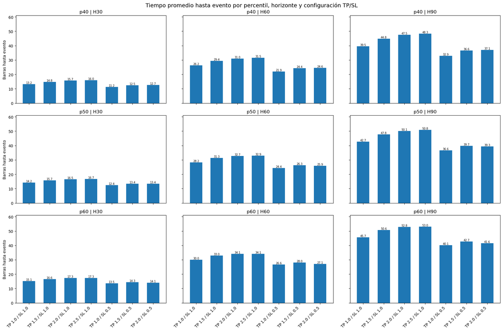

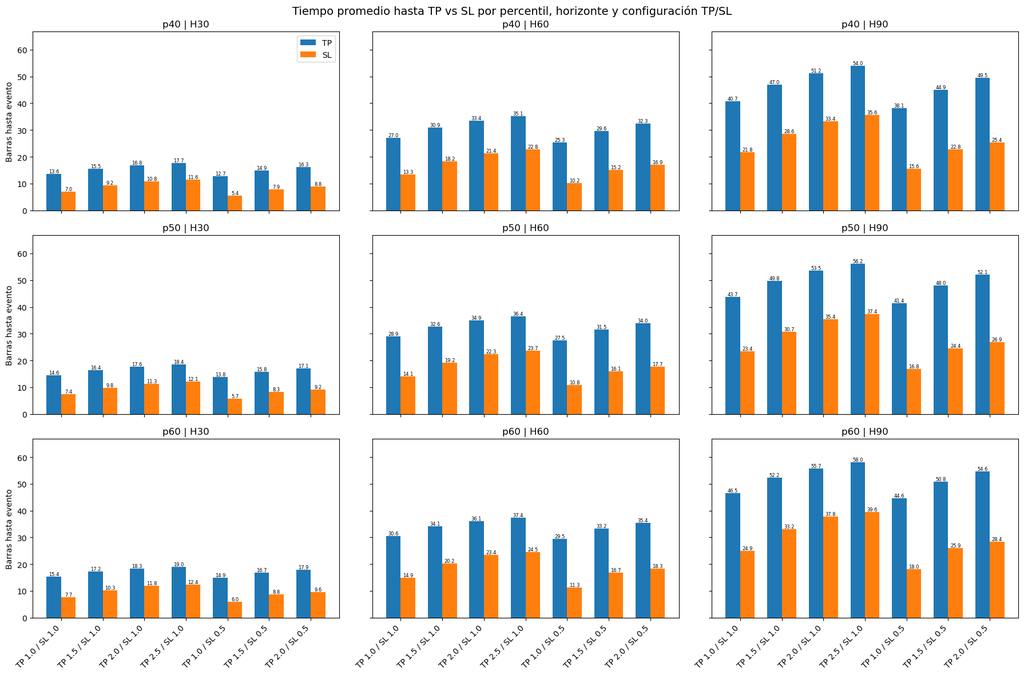

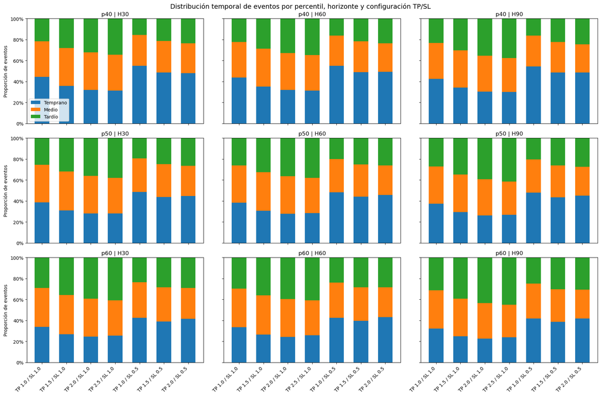

```
Celda 3 finalizada correctamente.
```

```python
# Celda 3 — Gráficos agrupados por percentil y horizonte
# ============================================================

print("Gráficos agrupados por percentil y horizonte - Tiempo hasta evento BAR")
print("=" * 80)

# ------------------------------------------------------------
# Validar objetos necesarios
# ------------------------------------------------------------

if "df_bar_event_time" not in globals():
    raise NameError("No existe df_bar_event_time. Primero debes correr la Celda 1.")

# ------------------------------------------------------------
# Orden de configuraciones TP/SL
# ------------------------------------------------------------

config_order = [
    (1.0, 1.0),
    (1.5, 1.0),
    (2.0, 1.0),
    (2.5, 1.0),
    (1.0, 0.5),
    (1.5, 0.5),
    (2.0, 0.5),
]

config_labels = [
    f"TP {tp} / SL {sl}"
    for tp, sl in config_order
]

df_event_plot = df_bar_event_time.copy()

df_event_plot["config_label"] = df_event_plot.apply(
    lambda row: f"TP {row['tp_mult']} / SL {row['sl_mult']}",
    axis=1
)

df_event_plot["config_order"] = df_event_plot.apply(
    lambda row: config_order.index((row["tp_mult"], row["sl_mult"]))
    if (row["tp_mult"], row["sl_mult"]) in config_order
    else 999,
    axis=1
)

df_event_plot = (
    df_event_plot
    .sort_values(["percentile", "horizon", "config_order"])
    .reset_index(drop=True)
)

# ============================================================
# Figura 1 — Tiempo promedio hasta evento
# Filas: percentil | Columnas: horizonte
# ============================================================

fig, axes = plt.subplots(
    nrows=len(BAR_PERCENTILES),
    ncols=len(BAR_HORIZONS),
    figsize=(18, 12),
    sharey=True
)

global_max_step = df_event_plot["event_step_mean"].max()

for i, percentile in enumerate(BAR_PERCENTILES):
    for j, horizon in enumerate(BAR_HORIZONS):
        ax = axes[i, j]

        tmp = df_event_plot[
            (df_event_plot["percentile"] == percentile)
            & (df_event_plot["horizon"] == horizon)
        ].copy()

        tmp = tmp.sort_values("config_order")

        x = np.arange(len(tmp))

        ax.bar(
            x,
            tmp["event_step_mean"],
            width=0.6
        )

        ax.set_title(f"p{percentile} | H{horizon}")
        ax.set_ylim(0, global_max_step * 1.15)

        if j == 0:
            ax.set_ylabel("Barras hasta evento")

        if i == len(BAR_PERCENTILES) - 1:
            ax.set_xticks(x)
            ax.set_xticklabels(config_labels, rotation=45, ha="right")
        else:
            ax.set_xticks(x)
            ax.set_xticklabels([])

        for k, value in enumerate(tmp["event_step_mean"]):
            ax.text(
                k,
                value,
                f"{value:.1f}",
                ha="center",
                va="bottom",
                fontsize=7
            )

fig.suptitle(
    "Tiempo promedio hasta evento por percentil, horizonte y configuración TP/SL",
    fontsize=14
)

plt.tight_layout()
plt.show()

# ============================================================
# Figura 2 — Tiempo promedio hasta TP vs SL
# Filas: percentil | Columnas: horizonte
# ============================================================

fig, axes = plt.subplots(
    nrows=len(BAR_PERCENTILES),
    ncols=len(BAR_HORIZONS),
    figsize=(18, 12),
    sharey=True
)

bar_width = 0.35

global_max_tp_sl_step = max(
    df_event_plot["tp_step_mean"].max(),
    df_event_plot["sl_step_mean"].max()
)

for i, percentile in enumerate(BAR_PERCENTILES):
    for j, horizon in enumerate(BAR_HORIZONS):
        ax = axes[i, j]

        tmp = df_event_plot[
            (df_event_plot["percentile"] == percentile)
            & (df_event_plot["horizon"] == horizon)
        ].copy()

        tmp = tmp.sort_values("config_order")

        x = np.arange(len(tmp))

        ax.bar(
            x - bar_width / 2,
            tmp["tp_step_mean"],
            width=bar_width,
            label="TP"
        )

        ax.bar(
            x + bar_width / 2,
            tmp["sl_step_mean"],
            width=bar_width,
            label="SL"
        )

        ax.set_title(f"p{percentile} | H{horizon}")
        ax.set_ylim(0, global_max_tp_sl_step * 1.15)

        if j == 0:
            ax.set_ylabel("Barras hasta evento")

        if i == len(BAR_PERCENTILES) - 1:
            ax.set_xticks(x)
            ax.set_xticklabels(config_labels, rotation=45, ha="right")
        else:
            ax.set_xticks(x)
            ax.set_xticklabels([])

        if i == 0 and j == 0:
            ax.legend()

        for k, row in enumerate(tmp.itertuples()):
            ax.text(
                k - bar_width / 2,
                row.tp_step_mean,
                f"{row.tp_step_mean:.1f}",
                ha="center",
                va="bottom",
                fontsize=6
            )

            ax.text(
                k + bar_width / 2,
                row.sl_step_mean,
                f"{row.sl_step_mean:.1f}",
                ha="center",
                va="bottom",
                fontsize=6
            )

fig.suptitle(
    "Tiempo promedio hasta TP vs SL por percentil, horizonte y configuración TP/SL",
    fontsize=14
)

plt.tight_layout()
plt.show()

# ============================================================
# Figura 3 — Eventos tempranos, medios y tardíos
# Filas: percentil | Columnas: horizonte
# ============================================================

fig, axes = plt.subplots(
    nrows=len(BAR_PERCENTILES),
    ncols=len(BAR_HORIZONS),
    figsize=(18, 12),
    sharey=True
)

for i, percentile in enumerate(BAR_PERCENTILES):
    for j, horizon in enumerate(BAR_HORIZONS):
        ax = axes[i, j]

        tmp = df_event_plot[
            (df_event_plot["percentile"] == percentile)
            & (df_event_plot["horizon"] == horizon)
        ].copy()

        tmp = tmp.sort_values("config_order")

        x = np.arange(len(tmp))

        early = tmp["early_event_rate"].to_numpy()
        middle = tmp["middle_event_rate"].to_numpy()
        late = tmp["late_event_rate"].to_numpy()

        ax.bar(
            x,
            early,
            width=0.6,
            label="Temprano"
        )

        ax.bar(
            x,
            middle,
            width=0.6,
            bottom=early,
            label="Medio"
        )

        ax.bar(
            x,
            late,
            width=0.6,
            bottom=early + middle,
            label="Tardío"
        )

        ax.set_title(f"p{percentile} | H{horizon}")
        ax.set_ylim(0, 1)

        if j == 0:
            ax.set_ylabel("Proporción de eventos")

        if i == len(BAR_PERCENTILES) - 1:
            ax.set_xticks(x)
            ax.set_xticklabels(config_labels, rotation=45, ha="right")
        else:
            ax.set_xticks(x)
            ax.set_xticklabels([])

        ax.yaxis.set_major_formatter(
            plt.FuncFormatter(lambda y, _: f"{y:.0%}")
        )

        if i == 0 and j == 0:
            ax.legend()

fig.suptitle(
    "Distribución temporal de eventos por percentil, horizonte y configuración TP/SL",
    fontsize=14
)

plt.tight_layout()
plt.show()

print("\nCelda 3 finalizada correctamente.")
```

### Celda 4 — Guardado y tabla final para observaciones

```python
# Celda 4 — Guardado y tabla final para observaciones
# ============================================================

print("Guardado y tabla final de tiempo hasta evento TP/SL - BAR")
print("=" * 80)

# ------------------------------------------------------------
# Validar objetos necesarios
# ------------------------------------------------------------

required_objects = [
    "df_bar_event_time",
    "df_bar_event_time_by_config",
    "df_bar_event_time_by_target_base",
    "df_bar_event_time_fast_ranking",
    "df_bar_event_time_slow_ranking",
    "MNQ_TARGETS_PATH",
]

missing_objects = [
    obj for obj in required_objects
    if obj not in globals()
]

if missing_objects:
    raise NameError(
        "Faltan objetos necesarios. "
        f"Debes correr las celdas anteriores: {missing_objects}"
    )

# ------------------------------------------------------------
# Definir rutas de guardado
# ------------------------------------------------------------

MNQ_TARGETS_BAR_EVENT_TIME_CSV = (
    MNQ_TARGETS_PATH / "mnq_targets_bar_event_time.csv"
)

MNQ_TARGETS_BAR_EVENT_TIME_BY_CONFIG_CSV = (
    MNQ_TARGETS_PATH / "mnq_targets_bar_event_time_by_config.csv"
)

MNQ_TARGETS_BAR_EVENT_TIME_BY_TARGET_BASE_CSV = (
    MNQ_TARGETS_PATH / "mnq_targets_bar_event_time_by_target_base.csv"
)

MNQ_TARGETS_BAR_EVENT_TIME_FAST_RANKING_CSV = (
    MNQ_TARGETS_PATH / "mnq_targets_bar_event_time_fast_ranking.csv"
)

MNQ_TARGETS_BAR_EVENT_TIME_SLOW_RANKING_CSV = (
    MNQ_TARGETS_PATH / "mnq_targets_bar_event_time_slow_ranking.csv"
)

MNQ_TARGETS_BAR_EVENT_TIME_FINAL_TABLE_CSV = (
    MNQ_TARGETS_PATH / "mnq_targets_bar_event_time_final_table.csv"
)

MNQ_TARGETS_BAR_EVENT_TIME_REPORT_TXT = (
    MNQ_TARGETS_PATH / "mnq_targets_bar_event_time_report.txt"
)

# ------------------------------------------------------------
# Crear tabla final para observaciones
# ------------------------------------------------------------

df_bar_event_time_final_table = df_bar_event_time.copy()

df_bar_event_time_final_table["target_base"] = (
    "p"
    + df_bar_event_time_final_table["percentile"].astype(str)
    + "_h"
    + df_bar_event_time_final_table["horizon"].astype(str)
)

# Clasificación simple del tiempo de resolución
def classify_event_timing(row):
    """
    Clasificación descriptiva del tiempo hasta evento.
    No selecciona targets finales.
    Solo ayuda a interpretar si los eventos tienden a ocurrir temprano,
    en la parte media o tarde del horizonte.
    """

    early = row["early_event_rate"]
    late = row["late_event_rate"]
    event_rate = row["event_rate"]

    if pd.isna(event_rate) or event_rate == 0:
        return "sin_eventos"

    if early >= 0.50:
        return "resolución_temprana"

    if late >= 0.50:
        return "resolución_tardía"

    return "resolución_intermedia"


df_bar_event_time_final_table["event_timing_profile"] = (
    df_bar_event_time_final_table.apply(
        classify_event_timing,
        axis=1
    )
)

# Ordenar columnas principales
event_time_final_cols = [
    "bar_col",
    "target_base",
    "horizon",
    "percentile",
    "tp_mult",
    "sl_mult",
    "tp_sl_config",

    "valid_rows",
    "event_count",
    "tp_count",
    "sl_count",
    "no_event_count",

    "event_rate",
    "tp_rate",
    "sl_rate",
    "no_event_rate",

    "event_step_mean",
    "event_step_median",
    "event_step_q25",
    "event_step_q75",
    "event_step_min",
    "event_step_max",

    "tp_step_mean",
    "tp_step_median",
    "tp_step_q25",
    "tp_step_q75",

    "sl_step_mean",
    "sl_step_median",
    "sl_step_q25",
    "sl_step_q75",

    "early_event_rate",
    "middle_event_rate",
    "late_event_rate",
    "event_timing_profile",
]

df_bar_event_time_final_table = (
    df_bar_event_time_final_table[event_time_final_cols]
    .sort_values(["percentile", "horizon", "sl_mult", "tp_mult"])
    .reset_index(drop=True)
)

# ------------------------------------------------------------
# Guardar tablas principales
# ------------------------------------------------------------

df_bar_event_time.to_csv(
    MNQ_TARGETS_BAR_EVENT_TIME_CSV,
    index=False
)

df_bar_event_time_by_config.to_csv(
    MNQ_TARGETS_BAR_EVENT_TIME_BY_CONFIG_CSV,
    index=False
)

df_bar_event_time_by_target_base.to_csv(
    MNQ_TARGETS_BAR_EVENT_TIME_BY_TARGET_BASE_CSV,
    index=False
)

df_bar_event_time_fast_ranking.to_csv(
    MNQ_TARGETS_BAR_EVENT_TIME_FAST_RANKING_CSV,
    index=False
)

df_bar_event_time_slow_ranking.to_csv(
    MNQ_TARGETS_BAR_EVENT_TIME_SLOW_RANKING_CSV,
    index=False
)

df_bar_event_time_final_table.to_csv(
    MNQ_TARGETS_BAR_EVENT_TIME_FINAL_TABLE_CSV,
    index=False
)

# ------------------------------------------------------------
# Tabla compacta por configuración TP/SL
# ------------------------------------------------------------

event_time_config_cols = [
    "tp_sl_config",
    "tp_mult",
    "sl_mult",
    "n_targets",
    "event_rate_mean",
    "tp_rate_mean",
    "sl_rate_mean",
    "no_event_rate_mean",
    "event_step_mean",
    "event_step_median",
    "tp_step_mean",
    "tp_step_median",
    "sl_step_mean",
    "sl_step_median",
    "early_event_rate_mean",
    "middle_event_rate_mean",
    "late_event_rate_mean",
]

print("\nTabla compacta por configuración TP/SL:")
print(
    df_bar_event_time_by_config[event_time_config_cols]
    .to_string(
        index=False,
        formatters={
            "event_rate_mean": "{:.2%}".format,
            "tp_rate_mean": "{:.2%}".format,
            "sl_rate_mean": "{:.2%}".format,
            "no_event_rate_mean": "{:.2%}".format,
            "event_step_mean": "{:.2f}".format,
            "event_step_median": "{:.2f}".format,
            "tp_step_mean": "{:.2f}".format,
            "tp_step_median": "{:.2f}".format,
            "sl_step_mean": "{:.2f}".format,
            "sl_step_median": "{:.2f}".format,
            "early_event_rate_mean": "{:.2%}".format,
            "middle_event_rate_mean": "{:.2%}".format,
            "late_event_rate_mean": "{:.2%}".format,
        }
    )
)
```

```python
# ------------------------------------------------------------
# Tabla compacta por percentil y horizonte
# ------------------------------------------------------------

event_time_target_base_cols = [
    "percentile",
    "horizon",
    "n_configs",
    "event_rate_mean",
    "tp_rate_mean",
    "sl_rate_mean",
    "no_event_rate_mean",
    "event_step_mean",
    "event_step_median",
    "tp_step_mean",
    "sl_step_mean",
    "early_event_rate_mean",
    "middle_event_rate_mean",
    "late_event_rate_mean",
]

print("\nTabla compacta por percentil y horizonte:")
print(
    df_bar_event_time_by_target_base[event_time_target_base_cols]
    .to_string(
        index=False,
        formatters={
            "event_rate_mean": "{:.2%}".format,
            "tp_rate_mean": "{:.2%}".format,
            "sl_rate_mean": "{:.2%}".format,
            "no_event_rate_mean": "{:.2%}".format,
            "event_step_mean": "{:.2f}".format,
            "event_step_median": "{:.2f}".format,
            "tp_step_mean": "{:.2f}".format,
            "sl_step_mean": "{:.2f}".format,
            "early_event_rate_mean": "{:.2%}".format,
            "middle_event_rate_mean": "{:.2%}".format,
            "late_event_rate_mean": "{:.2%}".format,
        }
    )
)

# ------------------------------------------------------------
# Tabla final completa: todos los percentiles, horizontes y TP/SL
# ------------------------------------------------------------

final_print_cols = [
    "bar_col",
    "target_base",
    "tp_sl_config",
    "event_rate",
    "tp_rate",
    "sl_rate",
    "no_event_rate",
    "event_step_mean",
    "event_step_median",
    "tp_step_mean",
    "sl_step_mean",
    "early_event_rate",
    "middle_event_rate",
    "late_event_rate",
    "event_timing_profile",
]

print("\nTabla final de tiempo hasta evento — todos los percentiles y horizontes:")
print(
    df_bar_event_time_final_table[final_print_cols]
    .to_string(
        index=False,
        formatters={
            "event_rate": "{:.2%}".format,
            "tp_rate": "{:.2%}".format,
            "sl_rate": "{:.2%}".format,
            "no_event_rate": "{:.2%}".format,
            "event_step_mean": "{:.2f}".format,
            "event_step_median": "{:.2f}".format,
            "tp_step_mean": "{:.2f}".format,
            "sl_step_mean": "{:.2f}".format,
            "early_event_rate": "{:.2%}".format,
            "middle_event_rate": "{:.2%}".format,
            "late_event_rate": "{:.2%}".format,
        }
    )
)

# ------------------------------------------------------------
# Top 20 eventos más tempranos
# ------------------------------------------------------------

ranking_cols = [
    "bar_col",
    "horizon",
    "percentile",
    "tp_mult",
    "sl_mult",
    "event_rate",
    "tp_rate",
    "sl_rate",
    "no_event_rate",
    "event_step_mean",
    "event_step_median",
    "early_event_rate",
    "middle_event_rate",
    "late_event_rate",
]

print("\nTop 20 variantes con eventos más tempranos:")
print(
    df_bar_event_time_fast_ranking[ranking_cols]
    .head(20)
    .to_string(
        index=False,
        formatters={
            "event_rate": "{:.2%}".format,
            "tp_rate": "{:.2%}".format,
            "sl_rate": "{:.2%}".format,
            "no_event_rate": "{:.2%}".format,
            "event_step_mean": "{:.2f}".format,
            "event_step_median": "{:.2f}".format,
            "early_event_rate": "{:.2%}".format,
            "middle_event_rate": "{:.2%}".format,
            "late_event_rate": "{:.2%}".format,
        }
    )
)

# ------------------------------------------------------------
# Top 20 eventos más tardíos
# ------------------------------------------------------------

print("\nTop 20 variantes con eventos más tardíos:")
print(
    df_bar_event_time_slow_ranking[ranking_cols]
    .head(20)
    .to_string(
        index=False,
        formatters={
            "event_rate": "{:.2%}".format,
            "tp_rate": "{:.2%}".format,
            "sl_rate": "{:.2%}".format,
            "no_event_rate": "{:.2%}".format,
            "event_step_mean": "{:.2f}".format,
            "event_step_median": "{:.2f}".format,
            "early_event_rate": "{:.2%}".format,
            "middle_event_rate": "{:.2%}".format,
            "late_event_rate": "{:.2%}".format,
        }
    )
)

# ------------------------------------------------------------
# Conteo por perfil temporal
# ------------------------------------------------------------

df_bar_event_timing_profile_counts = (
    df_bar_event_time_final_table
    .groupby("event_timing_profile", as_index=False)
    .agg(
        n_targets=("bar_col", "count"),
        event_rate_mean=("event_rate", "mean"),
        tp_rate_mean=("tp_rate", "mean"),
        sl_rate_mean=("sl_rate", "mean"),
        no_event_rate_mean=("no_event_rate", "mean"),
        event_step_mean=("event_step_mean", "mean"),
        event_step_median=("event_step_median", "mean"),
        early_event_rate_mean=("early_event_rate", "mean"),
        middle_event_rate_mean=("middle_event_rate", "mean"),
        late_event_rate_mean=("late_event_rate", "mean"),
    )
    .sort_values("n_targets", ascending=False)
    .reset_index(drop=True)
)

print("\nConteo por perfil temporal:")
print(
    df_bar_event_timing_profile_counts
    .to_string(
        index=False,
        formatters={
            "event_rate_mean": "{:.2%}".format,
            "tp_rate_mean": "{:.2%}".format,
            "sl_rate_mean": "{:.2%}".format,
            "no_event_rate_mean": "{:.2%}".format,
            "event_step_mean": "{:.2f}".format,
            "event_step_median": "{:.2f}".format,
            "early_event_rate_mean": "{:.2%}".format,
            "middle_event_rate_mean": "{:.2%}".format,
            "late_event_rate_mean": "{:.2%}".format,
        }
    )
)

# ------------------------------------------------------------
# Guardar reporte TXT completo
# ------------------------------------------------------------
```

```python
with MNQ_TARGETS_BAR_EVENT_TIME_REPORT_TXT.open("w", encoding="utf-8") as f:
    f.write("4.8. Tiempo hasta evento TP/SL - BAR\n")
    f.write("=" * 100 + "\n\n")

    f.write("Tabla compacta por configuración TP/SL\n")
    f.write("-" * 100 + "\n")
    f.write(
        df_bar_event_time_by_config[event_time_config_cols]
        .to_string(
            index=False,
            formatters={
                "event_rate_mean": "{:.2%}".format,
                "tp_rate_mean": "{:.2%}".format,
                "sl_rate_mean": "{:.2%}".format,
                "no_event_rate_mean": "{:.2%}".format,
                "event_step_mean": "{:.2f}".format,
                "event_step_median": "{:.2f}".format,
                "tp_step_mean": "{:.2f}".format,
                "tp_step_median": "{:.2f}".format,
                "sl_step_mean": "{:.2f}".format,
                "sl_step_median": "{:.2f}".format,
                "early_event_rate_mean": "{:.2%}".format,
                "middle_event_rate_mean": "{:.2%}".format,
                "late_event_rate_mean": "{:.2%}".format,
            }
        )
    )

    f.write("\n\n")
    f.write("Tabla compacta por percentil y horizonte\n")
    f.write("-" * 100 + "\n")
    f.write(
        df_bar_event_time_by_target_base[event_time_target_base_cols]
        .to_string(
            index=False,
            formatters={
                "event_rate_mean": "{:.2%}".format,
                "tp_rate_mean": "{:.2%}".format,
                "sl_rate_mean": "{:.2%}".format,
                "no_event_rate_mean": "{:.2%}".format,
                "event_step_mean": "{:.2f}".format,
                "event_step_median": "{:.2f}".format,
                "tp_step_mean": "{:.2f}".format,
                "sl_step_mean": "{:.2f}".format,
                "early_event_rate_mean": "{:.2%}".format,
                "middle_event_rate_mean": "{:.2%}".format,
                "late_event_rate_mean": "{:.2%}".format,
            }
        )
    )

    f.write("\n\n")
    f.write("Tabla final completa: todos los percentiles, horizontes y configuraciones TP/SL\n")
    f.write("-" * 100 + "\n")
    f.write(
        df_bar_event_time_final_table[final_print_cols]
        .to_string(
            index=False,
            formatters={
                "event_rate": "{:.2%}".format,
                "tp_rate": "{:.2%}".format,
                "sl_rate": "{:.2%}".format,
                "no_event_rate": "{:.2%}".format,
                "event_step_mean": "{:.2f}".format,
                "event_step_median": "{:.2f}".format,
                "tp_step_mean": "{:.2f}".format,
                "sl_step_mean": "{:.2f}".format,
                "early_event_rate": "{:.2%}".format,
                "middle_event_rate": "{:.2%}".format,
                "late_event_rate": "{:.2%}".format,
            }
        )
    )

    f.write("\n\n")
    f.write("Top 20 variantes con eventos más tempranos\n")
    f.write("-" * 100 + "\n")
    f.write(
        df_bar_event_time_fast_ranking[ranking_cols]
        .head(20)
        .to_string(
            index=False,
            formatters={
                "event_rate": "{:.2%}".format,
                "tp_rate": "{:.2%}".format,
                "sl_rate": "{:.2%}".format,
                "no_event_rate": "{:.2%}".format,
                "event_step_mean": "{:.2f}".format,
                "event_step_median": "{:.2f}".format,
                "early_event_rate": "{:.2%}".format,
                "middle_event_rate": "{:.2%}".format,
                "late_event_rate": "{:.2%}".format,
            }
        )
    )

    f.write("\n\n")
    f.write("Top 20 variantes con eventos más tardíos\n")
    f.write("-" * 100 + "\n")
    f.write(
        df_bar_event_time_slow_ranking[ranking_cols]
        .head(20)
        .to_string(
            index=False,
            formatters={
                "event_rate": "{:.2%}".format,
                "tp_rate": "{:.2%}".format,
                "sl_rate": "{:.2%}".format,
                "no_event_rate": "{:.2%}".format,
                "event_step_mean": "{:.2f}".format,
                "event_step_median": "{:.2f}".format,
                "early_event_rate": "{:.2%}".format,
                "middle_event_rate": "{:.2%}".format,
                "late_event_rate": "{:.2%}".format,
            }
        )
    )

    f.write("\n\n")
    f.write("Conteo por perfil temporal\n")
    f.write("-" * 100 + "\n")
    f.write(
        df_bar_event_timing_profile_counts
        .to_string(
            index=False,
            formatters={
                "event_rate_mean": "{:.2%}".format,
                "tp_rate_mean": "{:.2%}".format,
                "sl_rate_mean": "{:.2%}".format,
                "no_event_rate_mean": "{:.2%}".format,
                "event_step_mean": "{:.2f}".format,
                "event_step_median": "{:.2f}".format,
                "early_event_rate_mean": "{:.2%}".format,
                "middle_event_rate_mean": "{:.2%}".format,
                "late_event_rate_mean": "{:.2%}".format,
            }
        )
    )

# ------------------------------------------------------------
# Confirmación final
# ------------------------------------------------------------

print("\nArchivos guardados:")
print(f"Tiempo hasta evento BAR:              {MNQ_TARGETS_BAR_EVENT_TIME_CSV}")
print(f"Tiempo por configuración TP/SL:       {MNQ_TARGETS_BAR_EVENT_TIME_BY_CONFIG_CSV}")
print(f"Tiempo por percentil y horizonte:     {MNQ_TARGETS_BAR_EVENT_TIME_BY_TARGET_BASE_CSV}")
print(f"Ranking eventos tempranos:            {MNQ_TARGETS_BAR_EVENT_TIME_FAST_RANKING_CSV}")
print(f"Ranking eventos tardíos:              {MNQ_TARGETS_BAR_EVENT_TIME_SLOW_RANKING_CSV}")
print(f"Tabla final tiempo hasta evento:      {MNQ_TARGETS_BAR_EVENT_TIME_FINAL_TABLE_CSV}")
print(f"Reporte TXT:                          {MNQ_TARGETS_BAR_EVENT_TIME_REPORT_TXT}")

print("\nCelda 4 finalizada correctamente.")
```

```
Guardado y tabla final de tiempo hasta evento TP/SL - BAR
================================================================================

Tabla compacta por configuración TP/SL:
   tp_sl_config  tp_mult  sl_mult  n_targets event_rate_mean tp_rate_mean sl_rate_mean no_event_rate_mean event_step_mean event_step_median tp_step_mean tp_step_median sl_step_mean sl_step_median early_event_rate_mean middle_event_rate_mean late_event_rate_mean
TP 1.0 / SL 0.5      1.0      0.5          9         100.00%       81.07%       18.93%              0.00%           24.41             21.22        27.54          25.44        11.10           8.00                48.43%                 31.55%               20.02%
TP 1.5 / SL 0.5      1.5      0.5          9          67.11%       44.39%       22.71%             32.89%           26.43             24.22        31.72          31.11        16.23          10.22                43.88%                 30.75%               25.37%
TP 2.0 / SL 0.5      2.0      0.5          9          49.45%       25.21%       24.24%             50.55%           26.20             23.44        34.35          34.56        17.90          11.11                45.29%                 28.03%               26.68%
TP 1.0 / SL 1.0      1.0      1.0          9         100.00%       95.18%        4.82%              0.00%           28.32             26.56        28.99          27.67        14.94          12.00                38.24%                 35.56%               26.20%
TP 1.5 / SL 1.0      1.5      1.0          9          58.58%       52.73%        5.85%             41.42%           31.56             31.11        32.84          32.56        19.93          14.78                30.43%                 36.55%               33.02%
TP 2.0 / SL 1.0      2.0      1.0          9          36.90%       30.26%        6.65%             63.10%           33.08             33.44        35.27          36.00        23.05          17.00                27.52%                 35.33%               37.15%
TP 2.5 / SL 1.0      2.5      1.0          9          25.08%       18.02%        7.06%             74.92%           33.39             34.33        36.93          38.56        24.40          18.89                27.88%                 33.11%               39.02%

Tabla compacta por percentil y horizonte:
 percentile  horizon  n_configs event_rate_mean tp_rate_mean sl_rate_mean no_event_rate_mean event_step_mean event_step_median tp_step_mean sl_step_mean early_event_rate_mean middle_event_rate_mean late_event_rate_mean
         40       30          7          67.17%       52.34%       14.83%             32.83%           13.71             12.57        15.36         8.65                42.15%                 32.50%               25.35%
         40       60          7          66.42%       51.09%       15.32%             33.58%           27.00             24.71        30.52        16.86                42.12%                 32.15%               25.73%
         40       90          7          66.68%       50.70%       15.98%             33.32%           40.97             38.00        46.48        26.18                41.21%                 31.69%               27.10%
         50       30          7          62.76%       50.36%       12.40%             37.24%           14.62             13.86        16.24         9.10                37.57%                 33.63%               28.80%
         50       60          7          61.81%       49.20%       12.61%             38.19%           28.81             27.43        32.26        17.69                37.54%                 33.32%               29.14%
         50       90          7          62.39%       49.04%       13.36%             37.61%           43.86             42.14        49.24        27.85                36.55%                 32.48%               30.97%
         60       30          7          58.58%       48.39%       10.19%             41.42%           15.47             15.29        17.05         9.51                33.40%                 34.32%               32.28%
         60       60          7          57.75%       47.41%       10.34%             42.25%           30.42             29.71        33.76        18.47                33.57%                 33.99%               32.43%
         60       90          7          58.45%       47.43%       11.02%             41.55%           46.64             46.14        51.78        29.67                32.30%                 32.77%               34.93%

Tabla final de tiempo hasta evento — todos los percentiles y horizontes:
```

[output cut: 126 more lines]

### Observaciones preliminares — Tiempo hasta evento TP/SL

El análisis de tiempo hasta evento muestra que los targets `BAR` presentan una dinámica temporal coherente con la lógica de las barreras.

En primer lugar, el tiempo promedio hasta evento aumenta naturalmente con el horizonte. Para `H30`, los eventos suelen ocurrir alrededor de las barras 13 a 16; para `H60`, alrededor de las barras 27 a 31; y para `H90`, alrededor de las barras 41 a 47. Esto indica que, en términos relativos, muchas configuraciones tienden a resolverse aproximadamente hacia la mitad del horizonte disponible.

También se observa que, a medida que aumenta el percentil, los eventos tienden a tardar más. Esto es esperable, porque percentiles más altos implican thresholds más exigentes. Por ejemplo, al pasar de `p40` a `p60`, el tiempo promedio hasta evento aumenta de forma consistente en `H30`, `H60` y `H90`.

Una observación importante es que los eventos de Stop Loss suelen ocurrir antes que los eventos de Take Profit. Esto aparece de forma consistente en casi todas las configuraciones. Por ejemplo, en configuraciones con `SL = 0.5`, el SL ocurre muy rápido porque la barrera adversa está más cerca del precio de entrada. Esto confirma que los stops más ajustados aumentan la velocidad de resolución, pero también aumentan la sensibilidad al ruido.

La configuración `TP 1.0 / SL 0.5` es la que resuelve más temprano. De hecho, las únicas variantes clasificadas como `resolución_temprana` corresponden a `p40` con `TP 1.0 / SL 0.5` en los tres horizontes. Sin embargo, esta configuración no necesariamente es la más interesante operativamente, porque tiene una frecuencia de SL relativamente alta.

La configuración `TP 1.0 / SL 1.0` mantiene una resolución completa, con `event_rate = 100%`, y tiempos de resolución moderados. Sin embargo, al igual que en los puntos anteriores, debe seguir interpretándose como benchmark, ya que el TP coincide con el threshold base usado para construir `DIR`.

La configuración `TP 1.5 / SL 1.0` mantiene un perfil temporal más equilibrado. No resuelve tan rápido como las configuraciones más fáciles, pero tampoco queda excesivamente tardía. En las variantes `p50`, por ejemplo, el evento promedio ocurre aproximadamente en la barra 16 para `H30`, 31 para `H60` y 48 para `H90`. Esto sugiere que la operación necesita tiempo para desarrollarse, pero no depende exclusivamente del final de la ventana.

Las configuraciones más exigentes, especialmente `TP 2.0 / SL 1.0` y `TP 2.5 / SL 1.0`, muestran una mayor proporción de eventos tardíos y muchos casos `no_event`. Esto indica que, aunque algunas operaciones alcanzan objetivos grandes, muchas necesitan demasiado tiempo o directamente no resuelven dentro del horizonte definido.

El caso más extremo aparece en variantes como `p60_h90` con `TP 2.5 / SL 1.0`, donde el `no_event` supera el 80% y una proporción importante de los eventos ocurre tarde. Esto refuerza la idea de que esa configuración es demasiado exigente para una primera selección operativa.

En términos generales, la mayoría de los targets quedan clasificados como `resolución_intermedia`. Esto es positivo, porque indica que las operaciones no dependen exclusivamente de movimientos inmediatos ni tampoco solamente del cierre del horizonte. La dinámica parece repartirse entre eventos tempranos, medios y tardíos.

En síntesis, el análisis de tiempo hasta evento confirma que `TP 1.5 / SL 1.0` sigue siendo una candidata razonable. Ofrece una frecuencia de TP favorable, baja frecuencia de SL y un tiempo de resolución intermedio. Por el contrario, `TP 2.0 / SL 1.0` y `TP 2.5 / SL 1.0` parecen más exigentes y lentas, por lo que deberían mantenerse solo como referencias comparativas o candidatas más agresivas.

La lectura simple sería esta:

```
    TP 1.0 / SL 1.0  → benchmark, resuelve siempre, pero favorecido por construcción.
    TP 1.5 / SL 1.0  → mejor equilibrio entre calidad y tiempo.
    TP 2.0 / SL 1.0  → más exigente, más lenta, muchos no_event.
    TP 2.5 / SL 1.0  → demasiado exigente para esta etapa.
    SL 0.5           → resuelve rápido, pero aumenta mucho la sensibilidad al ruido.
```

Para mí, después de 4.8, la candidata principal sigue siendo:

```
    bar_p50_h30_tp15_sl10
    bar_p50_h60_tp15_sl10
    bar_p50_h90_tp15_sl10
```

Y como comparación más selectiva:

```
    bar_p60_h30_tp15_sl10
    bar_p60_h60_tp15_sl10
    bar_p60_h90_tp15_sl10
```

### Aclaración sobre el tiempo hasta TP y SL

Una lectura importante del análisis de tiempo hasta evento es que el hecho de que el `SL` tenga un menor tiempo promedio que el `TP` no significa que el Stop Loss se alcance antes en todas las operaciones.

La codificación de `BAR` ya resuelve esa lógica fila por fila:

```
    BAR =  1  → el Take Profit fue alcanzado primero
    BAR = -1  → el Stop Loss fue alcanzado primero
    BAR =  0  → no se alcanzó ni TP ni SL dentro del horizonte
```

Por lo tanto, cuando una observación tiene `BAR = 1`, significa que el `TP` ocurrió antes que el `SL`. Cuando una observación tiene `BAR = -1`, significa que el `SL` ocurrió antes que el `TP`.

Lo que muestran las métricas `tp_step_mean` y `sl_step_mean` es distinto: son promedios condicionados al tipo de evento. Es decir, miden cuánto tardan, en promedio, las operaciones que terminan en TP y cuánto tardan, en promedio, las operaciones que terminan en SL.

En la configuración `TP 1.5 / SL 1.0`, por ejemplo, el TP está más lejos que el SL:

```
    TP = 1.5 × threshold
    SL = 1.0 × threshold
```

Por esta razón, cuando la operación sale bien, normalmente necesita más barras para alcanzar el Take Profit. En cambio, cuando la operación sale mal, el Stop Loss puede aparecer antes porque está más cerca del precio de entrada.

La interpretación correcta es la siguiente:

```
    El SL suele ocurrir más rápido cuando ocurre una pérdida,
    pero eso no significa que el SL ocurra antes en las operaciones ganadoras.
```

En términos operativos, esto es razonable. Las pérdidas tienden a resolverse más rápido porque la barrera adversa está más cerca, mientras que las ganancias requieren más tiempo para desarrollar un movimiento favorable más amplio.

Por eso, una configuración como `TP 1.5 / SL 1.0` puede seguir siendo interesante: no porque el TP llegue más rápido, sino porque cuando el evento se resuelve, la mayoría de las veces resuelve a favor del TP, aunque tarde más en alcanzarlo.

## 4.9. Estabilidad temporal

En este punto se analiza la estabilidad temporal de los targets `BAR`.

El objetivo es revisar si las métricas operativas de cada target se mantienen relativamente consistentes a lo largo del tiempo o si cambian de forma significativa entre períodos.

Este análisis es importante porque un target puede mostrar buenos resultados globales, pero ser poco confiable si su comportamiento depende demasiado de un año específico o de un período particular del mercado.

La evaluación se realizará sobre los 63 targets `BAR`, considerando todos los percentiles, horizontes y configuraciones TP/SL.

Se analizarán principalmente:

```
    Frecuencia de TP
    Frecuencia de SL
    Frecuencia de no_event
    Eventos resueltos
    Proporción de TP entre eventos resueltos
    Expectativa simple en unidades de threshold
    Tiempo promedio hasta evento
```

Además, se mantendrá la separación metodológica definida previamente:

```
    development_2020_2024 → período usado para diseño y calibración
    final_test_2025_2026  → período reservado para evaluación fuera de muestra
```

### Celda 1 — Preparación de métricas temporales para los 63 targets BAR

Esta celda deja listo el dataframe principal:

```
    df_bar_temporal_stability
```

Ese dataframe contiene las métricas temporales de los **63 targets BAR** por:

```
    dataset_split
    year
    quarter
```

```python
# Celda 1 — Preparación de métricas temporales para los 63 targets BAR
# ============================================================

print("4.9. Estabilidad temporal - BAR")
print("=" * 80)

# ------------------------------------------------------------
# Validar objetos necesarios
# ------------------------------------------------------------

if "df_targets_bar" not in globals():
    raise NameError("No existe df_targets_bar. Primero debes construir los targets BAR.")

if "df_bar_metadata" not in globals():
    raise NameError("No existe df_bar_metadata. Primero debes construir df_bar_metadata.")

# ------------------------------------------------------------
# Copia de trabajo
# ------------------------------------------------------------

df_bar_temporal_base = df_targets_bar.copy()

# ------------------------------------------------------------
# Crear columnas temporales auxiliares
# ------------------------------------------------------------
# Importante:
# Recalculamos year y year_quarter explícitamente para evitar usar
# columnas antiguas o columnas quarter con valores 1, 2, 3, 4.
# ------------------------------------------------------------

if isinstance(df_bar_temporal_base.index, pd.DatetimeIndex):
    date_series_tmp = pd.Series(
        df_bar_temporal_base.index,
        index=df_bar_temporal_base.index
    )

elif "date" in df_bar_temporal_base.columns:
    date_series_tmp = pd.to_datetime(df_bar_temporal_base["date"])

else:
    raise KeyError(
        "No se pudieron crear columnas temporales. "
        "Se requiere DatetimeIndex o columna date."
    )

# Año
df_bar_temporal_base["year"] = date_series_tmp.dt.year

# Trimestre temporal correcto: 2020Q1, 2020Q2, ..., 2026Q2
df_bar_temporal_base["year_quarter"] = (
    date_series_tmp.dt.year.astype(str)
    + "Q"
    + date_series_tmp.dt.quarter.astype(str)
)

# Split metodológico
df_bar_temporal_base["dataset_split"] = np.where(
    df_bar_temporal_base["year"].between(2020, 2024),
    "development_2020_2024",
    np.where(
        df_bar_temporal_base["year"].between(2025, 2026),
        "final_test_2025_2026",
        "other"
    )
)

# ------------------------------------------------------------
# Función auxiliar para resumir un target BAR en un período
# ------------------------------------------------------------

def summarize_bar_target_for_period(df, bar_col, event_step_col, tp_mult, sl_mult):
    """
    Resume un target BAR dentro de un período temporal específico.

    BAR:
        1  = TP primero
       -1  = SL primero
        0  = no_event
       NaN = no operable / sin ventana válida
    """

    bar_series = df[bar_col]
    step_series = df[event_step_col]

    valid_mask = bar_series.notna()
    tp_mask = bar_series == 1
    sl_mask = bar_series == -1
    no_event_mask = bar_series == 0
    resolved_mask = tp_mask | sl_mask

    total_rows = len(df)
    valid_rows = int(valid_mask.sum())
    nan_rows = int(bar_series.isna().sum())

    tp_count = int(tp_mask.sum())
    sl_count = int(sl_mask.sum())
    no_event_count = int(no_event_mask.sum())
    resolved_count = tp_count + sl_count

    if valid_rows > 0:
        tp_rate = tp_count / valid_rows
        sl_rate = sl_count / valid_rows
        no_event_rate = no_event_count / valid_rows
        resolved_rate = resolved_count / valid_rows
    else:
        tp_rate = np.nan
        sl_rate = np.nan
        no_event_rate = np.nan
        resolved_rate = np.nan

    if resolved_count > 0:
        tp_share_over_resolved = tp_count / resolved_count
        sl_share_over_resolved = sl_count / resolved_count
    else:
        tp_share_over_resolved = np.nan
        sl_share_over_resolved = np.nan

    expectancy_units = (
        tp_rate * tp_mult
        - sl_rate * sl_mult
        if valid_rows > 0
        else np.nan
    )

    event_steps = step_series.loc[resolved_mask].dropna()

    if len(event_steps) > 0:
        event_step_mean = event_steps.mean()
        event_step_median = event_steps.median()
    else:
        event_step_mean = np.nan
        event_step_median = np.nan

    return {
        "total_rows": total_rows,
        "valid_rows": valid_rows,
        "nan_rows": nan_rows,

        "tp_count": tp_count,
        "sl_count": sl_count,
        "no_event_count": no_event_count,
        "resolved_count": resolved_count,

        "tp_rate": tp_rate,
        "sl_rate": sl_rate,
        "no_event_rate": no_event_rate,
        "resolved_rate": resolved_rate,

        "tp_share_over_resolved": tp_share_over_resolved,
        "sl_share_over_resolved": sl_share_over_resolved,

        "expectancy_units": expectancy_units,

        "event_step_mean": event_step_mean,
        "event_step_median": event_step_median,
    }

# ------------------------------------------------------------
# Definición de períodos temporales
# ------------------------------------------------------------
# dataset_split: development vs final_test
# year: año contra año
# quarter: trimestre temporal real, por ejemplo 2020Q1, 2020Q2, ...
# ------------------------------------------------------------

period_definitions = [
    {
        "period_type": "dataset_split",
        "period_col": "dataset_split",
    },
    {
        "period_type": "year",
        "period_col": "year",
    },
    {
        "period_type": "quarter",
        "period_col": "year_quarter",
    },
]

# ------------------------------------------------------------
# Construir métricas temporales por split, año y trimestre temporal
# ------------------------------------------------------------

temporal_rows = []

for _, meta in df_bar_metadata.iterrows():

    bar_col = meta["bar_col"]
    event_step_col = meta["event_step_col"]

    horizon = int(meta["horizon"])
    percentile = int(meta["percentile"])
    tp_mult = float(meta["tp_mult"])
    sl_mult = float(meta["sl_mult"])

    tp_sl_config = f"TP {tp_mult} / SL {sl_mult}"
    target_base = f"p{percentile}_h{horizon}"

    if bar_col not in df_bar_temporal_base.columns:
        raise KeyError(f"No existe la columna BAR: {bar_col}")

    if event_step_col not in df_bar_temporal_base.columns:
        raise KeyError(f"No existe la columna event_step: {event_step_col}")

    for period_info in period_definitions:

        period_type = period_info["period_type"]
        period_col = period_info["period_col"]

        period_values = (
            df_bar_temporal_base[period_col]
            .dropna()
            .unique()
        )

        for period_value in sorted(period_values):

            if period_value == "other":
                continue

            period_mask = df_bar_temporal_base[period_col] == period_value
            df_period = df_bar_temporal_base.loc[period_mask]

            summary = summarize_bar_target_for_period(
                df=df_period,
                bar_col=bar_col,
                event_step_col=event_step_col,
                tp_mult=tp_mult,
                sl_mult=sl_mult,
            )

            temporal_rows.append(
                {
                    "bar_col": bar_col,
                    "event_step_col": event_step_col,
                    "dir_col": meta["dir_col"],

                    "target_base": target_base,
                    "horizon": horizon,
                    "percentile": percentile,
                    "tp_mult": tp_mult,
                    "sl_mult": sl_mult,
                    "tp_sl_config": tp_sl_config,

                    "period_type": period_type,
                    "period": str(period_value),

                    **summary,
                }
            )

df_bar_temporal_stability = pd.DataFrame(temporal_rows)

df_bar_temporal_stability = (
    df_bar_temporal_stability
    .sort_values(
        [
            "period_type",
            "period",
            "percentile",
            "horizon",
            "sl_mult",
            "tp_mult",
        ]
    )
    .reset_index(drop=True)
)

# ------------------------------------------------------------
# Vista inicial
# ------------------------------------------------------------

print(f"Targets BAR analizados: {df_bar_metadata['bar_col'].nunique()}")
print(f"Filas de estabilidad temporal generadas: {len(df_bar_temporal_stability)}")

print("\nPeriodos analizados:")
print(
    df_bar_temporal_stability[
        ["period_type", "period"]
    ]
    .drop_duplicates()
    .sort_values(["period_type", "period"])
    .to_string(index=False)
)

print("\nVista inicial de estabilidad temporal BAR:")
print(
    df_bar_temporal_stability[
        [
            "bar_col",
            "period_type",
            "period",
            "horizon",
            "percentile",
            "tp_mult",
            "sl_mult",
            "valid_rows",
            "tp_rate",
            "sl_rate",
            "no_event_rate",
            "resolved_rate",
            "tp_share_over_resolved",
            "expectancy_units",
            "event_step_mean",
        ]
    ]
    .head(30)
    .to_string(
        index=False,
        formatters={
            "tp_rate": "{:.2%}".format,
            "sl_rate": "{:.2%}".format,
            "no_event_rate": "{:.2%}".format,
            "resolved_rate": "{:.2%}".format,
            "tp_share_over_resolved": "{:.2%}".format,
            "expectancy_units": "{:.3f}".format,
            "event_step_mean": "{:.2f}".format,
        }
    )
)

print("\nValidación de trimestres temporales:")
print(
    df_bar_temporal_stability[
        df_bar_temporal_stability["period_type"] == "quarter"
    ][["period_type", "period"]]
    .drop_duplicates()
    .sort_values("period")
    .head(12)
    .to_string(index=False)
)

print("\nPreparación de métricas temporales finalizada correctamente.")
```

```
4.9. Estabilidad temporal - BAR
================================================================================
Targets BAR analizados: 63
Filas de estabilidad temporal generadas: 2205

Periodos analizados:
  period_type                period
dataset_split development_2020_2024
dataset_split  final_test_2025_2026
      quarter                2020Q1
      quarter                2020Q2
      quarter                2020Q3
      quarter                2020Q4
      quarter                2021Q1
      quarter                2021Q2
      quarter                2021Q3
      quarter                2021Q4
      quarter                2022Q1
      quarter                2022Q2
      quarter                2022Q3
      quarter                2022Q4
      quarter                2023Q1
      quarter                2023Q2
      quarter                2023Q3
      quarter                2023Q4
      quarter                2024Q1
      quarter                2024Q2
      quarter                2024Q3
      quarter                2024Q4
      quarter                2025Q1
      quarter                2025Q2
      quarter                2025Q3
      quarter                2025Q4
      quarter                2026Q1
      quarter                2026Q2
         year                  2020
         year                  2021
         year                  2022
         year                  2023
         year                  2024
```

[output cut: 37 more lines]

```
period_type period
    quarter 2020Q1
    quarter 2020Q2
    quarter 2020Q3
    quarter 2020Q4
    quarter 2021Q1
    quarter 2021Q2
    quarter 2021Q3
    quarter 2021Q4
    quarter 2022Q1
    quarter 2022Q2
    quarter 2022Q3
    quarter 2022Q4

Preparación de métricas temporales finalizada correctamente.
```

### Celda 2 — Tablas agregadas de estabilidad temporal

```python
# Celda 2 — Tablas agregadas de estabilidad temporal
# ============================================================

print("Tablas agregadas de estabilidad temporal - BAR")
print("=" * 80)

# ------------------------------------------------------------
# Validar tabla base
# ------------------------------------------------------------

if "df_bar_temporal_stability" not in globals():
    raise NameError("No existe df_bar_temporal_stability. Primero debes correr la Celda 1.")

# ------------------------------------------------------------
# Métricas principales para evaluar estabilidad
# ------------------------------------------------------------

stability_metrics = [
    "tp_rate",
    "sl_rate",
    "no_event_rate",
    "resolved_rate",
    "tp_share_over_resolved",
    "expectancy_units",
    "event_step_mean",
]

# ------------------------------------------------------------
# Separar tablas por tipo de período
# ------------------------------------------------------------

df_bar_stability_split = (
    df_bar_temporal_stability[
        df_bar_temporal_stability["period_type"] == "dataset_split"
    ]
    .copy()
    .reset_index(drop=True)
)

df_bar_stability_year = (
    df_bar_temporal_stability[
        df_bar_temporal_stability["period_type"] == "year"
    ]
    .copy()
    .reset_index(drop=True)
)

df_bar_stability_quarter = (
    df_bar_temporal_stability[
        df_bar_temporal_stability["period_type"] == "quarter"
    ]
    .copy()
    .reset_index(drop=True)
)

print(f"Filas por dataset_split: {len(df_bar_stability_split)}")
print(f"Filas por año:           {len(df_bar_stability_year)}")
print(f"Filas por trimestre:     {len(df_bar_stability_quarter)}")

print("\nPrimeros trimestres temporales detectados:")
print(
    df_bar_stability_quarter[["period_type", "period"]]
    .drop_duplicates()
    .sort_values("period")
    .head(12)
    .to_string(index=False)
)

# ============================================================
# 1. Comparación development vs final_test
# ============================================================

id_cols = [
    "bar_col",
    "target_base",
    "horizon",
    "percentile",
    "tp_mult",
    "sl_mult",
    "tp_sl_config",
]

df_bar_split_comparison = (
    df_bar_stability_split
    .pivot_table(
        index=id_cols,
        columns="period",
        values=stability_metrics,
        aggfunc="first"
    )
)

df_bar_split_comparison.columns = [
    f"{metric}_{period}"
    for metric, period in df_bar_split_comparison.columns
]

df_bar_split_comparison = (
    df_bar_split_comparison
    .reset_index()
)

dev_label = "development_2020_2024"
test_label = "final_test_2025_2026"

for metric in stability_metrics:
    dev_col = f"{metric}_{dev_label}"
    test_col = f"{metric}_{test_label}"

    if dev_col in df_bar_split_comparison.columns and test_col in df_bar_split_comparison.columns:
        df_bar_split_comparison[f"{metric}_diff_final_minus_dev"] = (
            df_bar_split_comparison[test_col]
            - df_bar_split_comparison[dev_col]
        )

        df_bar_split_comparison[f"{metric}_abs_diff_final_vs_dev"] = (
            df_bar_split_comparison[f"{metric}_diff_final_minus_dev"].abs()
        )

split_score_cols = [
    "tp_rate_abs_diff_final_vs_dev",
    "sl_rate_abs_diff_final_vs_dev",
    "no_event_rate_abs_diff_final_vs_dev",
    "tp_share_over_resolved_abs_diff_final_vs_dev",
]

available_split_score_cols = [
    col for col in split_score_cols
    if col in df_bar_split_comparison.columns
]

df_bar_split_comparison["split_shift_score"] = (
    df_bar_split_comparison[available_split_score_cols]
    .sum(axis=1)
)

df_bar_split_comparison = (
    df_bar_split_comparison
    .sort_values(
        ["split_shift_score", "percentile", "horizon", "sl_mult", "tp_mult"],
        ascending=[False, True, True, True, True]
    )
    .reset_index(drop=True)
)

print("\nComparación development vs final_test - Top 20 con mayor cambio:")
print(
    df_bar_split_comparison[
        [
            "bar_col",
            "target_base",
            "tp_sl_config",

            f"tp_rate_{dev_label}",
            f"tp_rate_{test_label}",
            "tp_rate_diff_final_minus_dev",

            f"sl_rate_{dev_label}",
            f"sl_rate_{test_label}",
            "sl_rate_diff_final_minus_dev",

            f"no_event_rate_{dev_label}",
            f"no_event_rate_{test_label}",
            "no_event_rate_diff_final_minus_dev",

            f"tp_share_over_resolved_{dev_label}",
            f"tp_share_over_resolved_{test_label}",
            "tp_share_over_resolved_diff_final_minus_dev",

            "split_shift_score",
        ]
    ]
    .head(20)
    .to_string(
        index=False,
        formatters={
            f"tp_rate_{dev_label}": "{:.2%}".format,
            f"tp_rate_{test_label}": "{:.2%}".format,
            "tp_rate_diff_final_minus_dev": "{:.2%}".format,

            f"sl_rate_{dev_label}": "{:.2%}".format,
            f"sl_rate_{test_label}": "{:.2%}".format,
            "sl_rate_diff_final_minus_dev": "{:.2%}".format,

            f"no_event_rate_{dev_label}": "{:.2%}".format,
            f"no_event_rate_{test_label}": "{:.2%}".format,
            "no_event_rate_diff_final_minus_dev": "{:.2%}".format,

            f"tp_share_over_resolved_{dev_label}": "{:.2%}".format,
            f"tp_share_over_resolved_{test_label}": "{:.2%}".format,
            "tp_share_over_resolved_diff_final_minus_dev": "{:.2%}".format,

            "split_shift_score": "{:.3f}".format,
        }
    )
)

print("\nComparación development vs final_test - Top 20 más estables:")
print(
    df_bar_split_comparison[
        [
            "bar_col",
            "target_base",
            "tp_sl_config",

            f"tp_rate_{dev_label}",
            f"tp_rate_{test_label}",
            "tp_rate_diff_final_minus_dev",

            f"sl_rate_{dev_label}",
            f"sl_rate_{test_label}",
            "sl_rate_diff_final_minus_dev",

            f"no_event_rate_{dev_label}",
            f"no_event_rate_{test_label}",
            "no_event_rate_diff_final_minus_dev",
```

```python
            f"tp_share_over_resolved_{dev_label}",
            f"tp_share_over_resolved_{test_label}",
            "tp_share_over_resolved_diff_final_minus_dev",

            "split_shift_score",
        ]
    ]
    .tail(20)
    .sort_values("split_shift_score")
    .to_string(
        index=False,
        formatters={
            f"tp_rate_{dev_label}": "{:.2%}".format,
            f"tp_rate_{test_label}": "{:.2%}".format,
            "tp_rate_diff_final_minus_dev": "{:.2%}".format,

            f"sl_rate_{dev_label}": "{:.2%}".format,
            f"sl_rate_{test_label}": "{:.2%}".format,
            "sl_rate_diff_final_minus_dev": "{:.2%}".format,

            f"no_event_rate_{dev_label}": "{:.2%}".format,
            f"no_event_rate_{test_label}": "{:.2%}".format,
            "no_event_rate_diff_final_minus_dev": "{:.2%}".format,

            f"tp_share_over_resolved_{dev_label}": "{:.2%}".format,
            f"tp_share_over_resolved_{test_label}": "{:.2%}".format,
            "tp_share_over_resolved_diff_final_minus_dev": "{:.2%}".format,

            "split_shift_score": "{:.3f}".format,
        }
    )
)

# ============================================================
# 2. Resumen del cambio por configuración TP/SL
# ============================================================

df_bar_split_change_by_config = (
    df_bar_split_comparison
    .groupby(["tp_mult", "sl_mult", "tp_sl_config"], as_index=False)
    .agg(
        n_targets=("bar_col", "count"),

        tp_rate_diff_mean=("tp_rate_diff_final_minus_dev", "mean"),
        tp_rate_abs_diff_mean=("tp_rate_abs_diff_final_vs_dev", "mean"),

        sl_rate_diff_mean=("sl_rate_diff_final_minus_dev", "mean"),
        sl_rate_abs_diff_mean=("sl_rate_abs_diff_final_vs_dev", "mean"),

        no_event_rate_diff_mean=("no_event_rate_diff_final_minus_dev", "mean"),
        no_event_rate_abs_diff_mean=("no_event_rate_abs_diff_final_vs_dev", "mean"),

        tp_share_diff_mean=("tp_share_over_resolved_diff_final_minus_dev", "mean"),
        tp_share_abs_diff_mean=("tp_share_over_resolved_abs_diff_final_vs_dev", "mean"),

        split_shift_score_mean=("split_shift_score", "mean"),
        split_shift_score_max=("split_shift_score", "max"),
    )
    .sort_values(["sl_mult", "tp_mult"])
    .reset_index(drop=True)
)

print("\nResumen de cambio temporal por configuración TP/SL:")
print(
    df_bar_split_change_by_config.to_string(
        index=False,
        formatters={
            "tp_rate_diff_mean": "{:.2%}".format,
            "tp_rate_abs_diff_mean": "{:.2%}".format,
            "sl_rate_diff_mean": "{:.2%}".format,
            "sl_rate_abs_diff_mean": "{:.2%}".format,
            "no_event_rate_diff_mean": "{:.2%}".format,
            "no_event_rate_abs_diff_mean": "{:.2%}".format,
            "tp_share_diff_mean": "{:.2%}".format,
            "tp_share_abs_diff_mean": "{:.2%}".format,
            "split_shift_score_mean": "{:.3f}".format,
            "split_shift_score_max": "{:.3f}".format,
        }
    )
)

# ============================================================
# 3. Resumen del cambio por percentil y horizonte
# ============================================================

df_bar_split_change_by_target_base = (
    df_bar_split_comparison
    .groupby(["percentile", "horizon", "target_base"], as_index=False)
    .agg(
        n_configs=("bar_col", "count"),

        tp_rate_diff_mean=("tp_rate_diff_final_minus_dev", "mean"),
        tp_rate_abs_diff_mean=("tp_rate_abs_diff_final_vs_dev", "mean"),

        sl_rate_diff_mean=("sl_rate_diff_final_minus_dev", "mean"),
        sl_rate_abs_diff_mean=("sl_rate_abs_diff_final_vs_dev", "mean"),

        no_event_rate_diff_mean=("no_event_rate_diff_final_minus_dev", "mean"),
        no_event_rate_abs_diff_mean=("no_event_rate_abs_diff_final_vs_dev", "mean"),

        tp_share_diff_mean=("tp_share_over_resolved_diff_final_minus_dev", "mean"),
        tp_share_abs_diff_mean=("tp_share_over_resolved_abs_diff_final_vs_dev", "mean"),

        split_shift_score_mean=("split_shift_score", "mean"),
        split_shift_score_max=("split_shift_score", "max"),
    )
    .sort_values(["percentile", "horizon"])
    .reset_index(drop=True)
)

print("\nResumen de cambio temporal por percentil y horizonte:")
print(
    df_bar_split_change_by_target_base.to_string(
        index=False,
        formatters={
            "tp_rate_diff_mean": "{:.2%}".format,
            "tp_rate_abs_diff_mean": "{:.2%}".format,
            "sl_rate_diff_mean": "{:.2%}".format,
            "sl_rate_abs_diff_mean": "{:.2%}".format,
            "no_event_rate_diff_mean": "{:.2%}".format,
            "no_event_rate_abs_diff_mean": "{:.2%}".format,
            "tp_share_diff_mean": "{:.2%}".format,
            "tp_share_abs_diff_mean": "{:.2%}".format,
            "split_shift_score_mean": "{:.3f}".format,
            "split_shift_score_max": "{:.3f}".format,
        }
    )
)

# ============================================================
# 4. Estabilidad anual por target
# ============================================================

def value_range(series):
    return series.max() - series.min()

df_bar_yearly_stability_summary = (
    df_bar_stability_year
    .groupby(id_cols, as_index=False)
    .agg(
        n_years=("period", "nunique"),

        tp_rate_mean=("tp_rate", "mean"),
        tp_rate_std=("tp_rate", "std"),
        tp_rate_min=("tp_rate", "min"),
        tp_rate_max=("tp_rate", "max"),
        tp_rate_range=("tp_rate", value_range),

        sl_rate_mean=("sl_rate", "mean"),
        sl_rate_std=("sl_rate", "std"),
        sl_rate_min=("sl_rate", "min"),
        sl_rate_max=("sl_rate", "max"),
        sl_rate_range=("sl_rate", value_range),

        no_event_rate_mean=("no_event_rate", "mean"),
        no_event_rate_std=("no_event_rate", "std"),
        no_event_rate_min=("no_event_rate", "min"),
        no_event_rate_max=("no_event_rate", "max"),
        no_event_rate_range=("no_event_rate", value_range),
```

```python
        tp_share_mean=("tp_share_over_resolved", "mean"),
        tp_share_std=("tp_share_over_resolved", "std"),
        tp_share_min=("tp_share_over_resolved", "min"),
        tp_share_max=("tp_share_over_resolved", "max"),
        tp_share_range=("tp_share_over_resolved", value_range),

        expectancy_mean=("expectancy_units", "mean"),
        expectancy_std=("expectancy_units", "std"),
        expectancy_min=("expectancy_units", "min"),
        expectancy_max=("expectancy_units", "max"),
        expectancy_range=("expectancy_units", value_range),

        event_step_mean_mean=("event_step_mean", "mean"),
        event_step_mean_std=("event_step_mean", "std"),
        event_step_mean_min=("event_step_mean", "min"),
        event_step_mean_max=("event_step_mean", "max"),
        event_step_mean_range=("event_step_mean", value_range),
    )
    .reset_index(drop=True)
)

year_score_cols = [
    "tp_rate_range",
    "sl_rate_range",
    "no_event_rate_range",
    "tp_share_range",
]

df_bar_yearly_stability_summary["yearly_instability_score"] = (
    df_bar_yearly_stability_summary[year_score_cols]
    .sum(axis=1)
)

df_bar_yearly_stability_summary = (
    df_bar_yearly_stability_summary
    .sort_values(
        ["yearly_instability_score", "percentile", "horizon", "sl_mult", "tp_mult"],
        ascending=[False, True, True, True, True]
    )
    .reset_index(drop=True)
)

print("\nTop 20 targets con mayor variación anual:")
print(
    df_bar_yearly_stability_summary[
        [
            "bar_col",
            "target_base",
            "tp_sl_config",
            "n_years",
            "tp_rate_mean",
            "tp_rate_range",
            "sl_rate_mean",
            "sl_rate_range",
            "no_event_rate_mean",
            "no_event_rate_range",
            "tp_share_mean",
            "tp_share_range",
            "yearly_instability_score",
        ]
    ]
    .head(20)
    .to_string(
        index=False,
        formatters={
            "tp_rate_mean": "{:.2%}".format,
            "tp_rate_range": "{:.2%}".format,
            "sl_rate_mean": "{:.2%}".format,
            "sl_rate_range": "{:.2%}".format,
            "no_event_rate_mean": "{:.2%}".format,
            "no_event_rate_range": "{:.2%}".format,
            "tp_share_mean": "{:.2%}".format,
            "tp_share_range": "{:.2%}".format,
            "yearly_instability_score": "{:.3f}".format,
        }
    )
)

print("\nTop 20 targets con menor variación anual:")
print(
    df_bar_yearly_stability_summary[
        [
            "bar_col",
            "target_base",
            "tp_sl_config",
            "n_years",
            "tp_rate_mean",
            "tp_rate_range",
            "sl_rate_mean",
            "sl_rate_range",
            "no_event_rate_mean",
            "no_event_rate_range",
            "tp_share_mean",
            "tp_share_range",
            "yearly_instability_score",
        ]
    ]
    .tail(20)
    .sort_values("yearly_instability_score")
    .to_string(
        index=False,
        formatters={
            "tp_rate_mean": "{:.2%}".format,
            "tp_rate_range": "{:.2%}".format,
            "sl_rate_mean": "{:.2%}".format,
            "sl_rate_range": "{:.2%}".format,
            "no_event_rate_mean": "{:.2%}".format,
            "no_event_rate_range": "{:.2%}".format,
            "tp_share_mean": "{:.2%}".format,
            "tp_share_range": "{:.2%}".format,
            "yearly_instability_score": "{:.3f}".format,
        }
    )
)

# ============================================================
# 5. Estabilidad anual agregada por configuración TP/SL
# ============================================================

df_bar_yearly_stability_by_config = (
    df_bar_yearly_stability_summary
    .groupby(["tp_mult", "sl_mult", "tp_sl_config"], as_index=False)
    .agg(
        n_targets=("bar_col", "count"),

        tp_rate_range_mean=("tp_rate_range", "mean"),
        sl_rate_range_mean=("sl_rate_range", "mean"),
        no_event_rate_range_mean=("no_event_rate_range", "mean"),
        tp_share_range_mean=("tp_share_range", "mean"),

        expectancy_range_mean=("expectancy_range", "mean"),
        event_step_range_mean=("event_step_mean_range", "mean"),

        yearly_instability_score_mean=("yearly_instability_score", "mean"),
        yearly_instability_score_max=("yearly_instability_score", "max"),
    )
    .sort_values(["sl_mult", "tp_mult"])
    .reset_index(drop=True)
)

print("\nEstabilidad anual agregada por configuración TP/SL:")
print(
    df_bar_yearly_stability_by_config.to_string(
        index=False,
        formatters={
            "tp_rate_range_mean": "{:.2%}".format,
            "sl_rate_range_mean": "{:.2%}".format,
            "no_event_rate_range_mean": "{:.2%}".format,
            "tp_share_range_mean": "{:.2%}".format,
            "expectancy_range_mean": "{:.3f}".format,
            "event_step_range_mean": "{:.2f}".format,
            "yearly_instability_score_mean": "{:.3f}".format,
            "yearly_instability_score_max": "{:.3f}".format,
        }
    )
)

# ============================================================
# 6. Estabilidad trimestral temporal por target
# ============================================================
# Ahora quarter significa year_quarter:
# 2020Q1, 2020Q2, ..., 2026Q2
# ============================================================

df_bar_quarterly_stability_summary = (
    df_bar_stability_quarter
    .groupby(id_cols, as_index=False)
    .agg(
        n_quarters=("period", "nunique"),

        tp_rate_mean=("tp_rate", "mean"),
        tp_rate_std=("tp_rate", "std"),
        tp_rate_min=("tp_rate", "min"),
        tp_rate_max=("tp_rate", "max"),
        tp_rate_range=("tp_rate", value_range),

        sl_rate_mean=("sl_rate", "mean"),
        sl_rate_std=("sl_rate", "std"),
        sl_rate_min=("sl_rate", "min"),
        sl_rate_max=("sl_rate", "max"),
        sl_rate_range=("sl_rate", value_range),

        no_event_rate_mean=("no_event_rate", "mean"),
        no_event_rate_std=("no_event_rate", "std"),
        no_event_rate_min=("no_event_rate", "min"),
        no_event_rate_max=("no_event_rate", "max"),
        no_event_rate_range=("no_event_rate", value_range),
```

```python
        tp_share_mean=("tp_share_over_resolved", "mean"),
        tp_share_std=("tp_share_over_resolved", "std"),
        tp_share_min=("tp_share_over_resolved", "min"),
        tp_share_max=("tp_share_over_resolved", "max"),
        tp_share_range=("tp_share_over_resolved", value_range),

        expectancy_mean=("expectancy_units", "mean"),
        expectancy_std=("expectancy_units", "std"),
        expectancy_min=("expectancy_units", "min"),
        expectancy_max=("expectancy_units", "max"),
        expectancy_range=("expectancy_units", value_range),

        event_step_mean_mean=("event_step_mean", "mean"),
        event_step_mean_std=("event_step_mean", "std"),
        event_step_mean_min=("event_step_mean", "min"),
        event_step_mean_max=("event_step_mean", "max"),
        event_step_mean_range=("event_step_mean", value_range),
    )
    .reset_index(drop=True)
)

df_bar_quarterly_stability_summary["quarterly_instability_score"] = (
    df_bar_quarterly_stability_summary[
        [
            "tp_rate_range",
            "sl_rate_range",
            "no_event_rate_range",
            "tp_share_range",
        ]
    ]
    .sum(axis=1)
)

df_bar_quarterly_stability_summary = (
    df_bar_quarterly_stability_summary
    .sort_values(
        ["quarterly_instability_score", "percentile", "horizon", "sl_mult", "tp_mult"],
        ascending=[False, True, True, True, True]
    )
    .reset_index(drop=True)
)

print("\nTop 20 targets con mayor variación trimestral temporal:")
print(
    df_bar_quarterly_stability_summary[
        [
            "bar_col",
            "target_base",
            "tp_sl_config",
            "n_quarters",
            "tp_rate_mean",
            "tp_rate_range",
            "sl_rate_mean",
            "sl_rate_range",
            "no_event_rate_mean",
            "no_event_rate_range",
            "tp_share_mean",
            "tp_share_range",
            "quarterly_instability_score",
        ]
    ]
    .head(20)
    .to_string(
        index=False,
        formatters={
            "tp_rate_mean": "{:.2%}".format,
            "tp_rate_range": "{:.2%}".format,
            "sl_rate_mean": "{:.2%}".format,
            "sl_rate_range": "{:.2%}".format,
            "no_event_rate_mean": "{:.2%}".format,
            "no_event_rate_range": "{:.2%}".format,
            "tp_share_mean": "{:.2%}".format,
            "tp_share_range": "{:.2%}".format,
            "quarterly_instability_score": "{:.3f}".format,
        }
    )
)

print("\nTop 20 targets con menor variación trimestral temporal:")
print(
    df_bar_quarterly_stability_summary[
        [
            "bar_col",
            "target_base",
            "tp_sl_config",
            "n_quarters",
            "tp_rate_mean",
            "tp_rate_range",
            "sl_rate_mean",
            "sl_rate_range",
            "no_event_rate_mean",
            "no_event_rate_range",
            "tp_share_mean",
            "tp_share_range",
            "quarterly_instability_score",
        ]
    ]
    .tail(20)
    .sort_values("quarterly_instability_score")
    .to_string(
        index=False,
        formatters={
            "tp_rate_mean": "{:.2%}".format,
            "tp_rate_range": "{:.2%}".format,
            "sl_rate_mean": "{:.2%}".format,
            "sl_rate_range": "{:.2%}".format,
            "no_event_rate_mean": "{:.2%}".format,
            "no_event_rate_range": "{:.2%}".format,
            "tp_share_mean": "{:.2%}".format,
            "tp_share_range": "{:.2%}".format,
            "quarterly_instability_score": "{:.3f}".format,
        }
    )
)

print("\nCelda 2 finalizada correctamente.")
```

```
Tablas agregadas de estabilidad temporal - BAR
================================================================================
Filas por dataset_split: 126
Filas por año:           441
Filas por trimestre:     1638

Primeros trimestres temporales detectados:
period_type period
    quarter 2020Q1
    quarter 2020Q2
    quarter 2020Q3
    quarter 2020Q4
    quarter 2021Q1
    quarter 2021Q2
    quarter 2021Q3
    quarter 2021Q4
    quarter 2022Q1
    quarter 2022Q2
    quarter 2022Q3
    quarter 2022Q4

Comparación development vs final_test - Top 20 con mayor cambio:
              bar_col target_base    tp_sl_config tp_rate_development_2020_2024 tp_rate_final_test_2025_2026 tp_rate_diff_final_minus_dev sl_rate_development_2020_2024 sl_rate_final_test_2025_2026 sl_rate_diff_final_minus_dev no_event_rate_development_2020_2024 no_event_rate_final_test_2025_2026 no_…
bar_p60_h60_tp20_sl05     p60_h60 TP 2.0 / SL 0.5                        18.96%                       28.58%                        9.62%                        16.95%                       28.92%                       11.97%                              64.08%                             42.49%    …
bar_p60_h90_tp20_sl05     p60_h90 TP 2.0 / SL 0.5                        19.33%                       28.37%                        9.04%                        18.07%                       30.23%                       12.16%                              62.60%                             41.40%    …
bar_p40_h90_tp20_sl10     p40_h90 TP 2.0 / SL 1.0                        31.10%                       43.30%                       12.20%                         7.03%                       14.36%                        7.33%                              61.87%                             42.34%    …
bar_p50_h60_tp20_sl10     p50_h60 TP 2.0 / SL 1.0                        26.10%                       39.19%                       13.10%                         4.66%                       10.96%                        6.30%                              69.25%                             49.85%    …
bar_p40_h90_tp25_sl10     p40_h90 TP 2.5 / SL 1.0                        18.23%                       30.26%                       12.03%                         7.44%                       15.54%                        8.10%                              74.32%                             54.19%    …
bar_p50_h90_tp20_sl10     p50_h90 TP 2.0 / SL 1.0                        26.35%                       39.60%                       13.25%                         5.15%                       11.42%                        6.27%                              68.50%                             48.98%    …
bar_p40_h60_tp25_sl10     p40_h60 TP 2.5 / SL 1.0                        18.07%                       30.21%                       12.14%                         6.92%                       14.75%                        7.83%                              75.02%                             55.04%    …
bar_p50_h90_tp20_sl05     p50_h90 TP 2.0 / SL 0.5                        22.26%                       30.97%                        8.70%                        22.07%                       34.38%                       12.31%                              55.67%                             34.66%    …
bar_p40_h60_tp20_sl10     p40_h60 TP 2.0 / SL 1.0                        31.18%                       42.99%                       11.80%                         6.54%                       13.71%                        7.17%                              62.27%                             43.31%    …
bar_p50_h60_tp20_sl05     p50_h60 TP 2.0 / SL 0.5                        22.27%                       31.16%                        8.89%                        20.93%                       32.71%                       11.78%                              56.80%                             36.13%    …
bar_p60_h60_tp15_sl05     p60_h60 TP 1.5 / SL 0.5                        39.59%                       46.32%                        6.72%                        16.09%                       27.00%                       10.91%                              44.32%                             26.68%    …
bar_p50_h60_tp25_sl10     p50_h60 TP 2.5 / SL 1.0                        14.28%                       26.05%                       11.76%                         4.91%                       11.76%                        6.84%                              80.80%                             62.20%    …
bar_p60_h90_tp15_sl05     p60_h90 TP 1.5 / SL 0.5                        39.74%                       46.39%                        6.65%                        17.18%                       28.08%                       10.90%                              43.08%                             25.53%    …
bar_p40_h30_tp25_sl10     p40_h30 TP 2.5 / SL 1.0                        19.75%                       31.40%                       11.66%                         7.18%                       14.33%                        7.15%                              73.08%                             54.27%    …
bar_p60_h60_tp20_sl10     p60_h60 TP 2.0 / SL 1.0                        21.84%                       35.07%                       13.23%                         3.37%                        8.26%                        4.88%                              74.79%                             56.68%    …
bar_p40_h30_tp20_sl10     p40_h30 TP 2.0 / SL 1.0                        32.82%                       44.31%                       11.48%                         6.76%                       13.26%                        6.49%                              60.41%                             42.44%    …
bar_p60_h30_tp20_sl05     p60_h30 TP 2.0 / SL 0.5                        20.58%                       29.82%                        9.23%                        16.78%                       27.04%                       10.25%                              62.63%                             43.15%    …
```

[output cut: 137 more lines]

```
bar_p40_h90_tp10_sl10     p40_h90 TP 1.0 / SL 1.0          26       94.11%        11.83%        5.89%        11.83%              0.00%               0.00%        94.11%         11.83%                       0.355
bar_p40_h60_tp10_sl10     p40_h60 TP 1.0 / SL 1.0          26       94.51%        12.17%        5.49%        12.17%              0.00%               0.00%        94.51%         12.17%                       0.365
bar_p60_h30_tp10_sl05     p60_h30 TP 1.0 / SL 0.5          26       86.27%        19.91%       13.73%        19.91%              0.00%               0.00%        86.27%         19.91%                       0.597
bar_p60_h90_tp10_sl05     p60_h90 TP 1.0 / SL 0.5          26       84.92%        20.20%       15.08%        20.20%              0.00%               0.00%        84.92%         20.20%                       0.606
bar_p40_h30_tp10_sl05     p40_h30 TP 1.0 / SL 0.5          26       79.85%        20.24%       20.15%        20.24%              0.00%               0.00%        79.85%         20.24%                       0.607
bar_p50_h30_tp10_sl05     p50_h30 TP 1.0 / SL 0.5          26       83.11%        20.38%       16.89%        20.38%              0.00%               0.00%        83.11%         20.38%                       0.611
bar_p60_h60_tp10_sl05     p60_h60 TP 1.0 / SL 0.5          26       85.97%        22.83%       14.03%        22.83%              0.00%               0.00%        85.97%         22.83%                       0.685
bar_p50_h90_tp10_sl05     p50_h90 TP 1.0 / SL 0.5          26       81.63%        23.15%       18.37%        23.15%              0.00%               0.00%        81.63%         23.15%                       0.694
bar_p50_h60_tp10_sl05     p50_h60 TP 1.0 / SL 0.5          26       82.72%        24.02%       17.28%        24.02%              0.00%               0.00%        82.72%         24.02%                       0.721
bar_p40_h60_tp10_sl05     p40_h60 TP 1.0 / SL 0.5          26       78.98%        24.22%       21.02%        24.22%              0.00%               0.00%        78.98%         24.22%                       0.727
bar_p40_h90_tp10_sl05     p40_h90 TP 1.0 / SL 0.5          26       78.20%        24.50%       21.80%        24.50%              0.00%               0.00%        78.20%         24.50%                       0.735
bar_p60_h30_tp25_sl10     p60_h30 TP 2.5 / SL 1.0          26       13.47%        22.41%        4.39%        10.31%             82.14%              32.71%        77.52%         17.45%                       0.829
bar_p60_h60_tp25_sl10     p60_h60 TP 2.5 / SL 1.0          26       12.50%        20.52%        4.18%        11.10%             83.32%              30.98%        77.22%         22.37%                       0.850

Celda 2 finalizada correctamente.
```

### Celda 3 — Gráficos agrupados por año, percentil, horizonte y configuración

Esta celda te nos deja ver la estabilidad desde tres ángulos:

1. Cambio entre development_2020_2024 y final_test_2025_2026.
2. Evolución anual de TP rate y no_event rate.
3. Variación anual acumulada para los 63 targets BAR.

```python
# Celda 3 — Gráficos agrupados de estabilidad temporal
# ============================================================

print("Gráficos agrupados de estabilidad temporal - BAR")
print("=" * 80)

# ------------------------------------------------------------
# Validar objetos necesarios
# ------------------------------------------------------------

required_objects = [
    "df_bar_split_comparison",
    "df_bar_split_change_by_config",
    "df_bar_split_change_by_target_base",
    "df_bar_yearly_stability_summary",
    "df_bar_yearly_stability_by_config",
    "df_bar_stability_year",
    "BAR_PERCENTILES",
    "BAR_HORIZONS",
]

missing_objects = [
    obj for obj in required_objects
    if obj not in globals()
]

if missing_objects:
    raise NameError(
        "Faltan objetos necesarios. "
        f"Debes correr las celdas anteriores: {missing_objects}"
    )

# ------------------------------------------------------------
# Orden de configuraciones TP/SL
# ------------------------------------------------------------

config_order = [
    (1.0, 1.0),
    (1.5, 1.0),
    (2.0, 1.0),
    (2.5, 1.0),
    (1.0, 0.5),
    (1.5, 0.5),
    (2.0, 0.5),
]

config_labels = [
    f"TP {tp} / SL {sl}"
    for tp, sl in config_order
]

target_base_order = [
    f"p{p}_h{h}"
    for p in BAR_PERCENTILES
    for h in BAR_HORIZONS
]

# ------------------------------------------------------------
# Copias de trabajo
# ------------------------------------------------------------

df_split_plot = df_bar_split_comparison.copy()
df_year_plot = df_bar_stability_year.copy()
df_yearly_summary_plot = df_bar_yearly_stability_summary.copy()

for df_tmp in [df_split_plot, df_year_plot, df_yearly_summary_plot]:
    df_tmp["config_label"] = df_tmp.apply(
        lambda row: f"TP {row['tp_mult']} / SL {row['sl_mult']}",
        axis=1
    )

    df_tmp["config_order"] = df_tmp.apply(
        lambda row: config_order.index((row["tp_mult"], row["sl_mult"]))
        if (row["tp_mult"], row["sl_mult"]) in config_order
        else 999,
        axis=1
    )

# ------------------------------------------------------------
# Función auxiliar para heatmaps
# ------------------------------------------------------------

def plot_heatmap_with_values(pivot_data, title, value_format="{:.2f}", figsize=(14, 7)):
    """
    Grafica un heatmap simple con valores anotados.
    """

    fig, ax = plt.subplots(figsize=figsize)

    data = np.ma.masked_invalid(pivot_data.values)

    im = ax.imshow(
        data,
        aspect="auto"
    )

    ax.set_title(title)
    ax.set_yticks(np.arange(len(pivot_data.index)))
    ax.set_yticklabels(pivot_data.index)

    ax.set_xticks(np.arange(len(pivot_data.columns)))
    ax.set_xticklabels(pivot_data.columns, rotation=45, ha="right")

    for i in range(pivot_data.shape[0]):
        for j in range(pivot_data.shape[1]):
            value = pivot_data.iloc[i, j]

            if pd.notna(value):
                ax.text(
                    j,
                    i,
                    value_format.format(value),
                    ha="center",
                    va="center",
                    fontsize=8
                )

    fig.colorbar(im, ax=ax)
    plt.tight_layout()
    plt.show()


# ============================================================
# Figura 1 — Cambio total development vs final_test
# Todos los percentiles, horizontes y configuraciones
# ============================================================

pivot_split_score = (
    df_split_plot
    .pivot_table(
        index="target_base",
        columns="config_label",
        values="split_shift_score",
        aggfunc="first"
    )
    .reindex(index=target_base_order)
    .reindex(columns=config_labels)
)

plot_heatmap_with_values(
    pivot_data=pivot_split_score,
    title="Cambio total development vs final_test — split_shift_score",
    value_format="{:.2f}",
    figsize=(15, 7)
)

# ============================================================
# Figura 2 — Diferencias final_test - development
# TP rate, SL rate, no_event y TP sobre resueltos
# ============================================================

diff_metrics = [
    ("tp_rate_diff_final_minus_dev", "Diferencia TP rate final_test - development"),
    ("sl_rate_diff_final_minus_dev", "Diferencia SL rate final_test - development"),
    ("no_event_rate_diff_final_minus_dev", "Diferencia no_event final_test - development"),
    ("tp_share_over_resolved_diff_final_minus_dev", "Diferencia TP sobre eventos resueltos final_test - development"),
]

fig = plt.figure(figsize=(16, 20))

gs = fig.add_gridspec(
    nrows=len(diff_metrics),
    ncols=2,
    width_ratios=[20, 1],
    hspace=0.35,
    wspace=0.08
)

axes = [fig.add_subplot(gs[i, 0]) for i in range(len(diff_metrics))]
caxes = [fig.add_subplot(gs[i, 1]) for i in range(len(diff_metrics))]

for ax, cax, (metric_col, metric_title) in zip(axes, caxes, diff_metrics):

    pivot_tmp = (
        df_split_plot
        .pivot_table(
            index="target_base",
            columns="config_label",
            values=metric_col,
            aggfunc="first"
        )
        .reindex(index=target_base_order)
        .reindex(columns=config_labels)
    )

    data = np.ma.masked_invalid(pivot_tmp.values)

    im = ax.imshow(
        data,
        aspect="auto"
    )

    ax.set_title(metric_title)
    ax.set_yticks(np.arange(len(pivot_tmp.index)))
    ax.set_yticklabels(pivot_tmp.index)

    ax.set_xticks(np.arange(len(pivot_tmp.columns)))
    ax.set_xticklabels(pivot_tmp.columns, rotation=45, ha="right")

    for i in range(pivot_tmp.shape[0]):
        for j in range(pivot_tmp.shape[1]):
            value = pivot_tmp.iloc[i, j]

            if pd.notna(value):
                ax.text(
                    j,
                    i,
                    f"{value:.1%}",
                    ha="center",
                    va="center",
                    fontsize=7
                )

    fig.colorbar(
        im,
        cax=cax,
        label="Diferencia"
    )
```

```python
plt.show()

# ============================================================
# Figura 3 — Evolución anual de TP rate
# Filas: percentil | Columnas: horizonte
# Líneas: configuraciones TP/SL
# ============================================================

fig, axes = plt.subplots(
    nrows=len(BAR_PERCENTILES),
    ncols=len(BAR_HORIZONS),
    figsize=(18, 12),
    sharex=True,
    sharey=True
)

for i, percentile in enumerate(BAR_PERCENTILES):
    for j, horizon in enumerate(BAR_HORIZONS):

        ax = axes[i, j]

        tmp_base = df_year_plot[
            (df_year_plot["percentile"] == percentile)
            & (df_year_plot["horizon"] == horizon)
        ].copy()

        for tp_mult, sl_mult in config_order:
            tmp = tmp_base[
                (tmp_base["tp_mult"] == tp_mult)
                & (tmp_base["sl_mult"] == sl_mult)
            ].copy()

            if tmp.empty:
                continue

            tmp["year"] = tmp["period"].astype(int)
            tmp = tmp.sort_values("year")

            ax.plot(
                tmp["year"],
                tmp["tp_rate"],
                marker="o",
                linewidth=1,
                label=f"TP {tp_mult} / SL {sl_mult}"
            )

        ax.set_title(f"p{percentile} | H{horizon}")

        if j == 0:
            ax.set_ylabel("TP rate")

        if i == len(BAR_PERCENTILES) - 1:
            ax.set_xlabel("Año")

        ax.yaxis.set_major_formatter(
            plt.FuncFormatter(lambda y, _: f"{y:.0%}")
        )

        ax.grid(True, alpha=0.3)

handles, labels = axes[0, 0].get_legend_handles_labels()

fig.legend(
    handles,
    labels,
    loc="upper center",
    ncol=4,
    bbox_to_anchor=(0.5, 1.03)
)

fig.suptitle(
    "Evolución anual del TP rate — todos los percentiles, horizontes y configuraciones",
    fontsize=14,
    y=1.08
)

plt.tight_layout()
plt.show()

# ============================================================
# Figura 4 — Evolución anual de no_event rate
# Filas: percentil | Columnas: horizonte
# Líneas: configuraciones TP/SL
# ============================================================

fig, axes = plt.subplots(
    nrows=len(BAR_PERCENTILES),
    ncols=len(BAR_HORIZONS),
    figsize=(18, 12),
    sharex=True,
    sharey=True
)

for i, percentile in enumerate(BAR_PERCENTILES):
    for j, horizon in enumerate(BAR_HORIZONS):

        ax = axes[i, j]

        tmp_base = df_year_plot[
            (df_year_plot["percentile"] == percentile)
            & (df_year_plot["horizon"] == horizon)
        ].copy()

        for tp_mult, sl_mult in config_order:
            tmp = tmp_base[
                (tmp_base["tp_mult"] == tp_mult)
                & (tmp_base["sl_mult"] == sl_mult)
            ].copy()

            if tmp.empty:
                continue

            tmp["year"] = tmp["period"].astype(int)
            tmp = tmp.sort_values("year")

            ax.plot(
                tmp["year"],
                tmp["no_event_rate"],
                marker="o",
                linewidth=1,
                label=f"TP {tp_mult} / SL {sl_mult}"
            )

        ax.set_title(f"p{percentile} | H{horizon}")

        if j == 0:
            ax.set_ylabel("no_event rate")

        if i == len(BAR_PERCENTILES) - 1:
            ax.set_xlabel("Año")

        ax.yaxis.set_major_formatter(
            plt.FuncFormatter(lambda y, _: f"{y:.0%}")
        )

        ax.grid(True, alpha=0.3)

handles, labels = axes[0, 0].get_legend_handles_labels()

fig.legend(
    handles,
    labels,
    loc="upper center",
    ncol=4,
    bbox_to_anchor=(0.5, 1.03)
)

fig.suptitle(
    "Evolución anual del no_event rate — todos los percentiles, horizontes y configuraciones",
    fontsize=14,
    y=1.08
)

plt.tight_layout()
plt.show()

# ============================================================
# Figura 5 — Variación anual agregada por target
# Heatmap: target_base x configuración
# ============================================================

pivot_yearly_instability = (
    df_yearly_summary_plot
    .pivot_table(
        index="target_base",
        columns="config_label",
        values="yearly_instability_score",
        aggfunc="first"
    )
    .reindex(index=target_base_order)
    .reindex(columns=config_labels)
)

plot_heatmap_with_values(
    pivot_data=pivot_yearly_instability,
    title="Inestabilidad anual por target — yearly_instability_score",
    value_format="{:.2f}",
    figsize=(15, 7)
)

# ============================================================
# Figura 6 — Rangos anuales por métrica
# TP range, SL range, no_event range y TP share range
# ============================================================

range_metrics = [
    ("tp_rate_range", "Rango anual TP rate"),
    ("sl_rate_range", "Rango anual SL rate"),
    ("no_event_rate_range", "Rango anual no_event rate"),
    ("tp_share_range", "Rango anual TP sobre eventos resueltos"),
]

fig = plt.figure(figsize=(16, 20))

gs = fig.add_gridspec(
    nrows=len(range_metrics),
    ncols=2,
    width_ratios=[20, 1],
    hspace=0.35,
    wspace=0.08
)

axes = [fig.add_subplot(gs[i, 0]) for i in range(len(range_metrics))]
caxes = [fig.add_subplot(gs[i, 1]) for i in range(len(range_metrics))]

for ax, cax, (metric_col, metric_title) in zip(axes, caxes, range_metrics):

    pivot_tmp = (
        df_yearly_summary_plot
        .pivot_table(
            index="target_base",
            columns="config_label",
            values=metric_col,
            aggfunc="first"
        )
        .reindex(index=target_base_order)
        .reindex(columns=config_labels)
    )

    data = np.ma.masked_invalid(pivot_tmp.values)

    im = ax.imshow(
        data,
        aspect="auto"
    )

    ax.set_title(metric_title)
    ax.set_yticks(np.arange(len(pivot_tmp.index)))
    ax.set_yticklabels(pivot_tmp.index)

    ax.set_xticks(np.arange(len(pivot_tmp.columns)))
    ax.set_xticklabels(pivot_tmp.columns, rotation=45, ha="right")

    for i in range(pivot_tmp.shape[0]):
        for j in range(pivot_tmp.shape[1]):
            value = pivot_tmp.iloc[i, j]
```

```
Gráficos agrupados de estabilidad temporal - BAR
================================================================================
```

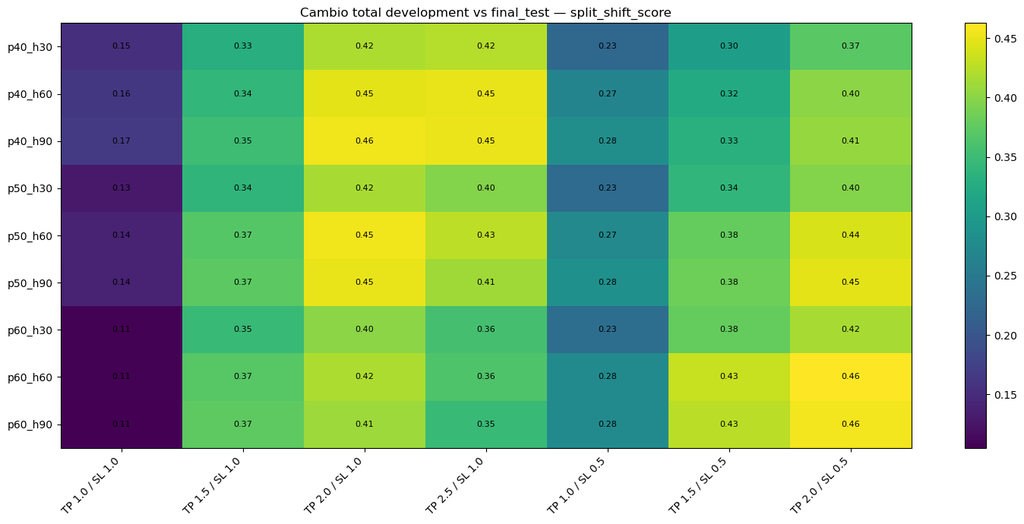

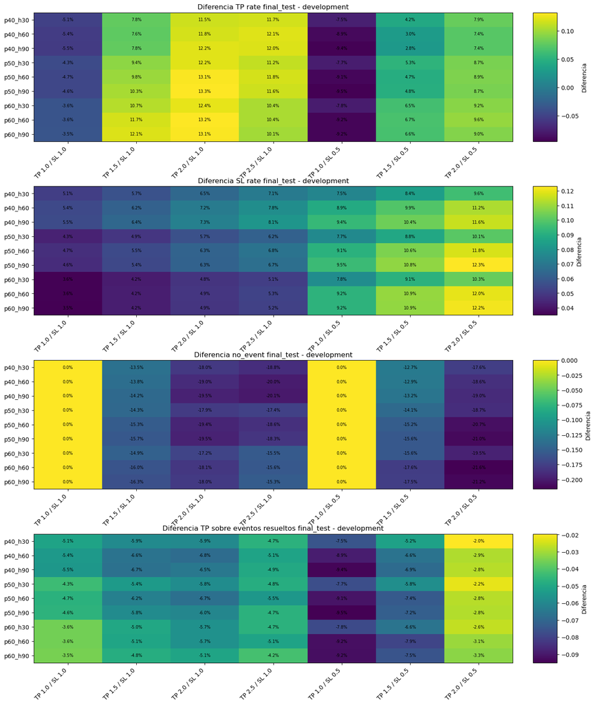

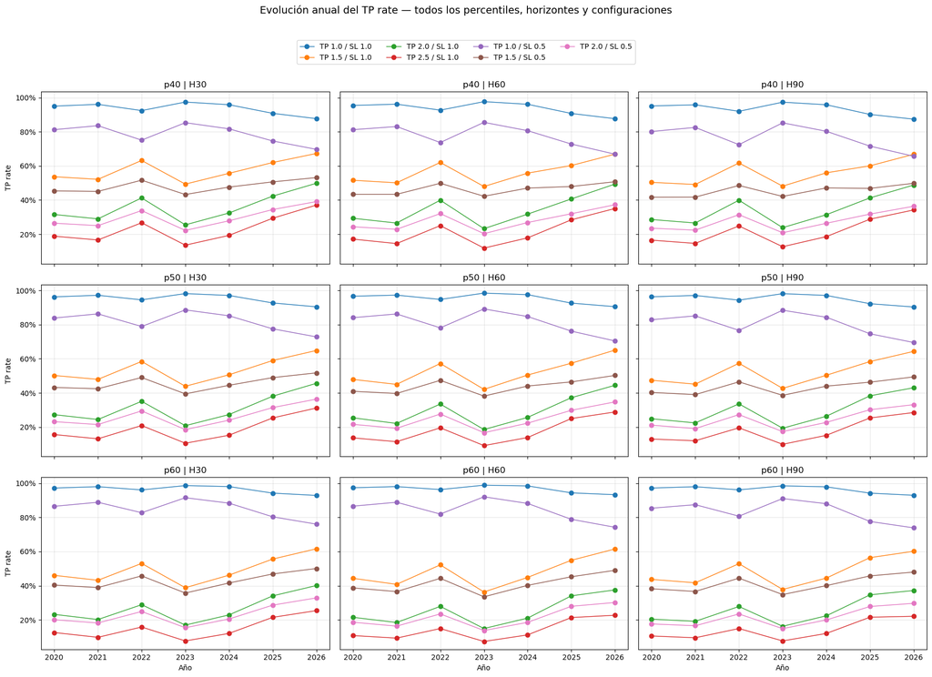

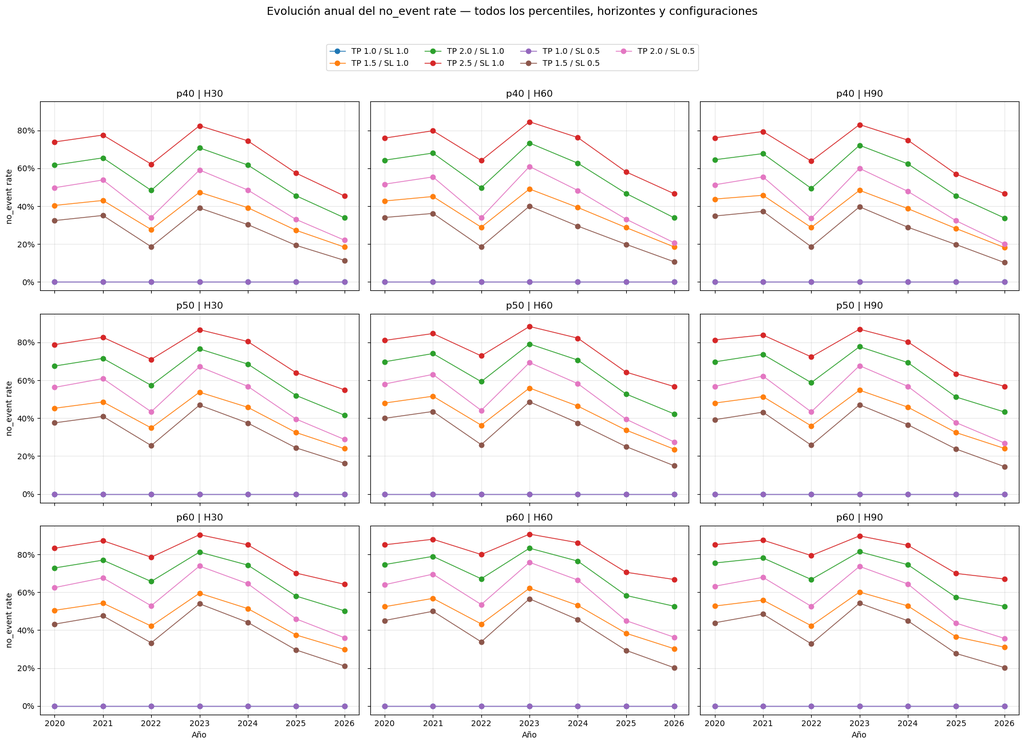

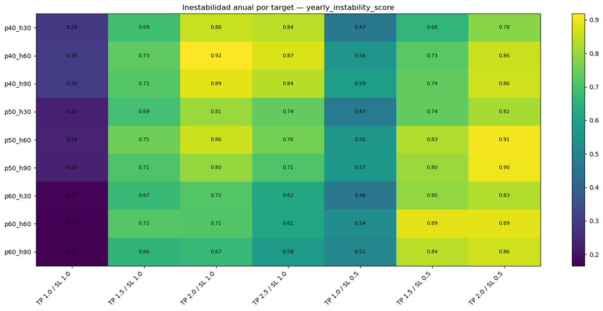

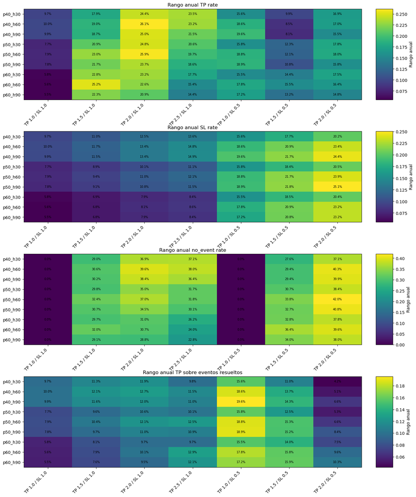

```
Celda 3 finalizada correctamente.
```

```python
            if pd.notna(value):
                ax.text(
                    j,
                    i,
                    f"{value:.1%}",
                    ha="center",
                    va="center",
                    fontsize=7
                )

    fig.colorbar(
        im,
        cax=cax,
        label="Rango anual"
    )

plt.show()

print("\nCelda 3 finalizada correctamente.")
```

### Celda 4 — Guardado y tabla final para observaciones

Esta celda te deja una tabla final lista para interpretar:

```
    df_bar_temporal_stability_final_table
```

y resume la estabilidad temporal de los **63 targets BAR** cruzando tres niveles:

```
    development vs final_test
    variación anual
    variación trimestral
```

```python
# Celda 4 — Guardado y tabla final para observaciones
# ============================================================

print("Guardado y tabla final de estabilidad temporal - BAR")
print("=" * 80)

# ------------------------------------------------------------
# Validar objetos necesarios
# ------------------------------------------------------------

required_objects = [
    "df_bar_temporal_stability",
    "df_bar_stability_split",
    "df_bar_stability_year",
    "df_bar_stability_quarter",
    "df_bar_split_comparison",
    "df_bar_split_change_by_config",
    "df_bar_split_change_by_target_base",
    "df_bar_yearly_stability_summary",
    "df_bar_yearly_stability_by_config",
    "df_bar_quarterly_stability_summary",
    "MNQ_TARGETS_PATH",
]

missing_objects = [
    obj for obj in required_objects
    if obj not in globals()
]

if missing_objects:
    raise NameError(
        "Faltan objetos necesarios. "
        f"Debes correr las celdas anteriores: {missing_objects}"
    )

# ------------------------------------------------------------
# Definir rutas de guardado
# ------------------------------------------------------------

MNQ_TARGETS_BAR_TEMPORAL_STABILITY_CSV = (
    MNQ_TARGETS_PATH / "mnq_targets_bar_temporal_stability.csv"
)

MNQ_TARGETS_BAR_STABILITY_SPLIT_CSV = (
    MNQ_TARGETS_PATH / "mnq_targets_bar_stability_split.csv"
)

MNQ_TARGETS_BAR_STABILITY_YEAR_CSV = (
    MNQ_TARGETS_PATH / "mnq_targets_bar_stability_year.csv"
)

MNQ_TARGETS_BAR_STABILITY_QUARTER_CSV = (
    MNQ_TARGETS_PATH / "mnq_targets_bar_stability_quarter.csv"
)

MNQ_TARGETS_BAR_SPLIT_COMPARISON_CSV = (
    MNQ_TARGETS_PATH / "mnq_targets_bar_split_comparison.csv"
)

MNQ_TARGETS_BAR_SPLIT_CHANGE_BY_CONFIG_CSV = (
    MNQ_TARGETS_PATH / "mnq_targets_bar_split_change_by_config.csv"
)

MNQ_TARGETS_BAR_SPLIT_CHANGE_BY_TARGET_BASE_CSV = (
    MNQ_TARGETS_PATH / "mnq_targets_bar_split_change_by_target_base.csv"
)

MNQ_TARGETS_BAR_YEARLY_STABILITY_SUMMARY_CSV = (
    MNQ_TARGETS_PATH / "mnq_targets_bar_yearly_stability_summary.csv"
)

MNQ_TARGETS_BAR_YEARLY_STABILITY_BY_CONFIG_CSV = (
    MNQ_TARGETS_PATH / "mnq_targets_bar_yearly_stability_by_config.csv"
)

MNQ_TARGETS_BAR_QUARTERLY_STABILITY_SUMMARY_CSV = (
    MNQ_TARGETS_PATH / "mnq_targets_bar_quarterly_stability_summary.csv"
)

MNQ_TARGETS_BAR_TEMPORAL_STABILITY_FINAL_TABLE_CSV = (
    MNQ_TARGETS_PATH / "mnq_targets_bar_temporal_stability_final_table.csv"
)

MNQ_TARGETS_BAR_TEMPORAL_STABILITY_REPORT_TXT = (
    MNQ_TARGETS_PATH / "mnq_targets_bar_temporal_stability_report.txt"
)

# ------------------------------------------------------------
# Columnas identificadoras
# ------------------------------------------------------------

id_cols = [
    "bar_col",
    "target_base",
    "horizon",
    "percentile",
    "tp_mult",
    "sl_mult",
    "tp_sl_config",
]

dev_label = "development_2020_2024"
test_label = "final_test_2025_2026"

# ------------------------------------------------------------
# Construir tabla final de estabilidad temporal
# ------------------------------------------------------------

split_cols = [
    "bar_col",
    "target_base",
    "horizon",
    "percentile",
    "tp_mult",
    "sl_mult",
    "tp_sl_config",

    f"tp_rate_{dev_label}",
    f"tp_rate_{test_label}",
    "tp_rate_diff_final_minus_dev",
    "tp_rate_abs_diff_final_vs_dev",

    f"sl_rate_{dev_label}",
    f"sl_rate_{test_label}",
    "sl_rate_diff_final_minus_dev",
    "sl_rate_abs_diff_final_vs_dev",

    f"no_event_rate_{dev_label}",
    f"no_event_rate_{test_label}",
    "no_event_rate_diff_final_minus_dev",
    "no_event_rate_abs_diff_final_vs_dev",

    f"resolved_rate_{dev_label}",
    f"resolved_rate_{test_label}",
    "resolved_rate_diff_final_minus_dev",
    "resolved_rate_abs_diff_final_vs_dev",

    f"tp_share_over_resolved_{dev_label}",
    f"tp_share_over_resolved_{test_label}",
    "tp_share_over_resolved_diff_final_minus_dev",
    "tp_share_over_resolved_abs_diff_final_vs_dev",

    f"expectancy_units_{dev_label}",
    f"expectancy_units_{test_label}",
    "expectancy_units_diff_final_minus_dev",
    "expectancy_units_abs_diff_final_vs_dev",

    f"event_step_mean_{dev_label}",
    f"event_step_mean_{test_label}",
    "event_step_mean_diff_final_minus_dev",
    "event_step_mean_abs_diff_final_vs_dev",

    "split_shift_score",
]

available_split_cols = [
    col for col in split_cols
    if col in df_bar_split_comparison.columns
]

df_bar_temporal_stability_final_table = (
    df_bar_split_comparison[available_split_cols]
    .copy()
)

# ------------------------------------------------------------
# Añadir resumen anual
# ------------------------------------------------------------

yearly_cols = [
    "bar_col",
    "target_base",
    "horizon",
    "percentile",
    "tp_mult",
    "sl_mult",
    "tp_sl_config",

    "n_years",

    "tp_rate_mean",
    "tp_rate_std",
    "tp_rate_min",
    "tp_rate_max",
    "tp_rate_range",

    "sl_rate_mean",
    "sl_rate_std",
    "sl_rate_min",
    "sl_rate_max",
    "sl_rate_range",

    "no_event_rate_mean",
    "no_event_rate_std",
    "no_event_rate_min",
    "no_event_rate_max",
    "no_event_rate_range",

    "tp_share_mean",
    "tp_share_std",
    "tp_share_min",
    "tp_share_max",
    "tp_share_range",

    "expectancy_mean",
    "expectancy_std",
    "expectancy_min",
    "expectancy_max",
    "expectancy_range",

    "event_step_mean_mean",
    "event_step_mean_std",
    "event_step_mean_min",
    "event_step_mean_max",
    "event_step_mean_range",

    "yearly_instability_score",
]

available_yearly_cols = [
    col for col in yearly_cols
    if col in df_bar_yearly_stability_summary.columns
]

df_yearly_merge = (
    df_bar_yearly_stability_summary[available_yearly_cols]
    .copy()
)

rename_yearly_cols = {
    col: f"yearly_{col}"
    for col in df_yearly_merge.columns
    if col not in id_cols
}

df_yearly_merge = df_yearly_merge.rename(columns=rename_yearly_cols)

df_bar_temporal_stability_final_table = (
    df_bar_temporal_stability_final_table
    .merge(
        df_yearly_merge,
        on=id_cols,
        how="left"
    )
)
```

```python
# ------------------------------------------------------------
# Añadir resumen trimestral
# ------------------------------------------------------------

quarterly_cols = [
    "bar_col",
    "target_base",
    "horizon",
    "percentile",
    "tp_mult",
    "sl_mult",
    "tp_sl_config",

    "n_quarters",

    "tp_rate_mean",
    "tp_rate_std",
    "tp_rate_range",

    "sl_rate_mean",
    "sl_rate_std",
    "sl_rate_range",

    "no_event_rate_mean",
    "no_event_rate_std",
    "no_event_rate_range",

    "tp_share_mean",
    "tp_share_std",
    "tp_share_range",

    "expectancy_mean",
    "expectancy_std",
    "expectancy_range",

    "event_step_mean_mean",
    "event_step_mean_std",
    "event_step_mean_range",

    "quarterly_instability_score",
]

available_quarterly_cols = [
    col for col in quarterly_cols
    if col in df_bar_quarterly_stability_summary.columns
]

df_quarterly_merge = (
    df_bar_quarterly_stability_summary[available_quarterly_cols]
    .copy()
)

rename_quarterly_cols = {
    col: f"quarterly_{col}"
    for col in df_quarterly_merge.columns
    if col not in id_cols
}

df_quarterly_merge = df_quarterly_merge.rename(columns=rename_quarterly_cols)

df_bar_temporal_stability_final_table = (
    df_bar_temporal_stability_final_table
    .merge(
        df_quarterly_merge,
        on=id_cols,
        how="left"
    )
)

# ------------------------------------------------------------
# Clasificación descriptiva de estabilidad
# ------------------------------------------------------------
# Esta clasificación es relativa al conjunto de 63 targets.
# No selecciona el target final.
# ------------------------------------------------------------

df_bar_temporal_stability_final_table["temporal_instability_score"] = (
    df_bar_temporal_stability_final_table["split_shift_score"].fillna(0)
    + df_bar_temporal_stability_final_table["yearly_yearly_instability_score"].fillna(0)
    + df_bar_temporal_stability_final_table["quarterly_quarterly_instability_score"].fillna(0)
)

q33 = df_bar_temporal_stability_final_table["temporal_instability_score"].quantile(0.33)
q66 = df_bar_temporal_stability_final_table["temporal_instability_score"].quantile(0.66)

def classify_temporal_stability(score):
    """
    Clasificación relativa de estabilidad temporal.
    Menor score = más estable.
    Mayor score = más variable temporalmente.
    """

    if pd.isna(score):
        return "sin_clasificar"

    if score <= q33:
        return "más_estable"

    if score <= q66:
        return "estabilidad_intermedia"

    return "más_inestable"


df_bar_temporal_stability_final_table["temporal_stability_profile"] = (
    df_bar_temporal_stability_final_table["temporal_instability_score"]
    .apply(classify_temporal_stability)
)

df_bar_temporal_stability_final_table = (
    df_bar_temporal_stability_final_table
    .sort_values(
        [
            "temporal_instability_score",
            "percentile",
            "horizon",
            "sl_mult",
            "tp_mult",
        ],
        ascending=[True, True, True, True, True]
    )
    .reset_index(drop=True)
)

# ------------------------------------------------------------
# Guardar tablas principales
# ------------------------------------------------------------

df_bar_temporal_stability.to_csv(
    MNQ_TARGETS_BAR_TEMPORAL_STABILITY_CSV,
    index=False
)

df_bar_stability_split.to_csv(
    MNQ_TARGETS_BAR_STABILITY_SPLIT_CSV,
    index=False
)

df_bar_stability_year.to_csv(
    MNQ_TARGETS_BAR_STABILITY_YEAR_CSV,
    index=False
)

df_bar_stability_quarter.to_csv(
    MNQ_TARGETS_BAR_STABILITY_QUARTER_CSV,
    index=False
)

df_bar_split_comparison.to_csv(
    MNQ_TARGETS_BAR_SPLIT_COMPARISON_CSV,
    index=False
)

df_bar_split_change_by_config.to_csv(
    MNQ_TARGETS_BAR_SPLIT_CHANGE_BY_CONFIG_CSV,
    index=False
)

df_bar_split_change_by_target_base.to_csv(
    MNQ_TARGETS_BAR_SPLIT_CHANGE_BY_TARGET_BASE_CSV,
    index=False
)

df_bar_yearly_stability_summary.to_csv(
    MNQ_TARGETS_BAR_YEARLY_STABILITY_SUMMARY_CSV,
    index=False
)

df_bar_yearly_stability_by_config.to_csv(
    MNQ_TARGETS_BAR_YEARLY_STABILITY_BY_CONFIG_CSV,
    index=False
)

df_bar_quarterly_stability_summary.to_csv(
    MNQ_TARGETS_BAR_QUARTERLY_STABILITY_SUMMARY_CSV,
    index=False
)

df_bar_temporal_stability_final_table.to_csv(
    MNQ_TARGETS_BAR_TEMPORAL_STABILITY_FINAL_TABLE_CSV,
    index=False
)

# ------------------------------------------------------------
# Tablas compactas para imprimir
# ------------------------------------------------------------

split_change_config_cols = [
    "tp_sl_config",
    "tp_mult",
    "sl_mult",
    "n_targets",

    "tp_rate_diff_mean",
    "tp_rate_abs_diff_mean",

    "sl_rate_diff_mean",
    "sl_rate_abs_diff_mean",

    "no_event_rate_diff_mean",
    "no_event_rate_abs_diff_mean",

    "tp_share_diff_mean",
    "tp_share_abs_diff_mean",

    "split_shift_score_mean",
    "split_shift_score_max",
]

split_change_target_cols = [
    "target_base",
    "percentile",
    "horizon",
    "n_configs",

    "tp_rate_diff_mean",
    "tp_rate_abs_diff_mean",

    "sl_rate_diff_mean",
    "sl_rate_abs_diff_mean",

    "no_event_rate_diff_mean",
    "no_event_rate_abs_diff_mean",

    "tp_share_diff_mean",
    "tp_share_abs_diff_mean",

    "split_shift_score_mean",
    "split_shift_score_max",
]

yearly_config_cols = [
    "tp_sl_config",
    "tp_mult",
    "sl_mult",
    "n_targets",

    "tp_rate_range_mean",
    "sl_rate_range_mean",
    "no_event_rate_range_mean",
    "tp_share_range_mean",

    "expectancy_range_mean",
    "event_step_range_mean",

    "yearly_instability_score_mean",
    "yearly_instability_score_max",
]

final_obs_cols = [
    "bar_col",
    "target_base",
    "tp_sl_config",

    f"tp_rate_{dev_label}",
    f"tp_rate_{test_label}",
    "tp_rate_diff_final_minus_dev",

    f"sl_rate_{dev_label}",
    f"sl_rate_{test_label}",
    "sl_rate_diff_final_minus_dev",

    f"no_event_rate_{dev_label}",
    f"no_event_rate_{test_label}",
    "no_event_rate_diff_final_minus_dev",
```

```python
    f"tp_share_over_resolved_{dev_label}",
    f"tp_share_over_resolved_{test_label}",
    "tp_share_over_resolved_diff_final_minus_dev",

    "split_shift_score",
    "yearly_yearly_instability_score",
    "quarterly_quarterly_instability_score",
    "temporal_instability_score",
    "temporal_stability_profile",
]

available_final_obs_cols = [
    col for col in final_obs_cols
    if col in df_bar_temporal_stability_final_table.columns
]

# ------------------------------------------------------------
# Impresiones principales
# ------------------------------------------------------------

print("\nResumen de cambio development vs final_test por configuración TP/SL:")
print(
    df_bar_split_change_by_config[split_change_config_cols]
    .to_string(
        index=False,
        formatters={
            "tp_rate_diff_mean": "{:.2%}".format,
            "tp_rate_abs_diff_mean": "{:.2%}".format,
            "sl_rate_diff_mean": "{:.2%}".format,
            "sl_rate_abs_diff_mean": "{:.2%}".format,
            "no_event_rate_diff_mean": "{:.2%}".format,
            "no_event_rate_abs_diff_mean": "{:.2%}".format,
            "tp_share_diff_mean": "{:.2%}".format,
            "tp_share_abs_diff_mean": "{:.2%}".format,
            "split_shift_score_mean": "{:.3f}".format,
            "split_shift_score_max": "{:.3f}".format,
        }
    )
)

print("\nResumen de cambio development vs final_test por percentil y horizonte:")
print(
    df_bar_split_change_by_target_base[split_change_target_cols]
    .to_string(
        index=False,
        formatters={
            "tp_rate_diff_mean": "{:.2%}".format,
            "tp_rate_abs_diff_mean": "{:.2%}".format,
            "sl_rate_diff_mean": "{:.2%}".format,
            "sl_rate_abs_diff_mean": "{:.2%}".format,
            "no_event_rate_diff_mean": "{:.2%}".format,
            "no_event_rate_abs_diff_mean": "{:.2%}".format,
            "tp_share_diff_mean": "{:.2%}".format,
            "tp_share_abs_diff_mean": "{:.2%}".format,
            "split_shift_score_mean": "{:.3f}".format,
            "split_shift_score_max": "{:.3f}".format,
        }
    )
)

print("\nEstabilidad anual agregada por configuración TP/SL:")
print(
    df_bar_yearly_stability_by_config[yearly_config_cols]
    .to_string(
        index=False,
        formatters={
            "tp_rate_range_mean": "{:.2%}".format,
            "sl_rate_range_mean": "{:.2%}".format,
            "no_event_rate_range_mean": "{:.2%}".format,
            "tp_share_range_mean": "{:.2%}".format,
            "expectancy_range_mean": "{:.3f}".format,
            "event_step_range_mean": "{:.2f}".format,
            "yearly_instability_score_mean": "{:.3f}".format,
            "yearly_instability_score_max": "{:.3f}".format,
        }
    )
)

print("\nTabla final de estabilidad temporal — 63 targets BAR:")
print(
    df_bar_temporal_stability_final_table[available_final_obs_cols]
    .to_string(
        index=False,
        formatters={
            f"tp_rate_{dev_label}": "{:.2%}".format,
            f"tp_rate_{test_label}": "{:.2%}".format,
            "tp_rate_diff_final_minus_dev": "{:.2%}".format,

            f"sl_rate_{dev_label}": "{:.2%}".format,
            f"sl_rate_{test_label}": "{:.2%}".format,
            "sl_rate_diff_final_minus_dev": "{:.2%}".format,

            f"no_event_rate_{dev_label}": "{:.2%}".format,
            f"no_event_rate_{test_label}": "{:.2%}".format,
            "no_event_rate_diff_final_minus_dev": "{:.2%}".format,

            f"tp_share_over_resolved_{dev_label}": "{:.2%}".format,
            f"tp_share_over_resolved_{test_label}": "{:.2%}".format,
            "tp_share_over_resolved_diff_final_minus_dev": "{:.2%}".format,

            "split_shift_score": "{:.3f}".format,
            "yearly_yearly_instability_score": "{:.3f}".format,
            "quarterly_quarterly_instability_score": "{:.3f}".format,
            "temporal_instability_score": "{:.3f}".format,
        }
    )
)

# ------------------------------------------------------------
# Top 15 más estables y más inestables
# ------------------------------------------------------------

print("\nTop 15 targets temporalmente más estables:")
print(
    df_bar_temporal_stability_final_table[available_final_obs_cols]
    .head(15)
    .to_string(
        index=False,
        formatters={
            f"tp_rate_{dev_label}": "{:.2%}".format,
            f"tp_rate_{test_label}": "{:.2%}".format,
            "tp_rate_diff_final_minus_dev": "{:.2%}".format,

            f"sl_rate_{dev_label}": "{:.2%}".format,
            f"sl_rate_{test_label}": "{:.2%}".format,
            "sl_rate_diff_final_minus_dev": "{:.2%}".format,

            f"no_event_rate_{dev_label}": "{:.2%}".format,
            f"no_event_rate_{test_label}": "{:.2%}".format,
            "no_event_rate_diff_final_minus_dev": "{:.2%}".format,

            f"tp_share_over_resolved_{dev_label}": "{:.2%}".format,
            f"tp_share_over_resolved_{test_label}": "{:.2%}".format,
            "tp_share_over_resolved_diff_final_minus_dev": "{:.2%}".format,

            "split_shift_score": "{:.3f}".format,
            "yearly_yearly_instability_score": "{:.3f}".format,
            "quarterly_quarterly_instability_score": "{:.3f}".format,
            "temporal_instability_score": "{:.3f}".format,
        }
    )
)

print("\nTop 15 targets temporalmente más inestables:")
print(
    df_bar_temporal_stability_final_table[available_final_obs_cols]
    .tail(15)
    .sort_values("temporal_instability_score", ascending=False)
    .to_string(
        index=False,
        formatters={
            f"tp_rate_{dev_label}": "{:.2%}".format,
            f"tp_rate_{test_label}": "{:.2%}".format,
            "tp_rate_diff_final_minus_dev": "{:.2%}".format,

            f"sl_rate_{dev_label}": "{:.2%}".format,
            f"sl_rate_{test_label}": "{:.2%}".format,
            "sl_rate_diff_final_minus_dev": "{:.2%}".format,

            f"no_event_rate_{dev_label}": "{:.2%}".format,
            f"no_event_rate_{test_label}": "{:.2%}".format,
            "no_event_rate_diff_final_minus_dev": "{:.2%}".format,
```

```python
            f"tp_share_over_resolved_{dev_label}": "{:.2%}".format,
            f"tp_share_over_resolved_{test_label}": "{:.2%}".format,
            "tp_share_over_resolved_diff_final_minus_dev": "{:.2%}".format,

            "split_shift_score": "{:.3f}".format,
            "yearly_yearly_instability_score": "{:.3f}".format,
            "quarterly_quarterly_instability_score": "{:.3f}".format,
            "temporal_instability_score": "{:.3f}".format,
        }
    )
)

# ------------------------------------------------------------
# Conteo por perfil de estabilidad temporal
# ------------------------------------------------------------

df_bar_temporal_stability_profile_counts = (
    df_bar_temporal_stability_final_table
    .groupby("temporal_stability_profile", as_index=False)
    .agg(
        n_targets=("bar_col", "count"),

        split_shift_score_mean=("split_shift_score", "mean"),
        yearly_instability_score_mean=("yearly_yearly_instability_score", "mean"),
        quarterly_instability_score_mean=("quarterly_quarterly_instability_score", "mean"),
        temporal_instability_score_mean=("temporal_instability_score", "mean"),

        tp_rate_diff_abs_mean=("tp_rate_abs_diff_final_vs_dev", "mean"),
        sl_rate_diff_abs_mean=("sl_rate_abs_diff_final_vs_dev", "mean"),
        no_event_rate_diff_abs_mean=("no_event_rate_abs_diff_final_vs_dev", "mean"),
        tp_share_diff_abs_mean=("tp_share_over_resolved_abs_diff_final_vs_dev", "mean"),
    )
    .sort_values("temporal_instability_score_mean")
    .reset_index(drop=True)
)

print("\nConteo por perfil de estabilidad temporal:")
print(
    df_bar_temporal_stability_profile_counts
    .to_string(
        index=False,
        formatters={
            "split_shift_score_mean": "{:.3f}".format,
            "yearly_instability_score_mean": "{:.3f}".format,
            "quarterly_instability_score_mean": "{:.3f}".format,
            "temporal_instability_score_mean": "{:.3f}".format,
            "tp_rate_diff_abs_mean": "{:.2%}".format,
            "sl_rate_diff_abs_mean": "{:.2%}".format,
            "no_event_rate_diff_abs_mean": "{:.2%}".format,
            "tp_share_diff_abs_mean": "{:.2%}".format,
        }
    )
)

# ------------------------------------------------------------
# Guardar reporte TXT
# ------------------------------------------------------------

with MNQ_TARGETS_BAR_TEMPORAL_STABILITY_REPORT_TXT.open("w", encoding="utf-8") as f:
    f.write("4.9. Estabilidad temporal - BAR\n")
    f.write("=" * 100 + "\n\n")

    f.write("Resumen de cambio development vs final_test por configuración TP/SL\n")
    f.write("-" * 100 + "\n")
    f.write(
        df_bar_split_change_by_config[split_change_config_cols]
        .to_string(
            index=False,
            formatters={
                "tp_rate_diff_mean": "{:.2%}".format,
                "tp_rate_abs_diff_mean": "{:.2%}".format,
                "sl_rate_diff_mean": "{:.2%}".format,
                "sl_rate_abs_diff_mean": "{:.2%}".format,
                "no_event_rate_diff_mean": "{:.2%}".format,
                "no_event_rate_abs_diff_mean": "{:.2%}".format,
                "tp_share_diff_mean": "{:.2%}".format,
                "tp_share_abs_diff_mean": "{:.2%}".format,
                "split_shift_score_mean": "{:.3f}".format,
                "split_shift_score_max": "{:.3f}".format,
            }
        )
    )

    f.write("\n\n")
    f.write("Resumen de cambio development vs final_test por percentil y horizonte\n")
    f.write("-" * 100 + "\n")
    f.write(
        df_bar_split_change_by_target_base[split_change_target_cols]
        .to_string(
            index=False,
            formatters={
                "tp_rate_diff_mean": "{:.2%}".format,
                "tp_rate_abs_diff_mean": "{:.2%}".format,
                "sl_rate_diff_mean": "{:.2%}".format,
                "sl_rate_abs_diff_mean": "{:.2%}".format,
                "no_event_rate_diff_mean": "{:.2%}".format,
                "no_event_rate_abs_diff_mean": "{:.2%}".format,
                "tp_share_diff_mean": "{:.2%}".format,
                "tp_share_abs_diff_mean": "{:.2%}".format,
                "split_shift_score_mean": "{:.3f}".format,
                "split_shift_score_max": "{:.3f}".format,
            }
        )
    )

    f.write("\n\n")
    f.write("Estabilidad anual agregada por configuración TP/SL\n")
    f.write("-" * 100 + "\n")
    f.write(
        df_bar_yearly_stability_by_config[yearly_config_cols]
        .to_string(
            index=False,
            formatters={
                "tp_rate_range_mean": "{:.2%}".format,
                "sl_rate_range_mean": "{:.2%}".format,
                "no_event_rate_range_mean": "{:.2%}".format,
                "tp_share_range_mean": "{:.2%}".format,
                "expectancy_range_mean": "{:.3f}".format,
                "event_step_range_mean": "{:.2f}".format,
                "yearly_instability_score_mean": "{:.3f}".format,
                "yearly_instability_score_max": "{:.3f}".format,
            }
        )
    )

    f.write("\n\n")
    f.write("Tabla final de estabilidad temporal — 63 targets BAR\n")
    f.write("-" * 100 + "\n")
    f.write(
        df_bar_temporal_stability_final_table[available_final_obs_cols]
        .to_string(
            index=False,
            formatters={
                f"tp_rate_{dev_label}": "{:.2%}".format,
                f"tp_rate_{test_label}": "{:.2%}".format,
                "tp_rate_diff_final_minus_dev": "{:.2%}".format,

                f"sl_rate_{dev_label}": "{:.2%}".format,
                f"sl_rate_{test_label}": "{:.2%}".format,
                "sl_rate_diff_final_minus_dev": "{:.2%}".format,

                f"no_event_rate_{dev_label}": "{:.2%}".format,
                f"no_event_rate_{test_label}": "{:.2%}".format,
                "no_event_rate_diff_final_minus_dev": "{:.2%}".format,

                f"tp_share_over_resolved_{dev_label}": "{:.2%}".format,
                f"tp_share_over_resolved_{test_label}": "{:.2%}".format,
                "tp_share_over_resolved_diff_final_minus_dev": "{:.2%}".format,
```

```python
                "split_shift_score": "{:.3f}".format,
                "yearly_yearly_instability_score": "{:.3f}".format,
                "quarterly_quarterly_instability_score": "{:.3f}".format,
                "temporal_instability_score": "{:.3f}".format,
            }
        )
    )

    f.write("\n\n")
    f.write("Conteo por perfil de estabilidad temporal\n")
    f.write("-" * 100 + "\n")
    f.write(
        df_bar_temporal_stability_profile_counts
        .to_string(
            index=False,
            formatters={
                "split_shift_score_mean": "{:.3f}".format,
                "yearly_instability_score_mean": "{:.3f}".format,
                "quarterly_instability_score_mean": "{:.3f}".format,
                "temporal_instability_score_mean": "{:.3f}".format,
                "tp_rate_diff_abs_mean": "{:.2%}".format,
                "sl_rate_diff_abs_mean": "{:.2%}".format,
                "no_event_rate_diff_abs_mean": "{:.2%}".format,
                "tp_share_diff_abs_mean": "{:.2%}".format,
            }
        )
    )

# ------------------------------------------------------------
# Confirmación final
# ------------------------------------------------------------

print("\nArchivos guardados:")
print(f"Estabilidad temporal completa:         {MNQ_TARGETS_BAR_TEMPORAL_STABILITY_CSV}")
print(f"Estabilidad por split:                 {MNQ_TARGETS_BAR_STABILITY_SPLIT_CSV}")
print(f"Estabilidad por año:                   {MNQ_TARGETS_BAR_STABILITY_YEAR_CSV}")
print(f"Estabilidad por trimestre:             {MNQ_TARGETS_BAR_STABILITY_QUARTER_CSV}")
print(f"Comparación development vs final_test: {MNQ_TARGETS_BAR_SPLIT_COMPARISON_CSV}")
print(f"Cambio por configuración TP/SL:        {MNQ_TARGETS_BAR_SPLIT_CHANGE_BY_CONFIG_CSV}")
print(f"Cambio por percentil y horizonte:      {MNQ_TARGETS_BAR_SPLIT_CHANGE_BY_TARGET_BASE_CSV}")
print(f"Estabilidad anual por target:          {MNQ_TARGETS_BAR_YEARLY_STABILITY_SUMMARY_CSV}")
print(f"Estabilidad anual por configuración:   {MNQ_TARGETS_BAR_YEARLY_STABILITY_BY_CONFIG_CSV}")
print(f"Estabilidad trimestral por target:     {MNQ_TARGETS_BAR_QUARTERLY_STABILITY_SUMMARY_CSV}")
print(f"Tabla final estabilidad temporal:      {MNQ_TARGETS_BAR_TEMPORAL_STABILITY_FINAL_TABLE_CSV}")
print(f"Reporte TXT:                           {MNQ_TARGETS_BAR_TEMPORAL_STABILITY_REPORT_TXT}")

print("\nCelda 4 finalizada correctamente.")
```

```
Guardado y tabla final de estabilidad temporal - BAR
================================================================================

Resumen de cambio development vs final_test por configuración TP/SL:
   tp_sl_config  tp_mult  sl_mult  n_targets tp_rate_diff_mean tp_rate_abs_diff_mean sl_rate_diff_mean sl_rate_abs_diff_mean no_event_rate_diff_mean no_event_rate_abs_diff_mean tp_share_diff_mean tp_share_abs_diff_mean split_shift_score_mean split_shift_score_max
TP 1.0 / SL 0.5      1.0      0.5          9            -8.70%                 8.70%             8.70%                 8.70%                   0.00%                       0.00%             -8.70%                  8.70%                  0.261                 0.285
TP 1.5 / SL 0.5      1.5      0.5          9             4.96%                 4.96%             9.99%                 9.99%                 -14.95%                      14.95%             -6.79%                  6.79%                  0.367                 0.432
TP 2.0 / SL 0.5      2.0      0.5          9             8.54%                 8.54%            11.22%                11.22%                 -19.76%                      19.76%             -2.71%                  2.71%                  0.422                 0.463
TP 1.0 / SL 1.0      1.0      1.0          9            -4.48%                 4.48%             4.48%                 4.48%                   0.00%                       0.00%             -4.48%                  4.48%                  0.134                 0.166
TP 1.5 / SL 1.0      1.5      1.0          9             9.68%                 9.68%             5.20%                 5.20%                 -14.88%                      14.88%             -5.72%                  5.72%                  0.355                 0.374
TP 2.0 / SL 1.0      2.0      1.0          9            12.52%                12.52%             5.98%                 5.98%                 -18.50%                      18.50%             -6.03%                  6.03%                  0.430                 0.455
TP 2.5 / SL 1.0      2.5      1.0          9            11.24%                11.24%             6.50%                 6.50%                 -17.74%                      17.74%             -4.85%                  4.85%                  0.403                 0.452

Resumen de cambio development vs final_test por percentil y horizonte:
target_base  percentile  horizon  n_configs tp_rate_diff_mean tp_rate_abs_diff_mean sl_rate_diff_mean sl_rate_abs_diff_mean no_event_rate_diff_mean no_event_rate_abs_diff_mean tp_share_diff_mean tp_share_abs_diff_mean split_shift_score_mean split_shift_score_max
    p40_h30          40       30          7             4.35%                 7.95%             7.15%                 7.15%                 -11.50%                      11.50%             -5.18%                  5.18%                  0.318                 0.423
    p40_h60          40       60          7             3.93%                 8.03%             8.10%                 8.10%                 -12.03%                      12.03%             -6.06%                  6.06%                  0.342                 0.451
    p40_h90          40       90          7             3.90%                 8.16%             8.39%                 8.39%                 -12.29%                      12.29%             -6.09%                  6.09%                  0.349                 0.455
    p50_h30          50       30          7             4.96%                 8.40%             6.81%                 6.81%                 -11.77%                      11.77%             -5.15%                  5.15%                  0.321                 0.416
    p50_h60          50       60          7             4.92%                 8.86%             7.82%                 7.82%                 -12.74%                      12.74%             -6.05%                  6.05%                  0.355                 0.455
    p50_h90          50       90          7             4.92%                 8.96%             7.95%                 7.95%                 -12.87%                      12.87%             -5.82%                  5.82%                  0.356                 0.451
    p60_h30          60       30          7             5.40%                 8.64%             6.42%                 6.42%                 -11.81%                      11.81%             -5.13%                  5.13%                  0.320                 0.416
    p60_h60          60       60          7             5.56%                 9.21%             7.14%                 7.14%                 -12.71%                      12.71%             -5.66%                  5.66%                  0.347                 0.463
    p60_h90          60       90          7             5.46%                 9.10%             7.15%                 7.15%                 -12.62%                      12.62%             -5.37%                  5.37%                  0.342                 0.457

Estabilidad anual agregada por configuración TP/SL:
```

[output cut: 132 more lines]

### Observaciones preliminares — Estabilidad temporal BAR

Luego de corregir la segmentación trimestral, el análisis de estabilidad temporal queda correctamente calculado trimestre a trimestre. Es decir, los períodos trimestrales ya no agrupan simplemente `Q1`, `Q2`, `Q3` y `Q4`, sino que ahora distinguen períodos temporales específicos como `2020Q1`, `2020Q2`, ..., `2026Q2`.

Esto aumenta la cantidad de observaciones temporales analizadas y permite evaluar mejor la variación de los targets `BAR` a lo largo del tiempo. La tabla final considera los 63 targets `BAR`, evaluados por `dataset_split`, año y trimestre temporal.

El primer resultado importante es que el patrón general se mantiene: el período `final_test_2025_2026` presenta más actividad que el período `development_2020_2024`. En la mayoría de las configuraciones disminuye el `no_event`, aumentan los TP y también aumentan los SL. Esto indica que las barreras calibradas con datos de 2020–2024 fueron alcanzadas con mayor frecuencia en 2025–2026.

Por configuración TP/SL, el comportamiento es bastante claro. `TP 1.0 / SL 1.0` es la configuración más estable, con el menor `split_shift_score_mean`, igual a `0.134`. Sin embargo, debe seguir interpretándose como benchmark, no como target operativo principal, porque el TP coincide con el threshold base utilizado para construir `DIR`.

La configuración `TP 1.0 / SL 0.5` también aparece relativamente estable, pero su interpretación es distinta. No tiene `no_event`, porque el TP base se alcanza por construcción, pero el stop es más ajustado. En `final_test_2025_2026`, el TP cae en promedio `-8.70%` y el SL sube `+8.70%`. Esto muestra que, aunque resuelve siempre, es sensible al ruido y al movimiento adverso.

La configuración `TP 1.5 / SL 1.0` mantiene una posición intermedia. En promedio, el TP aumenta `+9.68%`, el SL aumenta `+5.20%` y el `no_event` baja `-14.88%` en `final_test_2025_2026`. Esto significa que en el período final hubo más operaciones resueltas, pero también más riesgo de tocar SL. La proporción de TP entre eventos resueltos cae `-5.72%`, lo que indica que el entorno fue más activo, pero no necesariamente más limpio.

Las configuraciones más inestables son principalmente `TP 2.0 / SL 0.5`, `TP 2.0 / SL 1.0` y algunas variantes de `TP 2.5 / SL 1.0`. Esto es esperable, porque objetivos más lejanos son más dependientes del contexto de volatilidad. Cuando el mercado se mueve más, muchos casos que antes quedaban como `no_event` pasan a resolverse como TP o SL, generando cambios temporales más fuertes.

El análisis por percentil y horizonte muestra que la fuente principal de inestabilidad no parece ser el horizonte por sí solo. Los `split_shift_score_mean` por combinación `p/h` se mantienen en un rango relativamente acotado, aproximadamente entre `0.318` y `0.356`. Esto sugiere que la configuración TP/SL influye más que elegir `H30`, `H60` o `H90`.

El análisis anual confirma la misma lectura. `TP 1.0 / SL 1.0` tiene la menor inestabilidad anual promedio, mientras que `TP 2.0 / SL 0.5` y `TP 2.0 / SL 1.0` tienen las mayores variaciones. En particular, `TP 2.0 / SL 0.5` presenta un `yearly_instability_score_mean` de `0.857`, y `TP 2.0 / SL 1.0` un valor de `0.804`.

El análisis trimestral corregido refuerza esta conclusión. Al evaluar trimestre a trimestre, las configuraciones más sensibles vuelven a ser las que combinan TP exigente con SL ajustado, especialmente `TP 2.0 / SL 0.5`. Esto confirma que esas variantes dependen demasiado del contexto temporal y pueden cambiar de comportamiento de forma importante entre períodos.

En cambio, `TP 1.5 / SL 1.0` no aparece como la configuración más estable, pero tampoco como la más inestable. Su perfil es intermedio: tiene cambios temporales relevantes, pero conserva una estructura operativa razonable. Por eso sigue siendo una candidata práctica para continuar el análisis, siempre teniendo presente que el modelo deberá aprender a distinguir contextos de mercado más activos de contextos más laterales.

En síntesis, el análisis de estabilidad temporal muestra que los targets `BAR` no son estacionarios. El comportamiento cambia entre años y trimestres, especialmente cuando las barreras son más exigentes o cuando el stop es demasiado ajustado. Esto no invalida los targets, pero confirma que la etapa de modelado deberá considerar explícitamente variables de contexto, volatilidad, régimen intradiario y comportamiento reciente del mercado.

De forma preliminar:

```
    TP 1.0 / SL 1.0  → más estable, pero benchmark por construcción.
    TP 1.0 / SL 0.5  → estable en resolución, pero sensible al ruido y al SL.
    TP 1.5 / SL 1.0  → estabilidad intermedia y candidata operativa principal.
    TP 2.0 / SL 1.0  → más exigente y más dependiente del contexto.
    TP 2.5 / SL 1.0  → muy exigente, con alta dependencia temporal.
    SL 0.5           → aumenta la sensibilidad al ruido y la inestabilidad.
```

La conclusión operativa se mantiene: `TP 1.5 / SL 1.0` sigue siendo una de las configuraciones más razonables para continuar el análisis, no porque sea la más estable, sino porque ofrece un equilibrio aceptable entre exigencia, frecuencia de TP, baja frecuencia relativa de SL y estabilidad temporal intermedia.

## 4.10. Análisis por régimen intradiario

En este punto se analiza el comportamiento de los targets `BAR` según el régimen intradiario.

El objetivo es evaluar si las métricas operativas de `BAR` cambian entre las distintas etapas de la sesión. Esto es importante porque el mercado no se comporta igual durante el `Overnight`, el `Pre-market`, la apertura, la sesión regular o el cierre.

El análisis se realizará sobre los 63 targets `BAR`, considerando todos los percentiles, horizontes y configuraciones TP/SL.

Se analizarán principalmente:

```
    Tasa de operaciones válidas
    Frecuencia de TP
    Frecuencia de SL
    Frecuencia de no_event
    Eventos resueltos
    Proporción de TP entre eventos resueltos
    Expectativa simple en unidades de threshold
    Tiempo promedio hasta evento
```

Una consideración importante es que el régimen `Closing` puede tener menos observaciones válidas, especialmente para horizontes largos, porque no siempre existe suficiente ventana futura sin cruzar el final del trading day.

### Celda 1 — Preparación de métricas BAR por régimen

```python
# Celda 1 — Preparación de métricas BAR por régimen
# ============================================================

print("4.10. Análisis por régimen intradiario - BAR")
print("=" * 80)

# ------------------------------------------------------------
# Validar objetos necesarios
# ------------------------------------------------------------

if "df_targets_bar" not in globals():
    raise NameError("No existe df_targets_bar. Primero debes construir los targets BAR.")

if "df_bar_metadata" not in globals():
    raise NameError("No existe df_bar_metadata. Primero debes construir df_bar_metadata.")

# ------------------------------------------------------------
# Copia de trabajo
# ------------------------------------------------------------

df_bar_regime_base = df_targets_bar.copy()

# ------------------------------------------------------------
# Validar columna de régimen
# ------------------------------------------------------------

REGIME_COL = "regime_id"

if REGIME_COL not in df_bar_regime_base.columns:
    raise KeyError(
        f"No existe la columna {REGIME_COL}. "
        "Se requiere regime_id para analizar BAR por régimen intradiario."
    )

# ------------------------------------------------------------
# Diccionario de nombres de régimen
# ------------------------------------------------------------

REGIME_NAME_MAP = {
    0: "Overnight",
    1: "Pre-market",
    2: "Opening",
    3: "Regular",
    4: "Closing",
}

df_bar_regime_base["regime_name"] = (
    df_bar_regime_base[REGIME_COL]
    .map(REGIME_NAME_MAP)
    .fillna("Unknown")
)

# ------------------------------------------------------------
# Función auxiliar para resumir un target BAR por régimen
# ------------------------------------------------------------

def summarize_bar_target_for_regime(df, bar_col, event_step_col, tp_mult, sl_mult):
    """
    Resume un target BAR dentro de un régimen intradiario.

    BAR:
        1  = TP primero
       -1  = SL primero
        0  = no_event
       NaN = no operable / sin ventana válida
    """

    bar_series = df[bar_col]
    step_series = df[event_step_col]

    valid_mask = bar_series.notna()
    tp_mask = bar_series == 1
    sl_mask = bar_series == -1
    no_event_mask = bar_series == 0
    resolved_mask = tp_mask | sl_mask

    total_rows = len(df)
    valid_rows = int(valid_mask.sum())
    nan_rows = int(bar_series.isna().sum())

    tp_count = int(tp_mask.sum())
    sl_count = int(sl_mask.sum())
    no_event_count = int(no_event_mask.sum())
    resolved_count = tp_count + sl_count

    # Tasa de filas operables dentro del régimen.
    # En BAR, una fila válida significa que DIR generó una operación LONG o SHORT.
    operable_rate = valid_rows / total_rows if total_rows > 0 else np.nan

    if valid_rows > 0:
        tp_rate = tp_count / valid_rows
        sl_rate = sl_count / valid_rows
        no_event_rate = no_event_count / valid_rows
        resolved_rate = resolved_count / valid_rows
    else:
        tp_rate = np.nan
        sl_rate = np.nan
        no_event_rate = np.nan
        resolved_rate = np.nan

    if resolved_count > 0:
        tp_share_over_resolved = tp_count / resolved_count
        sl_share_over_resolved = sl_count / resolved_count
    else:
        tp_share_over_resolved = np.nan
        sl_share_over_resolved = np.nan

    expectancy_units = (
        tp_rate * tp_mult
        - sl_rate * sl_mult
        if valid_rows > 0
        else np.nan
    )

    event_steps = step_series.loc[resolved_mask].dropna()

    if len(event_steps) > 0:
        event_step_mean = event_steps.mean()
        event_step_median = event_steps.median()
    else:
        event_step_mean = np.nan
        event_step_median = np.nan

    return {
        "total_rows": total_rows,
        "valid_rows": valid_rows,
        "nan_rows": nan_rows,

        "operable_rate": operable_rate,

        "tp_count": tp_count,
        "sl_count": sl_count,
        "no_event_count": no_event_count,
        "resolved_count": resolved_count,

        "tp_rate": tp_rate,
        "sl_rate": sl_rate,
        "no_event_rate": no_event_rate,
        "resolved_rate": resolved_rate,

        "tp_share_over_resolved": tp_share_over_resolved,
        "sl_share_over_resolved": sl_share_over_resolved,

        "expectancy_units": expectancy_units,

        "event_step_mean": event_step_mean,
        "event_step_median": event_step_median,
    }

# ------------------------------------------------------------
# Construir métricas por régimen para los 63 targets BAR
# ------------------------------------------------------------

regime_rows = []

regime_values = (
    df_bar_regime_base[[REGIME_COL, "regime_name"]]
    .drop_duplicates()
    .sort_values(REGIME_COL)
)

for _, meta in df_bar_metadata.iterrows():

    bar_col = meta["bar_col"]
    event_step_col = meta["event_step_col"]

    horizon = int(meta["horizon"])
    percentile = int(meta["percentile"])
    tp_mult = float(meta["tp_mult"])
    sl_mult = float(meta["sl_mult"])

    tp_sl_config = f"TP {tp_mult} / SL {sl_mult}"
    target_base = f"p{percentile}_h{horizon}"

    if bar_col not in df_bar_regime_base.columns:
        raise KeyError(f"No existe la columna BAR: {bar_col}")

    if event_step_col not in df_bar_regime_base.columns:
        raise KeyError(f"No existe la columna event_step: {event_step_col}")

    for _, regime_info in regime_values.iterrows():

        regime_id = int(regime_info[REGIME_COL])
        regime_name = regime_info["regime_name"]

        df_regime = df_bar_regime_base[
            df_bar_regime_base[REGIME_COL] == regime_id
        ]

        summary = summarize_bar_target_for_regime(
            df=df_regime,
            bar_col=bar_col,
            event_step_col=event_step_col,
            tp_mult=tp_mult,
            sl_mult=sl_mult,
        )

        regime_rows.append(
            {
                "bar_col": bar_col,
                "event_step_col": event_step_col,
                "dir_col": meta["dir_col"],

                "target_base": target_base,
                "horizon": horizon,
                "percentile": percentile,
                "tp_mult": tp_mult,
                "sl_mult": sl_mult,
                "tp_sl_config": tp_sl_config,

                "regime_id": regime_id,
                "regime_name": regime_name,

                **summary,
            }
        )

df_bar_regime_analysis = pd.DataFrame(regime_rows)

df_bar_regime_analysis = (
    df_bar_regime_analysis
    .sort_values(
        [
            "regime_id",
            "percentile",
            "horizon",
            "sl_mult",
            "tp_mult",
        ]
    )
    .reset_index(drop=True)
)

# ------------------------------------------------------------
# Vista inicial
# ------------------------------------------------------------

print(f"Targets BAR analizados: {df_bar_metadata['bar_col'].nunique()}")
print(f"Regímenes analizados:   {df_bar_regime_analysis['regime_id'].nunique()}")
print(f"Filas generadas:        {len(df_bar_regime_analysis)}")

print("\nRegímenes detectados:")
print(
    df_bar_regime_analysis[
        ["regime_id", "regime_name"]
    ]
    .drop_duplicates()
    .sort_values("regime_id")
    .to_string(index=False)
)

print("\nVista inicial de BAR por régimen:")
print(
    df_bar_regime_analysis[
        [
            "bar_col",
            "regime_id",
            "regime_name",
            "horizon",
            "percentile",
            "tp_mult",
            "sl_mult",
            "total_rows",
            "valid_rows",
            "operable_rate",
            "tp_rate",
            "sl_rate",
            "no_event_rate",
            "resolved_rate",
            "tp_share_over_resolved",
            "expectancy_units",
            "event_step_mean",
        ]
    ]
    .head(35)
    .to_string(
        index=False,
        formatters={
            "operable_rate": "{:.2%}".format,
            "tp_rate": "{:.2%}".format,
            "sl_rate": "{:.2%}".format,
            "no_event_rate": "{:.2%}".format,
            "resolved_rate": "{:.2%}".format,
            "tp_share_over_resolved": "{:.2%}".format,
            "expectancy_units": "{:.3f}".format,
            "event_step_mean": "{:.2f}".format,
        }
    )
)

print("\nPreparación de métricas BAR por régimen finalizada correctamente.")
```

```
4.10. Análisis por régimen intradiario - BAR
================================================================================
Targets BAR analizados: 63
Regímenes analizados:   5
Filas generadas:        315

Regímenes detectados:
 regime_id regime_name
         0   Overnight
         1  Pre-market
         2     Opening
         3     Regular
         4     Closing

Vista inicial de BAR por régimen:
              bar_col  regime_id regime_name  horizon  percentile  tp_mult  sl_mult  total_rows  valid_rows operable_rate tp_rate sl_rate no_event_rate resolved_rate tp_share_over_resolved expectancy_units event_step_mean
bar_p40_h30_tp10_sl05          0   Overnight       30          40      1.0      0.5      357162      227256        63.63%  78.94%  21.06%         0.00%       100.00%                 78.94%            0.684           11.18
bar_p40_h30_tp15_sl05          0   Overnight       30          40      1.5      0.5      357162      227256        63.63%  47.69%  25.10%        27.21%        72.79%                 65.51%            0.590           12.44
bar_p40_h30_tp20_sl05          0   Overnight       30          40      2.0      0.5      357162      227256        63.63%  29.20%  26.88%        43.92%        56.08%                 52.07%            0.450           12.59
bar_p40_h30_tp10_sl10          0   Overnight       30          40      1.0      1.0      357162      227256        63.63%  93.84%   6.16%         0.00%       100.00%                 93.84%            0.877           13.23
bar_p40_h30_tp15_sl10          0   Overnight       30          40      1.5      1.0      357162      227256        63.63%  57.02%   7.34%        35.64%        64.36%                 88.60%            0.782           14.83
bar_p40_h30_tp20_sl10          0   Overnight       30          40      2.0      1.0      357162      227256        63.63%  35.18%   8.30%        56.52%        43.48%                 80.91%            0.621           15.57
bar_p40_h30_tp25_sl10          0   Overnight       30          40      2.5      1.0      357162      227256        63.63%  22.48%   8.83%        68.69%        31.31%                 71.80%            0.474           15.79
bar_p40_h60_tp10_sl05          0   Overnight       60          40      1.0      0.5      357162      227928        63.82%  77.15%  22.85%         0.00%       100.00%                 77.15%            0.657           21.84
bar_p40_h60_tp15_sl05          0   Overnight       60          40      1.5      0.5      357162      227928        63.82%  46.31%  27.11%        26.58%        73.42%                 63.08%            0.559           24.14
bar_p40_h60_tp20_sl05          0   Overnight       60          40      2.0      0.5      357162      227928        63.82%  28.11%  29.02%        42.87%        57.13%                 49.21%            0.417           24.20
bar_p40_h60_tp10_sl10          0   Overnight       60          40      1.0      1.0      357162      227928        63.82%  93.55%   6.45%         0.00%       100.00%                 93.55%            0.871           26.24
bar_p40_h60_tp15_sl10          0   Overnight       60          40      1.5      1.0      357162      227928        63.82%  56.64%   7.74%        35.62%        64.38%                 87.98%            0.772           29.31
bar_p40_h60_tp20_sl10          0   Overnight       60          40      2.0      1.0      357162      227928        63.82%  34.90%   8.75%        56.35%        43.65%                 79.95%            0.610           30.69
bar_p40_h60_tp25_sl10          0   Overnight       60          40      2.5      1.0      357162      227928        63.82%  22.41%   9.27%        68.31%        31.69%                 70.73%            0.468           31.02
bar_p40_h90_tp10_sl05          0   Overnight       90          40      1.0      0.5      357162      227186        63.61%  75.13%  24.87%         0.00%       100.00%                 75.13%            0.627           34.38
bar_p40_h90_tp15_sl05          0   Overnight       90          40      1.5      0.5      357162      227186        63.61%  44.74%  29.26%        26.00%        74.00%                 60.46%            0.525           37.68
bar_p40_h90_tp20_sl05          0   Overnight       90          40      2.0      0.5      357162      227186        63.61%  28.08%  31.16%        40.76%        59.24%                 47.40%            0.406           38.11
bar_p40_h90_tp10_sl10          0   Overnight       90          40      1.0      1.0      357162      227186        63.61%  92.39%   7.61%         0.00%       100.00%                 92.39%            0.848           41.65
bar_p40_h90_tp15_sl10          0   Overnight       90          40      1.5      1.0      357162      227186        63.61%  56.13%   9.05%        34.82%        65.18%                 86.11%            0.751           46.46
```

[output cut: 18 more lines]

### Celda 2 — Tablas agregadas por régimen, configuración, percentil y horizonte

```python
# Celda 2 — Tablas agregadas por régimen, configuración, percentil y horizonte
# ============================================================

print("Tablas agregadas por régimen intradiario - BAR")
print("=" * 80)

# ------------------------------------------------------------
# Validar tabla base
# ------------------------------------------------------------

if "df_bar_regime_analysis" not in globals():
    raise NameError("No existe df_bar_regime_analysis. Primero debes correr la Celda 1.")

# ------------------------------------------------------------
# Orden auxiliar de configuraciones TP/SL
# ------------------------------------------------------------

config_order = [
    (1.0, 1.0),
    (1.5, 1.0),
    (2.0, 1.0),
    (2.5, 1.0),
    (1.0, 0.5),
    (1.5, 0.5),
    (2.0, 0.5),
]

target_base_order = (
    df_bar_regime_analysis[["percentile", "horizon", "target_base"]]
    .drop_duplicates()
    .sort_values(["percentile", "horizon"])
    ["target_base"]
    .tolist()
)

# ------------------------------------------------------------
# Función auxiliar para rango
# ------------------------------------------------------------

def value_range(series):
    return series.max() - series.min()

# ============================================================
# 1. Resumen general por régimen
# ============================================================

df_bar_regime_by_regime = (
    df_bar_regime_analysis
    .groupby(["regime_id", "regime_name"], as_index=False)
    .agg(
        n_targets=("bar_col", "count"),

        total_rows_mean=("total_rows", "mean"),
        valid_rows_mean=("valid_rows", "mean"),
        operable_rate_mean=("operable_rate", "mean"),

        tp_rate_mean=("tp_rate", "mean"),
        sl_rate_mean=("sl_rate", "mean"),
        no_event_rate_mean=("no_event_rate", "mean"),
        resolved_rate_mean=("resolved_rate", "mean"),

        tp_share_over_resolved_mean=("tp_share_over_resolved", "mean"),
        expectancy_units_mean=("expectancy_units", "mean"),

        event_step_mean=("event_step_mean", "mean"),
        event_step_median=("event_step_median", "mean"),
    )
    .sort_values("regime_id")
    .reset_index(drop=True)
)

print("\nResumen general por régimen:")
print(
    df_bar_regime_by_regime.to_string(
        index=False,
        formatters={
            "total_rows_mean": "{:.0f}".format,
            "valid_rows_mean": "{:.0f}".format,
            "operable_rate_mean": "{:.2%}".format,
            "tp_rate_mean": "{:.2%}".format,
            "sl_rate_mean": "{:.2%}".format,
            "no_event_rate_mean": "{:.2%}".format,
            "resolved_rate_mean": "{:.2%}".format,
            "tp_share_over_resolved_mean": "{:.2%}".format,
            "expectancy_units_mean": "{:.3f}".format,
            "event_step_mean": "{:.2f}".format,
            "event_step_median": "{:.2f}".format,
        }
    )
)

# ============================================================
# 2. Resumen por régimen y configuración TP/SL
# ============================================================

df_bar_regime_by_config = (
    df_bar_regime_analysis
    .groupby(
        [
            "regime_id",
            "regime_name",
            "tp_mult",
            "sl_mult",
            "tp_sl_config",
        ],
        as_index=False
    )
    .agg(
        n_targets=("bar_col", "count"),

        operable_rate_mean=("operable_rate", "mean"),

        tp_rate_mean=("tp_rate", "mean"),
        sl_rate_mean=("sl_rate", "mean"),
        no_event_rate_mean=("no_event_rate", "mean"),
        resolved_rate_mean=("resolved_rate", "mean"),

        tp_share_over_resolved_mean=("tp_share_over_resolved", "mean"),
        expectancy_units_mean=("expectancy_units", "mean"),

        event_step_mean=("event_step_mean", "mean"),
        event_step_median=("event_step_median", "mean"),
    )
    .reset_index(drop=True)
)

df_bar_regime_by_config["config_order"] = df_bar_regime_by_config.apply(
    lambda row: config_order.index((row["tp_mult"], row["sl_mult"]))
    if (row["tp_mult"], row["sl_mult"]) in config_order
    else 999,
    axis=1
)

df_bar_regime_by_config = (
    df_bar_regime_by_config
    .sort_values(["regime_id", "config_order"])
    .reset_index(drop=True)
)

print("\nResumen por régimen y configuración TP/SL:")
print(
    df_bar_regime_by_config[
        [
            "regime_id",
            "regime_name",
            "tp_sl_config",
            "n_targets",
            "operable_rate_mean",
            "tp_rate_mean",
            "sl_rate_mean",
            "no_event_rate_mean",
            "resolved_rate_mean",
            "tp_share_over_resolved_mean",
            "expectancy_units_mean",
            "event_step_mean",
        ]
    ]
    .to_string(
        index=False,
        formatters={
            "operable_rate_mean": "{:.2%}".format,
            "tp_rate_mean": "{:.2%}".format,
            "sl_rate_mean": "{:.2%}".format,
            "no_event_rate_mean": "{:.2%}".format,
            "resolved_rate_mean": "{:.2%}".format,
            "tp_share_over_resolved_mean": "{:.2%}".format,
            "expectancy_units_mean": "{:.3f}".format,
            "event_step_mean": "{:.2f}".format,
        }
    )
)

# ============================================================
# 3. Resumen por régimen, percentil y horizonte
# ============================================================

df_bar_regime_by_target_base = (
    df_bar_regime_analysis
    .groupby(
        [
            "regime_id",
            "regime_name",
            "percentile",
            "horizon",
            "target_base",
        ],
        as_index=False
    )
    .agg(
        n_configs=("bar_col", "count"),

        operable_rate_mean=("operable_rate", "mean"),

        tp_rate_mean=("tp_rate", "mean"),
        sl_rate_mean=("sl_rate", "mean"),
        no_event_rate_mean=("no_event_rate", "mean"),
        resolved_rate_mean=("resolved_rate", "mean"),

        tp_share_over_resolved_mean=("tp_share_over_resolved", "mean"),
        expectancy_units_mean=("expectancy_units", "mean"),
```

```python
        event_step_mean=("event_step_mean", "mean"),
        event_step_median=("event_step_median", "mean"),
    )
    .sort_values(["regime_id", "percentile", "horizon"])
    .reset_index(drop=True)
)

print("\nResumen por régimen, percentil y horizonte:")
print(
    df_bar_regime_by_target_base[
        [
            "regime_id",
            "regime_name",
            "target_base",
            "n_configs",
            "operable_rate_mean",
            "tp_rate_mean",
            "sl_rate_mean",
            "no_event_rate_mean",
            "resolved_rate_mean",
            "tp_share_over_resolved_mean",
            "expectancy_units_mean",
            "event_step_mean",
        ]
    ]
    .to_string(
        index=False,
        formatters={
            "operable_rate_mean": "{:.2%}".format,
            "tp_rate_mean": "{:.2%}".format,
            "sl_rate_mean": "{:.2%}".format,
            "no_event_rate_mean": "{:.2%}".format,
            "resolved_rate_mean": "{:.2%}".format,
            "tp_share_over_resolved_mean": "{:.2%}".format,
            "expectancy_units_mean": "{:.3f}".format,
            "event_step_mean": "{:.2f}".format,
        }
    )
)

# ============================================================
# 4. Tabla específica para candidata principal TP 1.5 / SL 1.0
# ============================================================

df_bar_regime_candidate_tp15_sl10 = (
    df_bar_regime_analysis[
        (df_bar_regime_analysis["tp_mult"] == 1.5)
        & (df_bar_regime_analysis["sl_mult"] == 1.0)
    ]
    .copy()
    .sort_values(["percentile", "horizon", "regime_id"])
    .reset_index(drop=True)
)

print("\nDetalle por régimen para configuración candidata TP 1.5 / SL 1.0:")
print(
    df_bar_regime_candidate_tp15_sl10[
        [
            "bar_col",
            "target_base",
            "regime_id",
            "regime_name",
            "total_rows",
            "valid_rows",
            "operable_rate",
            "tp_rate",
            "sl_rate",
            "no_event_rate",
            "resolved_rate",
            "tp_share_over_resolved",
            "expectancy_units",
            "event_step_mean",
        ]
    ]
    .to_string(
        index=False,
        formatters={
            "operable_rate": "{:.2%}".format,
            "tp_rate": "{:.2%}".format,
            "sl_rate": "{:.2%}".format,
            "no_event_rate": "{:.2%}".format,
            "resolved_rate": "{:.2%}".format,
            "tp_share_over_resolved": "{:.2%}".format,
            "expectancy_units": "{:.3f}".format,
            "event_step_mean": "{:.2f}".format,
        }
    )
)

# ============================================================
# 5. Estabilidad entre regímenes por target BAR
# ============================================================
# Mide cuánto cambia cada target entre los distintos regímenes.
# No selecciona el target final, solo identifica sensibilidad al régimen.
# ============================================================

id_cols = [
    "bar_col",
    "target_base",
    "horizon",
    "percentile",
    "tp_mult",
    "sl_mult",
    "tp_sl_config",
]

df_bar_regime_stability_by_target = (
    df_bar_regime_analysis
    .groupby(id_cols, as_index=False)
    .agg(
        n_regimes=("regime_id", "nunique"),

        operable_rate_mean=("operable_rate", "mean"),
        operable_rate_range=("operable_rate", value_range),

        tp_rate_mean=("tp_rate", "mean"),
        tp_rate_range=("tp_rate", value_range),

        sl_rate_mean=("sl_rate", "mean"),
        sl_rate_range=("sl_rate", value_range),

        no_event_rate_mean=("no_event_rate", "mean"),
        no_event_rate_range=("no_event_rate", value_range),

        resolved_rate_mean=("resolved_rate", "mean"),
        resolved_rate_range=("resolved_rate", value_range),

        tp_share_over_resolved_mean=("tp_share_over_resolved", "mean"),
        tp_share_over_resolved_range=("tp_share_over_resolved", value_range),

        expectancy_units_mean=("expectancy_units", "mean"),
        expectancy_units_range=("expectancy_units", value_range),

        event_step_mean_mean=("event_step_mean", "mean"),
        event_step_mean_range=("event_step_mean", value_range),
    )
    .reset_index(drop=True)
)

# Score simple de sensibilidad al régimen
df_bar_regime_stability_by_target["regime_sensitivity_score"] = (
    df_bar_regime_stability_by_target[
        [
            "operable_rate_range",
            "tp_rate_range",
            "sl_rate_range",
            "no_event_rate_range",
            "tp_share_over_resolved_range",
        ]
    ]
    .sum(axis=1)
)

df_bar_regime_stability_by_target = (
    df_bar_regime_stability_by_target
    .sort_values(
        [
            "regime_sensitivity_score",
            "percentile",
            "horizon",
            "sl_mult",
            "tp_mult",
        ],
        ascending=[False, True, True, True, True]
    )
    .reset_index(drop=True)
)

print("\nTop 20 targets con mayor sensibilidad al régimen:")
print(
    df_bar_regime_stability_by_target[
        [
            "bar_col",
            "target_base",
            "tp_sl_config",
            "n_regimes",
            "operable_rate_range",
            "tp_rate_range",
            "sl_rate_range",
            "no_event_rate_range",
            "tp_share_over_resolved_range",
            "expectancy_units_range",
            "regime_sensitivity_score",
        ]
    ]
    .head(20)
    .to_string(
        index=False,
        formatters={
            "operable_rate_range": "{:.2%}".format,
            "tp_rate_range": "{:.2%}".format,
            "sl_rate_range": "{:.2%}".format,
            "no_event_rate_range": "{:.2%}".format,
            "tp_share_over_resolved_range": "{:.2%}".format,
            "expectancy_units_range": "{:.3f}".format,
            "regime_sensitivity_score": "{:.3f}".format,
        }
    )
)

print("\nTop 20 targets con menor sensibilidad al régimen:")
print(
    df_bar_regime_stability_by_target[
        [
            "bar_col",
            "target_base",
            "tp_sl_config",
            "n_regimes",
            "operable_rate_range",
            "tp_rate_range",
            "sl_rate_range",
            "no_event_rate_range",
            "tp_share_over_resolved_range",
            "expectancy_units_range",
            "regime_sensitivity_score",
        ]
    ]
    .tail(20)
    .sort_values("regime_sensitivity_score")
    .to_string(
        index=False,
        formatters={
            "operable_rate_range": "{:.2%}".format,
            "tp_rate_range": "{:.2%}".format,
            "sl_rate_range": "{:.2%}".format,
            "no_event_rate_range": "{:.2%}".format,
            "tp_share_over_resolved_range": "{:.2%}".format,
            "expectancy_units_range": "{:.3f}".format,
            "regime_sensitivity_score": "{:.3f}".format,
        }
    )
)
```

```python
# ============================================================
# 6. Sensibilidad agregada al régimen por configuración TP/SL
# ============================================================

df_bar_regime_sensitivity_by_config = (
    df_bar_regime_stability_by_target
    .groupby(["tp_mult", "sl_mult", "tp_sl_config"], as_index=False)
    .agg(
        n_targets=("bar_col", "count"),

        operable_rate_range_mean=("operable_rate_range", "mean"),
        tp_rate_range_mean=("tp_rate_range", "mean"),
        sl_rate_range_mean=("sl_rate_range", "mean"),
        no_event_rate_range_mean=("no_event_rate_range", "mean"),
        tp_share_range_mean=("tp_share_over_resolved_range", "mean"),
        expectancy_range_mean=("expectancy_units_range", "mean"),

        regime_sensitivity_score_mean=("regime_sensitivity_score", "mean"),
        regime_sensitivity_score_max=("regime_sensitivity_score", "max"),
    )
    .reset_index(drop=True)
)

df_bar_regime_sensitivity_by_config["config_order"] = df_bar_regime_sensitivity_by_config.apply(
    lambda row: config_order.index((row["tp_mult"], row["sl_mult"]))
    if (row["tp_mult"], row["sl_mult"]) in config_order
    else 999,
    axis=1
)

df_bar_regime_sensitivity_by_config = (
    df_bar_regime_sensitivity_by_config
    .sort_values("config_order")
    .reset_index(drop=True)
)

print("\nSensibilidad agregada al régimen por configuración TP/SL:")
print(
    df_bar_regime_sensitivity_by_config[
        [
            "tp_sl_config",
            "n_targets",
            "operable_rate_range_mean",
            "tp_rate_range_mean",
            "sl_rate_range_mean",
            "no_event_rate_range_mean",
            "tp_share_range_mean",
            "expectancy_range_mean",
            "regime_sensitivity_score_mean",
            "regime_sensitivity_score_max",
        ]
    ]
    .to_string(
        index=False,
        formatters={
            "operable_rate_range_mean": "{:.2%}".format,
            "tp_rate_range_mean": "{:.2%}".format,
            "sl_rate_range_mean": "{:.2%}".format,
            "no_event_rate_range_mean": "{:.2%}".format,
            "tp_share_range_mean": "{:.2%}".format,
            "expectancy_range_mean": "{:.3f}".format,
            "regime_sensitivity_score_mean": "{:.3f}".format,
            "regime_sensitivity_score_max": "{:.3f}".format,
        }
    )
)

# ============================================================
# 7. Sensibilidad agregada al régimen por percentil y horizonte
# ============================================================

df_bar_regime_sensitivity_by_target_base = (
    df_bar_regime_stability_by_target
    .groupby(["percentile", "horizon", "target_base"], as_index=False)
    .agg(
        n_configs=("bar_col", "count"),

        operable_rate_range_mean=("operable_rate_range", "mean"),
        tp_rate_range_mean=("tp_rate_range", "mean"),
        sl_rate_range_mean=("sl_rate_range", "mean"),
        no_event_rate_range_mean=("no_event_rate_range", "mean"),
        tp_share_range_mean=("tp_share_over_resolved_range", "mean"),
        expectancy_range_mean=("expectancy_units_range", "mean"),

        regime_sensitivity_score_mean=("regime_sensitivity_score", "mean"),
        regime_sensitivity_score_max=("regime_sensitivity_score", "max"),
    )
    .sort_values(["percentile", "horizon"])
    .reset_index(drop=True)
)

print("\nSensibilidad agregada al régimen por percentil y horizonte:")
print(
    df_bar_regime_sensitivity_by_target_base.to_string(
        index=False,
        formatters={
            "operable_rate_range_mean": "{:.2%}".format,
            "tp_rate_range_mean": "{:.2%}".format,
            "sl_rate_range_mean": "{:.2%}".format,
            "no_event_rate_range_mean": "{:.2%}".format,
            "tp_share_range_mean": "{:.2%}".format,
            "expectancy_range_mean": "{:.3f}".format,
            "regime_sensitivity_score_mean": "{:.3f}".format,
            "regime_sensitivity_score_max": "{:.3f}".format,
        }
    )
)

print("\nCelda 2 finalizada correctamente.")
```

```
Tablas agregadas por régimen intradiario - BAR
================================================================================

Resumen general por régimen:
 regime_id regime_name  n_targets total_rows_mean valid_rows_mean operable_rate_mean tp_rate_mean sl_rate_mean no_event_rate_mean resolved_rate_mean tp_share_over_resolved_mean expectancy_units_mean event_step_mean event_step_median
         0   Overnight         63          357162          192910             54.01%       49.97%       13.64%             36.39%             63.61%                      76.30%                 0.607           29.45             28.40
         1  Pre-market         63           88920           48461             54.50%       49.19%       13.28%             37.53%             62.47%                      76.06%                 0.591           34.33             34.98
         2     Opening         63           88920           48416             54.45%       48.67%       10.90%             40.43%             59.57%                      78.70%                 0.590           27.14             25.16
         3     Regular         63          444600          215464             48.46%       49.47%       12.58%             37.96%             62.04%                      77.20%                 0.600           27.86             26.13
         4     Closing         63           44460             264              0.59%       49.91%       11.42%             38.67%             61.33%                      79.16%                 0.614           16.81             17.76

Resumen por régimen y configuración TP/SL:
 regime_id regime_name    tp_sl_config  n_targets operable_rate_mean tp_rate_mean sl_rate_mean no_event_rate_mean resolved_rate_mean tp_share_over_resolved_mean expectancy_units_mean event_step_mean
         0   Overnight TP 1.0 / SL 1.0          9             54.01%       94.60%        5.40%              0.00%            100.00%                      94.60%                 0.892           29.08
         0   Overnight TP 1.5 / SL 1.0          9             54.01%       53.21%        6.47%             40.32%             59.68%                      89.26%                 0.733           32.03
         0   Overnight TP 2.0 / SL 1.0          9             54.01%       31.72%        7.30%             60.98%             39.02%                      81.50%                 0.561           33.34
         0   Overnight TP 2.5 / SL 1.0          9             54.01%       19.78%        7.76%             72.46%             27.54%                      72.10%                 0.417           33.58
         0   Overnight TP 1.0 / SL 0.5          9             54.01%       80.15%       19.85%              0.00%            100.00%                      80.15%                 0.702           24.93
         0   Overnight TP 1.5 / SL 0.5          9             54.01%       44.32%       23.57%             32.11%             67.89%                      65.43%                 0.547           26.72
         0   Overnight TP 2.0 / SL 0.5          9             54.01%       26.00%       25.11%             48.89%             51.11%                      51.05%                 0.394           26.49
         1  Pre-market TP 1.0 / SL 1.0          9             54.50%       95.17%        4.83%              0.00%            100.00%                      95.17%                 0.903           33.70
         1  Pre-market TP 1.5 / SL 1.0          9             54.50%       53.07%        5.95%             40.98%             59.02%                      90.20%                 0.737           36.73
         1  Pre-market TP 2.0 / SL 1.0          9             54.50%       29.54%        6.82%             63.64%             36.36%                      81.71%                 0.523           38.06
         1  Pre-market TP 2.5 / SL 1.0          9             54.50%       16.73%        7.26%             76.01%             23.99%                      69.81%                 0.346           38.24
         1  Pre-market TP 1.0 / SL 0.5          9             54.50%       80.56%       19.44%              0.00%            100.00%                      80.56%                 0.708           30.17
         1  Pre-market TP 1.5 / SL 0.5          9             54.50%       44.59%       23.50%             31.91%             68.09%                      65.64%                 0.551           32.00
```

[output cut: 188 more lines]

### Celda 3 — Gráficos agrupados por régimen

```
Gráficos agrupados por régimen intradiario - BAR
================================================================================
```

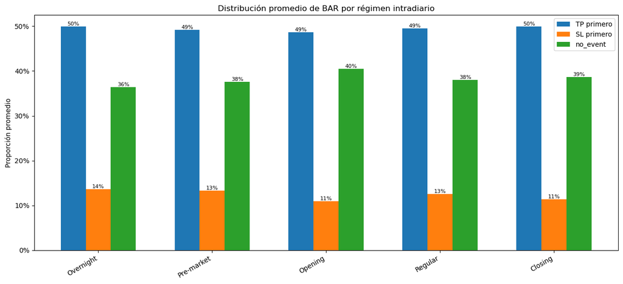

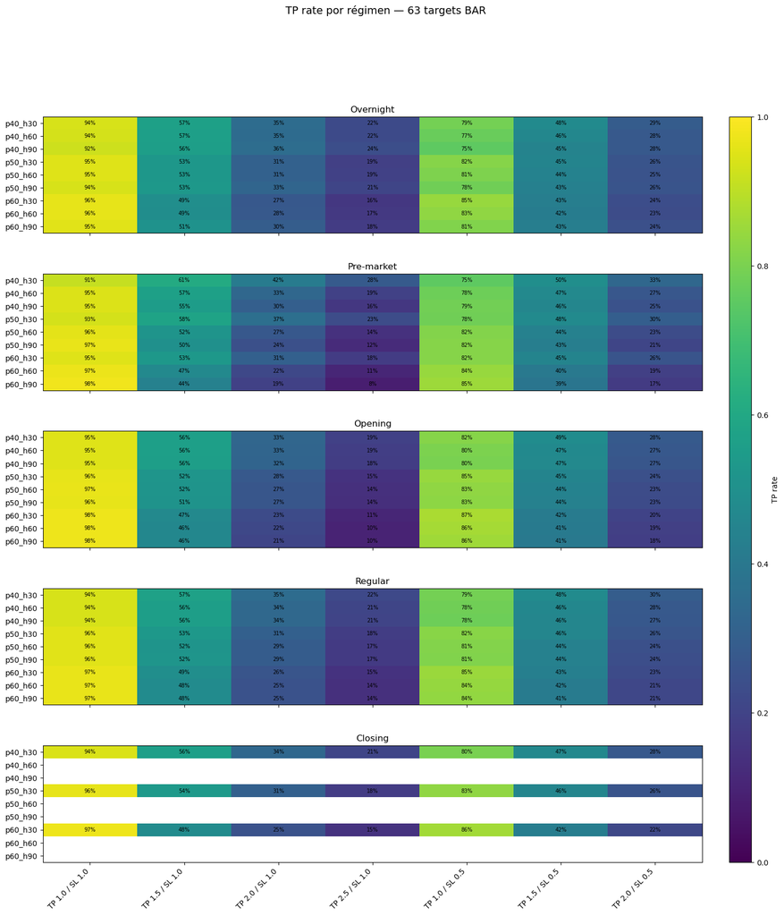

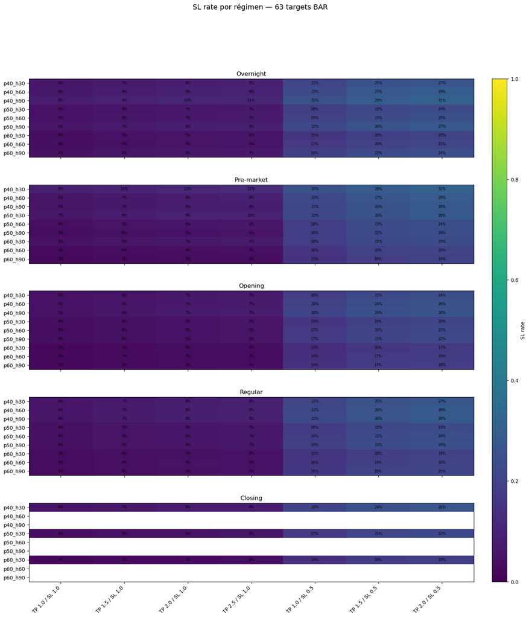

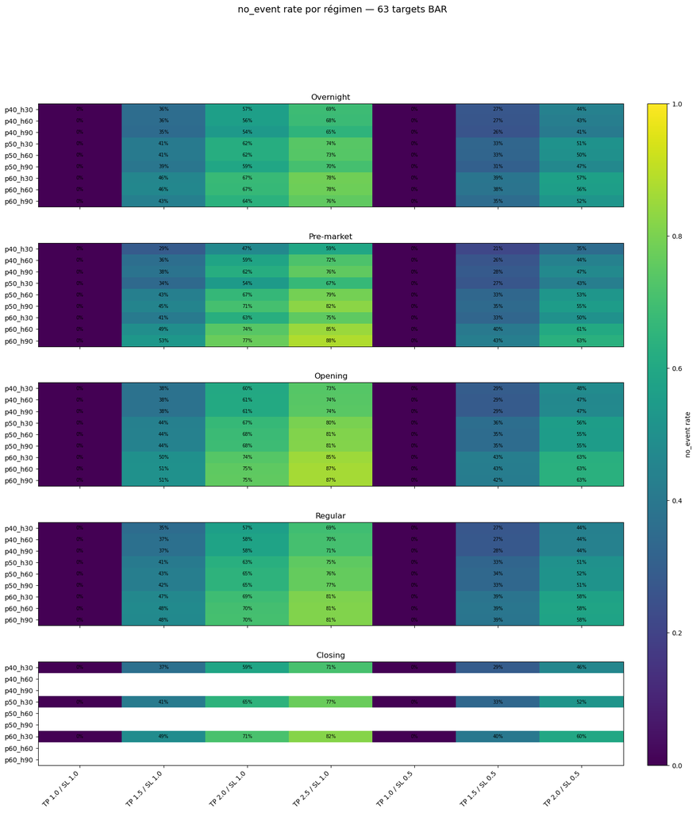

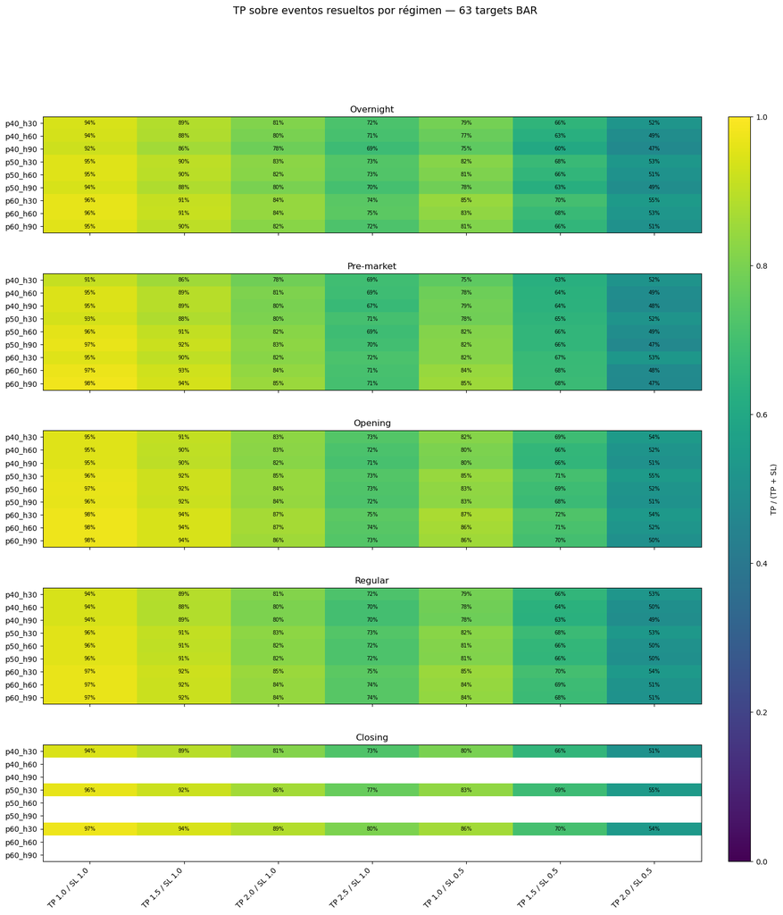

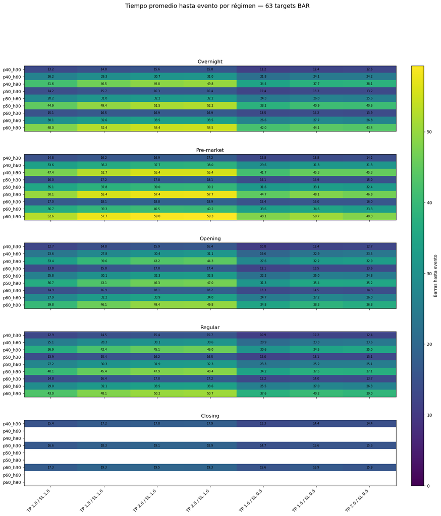

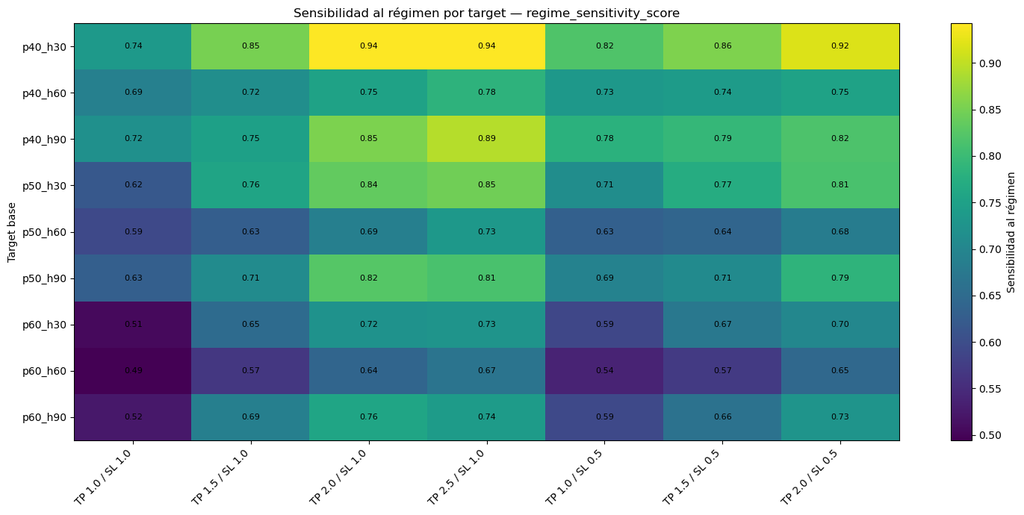

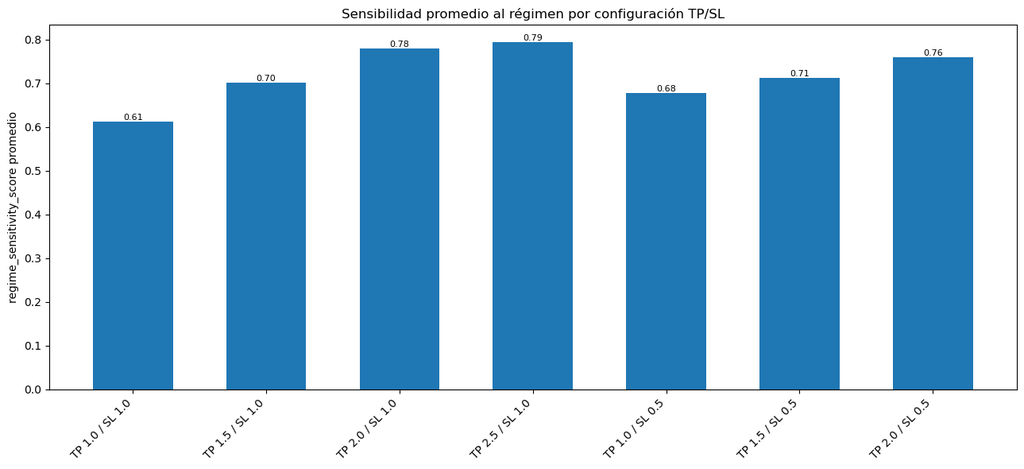

```
Celda 3 finalizada correctamente.
```

```python
# Celda 3 — Gráficos agrupados por régimen
# ============================================================

print("Gráficos agrupados por régimen intradiario - BAR")
print("=" * 80)

# ------------------------------------------------------------
# Validar objetos necesarios
# ------------------------------------------------------------

required_objects = [
    "df_bar_regime_analysis",
    "df_bar_regime_by_regime",
    "df_bar_regime_by_config",
    "df_bar_regime_by_target_base",
    "df_bar_regime_stability_by_target",
    "df_bar_regime_sensitivity_by_config",
    "df_bar_regime_sensitivity_by_target_base",
    "BAR_PERCENTILES",
    "BAR_HORIZONS",
]

missing_objects = [
    obj for obj in required_objects
    if obj not in globals()
]

if missing_objects:
    raise NameError(
        "Faltan objetos necesarios. "
        f"Debes correr las celdas anteriores: {missing_objects}"
    )

# ------------------------------------------------------------
# Orden de configuraciones TP/SL
# ------------------------------------------------------------

config_order = [
    (1.0, 1.0),
    (1.5, 1.0),
    (2.0, 1.0),
    (2.5, 1.0),
    (1.0, 0.5),
    (1.5, 0.5),
    (2.0, 0.5),
]

config_labels = [
    f"TP {tp} / SL {sl}"
    for tp, sl in config_order
]

target_base_order = [
    f"p{p}_h{h}"
    for p in BAR_PERCENTILES
    for h in BAR_HORIZONS
]

regime_order = (
    df_bar_regime_analysis[["regime_id", "regime_name"]]
    .drop_duplicates()
    .sort_values("regime_id")
    .reset_index(drop=True)
)

regime_labels = regime_order["regime_name"].tolist()

# ------------------------------------------------------------
# Copias de trabajo
# ------------------------------------------------------------

df_regime_plot = df_bar_regime_analysis.copy()
df_regime_config_plot = df_bar_regime_by_config.copy()
df_regime_sensitivity_plot = df_bar_regime_stability_by_target.copy()

for df_tmp in [df_regime_plot, df_regime_config_plot, df_regime_sensitivity_plot]:
    df_tmp["config_label"] = df_tmp.apply(
        lambda row: f"TP {row['tp_mult']} / SL {row['sl_mult']}",
        axis=1
    )

    df_tmp["config_order"] = df_tmp.apply(
        lambda row: config_order.index((row["tp_mult"], row["sl_mult"]))
        if (row["tp_mult"], row["sl_mult"]) in config_order
        else 999,
        axis=1
    )

# ============================================================
# Figura 1 — Resumen global por régimen
# ============================================================

df_summary_plot = df_bar_regime_by_regime.copy()
df_summary_plot = df_summary_plot.sort_values("regime_id").reset_index(drop=True)

x = np.arange(len(df_summary_plot))
bar_width = 0.22

fig, ax = plt.subplots(figsize=(13, 6))

ax.bar(
    x - bar_width,
    df_summary_plot["tp_rate_mean"],
    width=bar_width,
    label="TP primero"
)

ax.bar(
    x,
    df_summary_plot["sl_rate_mean"],
    width=bar_width,
    label="SL primero"
)

ax.bar(
    x + bar_width,
    df_summary_plot["no_event_rate_mean"],
    width=bar_width,
    label="no_event"
)

ax.set_title("Distribución promedio de BAR por régimen intradiario")
ax.set_ylabel("Proporción promedio")
ax.set_xticks(x)
ax.set_xticklabels(df_summary_plot["regime_name"], rotation=30, ha="right")
ax.legend()

ax.yaxis.set_major_formatter(
    plt.FuncFormatter(lambda y, _: f"{y:.0%}")
)

for i, row in df_summary_plot.iterrows():
    ax.text(
        i - bar_width,
        row["tp_rate_mean"],
        f"{row['tp_rate_mean']:.0%}",
        ha="center",
        va="bottom",
        fontsize=8
    )

    ax.text(
        i,
        row["sl_rate_mean"],
        f"{row['sl_rate_mean']:.0%}",
        ha="center",
        va="bottom",
        fontsize=8
    )

    ax.text(
        i + bar_width,
        row["no_event_rate_mean"],
        f"{row['no_event_rate_mean']:.0%}",
        ha="center",
        va="bottom",
        fontsize=8
    )

plt.tight_layout()
plt.show()

# ============================================================
# Función auxiliar para heatmaps por régimen
# ============================================================

def plot_metric_heatmaps_by_regime(
    df,
    metric_col,
    title,
    value_format="{:.0%}",
    vmin=0,
    vmax=1,
    colorbar_label="Proporción",
    figsize=(17, 18)
):
    """
    Grafica heatmaps separados por régimen.

    Cada heatmap contiene:
    - Filas: target_base, por ejemplo p40_h30, p50_h60, p60_h90
    - Columnas: configuraciones TP/SL

    La barra de color se ubica en una columna separada para evitar
    superposición con los heatmaps.
    """

    n_regimes = len(regime_order)

    fig = plt.figure(figsize=figsize)

    gs = fig.add_gridspec(
        nrows=n_regimes,
        ncols=2,
        width_ratios=[30, 1],
        hspace=0.35,
        wspace=0.08
    )

    axes = [
        fig.add_subplot(gs[i, 0])
        for i in range(n_regimes)
    ]

    cax = fig.add_subplot(gs[:, 1])

    last_im = None

    for ax, regime_info in zip(axes, regime_order.itertuples(index=False)):

        regime_id = regime_info.regime_id
        regime_name = regime_info.regime_name

        tmp = df[df["regime_id"] == regime_id].copy()

        pivot_tmp = (
            tmp
            .pivot_table(
                index="target_base",
                columns="config_label",
                values=metric_col,
                aggfunc="first"
            )
            .reindex(index=target_base_order)
            .reindex(columns=config_labels)
        )

        data = np.ma.masked_invalid(pivot_tmp.values)

        last_im = ax.imshow(
            data,
            aspect="auto",
            vmin=vmin,
            vmax=vmax
        )

        ax.set_title(regime_name)

        ax.set_yticks(np.arange(len(pivot_tmp.index)))
        ax.set_yticklabels(pivot_tmp.index)

        ax.set_xticks(np.arange(len(pivot_tmp.columns)))

        # Solo mostrar etiquetas del eje X en el último heatmap
        if ax == axes[-1]:
            ax.set_xticklabels(
                pivot_tmp.columns,
                rotation=45,
                ha="right"
            )
        else:
            ax.set_xticklabels([])

        for i in range(pivot_tmp.shape[0]):
            for j in range(pivot_tmp.shape[1]):
                value = pivot_tmp.iloc[i, j]

                if pd.notna(value):
                    ax.text(
                        j,
                        i,
                        value_format.format(value),
                        ha="center",
                        va="center",
                        fontsize=7
                    )

    fig.colorbar(
        last_im,
        cax=cax,
        label=colorbar_label
    )

    fig.suptitle(
        title,
        fontsize=14,
        y=0.995
    )

    plt.show()

# ============================================================
# Figura 2 — TP rate por régimen para los 63 targets BAR
# ============================================================

plot_metric_heatmaps_by_regime(
    df=df_regime_plot,
    metric_col="tp_rate",
    title="TP rate por régimen — 63 targets BAR",
    value_format="{:.0%}",
    vmin=0,
    vmax=1,
    colorbar_label="TP rate"
)

# ============================================================
# Figura 3 — SL rate por régimen para los 63 targets BAR
# ============================================================

plot_metric_heatmaps_by_regime(
    df=df_regime_plot,
    metric_col="sl_rate",
    title="SL rate por régimen — 63 targets BAR",
    value_format="{:.0%}",
    vmin=0,
    vmax=1,
    colorbar_label="SL rate"
)

# ============================================================
# Figura 4 — no_event rate por régimen para los 63 targets BAR
# ============================================================

plot_metric_heatmaps_by_regime(
    df=df_regime_plot,
    metric_col="no_event_rate",
    title="no_event rate por régimen — 63 targets BAR",
    value_format="{:.0%}",
    vmin=0,
    vmax=1,
    colorbar_label="no_event rate"
)

# ============================================================
# Figura 5 — TP sobre eventos resueltos por régimen
# ============================================================

plot_metric_heatmaps_by_regime(
    df=df_regime_plot,
    metric_col="tp_share_over_resolved",
    title="TP sobre eventos resueltos por régimen — 63 targets BAR",
    value_format="{:.0%}",
    vmin=0,
    vmax=1,
    colorbar_label="TP / (TP + SL)"
)

# ============================================================
# Figura 6 — Tiempo promedio hasta evento por régimen
# ============================================================

global_max_event_step = df_regime_plot["event_step_mean"].max()

plot_metric_heatmaps_by_regime(
    df=df_regime_plot,
    metric_col="event_step_mean",
    title="Tiempo promedio hasta evento por régimen — 63 targets BAR",
    value_format="{:.1f}",
    vmin=0,
    vmax=global_max_event_step,
    colorbar_label="Barras hasta evento"
)

# ============================================================
# Figura 7 — Sensibilidad al régimen por target
# ============================================================

pivot_sensitivity = (
    df_regime_sensitivity_plot
    .pivot_table(
        index="target_base",
        columns="config_label",
        values="regime_sensitivity_score",
        aggfunc="first"
    )
    .reindex(index=target_base_order)
    .reindex(columns=config_labels)
)

fig, ax = plt.subplots(figsize=(15, 7))

data = np.ma.masked_invalid(pivot_sensitivity.values)

im = ax.imshow(
    data,
    aspect="auto"
)

ax.set_title("Sensibilidad al régimen por target — regime_sensitivity_score")
ax.set_ylabel("Target base")
ax.set_yticks(np.arange(len(pivot_sensitivity.index)))
ax.set_yticklabels(pivot_sensitivity.index)

ax.set_xticks(np.arange(len(pivot_sensitivity.columns)))
ax.set_xticklabels(pivot_sensitivity.columns, rotation=45, ha="right")

for i in range(pivot_sensitivity.shape[0]):
    for j in range(pivot_sensitivity.shape[1]):
        value = pivot_sensitivity.iloc[i, j]

        if pd.notna(value):
            ax.text(
                j,
                i,
                f"{value:.2f}",
                ha="center",
                va="center",
                fontsize=8
            )

fig.colorbar(
    im,
    ax=ax,
    label="Sensibilidad al régimen"
)

plt.tight_layout()
plt.show()

# ============================================================
# Figura 8 — Sensibilidad promedio al régimen por configuración
# ============================================================

df_config_sensitivity_plot = df_bar_regime_sensitivity_by_config.copy()

df_config_sensitivity_plot["config_order"] = df_config_sensitivity_plot.apply(
    lambda row: config_order.index((row["tp_mult"], row["sl_mult"]))
    if (row["tp_mult"], row["sl_mult"]) in config_order
    else 999,
    axis=1
)

df_config_sensitivity_plot = (
    df_config_sensitivity_plot
    .sort_values("config_order")
    .reset_index(drop=True)
)

x = np.arange(len(df_config_sensitivity_plot))

fig, ax = plt.subplots(figsize=(13, 6))

ax.bar(
    x,
    df_config_sensitivity_plot["regime_sensitivity_score_mean"],
    width=0.6
)

ax.set_title("Sensibilidad promedio al régimen por configuración TP/SL")
ax.set_ylabel("regime_sensitivity_score promedio")
ax.set_xticks(x)
ax.set_xticklabels(df_config_sensitivity_plot["tp_sl_config"], rotation=45, ha="right")

for i, row in df_config_sensitivity_plot.iterrows():
    ax.text(
        i,
        row["regime_sensitivity_score_mean"],
        f"{row['regime_sensitivity_score_mean']:.2f}",
        ha="center",
        va="bottom",
        fontsize=8
    )

plt.tight_layout()
plt.show()

print("\nCelda 3 finalizada correctamente.")
```

### Celda 4 — Guardado y tabla final para observaciones

```python
# Celda 4 — Guardado y tabla final para observaciones
# ============================================================

print("Guardado y tabla final de análisis por régimen intradiario - BAR")
print("=" * 80)

# ------------------------------------------------------------
# Validar objetos necesarios
# ------------------------------------------------------------

required_objects = [
    "df_bar_regime_analysis",
    "df_bar_regime_by_regime",
    "df_bar_regime_by_config",
    "df_bar_regime_by_target_base",
    "df_bar_regime_candidate_tp15_sl10",
    "df_bar_regime_stability_by_target",
    "df_bar_regime_sensitivity_by_config",
    "df_bar_regime_sensitivity_by_target_base",
    "MNQ_TARGETS_PATH",
]

missing_objects = [
    obj for obj in required_objects
    if obj not in globals()
]

if missing_objects:
    raise NameError(
        "Faltan objetos necesarios. "
        f"Debes correr las celdas anteriores: {missing_objects}"
    )

# ------------------------------------------------------------
# Definir rutas de guardado
# ------------------------------------------------------------

MNQ_TARGETS_BAR_REGIME_ANALYSIS_CSV = (
    MNQ_TARGETS_PATH / "mnq_targets_bar_regime_analysis.csv"
)

MNQ_TARGETS_BAR_REGIME_BY_REGIME_CSV = (
    MNQ_TARGETS_PATH / "mnq_targets_bar_regime_by_regime.csv"
)

MNQ_TARGETS_BAR_REGIME_BY_CONFIG_CSV = (
    MNQ_TARGETS_PATH / "mnq_targets_bar_regime_by_config.csv"
)

MNQ_TARGETS_BAR_REGIME_BY_TARGET_BASE_CSV = (
    MNQ_TARGETS_PATH / "mnq_targets_bar_regime_by_target_base.csv"
)

MNQ_TARGETS_BAR_REGIME_CANDIDATE_TP15_SL10_CSV = (
    MNQ_TARGETS_PATH / "mnq_targets_bar_regime_candidate_tp15_sl10.csv"
)

MNQ_TARGETS_BAR_REGIME_STABILITY_BY_TARGET_CSV = (
    MNQ_TARGETS_PATH / "mnq_targets_bar_regime_stability_by_target.csv"
)

MNQ_TARGETS_BAR_REGIME_SENSITIVITY_BY_CONFIG_CSV = (
    MNQ_TARGETS_PATH / "mnq_targets_bar_regime_sensitivity_by_config.csv"
)

MNQ_TARGETS_BAR_REGIME_SENSITIVITY_BY_TARGET_BASE_CSV = (
    MNQ_TARGETS_PATH / "mnq_targets_bar_regime_sensitivity_by_target_base.csv"
)

MNQ_TARGETS_BAR_REGIME_FINAL_TABLE_CSV = (
    MNQ_TARGETS_PATH / "mnq_targets_bar_regime_final_table.csv"
)

MNQ_TARGETS_BAR_REGIME_REPORT_TXT = (
    MNQ_TARGETS_PATH / "mnq_targets_bar_regime_report.txt"
)

# ------------------------------------------------------------
# Crear tabla final de sensibilidad por régimen
# ------------------------------------------------------------

df_bar_regime_final_table = df_bar_regime_stability_by_target.copy()

# ------------------------------------------------------------
# Clasificación relativa de sensibilidad al régimen
# ------------------------------------------------------------
# Menor score = más estable entre regímenes.
# Mayor score = más dependiente del régimen intradiario.
# ------------------------------------------------------------

q33 = df_bar_regime_final_table["regime_sensitivity_score"].quantile(0.33)
q66 = df_bar_regime_final_table["regime_sensitivity_score"].quantile(0.66)

def classify_regime_sensitivity(score):
    """
    Clasificación descriptiva de sensibilidad al régimen.
    Es relativa al conjunto de 63 targets BAR.
    """

    if pd.isna(score):
        return "sin_clasificar"

    if score <= q33:
        return "menor_sensibilidad"

    if score <= q66:
        return "sensibilidad_intermedia"

    return "mayor_sensibilidad"


df_bar_regime_final_table["regime_sensitivity_profile"] = (
    df_bar_regime_final_table["regime_sensitivity_score"]
    .apply(classify_regime_sensitivity)
)

df_bar_regime_final_table = (
    df_bar_regime_final_table
    .sort_values(
        [
            "regime_sensitivity_score",
            "percentile",
            "horizon",
            "sl_mult",
            "tp_mult",
        ],
        ascending=[True, True, True, True, True]
    )
    .reset_index(drop=True)
)

# ------------------------------------------------------------
# Guardar tablas principales
# ------------------------------------------------------------

df_bar_regime_analysis.to_csv(
    MNQ_TARGETS_BAR_REGIME_ANALYSIS_CSV,
    index=False
)

df_bar_regime_by_regime.to_csv(
    MNQ_TARGETS_BAR_REGIME_BY_REGIME_CSV,
    index=False
)

df_bar_regime_by_config.to_csv(
    MNQ_TARGETS_BAR_REGIME_BY_CONFIG_CSV,
    index=False
)

df_bar_regime_by_target_base.to_csv(
    MNQ_TARGETS_BAR_REGIME_BY_TARGET_BASE_CSV,
    index=False
)

df_bar_regime_candidate_tp15_sl10.to_csv(
    MNQ_TARGETS_BAR_REGIME_CANDIDATE_TP15_SL10_CSV,
    index=False
)

df_bar_regime_stability_by_target.to_csv(
    MNQ_TARGETS_BAR_REGIME_STABILITY_BY_TARGET_CSV,
    index=False
)

df_bar_regime_sensitivity_by_config.to_csv(
    MNQ_TARGETS_BAR_REGIME_SENSITIVITY_BY_CONFIG_CSV,
    index=False
)

df_bar_regime_sensitivity_by_target_base.to_csv(
    MNQ_TARGETS_BAR_REGIME_SENSITIVITY_BY_TARGET_BASE_CSV,
    index=False
)

df_bar_regime_final_table.to_csv(
    MNQ_TARGETS_BAR_REGIME_FINAL_TABLE_CSV,
    index=False
)

# ------------------------------------------------------------
# Columnas para impresión
# ------------------------------------------------------------

regime_summary_cols = [
    "regime_id",
    "regime_name",
    "n_targets",
    "operable_rate_mean",
    "tp_rate_mean",
    "sl_rate_mean",
    "no_event_rate_mean",
    "resolved_rate_mean",
    "tp_share_over_resolved_mean",
    "expectancy_units_mean",
    "event_step_mean",
]

config_summary_cols = [
    "regime_id",
    "regime_name",
    "tp_sl_config",
    "n_targets",
    "operable_rate_mean",
    "tp_rate_mean",
    "sl_rate_mean",
    "no_event_rate_mean",
    "resolved_rate_mean",
    "tp_share_over_resolved_mean",
    "expectancy_units_mean",
    "event_step_mean",
]

candidate_cols = [
    "bar_col",
    "target_base",
    "regime_id",
    "regime_name",
    "total_rows",
    "valid_rows",
    "operable_rate",
    "tp_rate",
    "sl_rate",
    "no_event_rate",
    "resolved_rate",
    "tp_share_over_resolved",
    "expectancy_units",
    "event_step_mean",
]
```

```python
sensitivity_config_cols = [
    "tp_sl_config",
    "n_targets",
    "operable_rate_range_mean",
    "tp_rate_range_mean",
    "sl_rate_range_mean",
    "no_event_rate_range_mean",
    "tp_share_range_mean",
    "expectancy_range_mean",
    "regime_sensitivity_score_mean",
    "regime_sensitivity_score_max",
]

sensitivity_target_base_cols = [
    "target_base",
    "percentile",
    "horizon",
    "n_configs",
    "operable_rate_range_mean",
    "tp_rate_range_mean",
    "sl_rate_range_mean",
    "no_event_rate_range_mean",
    "tp_share_range_mean",
    "expectancy_range_mean",
    "regime_sensitivity_score_mean",
    "regime_sensitivity_score_max",
]

final_table_cols = [
    "bar_col",
    "target_base",
    "tp_sl_config",
    "n_regimes",
    "operable_rate_mean",
    "operable_rate_range",
    "tp_rate_mean",
    "tp_rate_range",
    "sl_rate_mean",
    "sl_rate_range",
    "no_event_rate_mean",
    "no_event_rate_range",
    "resolved_rate_mean",
    "resolved_rate_range",
    "tp_share_over_resolved_mean",
    "tp_share_over_resolved_range",
    "expectancy_units_mean",
    "expectancy_units_range",
    "event_step_mean_mean",
    "event_step_mean_range",
    "regime_sensitivity_score",
    "regime_sensitivity_profile",
]

# ------------------------------------------------------------
# Impresiones principales
# ------------------------------------------------------------

print("\nResumen general por régimen:")
print(
    df_bar_regime_by_regime[regime_summary_cols]
    .to_string(
        index=False,
        formatters={
            "operable_rate_mean": "{:.2%}".format,
            "tp_rate_mean": "{:.2%}".format,
            "sl_rate_mean": "{:.2%}".format,
            "no_event_rate_mean": "{:.2%}".format,
            "resolved_rate_mean": "{:.2%}".format,
            "tp_share_over_resolved_mean": "{:.2%}".format,
            "expectancy_units_mean": "{:.3f}".format,
            "event_step_mean": "{:.2f}".format,
        }
    )
)

print("\nResumen por régimen y configuración TP/SL:")
print(
    df_bar_regime_by_config[config_summary_cols]
    .to_string(
        index=False,
        formatters={
            "operable_rate_mean": "{:.2%}".format,
            "tp_rate_mean": "{:.2%}".format,
            "sl_rate_mean": "{:.2%}".format,
            "no_event_rate_mean": "{:.2%}".format,
            "resolved_rate_mean": "{:.2%}".format,
            "tp_share_over_resolved_mean": "{:.2%}".format,
            "expectancy_units_mean": "{:.3f}".format,
            "event_step_mean": "{:.2f}".format,
        }
    )
)

print("\nDetalle por régimen para configuración candidata TP 1.5 / SL 1.0:")
print(
    df_bar_regime_candidate_tp15_sl10[candidate_cols]
    .to_string(
        index=False,
        formatters={
            "operable_rate": "{:.2%}".format,
            "tp_rate": "{:.2%}".format,
            "sl_rate": "{:.2%}".format,
            "no_event_rate": "{:.2%}".format,
            "resolved_rate": "{:.2%}".format,
            "tp_share_over_resolved": "{:.2%}".format,
            "expectancy_units": "{:.3f}".format,
            "event_step_mean": "{:.2f}".format,
        }
    )
)

print("\nSensibilidad agregada al régimen por configuración TP/SL:")
print(
    df_bar_regime_sensitivity_by_config[sensitivity_config_cols]
    .to_string(
        index=False,
        formatters={
            "operable_rate_range_mean": "{:.2%}".format,
            "tp_rate_range_mean": "{:.2%}".format,
            "sl_rate_range_mean": "{:.2%}".format,
            "no_event_rate_range_mean": "{:.2%}".format,
            "tp_share_range_mean": "{:.2%}".format,
            "expectancy_range_mean": "{:.3f}".format,
            "regime_sensitivity_score_mean": "{:.3f}".format,
            "regime_sensitivity_score_max": "{:.3f}".format,
        }
    )
)

print("\nSensibilidad agregada al régimen por percentil y horizonte:")
print(
    df_bar_regime_sensitivity_by_target_base[sensitivity_target_base_cols]
    .to_string(
        index=False,
        formatters={
            "operable_rate_range_mean": "{:.2%}".format,
            "tp_rate_range_mean": "{:.2%}".format,
            "sl_rate_range_mean": "{:.2%}".format,
            "no_event_rate_range_mean": "{:.2%}".format,
            "tp_share_range_mean": "{:.2%}".format,
            "expectancy_range_mean": "{:.3f}".format,
            "regime_sensitivity_score_mean": "{:.3f}".format,
            "regime_sensitivity_score_max": "{:.3f}".format,
        }
    )
)

print("\nTabla final de sensibilidad al régimen — 63 targets BAR:")
print(
    df_bar_regime_final_table[final_table_cols]
    .to_string(
        index=False,
        formatters={
            "operable_rate_mean": "{:.2%}".format,
            "operable_rate_range": "{:.2%}".format,
            "tp_rate_mean": "{:.2%}".format,
            "tp_rate_range": "{:.2%}".format,
            "sl_rate_mean": "{:.2%}".format,
            "sl_rate_range": "{:.2%}".format,
            "no_event_rate_mean": "{:.2%}".format,
            "no_event_rate_range": "{:.2%}".format,
            "resolved_rate_mean": "{:.2%}".format,
            "resolved_rate_range": "{:.2%}".format,
            "tp_share_over_resolved_mean": "{:.2%}".format,
            "tp_share_over_resolved_range": "{:.2%}".format,
            "expectancy_units_mean": "{:.3f}".format,
            "expectancy_units_range": "{:.3f}".format,
            "event_step_mean_mean": "{:.2f}".format,
            "event_step_mean_range": "{:.2f}".format,
            "regime_sensitivity_score": "{:.3f}".format,
        }
    )
)

# ------------------------------------------------------------
# Top 15 menor y mayor sensibilidad al régimen
# ------------------------------------------------------------

print("\nTop 15 targets con menor sensibilidad al régimen:")
print(
    df_bar_regime_final_table[final_table_cols]
    .head(15)
    .to_string(
        index=False,
        formatters={
            "operable_rate_mean": "{:.2%}".format,
            "operable_rate_range": "{:.2%}".format,
            "tp_rate_mean": "{:.2%}".format,
            "tp_rate_range": "{:.2%}".format,
            "sl_rate_mean": "{:.2%}".format,
            "sl_rate_range": "{:.2%}".format,
            "no_event_rate_mean": "{:.2%}".format,
            "no_event_rate_range": "{:.2%}".format,
            "resolved_rate_mean": "{:.2%}".format,
            "resolved_rate_range": "{:.2%}".format,
            "tp_share_over_resolved_mean": "{:.2%}".format,
            "tp_share_over_resolved_range": "{:.2%}".format,
            "expectancy_units_mean": "{:.3f}".format,
            "expectancy_units_range": "{:.3f}".format,
            "event_step_mean_mean": "{:.2f}".format,
            "event_step_mean_range": "{:.2f}".format,
            "regime_sensitivity_score": "{:.3f}".format,
        }
    )
)
```

```python
print("\nTop 15 targets con mayor sensibilidad al régimen:")
print(
    df_bar_regime_final_table[final_table_cols]
    .tail(15)
    .sort_values("regime_sensitivity_score", ascending=False)
    .to_string(
        index=False,
        formatters={
            "operable_rate_mean": "{:.2%}".format,
            "operable_rate_range": "{:.2%}".format,
            "tp_rate_mean": "{:.2%}".format,
            "tp_rate_range": "{:.2%}".format,
            "sl_rate_mean": "{:.2%}".format,
            "sl_rate_range": "{:.2%}".format,
            "no_event_rate_mean": "{:.2%}".format,
            "no_event_rate_range": "{:.2%}".format,
            "resolved_rate_mean": "{:.2%}".format,
            "resolved_rate_range": "{:.2%}".format,
            "tp_share_over_resolved_mean": "{:.2%}".format,
            "tp_share_over_resolved_range": "{:.2%}".format,
            "expectancy_units_mean": "{:.3f}".format,
            "expectancy_units_range": "{:.3f}".format,
            "event_step_mean_mean": "{:.2f}".format,
            "event_step_mean_range": "{:.2f}".format,
            "regime_sensitivity_score": "{:.3f}".format,
        }
    )
)

# ------------------------------------------------------------
# Conteo por perfil de sensibilidad al régimen
# ------------------------------------------------------------

df_bar_regime_sensitivity_profile_counts = (
    df_bar_regime_final_table
    .groupby("regime_sensitivity_profile", as_index=False)
    .agg(
        n_targets=("bar_col", "count"),

        regime_sensitivity_score_mean=("regime_sensitivity_score", "mean"),

        operable_rate_range_mean=("operable_rate_range", "mean"),
        tp_rate_range_mean=("tp_rate_range", "mean"),
        sl_rate_range_mean=("sl_rate_range", "mean"),
        no_event_rate_range_mean=("no_event_rate_range", "mean"),
        tp_share_range_mean=("tp_share_over_resolved_range", "mean"),

        expectancy_range_mean=("expectancy_units_range", "mean"),
        event_step_range_mean=("event_step_mean_range", "mean"),
    )
    .sort_values("regime_sensitivity_score_mean")
    .reset_index(drop=True)
)

print("\nConteo por perfil de sensibilidad al régimen:")
print(
    df_bar_regime_sensitivity_profile_counts
    .to_string(
        index=False,
        formatters={
            "regime_sensitivity_score_mean": "{:.3f}".format,
            "operable_rate_range_mean": "{:.2%}".format,
            "tp_rate_range_mean": "{:.2%}".format,
            "sl_rate_range_mean": "{:.2%}".format,
            "no_event_rate_range_mean": "{:.2%}".format,
            "tp_share_range_mean": "{:.2%}".format,
            "expectancy_range_mean": "{:.3f}".format,
            "event_step_range_mean": "{:.2f}".format,
        }
    )
)

# ------------------------------------------------------------
# Guardar reporte TXT
# ------------------------------------------------------------

with MNQ_TARGETS_BAR_REGIME_REPORT_TXT.open("w", encoding="utf-8") as f:
    f.write("4.10. Análisis por régimen intradiario - BAR\n")
    f.write("=" * 100 + "\n\n")

    f.write("Resumen general por régimen\n")
    f.write("-" * 100 + "\n")
    f.write(
        df_bar_regime_by_regime[regime_summary_cols]
        .to_string(
            index=False,
            formatters={
                "operable_rate_mean": "{:.2%}".format,
                "tp_rate_mean": "{:.2%}".format,
                "sl_rate_mean": "{:.2%}".format,
                "no_event_rate_mean": "{:.2%}".format,
                "resolved_rate_mean": "{:.2%}".format,
                "tp_share_over_resolved_mean": "{:.2%}".format,
                "expectancy_units_mean": "{:.3f}".format,
                "event_step_mean": "{:.2f}".format,
            }
        )
    )

    f.write("\n\n")
    f.write("Resumen por régimen y configuración TP/SL\n")
    f.write("-" * 100 + "\n")
    f.write(
        df_bar_regime_by_config[config_summary_cols]
        .to_string(
            index=False,
            formatters={
                "operable_rate_mean": "{:.2%}".format,
                "tp_rate_mean": "{:.2%}".format,
                "sl_rate_mean": "{:.2%}".format,
                "no_event_rate_mean": "{:.2%}".format,
                "resolved_rate_mean": "{:.2%}".format,
                "tp_share_over_resolved_mean": "{:.2%}".format,
                "expectancy_units_mean": "{:.3f}".format,
                "event_step_mean": "{:.2f}".format,
            }
        )
    )

    f.write("\n\n")
    f.write("Detalle por régimen para configuración candidata TP 1.5 / SL 1.0\n")
    f.write("-" * 100 + "\n")
    f.write(
        df_bar_regime_candidate_tp15_sl10[candidate_cols]
        .to_string(
            index=False,
            formatters={
                "operable_rate": "{:.2%}".format,
                "tp_rate": "{:.2%}".format,
                "sl_rate": "{:.2%}".format,
                "no_event_rate": "{:.2%}".format,
                "resolved_rate": "{:.2%}".format,
                "tp_share_over_resolved": "{:.2%}".format,
                "expectancy_units": "{:.3f}".format,
                "event_step_mean": "{:.2f}".format,
            }
        )
    )

    f.write("\n\n")
    f.write("Sensibilidad agregada al régimen por configuración TP/SL\n")
    f.write("-" * 100 + "\n")
    f.write(
        df_bar_regime_sensitivity_by_config[sensitivity_config_cols]
        .to_string(
            index=False,
            formatters={
                "operable_rate_range_mean": "{:.2%}".format,
                "tp_rate_range_mean": "{:.2%}".format,
                "sl_rate_range_mean": "{:.2%}".format,
                "no_event_rate_range_mean": "{:.2%}".format,
                "tp_share_range_mean": "{:.2%}".format,
                "expectancy_range_mean": "{:.3f}".format,
                "regime_sensitivity_score_mean": "{:.3f}".format,
                "regime_sensitivity_score_max": "{:.3f}".format,
            }
        )
    )

    f.write("\n\n")
    f.write("Sensibilidad agregada al régimen por percentil y horizonte\n")
    f.write("-" * 100 + "\n")
    f.write(
        df_bar_regime_sensitivity_by_target_base[sensitivity_target_base_cols]
        .to_string(
            index=False,
            formatters={
                "operable_rate_range_mean": "{:.2%}".format,
                "tp_rate_range_mean": "{:.2%}".format,
                "sl_rate_range_mean": "{:.2%}".format,
                "no_event_rate_range_mean": "{:.2%}".format,
                "tp_share_range_mean": "{:.2%}".format,
                "expectancy_range_mean": "{:.3f}".format,
                "regime_sensitivity_score_mean": "{:.3f}".format,
                "regime_sensitivity_score_max": "{:.3f}".format,
            }
        )
    )
```

```python
    f.write("\n\n")
    f.write("Tabla final de sensibilidad al régimen — 63 targets BAR\n")
    f.write("-" * 100 + "\n")
    f.write(
        df_bar_regime_final_table[final_table_cols]
        .to_string(
            index=False,
            formatters={
                "operable_rate_mean": "{:.2%}".format,
                "operable_rate_range": "{:.2%}".format,
                "tp_rate_mean": "{:.2%}".format,
                "tp_rate_range": "{:.2%}".format,
                "sl_rate_mean": "{:.2%}".format,
                "sl_rate_range": "{:.2%}".format,
                "no_event_rate_mean": "{:.2%}".format,
                "no_event_rate_range": "{:.2%}".format,
                "resolved_rate_mean": "{:.2%}".format,
                "resolved_rate_range": "{:.2%}".format,
                "tp_share_over_resolved_mean": "{:.2%}".format,
                "tp_share_over_resolved_range": "{:.2%}".format,
                "expectancy_units_mean": "{:.3f}".format,
                "expectancy_units_range": "{:.3f}".format,
                "event_step_mean_mean": "{:.2f}".format,
                "event_step_mean_range": "{:.2f}".format,
                "regime_sensitivity_score": "{:.3f}".format,
            }
        )
    )

    f.write("\n\n")
    f.write("Conteo por perfil de sensibilidad al régimen\n")
    f.write("-" * 100 + "\n")
    f.write(
        df_bar_regime_sensitivity_profile_counts
        .to_string(
            index=False,
            formatters={
                "regime_sensitivity_score_mean": "{:.3f}".format,
                "operable_rate_range_mean": "{:.2%}".format,
                "tp_rate_range_mean": "{:.2%}".format,
                "sl_rate_range_mean": "{:.2%}".format,
                "no_event_rate_range_mean": "{:.2%}".format,
                "tp_share_range_mean": "{:.2%}".format,
                "expectancy_range_mean": "{:.3f}".format,
                "event_step_range_mean": "{:.2f}".format,
            }
        )
    )

# ------------------------------------------------------------
# Confirmación final
# ------------------------------------------------------------

print("\nArchivos guardados:")
print(f"Análisis BAR por régimen:              {MNQ_TARGETS_BAR_REGIME_ANALYSIS_CSV}")
print(f"Resumen general por régimen:           {MNQ_TARGETS_BAR_REGIME_BY_REGIME_CSV}")
print(f"Resumen por régimen y configuración:   {MNQ_TARGETS_BAR_REGIME_BY_CONFIG_CSV}")
print(f"Resumen por régimen y target base:     {MNQ_TARGETS_BAR_REGIME_BY_TARGET_BASE_CSV}")
print(f"Candidata TP 1.5 / SL 1.0 por régimen: {MNQ_TARGETS_BAR_REGIME_CANDIDATE_TP15_SL10_CSV}")
print(f"Sensibilidad por target:               {MNQ_TARGETS_BAR_REGIME_STABILITY_BY_TARGET_CSV}")
print(f"Sensibilidad por configuración:        {MNQ_TARGETS_BAR_REGIME_SENSITIVITY_BY_CONFIG_CSV}")
print(f"Sensibilidad por percentil/horizonte:  {MNQ_TARGETS_BAR_REGIME_SENSITIVITY_BY_TARGET_BASE_CSV}")
print(f"Tabla final por régimen:               {MNQ_TARGETS_BAR_REGIME_FINAL_TABLE_CSV}")
print(f"Reporte TXT:                           {MNQ_TARGETS_BAR_REGIME_REPORT_TXT}")

print("\nCelda 4 finalizada correctamente.")
```

```
Guardado y tabla final de análisis por régimen intradiario - BAR
================================================================================

Resumen general por régimen:
 regime_id regime_name  n_targets operable_rate_mean tp_rate_mean sl_rate_mean no_event_rate_mean resolved_rate_mean tp_share_over_resolved_mean expectancy_units_mean event_step_mean
         0   Overnight         63             54.01%       49.97%       13.64%             36.39%             63.61%                      76.30%                 0.607           29.45
         1  Pre-market         63             54.50%       49.19%       13.28%             37.53%             62.47%                      76.06%                 0.591           34.33
         2     Opening         63             54.45%       48.67%       10.90%             40.43%             59.57%                      78.70%                 0.590           27.14
         3     Regular         63             48.46%       49.47%       12.58%             37.96%             62.04%                      77.20%                 0.600           27.86
         4     Closing         63              0.59%       49.91%       11.42%             38.67%             61.33%                      79.16%                 0.614           16.81

Resumen por régimen y configuración TP/SL:
 regime_id regime_name    tp_sl_config  n_targets operable_rate_mean tp_rate_mean sl_rate_mean no_event_rate_mean resolved_rate_mean tp_share_over_resolved_mean expectancy_units_mean event_step_mean
         0   Overnight TP 1.0 / SL 1.0          9             54.01%       94.60%        5.40%              0.00%            100.00%                      94.60%                 0.892           29.08
         0   Overnight TP 1.5 / SL 1.0          9             54.01%       53.21%        6.47%             40.32%             59.68%                      89.26%                 0.733           32.03
         0   Overnight TP 2.0 / SL 1.0          9             54.01%       31.72%        7.30%             60.98%             39.02%                      81.50%                 0.561           33.34
         0   Overnight TP 2.5 / SL 1.0          9             54.01%       19.78%        7.76%             72.46%             27.54%                      72.10%                 0.417           33.58
         0   Overnight TP 1.0 / SL 0.5          9             54.01%       80.15%       19.85%              0.00%            100.00%                      80.15%                 0.702           24.93
         0   Overnight TP 1.5 / SL 0.5          9             54.01%       44.32%       23.57%             32.11%             67.89%                      65.43%                 0.547           26.72
         0   Overnight TP 2.0 / SL 0.5          9             54.01%       26.00%       25.11%             48.89%             51.11%                      51.05%                 0.394           26.49
         1  Pre-market TP 1.0 / SL 1.0          9             54.50%       95.17%        4.83%              0.00%            100.00%                      95.17%                 0.903           33.70
         1  Pre-market TP 1.5 / SL 1.0          9             54.50%       53.07%        5.95%             40.98%             59.02%                      90.20%                 0.737           36.73
         1  Pre-market TP 2.0 / SL 1.0          9             54.50%       29.54%        6.82%             63.64%             36.36%                      81.71%                 0.523           38.06
         1  Pre-market TP 2.5 / SL 1.0          9             54.50%       16.73%        7.26%             76.01%             23.99%                      69.81%                 0.346           38.24
         1  Pre-market TP 1.0 / SL 0.5          9             54.50%       80.56%       19.44%              0.00%            100.00%                      80.56%                 0.708           30.17
         1  Pre-market TP 1.5 / SL 0.5          9             54.50%       44.59%       23.50%             31.91%             68.09%                      65.64%                 0.551           32.00
```

[output cut: 214 more lines]

### Observaciones preliminares — Análisis por régimen intradiario BAR

El análisis por régimen intradiario muestra que los 63 targets `BAR` fueron evaluados correctamente sobre los cinco regímenes definidos: `Overnight`, `Pre-market`, `Opening`, `Regular` y `Closing`. En total se generaron 315 combinaciones, correspondientes a los 63 targets por los 5 regímenes.

En términos generales, las métricas promedio son bastante consistentes entre `Overnight`, `Pre-market`, `Opening` y `Regular`. La tasa promedio de TP se mantiene cerca del 49%–50%, mientras que la tasa promedio de SL se ubica entre 11% y 14%. Esto indica que el comportamiento general de `BAR` no cambia de forma extrema entre los principales regímenes intradiarios.

El régimen `Opening` muestra una característica interesante: tiene la menor tasa promedio de SL, cercana al 10.90%, pero también el mayor `no_event`, cercano al 40.43%. Esto sugiere que durante la apertura los targets tienden a tener menos pérdidas por SL, pero también más casos que no alcanzan ninguna barrera dentro del horizonte definido.

`Overnight` y `Regular` muestran un comportamiento más equilibrado. Ambos mantienen tasas de TP cercanas al 50%, tasas de SL moderadas y proporciones de eventos resueltos alrededor del 62%–64%. Esto los convierte en regímenes importantes para el análisis posterior, especialmente porque concentran una cantidad considerable de observaciones.

El `Pre-market` presenta una tasa de TP similar al resto de regímenes, pero un tiempo promedio hasta evento más alto. Esto sugiere que las operaciones en este régimen tienden a necesitar más barras para resolverse, especialmente en horizontes largos.

El caso de `Closing` debe interpretarse con mucha cautela. Aunque sus métricas promedio parecen razonables, la tasa de filas operables es extremadamente baja, cercana al 0.59%. Además, para horizontes `H60` y `H90` prácticamente no existen ventanas futuras válidas sin cruzar el final del día. Por este motivo, `Closing` no debería compararse directamente con los demás regímenes y debería tratarse como un caso especial, principalmente limitado a `H30`.

Por configuración TP/SL, el patrón observado en los puntos anteriores se mantiene dentro de los regímenes. `TP 1.0 / SL 1.0` sigue siendo la configuración más estable y con mayor tasa de TP, pero debe interpretarse como benchmark porque está favorecida por la construcción del target `DIR`.

La configuración `TP 1.5 / SL 1.0` mantiene un perfil razonable en los principales regímenes. En promedio, su tasa de TP se mantiene alrededor del 51%–53%, con tasas de SL relativamente bajas, entre 4% y 7%, y una proporción de TP sobre eventos resueltos cercana al 89%–92%. Esto confirma que esta configuración sigue siendo una candidata operativa consistente.

Al revisar específicamente `TP 1.5 / SL 1.0`, se observa que las variantes `p50` mantienen un comportamiento bastante estable entre `Overnight`, `Pre-market`, `Opening` y `Regular`. Por ejemplo, en `p50_h30`, la tasa de TP se ubica aproximadamente entre 52% y 58%, mientras que la tasa de SL permanece entre 4% y 8%. Esto refuerza la idea de que `p50` sigue siendo un punto intermedio razonable.

Las configuraciones más exigentes, como `TP 2.0 / SL 1.0` y `TP 2.5 / SL 1.0`, muestran mayor dependencia del régimen. Esto se observa en los scores de sensibilidad: `TP 2.0 / SL 1.0` tiene un `regime_sensitivity_score_mean` de 0.780 y `TP 2.5 / SL 1.0` alcanza 0.794. Esto confirma que objetivos más lejanos son más sensibles al contexto intradiario.

Las configuraciones con `SL = 0.5` también muestran mayor sensibilidad. Aunque algunas resuelven rápido, tienen mayor exposición a movimientos adversos pequeños, por lo que pueden ser más sensibles al ruido específico de cada régimen.

El análisis por percentil y horizonte muestra que `p60_h60` y `p50_h60` son las combinaciones menos sensibles al régimen, con `regime_sensitivity_score_mean` de 0.589 y 0.657 respectivamente. En cambio, `p40_h30` aparece como la combinación más sensible, con un score promedio de 0.866. Esto sugiere que targets más activos y de horizonte corto pueden depender más del régimen intradiario.

Una observación metodológica importante es que el `regime_sensitivity_score` incluye la variación de `operable_rate`. Por eso, parte de la sensibilidad está influenciada por la baja operabilidad del régimen `Closing`. Para conclusiones operativas finales, conviene analizar también las métricas excluyendo `Closing` o tratándolo por separado.

En síntesis, el análisis por régimen confirma que `BAR` mantiene una estructura razonable entre los principales regímenes intradiarios. Las diferencias existen, pero no cambian por completo la interpretación general obtenida en los puntos anteriores.

De forma preliminar:

```
    Overnight   → comportamiento equilibrado y representativo.
    Pre-market  → similar, pero con mayor tiempo promedio hasta evento.
    Opening     → menor SL, pero mayor no_event.
    Regular     → régimen importante y relativamente estable.
    Closing     → tratar por separado; válido principalmente para H30.
```

En términos de configuración:

```
    TP 1.0 / SL 1.0  → más estable, pero benchmark.
    TP 1.5 / SL 1.0  → candidata operativa principal.
    TP 2.0 / SL 1.0  → más exigente y más sensible al régimen.
    TP 2.5 / SL 1.0  → demasiado dependiente del contexto.
    SL 0.5           → más sensible al ruido intradiario.
```

La conclusión operativa se mantiene: `TP 1.5 / SL 1.0` sigue siendo una de las configuraciones más razonables para continuar el análisis. No es la más estable en términos absolutos, pero ofrece un buen equilibrio entre tasa de TP, baja tasa de SL, proporción favorable de TP sobre eventos resueltos y comportamiento aceptable entre regímenes.

## 4.11. Análisis por contrato y contexto

En este punto se analiza el comportamiento de los targets `BAR` según contrato y contexto de mercado.

El objetivo es revisar si las métricas operativas cambian entre contratos individuales, familias de contrato, años y combinaciones con régimen intradiario.

Este análisis es importante porque, aunque un target pueda parecer razonable a nivel global, podría depender demasiado de un contrato específico o de un período histórico particular.

Se evaluarán los 63 targets `BAR`, considerando todos los percentiles, horizontes y configuraciones TP/SL.

La estructura sugerida es:

```
    Celda 1 — Preparación de métricas BAR por contrato y contexto
    Celda 2 — Tablas agregadas por contrato, familia de contrato y contexto
    Celda 3 — Gráficos agrupados por contrato y contexto
    Celda 4 — Guardado y tabla final para observaciones
```

### Celda 1 — Preparación de métricas BAR por contrato y contexto

Esta celda deja creado el dataframe principal:

```
    df_bar_context_analysis
```

y también estas tablas auxiliares:

```
    df_bar_context_contract
    df_bar_context_contract_code
    df_bar_context_year
    df_bar_context_dataset_split
    df_bar_context_year_contract
    df_bar_context_contract_regime
    df_bar_context_year_regime
    df_bar_context_contract_code_regime
```

```python
# Celda 1 — Preparación de métricas BAR por contrato y contexto
# ============================================================

print("4.11. Análisis por contrato y contexto - BAR")
print("=" * 80)

# ------------------------------------------------------------
# Validar objetos necesarios
# ------------------------------------------------------------

if "df_targets_bar" not in globals():
    raise NameError("No existe df_targets_bar. Primero debes construir los targets BAR.")

if "df_bar_metadata" not in globals():
    raise NameError("No existe df_bar_metadata. Primero debes construir df_bar_metadata.")

# ------------------------------------------------------------
# Copia de trabajo
# ------------------------------------------------------------

df_bar_context_base = df_targets_bar.copy()

# ------------------------------------------------------------
# Validar columnas necesarias
# ------------------------------------------------------------

required_cols = ["contract", "regime_id"]

missing_cols = [
    col for col in required_cols
    if col not in df_bar_context_base.columns
]

if missing_cols:
    raise KeyError(
        "Faltan columnas necesarias para el análisis por contrato/contexto: "
        f"{missing_cols}"
    )

# ------------------------------------------------------------
# Crear columnas temporales auxiliares
# ------------------------------------------------------------

if isinstance(df_bar_context_base.index, pd.DatetimeIndex):
    date_series_tmp = pd.Series(
        df_bar_context_base.index,
        index=df_bar_context_base.index
    )

elif "date" in df_bar_context_base.columns:
    date_series_tmp = pd.to_datetime(df_bar_context_base["date"])

else:
    raise KeyError(
        "No se pudo crear la columna year. "
        "Se requiere DatetimeIndex o columna date."
    )

df_bar_context_base["year"] = date_series_tmp.dt.year

df_bar_context_base["dataset_split"] = np.where(
    df_bar_context_base["year"].between(2020, 2024),
    "development_2020_2024",
    np.where(
        df_bar_context_base["year"].between(2025, 2026),
        "final_test_2025_2026",
        "other"
    )
)

# ------------------------------------------------------------
# Crear familia de contrato
# ------------------------------------------------------------
# contract:      H20, M20, U20, Z20, ...
# contract_code: H, M, U, Z
# ------------------------------------------------------------

df_bar_context_base["contract"] = (
    df_bar_context_base["contract"]
    .astype(str)
)

df_bar_context_base["contract_code"] = (
    df_bar_context_base["contract"]
    .str[0]
)

# ------------------------------------------------------------
# Nombres de régimen
# ------------------------------------------------------------

REGIME_NAME_MAP = {
    0: "Overnight",
    1: "Pre-market",
    2: "Opening",
    3: "Regular",
    4: "Closing",
}

df_bar_context_base["regime_name"] = (
    df_bar_context_base["regime_id"]
    .map(REGIME_NAME_MAP)
    .fillna("Unknown")
)

# ------------------------------------------------------------
# Crear contextos combinados
# ------------------------------------------------------------

df_bar_context_base["year_contract"] = (
    df_bar_context_base["year"].astype(str)
    + "_"
    + df_bar_context_base["contract"].astype(str)
)

df_bar_context_base["contract_regime"] = (
    df_bar_context_base["contract"].astype(str)
    + "_"
    + df_bar_context_base["regime_name"].astype(str)
)

df_bar_context_base["year_regime"] = (
    df_bar_context_base["year"].astype(str)
    + "_"
    + df_bar_context_base["regime_name"].astype(str)
)

df_bar_context_base["contract_code_regime"] = (
    df_bar_context_base["contract_code"].astype(str)
    + "_"
    + df_bar_context_base["regime_name"].astype(str)
)

# ------------------------------------------------------------
# Función auxiliar para resumir un target BAR por contexto
# ------------------------------------------------------------

def summarize_bar_target_for_context(df, bar_col, event_step_col, tp_mult, sl_mult):
    """
    Resume un target BAR dentro de un contexto determinado.

    BAR:
        1  = TP primero
       -1  = SL primero
        0  = no_event
       NaN = no operable / sin ventana válida
    """

    bar_series = df[bar_col]
    step_series = df[event_step_col]

    valid_mask = bar_series.notna()
    tp_mask = bar_series == 1
    sl_mask = bar_series == -1
    no_event_mask = bar_series == 0
    resolved_mask = tp_mask | sl_mask

    total_rows = len(df)
    valid_rows = int(valid_mask.sum())
    nan_rows = int(bar_series.isna().sum())

    tp_count = int(tp_mask.sum())
    sl_count = int(sl_mask.sum())
    no_event_count = int(no_event_mask.sum())
    resolved_count = tp_count + sl_count

    operable_rate = valid_rows / total_rows if total_rows > 0 else np.nan

    if valid_rows > 0:
        tp_rate = tp_count / valid_rows
        sl_rate = sl_count / valid_rows
        no_event_rate = no_event_count / valid_rows
        resolved_rate = resolved_count / valid_rows
    else:
        tp_rate = np.nan
        sl_rate = np.nan
        no_event_rate = np.nan
        resolved_rate = np.nan

    if resolved_count > 0:
        tp_share_over_resolved = tp_count / resolved_count
        sl_share_over_resolved = sl_count / resolved_count
    else:
        tp_share_over_resolved = np.nan
        sl_share_over_resolved = np.nan

    expectancy_units = (
        tp_rate * tp_mult
        - sl_rate * sl_mult
        if valid_rows > 0
        else np.nan
    )

    event_steps = step_series.loc[resolved_mask].dropna()

    if len(event_steps) > 0:
        event_step_mean = event_steps.mean()
        event_step_median = event_steps.median()
    else:
        event_step_mean = np.nan
        event_step_median = np.nan

    return {
        "total_rows": total_rows,
        "valid_rows": valid_rows,
        "nan_rows": nan_rows,

        "operable_rate": operable_rate,

        "tp_count": tp_count,
        "sl_count": sl_count,
        "no_event_count": no_event_count,
        "resolved_count": resolved_count,
```

```python
        "tp_rate": tp_rate,
        "sl_rate": sl_rate,
        "no_event_rate": no_event_rate,
        "resolved_rate": resolved_rate,

        "tp_share_over_resolved": tp_share_over_resolved,
        "sl_share_over_resolved": sl_share_over_resolved,

        "expectancy_units": expectancy_units,

        "event_step_mean": event_step_mean,
        "event_step_median": event_step_median,
    }

# ------------------------------------------------------------
# Definición de contextos a analizar
# ------------------------------------------------------------

context_definitions = [
    {
        "context_type": "contract",
        "context_col": "contract",
        "description": "Contrato individual"
    },
    {
        "context_type": "contract_code",
        "context_col": "contract_code",
        "description": "Familia de contrato H/M/U/Z"
    },
    {
        "context_type": "year",
        "context_col": "year",
        "description": "Año calendario"
    },
    {
        "context_type": "dataset_split",
        "context_col": "dataset_split",
        "description": "Development vs final test"
    },
    {
        "context_type": "year_contract",
        "context_col": "year_contract",
        "description": "Año + contrato"
    },
    {
        "context_type": "contract_regime",
        "context_col": "contract_regime",
        "description": "Contrato + régimen intradiario"
    },
    {
        "context_type": "year_regime",
        "context_col": "year_regime",
        "description": "Año + régimen intradiario"
    },
    {
        "context_type": "contract_code_regime",
        "context_col": "contract_code_regime",
        "description": "Familia de contrato + régimen intradiario"
    },
]

# ------------------------------------------------------------
# Construir métricas por contrato/contexto para los 63 targets BAR
# ------------------------------------------------------------

context_rows = []

for _, meta in df_bar_metadata.iterrows():

    bar_col = meta["bar_col"]
    event_step_col = meta["event_step_col"]

    horizon = int(meta["horizon"])
    percentile = int(meta["percentile"])
    tp_mult = float(meta["tp_mult"])
    sl_mult = float(meta["sl_mult"])

    tp_sl_config = f"TP {tp_mult} / SL {sl_mult}"
    target_base = f"p{percentile}_h{horizon}"

    if bar_col not in df_bar_context_base.columns:
        raise KeyError(f"No existe la columna BAR: {bar_col}")

    if event_step_col not in df_bar_context_base.columns:
        raise KeyError(f"No existe la columna event_step: {event_step_col}")

    for context_info in context_definitions:

        context_type = context_info["context_type"]
        context_col = context_info["context_col"]
        context_description = context_info["description"]

        context_values = (
            df_bar_context_base[context_col]
            .dropna()
            .unique()
        )

        for context_value in sorted(context_values):

            if context_value == "other":
                continue

            context_mask = df_bar_context_base[context_col] == context_value
            df_context = df_bar_context_base.loc[context_mask]

            summary = summarize_bar_target_for_context(
                df=df_context,
                bar_col=bar_col,
                event_step_col=event_step_col,
                tp_mult=tp_mult,
                sl_mult=sl_mult,
            )

            context_rows.append(
                {
                    "bar_col": bar_col,
                    "event_step_col": event_step_col,
                    "dir_col": meta["dir_col"],

                    "target_base": target_base,
                    "horizon": horizon,
                    "percentile": percentile,
                    "tp_mult": tp_mult,
                    "sl_mult": sl_mult,
                    "tp_sl_config": tp_sl_config,

                    "context_type": context_type,
                    "context_col": context_col,
                    "context_description": context_description,
                    "context_value": str(context_value),

                    **summary,
                }
            )

df_bar_context_analysis = pd.DataFrame(context_rows)

df_bar_context_analysis = (
    df_bar_context_analysis
    .sort_values(
        [
            "context_type",
            "context_value",
            "percentile",
            "horizon",
            "sl_mult",
            "tp_mult",
        ]
    )
    .reset_index(drop=True)
)

# ------------------------------------------------------------
# Crear tablas auxiliares separadas por contexto
# ------------------------------------------------------------

df_bar_context_contract = (
    df_bar_context_analysis[
        df_bar_context_analysis["context_type"] == "contract"
    ]
    .copy()
    .reset_index(drop=True)
)

df_bar_context_contract_code = (
    df_bar_context_analysis[
        df_bar_context_analysis["context_type"] == "contract_code"
    ]
    .copy()
    .reset_index(drop=True)
)

df_bar_context_year = (
    df_bar_context_analysis[
        df_bar_context_analysis["context_type"] == "year"
    ]
    .copy()
    .reset_index(drop=True)
)

df_bar_context_dataset_split = (
    df_bar_context_analysis[
        df_bar_context_analysis["context_type"] == "dataset_split"
    ]
    .copy()
    .reset_index(drop=True)
)

df_bar_context_year_contract = (
    df_bar_context_analysis[
        df_bar_context_analysis["context_type"] == "year_contract"
    ]
    .copy()
    .reset_index(drop=True)
)

df_bar_context_contract_regime = (
    df_bar_context_analysis[
        df_bar_context_analysis["context_type"] == "contract_regime"
    ]
    .copy()
    .reset_index(drop=True)
)

df_bar_context_year_regime = (
    df_bar_context_analysis[
        df_bar_context_analysis["context_type"] == "year_regime"
    ]
    .copy()
    .reset_index(drop=True)
)

df_bar_context_contract_code_regime = (
    df_bar_context_analysis[
        df_bar_context_analysis["context_type"] == "contract_code_regime"
    ]
    .copy()
    .reset_index(drop=True)
)
```

```python
# ------------------------------------------------------------
# Vista inicial
# ------------------------------------------------------------

print(f"Targets BAR analizados: {df_bar_metadata['bar_col'].nunique()}")
print(f"Filas generadas:        {len(df_bar_context_analysis)}")

print("\nContextos analizados:")
print(
    df_bar_context_analysis[
        ["context_type", "context_description"]
    ]
    .drop_duplicates()
    .sort_values("context_type")
    .to_string(index=False)
)

print("\nCantidad de valores por contexto:")
print(
    df_bar_context_analysis
    .groupby("context_type", as_index=False)
    .agg(
        n_context_values=("context_value", "nunique"),
        n_rows=("bar_col", "count")
    )
    .sort_values("context_type")
    .to_string(index=False)
)

print("\nContratos detectados:")
print(
    df_bar_context_base[["contract", "contract_code"]]
    .drop_duplicates()
    .sort_values("contract")
    .to_string(index=False)
)

print("\nVista inicial de BAR por contrato/contexto:")
print(
    df_bar_context_analysis[
        [
            "bar_col",
            "context_type",
            "context_value",
            "horizon",
            "percentile",
            "tp_mult",
            "sl_mult",
            "total_rows",
            "valid_rows",
            "operable_rate",
            "tp_rate",
            "sl_rate",
            "no_event_rate",
            "resolved_rate",
            "tp_share_over_resolved",
            "expectancy_units",
            "event_step_mean",
        ]
    ]
    .head(40)
    .to_string(
        index=False,
        formatters={
            "operable_rate": "{:.2%}".format,
            "tp_rate": "{:.2%}".format,
            "sl_rate": "{:.2%}".format,
            "no_event_rate": "{:.2%}".format,
            "resolved_rate": "{:.2%}".format,
            "tp_share_over_resolved": "{:.2%}".format,
            "expectancy_units": "{:.3f}".format,
            "event_step_mean": "{:.2f}".format,
        }
    )
)

print("\nPreparación de métricas BAR por contrato y contexto finalizada correctamente.")
```

```
4.11. Análisis por contrato y contexto - BAR
================================================================================
Targets BAR analizados: 63
Filas generadas:        16128

Contextos analizados:
        context_type                       context_description
            contract                       Contrato individual
       contract_code               Familia de contrato H/M/U/Z
contract_code_regime Familia de contrato + régimen intradiario
     contract_regime            Contrato + régimen intradiario
       dataset_split                 Development vs final test
                year                            Año calendario
       year_contract                            Año + contrato
         year_regime                 Año + régimen intradiario

Cantidad de valores por contexto:
        context_type  n_context_values  n_rows
            contract                26    1638
       contract_code                 4     252
contract_code_regime                20    1260
     contract_regime               130    8190
       dataset_split                 2     126
                year                 7     441
       year_contract                32    2016
         year_regime                35    2205

Contratos detectados:
contract contract_code
     H20             H
     H21             H
     H22             H
     H23             H
     H24             H
     H25             H
     H26             H
     M20             M
     M21             M
     M22             M
     M23             M
```

[output cut: 45 more lines]

```
bar_p50_h30_tp25_sl10     contract           H20       30          50      2.5      1.0       33168        9988        30.11%  25.27%  10.47%        64.26%        35.74%                 70.70%            0.527           16.18
bar_p50_h60_tp10_sl05     contract           H20       60          50      1.0      0.5       33168        9274        27.96%  76.91%  23.09%         0.00%       100.00%                 76.91%            0.654           21.13
bar_p50_h60_tp15_sl05     contract           H20       60          50      1.5      0.5       33168        9274        27.96%  43.79%  27.08%        29.14%        70.86%                 61.79%            0.521           21.58
bar_p50_h60_tp20_sl05     contract           H20       60          50      2.0      0.5       33168        9274        27.96%  27.90%  29.93%        42.17%        57.83%                 48.24%            0.408           23.13
bar_p50_h60_tp10_sl10     contract           H20       60          50      1.0      1.0       33168        9274        27.96%  93.31%   6.69%         0.00%       100.00%                 93.31%            0.866           25.43
bar_p50_h60_tp15_sl10     contract           H20       60          50      1.5      1.0       33168        9274        27.96%  55.29%   7.98%        36.73%        63.27%                 87.39%            0.750           27.36
bar_p50_h60_tp20_sl10     contract           H20       60          50      2.0      1.0       33168        9274        27.96%  34.95%   9.56%        55.49%        44.51%                 78.51%            0.603           30.20
bar_p50_h60_tp25_sl10     contract           H20       60          50      2.5      1.0       33168        9274        27.96%  21.34%  10.68%        67.99%        32.01%                 66.66%            0.427           31.87
bar_p50_h90_tp10_sl05     contract           H20       90          50      1.0      0.5       33168        8612        25.96%  74.36%  25.64%         0.00%       100.00%                 74.36%            0.615           31.70
bar_p50_h90_tp15_sl05     contract           H20       90          50      1.5      0.5       33168        8612        25.96%  42.68%  29.92%        27.39%        72.61%                 58.79%            0.491           33.15
bar_p50_h90_tp20_sl05     contract           H20       90          50      2.0      0.5       33168        8612        25.96%  25.94%  33.30%        40.76%        59.24%                 43.79%            0.352           35.47
bar_p50_h90_tp10_sl10     contract           H20       90          50      1.0      1.0       33168        8612        25.96%  91.93%   8.07%         0.00%       100.00%                 91.93%            0.839           38.66
bar_p50_h90_tp15_sl10     contract           H20       90          50      1.5      1.0       33168        8612        25.96%  55.39%  10.02%        34.59%        65.41%                 84.68%            0.731           43.09

Preparación de métricas BAR por contrato y contexto finalizada correctamente.
```

### Celda 2 — Tablas agregadas por contrato, familia de contrato y contexto

Esta celda deja listas las tablas más importantes para graficar e interpretar después:

```
    df_bar_context_by_context_type
    df_bar_context_by_contract
    df_bar_context_by_contract_code
    df_bar_context_by_year
    df_bar_context_by_dataset_split
    df_bar_context_contract_by_config

    df_bar_context_candidate_tp15_sl10_contract
    df_bar_context_candidate_tp15_sl10_contract_code
    df_bar_context_candidate_tp15_sl10_year

    df_bar_context_sensitivity_by_target
    df_bar_context_sensitivity_by_context_type
    df_bar_context_sensitivity_by_config
    df_bar_context_sensitivity_by_target_base
```

```python
# Celda 2 — Tablas agregadas por contrato, familia de contrato y contexto
# ============================================================

print("Tablas agregadas por contrato y contexto - BAR")
print("=" * 80)

# ------------------------------------------------------------
# Validar objetos necesarios
# ------------------------------------------------------------

required_objects = [
    "df_bar_context_analysis",
    "df_bar_context_contract",
    "df_bar_context_contract_code",
    "df_bar_context_year",
    "df_bar_context_dataset_split",
    "df_bar_context_year_contract",
    "df_bar_context_contract_regime",
    "df_bar_context_year_regime",
    "df_bar_context_contract_code_regime",
]

missing_objects = [
    obj for obj in required_objects
    if obj not in globals()
]

if missing_objects:
    raise NameError(
        "Faltan objetos necesarios. "
        f"Debes correr la Celda 1: {missing_objects}"
    )

# ------------------------------------------------------------
# Orden auxiliar de configuraciones TP/SL
# ------------------------------------------------------------

config_order = [
    (1.0, 1.0),
    (1.5, 1.0),
    (2.0, 1.0),
    (2.5, 1.0),
    (1.0, 0.5),
    (1.5, 0.5),
    (2.0, 0.5),
]

# ------------------------------------------------------------
# Funciones auxiliares
# ------------------------------------------------------------

def value_range(series):
    """
    Rango simple: máximo - mínimo.
    """
    return series.max() - series.min()


def contract_sort_key(contract_value):
    """
    Orden cronológico aproximado de contratos MNQ:
    H = marzo, M = junio, U = septiembre, Z = diciembre.

    Ejemplo:
        H20 < M20 < U20 < Z20 < H21
    """

    contract_value = str(contract_value)

    month_order = {
        "H": 3,
        "M": 6,
        "U": 9,
        "Z": 12,
    }

    code = contract_value[0]
    year_suffix = contract_value[1:]

    try:
        year = 2000 + int(year_suffix)
    except ValueError:
        year = 9999

    month = month_order.get(code, 99)

    return year * 100 + month


def add_config_order(df):
    """
    Agrega orden auxiliar para las configuraciones TP/SL.
    """

    df = df.copy()

    df["config_order"] = df.apply(
        lambda row: config_order.index((row["tp_mult"], row["sl_mult"]))
        if (row["tp_mult"], row["sl_mult"]) in config_order
        else 999,
        axis=1
    )

    return df


def summarize_context_table(df, group_cols):
    """
    Resume métricas BAR para una tabla de contexto.
    """

    summary = (
        df
        .groupby(group_cols, as_index=False)
        .agg(
            n_targets=("bar_col", "count"),

            total_rows_mean=("total_rows", "mean"),
            valid_rows_mean=("valid_rows", "mean"),
            operable_rate_mean=("operable_rate", "mean"),

            tp_rate_mean=("tp_rate", "mean"),
            sl_rate_mean=("sl_rate", "mean"),
            no_event_rate_mean=("no_event_rate", "mean"),
            resolved_rate_mean=("resolved_rate", "mean"),

            tp_share_over_resolved_mean=("tp_share_over_resolved", "mean"),
            expectancy_units_mean=("expectancy_units", "mean"),

            event_step_mean=("event_step_mean", "mean"),
            event_step_median=("event_step_median", "mean"),
        )
        .reset_index(drop=True)
    )

    return summary


# ------------------------------------------------------------
# Columnas identificadoras de target BAR
# ------------------------------------------------------------

id_cols = [
    "bar_col",
    "target_base",
    "horizon",
    "percentile",
    "tp_mult",
    "sl_mult",
    "tp_sl_config",
]

# ============================================================
# 1. Resumen general por tipo de contexto
# ============================================================

df_bar_context_by_context_type = (
    df_bar_context_analysis
    .groupby(["context_type", "context_description"], as_index=False)
    .agg(
        n_rows=("bar_col", "count"),
        n_targets=("bar_col", "nunique"),
        n_context_values=("context_value", "nunique"),

        total_rows_mean=("total_rows", "mean"),
        valid_rows_mean=("valid_rows", "mean"),
        operable_rate_mean=("operable_rate", "mean"),

        tp_rate_mean=("tp_rate", "mean"),
        sl_rate_mean=("sl_rate", "mean"),
        no_event_rate_mean=("no_event_rate", "mean"),
        resolved_rate_mean=("resolved_rate", "mean"),

        tp_share_over_resolved_mean=("tp_share_over_resolved", "mean"),
        expectancy_units_mean=("expectancy_units", "mean"),

        event_step_mean=("event_step_mean", "mean"),
        event_step_median=("event_step_median", "mean"),
    )
    .sort_values("context_type")
    .reset_index(drop=True)
)

print("\nResumen general por tipo de contexto:")
print(
    df_bar_context_by_context_type.to_string(
        index=False,
        formatters={
            "total_rows_mean": "{:.0f}".format,
            "valid_rows_mean": "{:.0f}".format,
            "operable_rate_mean": "{:.2%}".format,
            "tp_rate_mean": "{:.2%}".format,
            "sl_rate_mean": "{:.2%}".format,
            "no_event_rate_mean": "{:.2%}".format,
            "resolved_rate_mean": "{:.2%}".format,
            "tp_share_over_resolved_mean": "{:.2%}".format,
            "expectancy_units_mean": "{:.3f}".format,
            "event_step_mean": "{:.2f}".format,
            "event_step_median": "{:.2f}".format,
        }
    )
)

# ============================================================
# 2. Resumen por contrato individual
# ============================================================

df_bar_context_by_contract = summarize_context_table(
    df=df_bar_context_contract,
    group_cols=["context_value"]
)

df_bar_context_by_contract = (
    df_bar_context_by_contract
    .rename(columns={"context_value": "contract"})
)

df_bar_context_by_contract["contract_sort_key"] = (
    df_bar_context_by_contract["contract"]
    .apply(contract_sort_key)
)
```

```python
df_bar_context_by_contract = (
    df_bar_context_by_contract
    .sort_values("contract_sort_key")
    .reset_index(drop=True)
)

print("\nResumen por contrato individual:")
print(
    df_bar_context_by_contract[
        [
            "contract",
            "n_targets",
            "total_rows_mean",
            "valid_rows_mean",
            "operable_rate_mean",
            "tp_rate_mean",
            "sl_rate_mean",
            "no_event_rate_mean",
            "resolved_rate_mean",
            "tp_share_over_resolved_mean",
            "expectancy_units_mean",
            "event_step_mean",
        ]
    ]
    .to_string(
        index=False,
        formatters={
            "total_rows_mean": "{:.0f}".format,
            "valid_rows_mean": "{:.0f}".format,
            "operable_rate_mean": "{:.2%}".format,
            "tp_rate_mean": "{:.2%}".format,
            "sl_rate_mean": "{:.2%}".format,
            "no_event_rate_mean": "{:.2%}".format,
            "resolved_rate_mean": "{:.2%}".format,
            "tp_share_over_resolved_mean": "{:.2%}".format,
            "expectancy_units_mean": "{:.3f}".format,
            "event_step_mean": "{:.2f}".format,
        }
    )
)

# ============================================================
# 3. Resumen por familia de contrato H/M/U/Z
# ============================================================

df_bar_context_by_contract_code = summarize_context_table(
    df=df_bar_context_contract_code,
    group_cols=["context_value"]
)

df_bar_context_by_contract_code = (
    df_bar_context_by_contract_code
    .rename(columns={"context_value": "contract_code"})
)

contract_code_order = {
    "H": 1,
    "M": 2,
    "U": 3,
    "Z": 4,
}

df_bar_context_by_contract_code["contract_code_order"] = (
    df_bar_context_by_contract_code["contract_code"]
    .map(contract_code_order)
    .fillna(99)
)

df_bar_context_by_contract_code = (
    df_bar_context_by_contract_code
    .sort_values("contract_code_order")
    .reset_index(drop=True)
)

print("\nResumen por familia de contrato:")
print(
    df_bar_context_by_contract_code[
        [
            "contract_code",
            "n_targets",
            "total_rows_mean",
            "valid_rows_mean",
            "operable_rate_mean",
            "tp_rate_mean",
            "sl_rate_mean",
            "no_event_rate_mean",
            "resolved_rate_mean",
            "tp_share_over_resolved_mean",
            "expectancy_units_mean",
            "event_step_mean",
        ]
    ]
    .to_string(
        index=False,
        formatters={
            "total_rows_mean": "{:.0f}".format,
            "valid_rows_mean": "{:.0f}".format,
            "operable_rate_mean": "{:.2%}".format,
            "tp_rate_mean": "{:.2%}".format,
            "sl_rate_mean": "{:.2%}".format,
            "no_event_rate_mean": "{:.2%}".format,
            "resolved_rate_mean": "{:.2%}".format,
            "tp_share_over_resolved_mean": "{:.2%}".format,
            "expectancy_units_mean": "{:.3f}".format,
            "event_step_mean": "{:.2f}".format,
        }
    )
)

# ============================================================
# 4. Resumen por año
# ============================================================

df_bar_context_by_year = summarize_context_table(
    df=df_bar_context_year,
    group_cols=["context_value"]
)

df_bar_context_by_year = (
    df_bar_context_by_year
    .rename(columns={"context_value": "year"})
)

df_bar_context_by_year["year"] = df_bar_context_by_year["year"].astype(int)

df_bar_context_by_year = (
    df_bar_context_by_year
    .sort_values("year")
    .reset_index(drop=True)
)

print("\nResumen por año:")
print(
    df_bar_context_by_year[
        [
            "year",
            "n_targets",
            "total_rows_mean",
            "valid_rows_mean",
            "operable_rate_mean",
            "tp_rate_mean",
            "sl_rate_mean",
            "no_event_rate_mean",
            "resolved_rate_mean",
            "tp_share_over_resolved_mean",
            "expectancy_units_mean",
            "event_step_mean",
        ]
    ]
    .to_string(
        index=False,
        formatters={
            "total_rows_mean": "{:.0f}".format,
            "valid_rows_mean": "{:.0f}".format,
            "operable_rate_mean": "{:.2%}".format,
            "tp_rate_mean": "{:.2%}".format,
            "sl_rate_mean": "{:.2%}".format,
            "no_event_rate_mean": "{:.2%}".format,
            "resolved_rate_mean": "{:.2%}".format,
            "tp_share_over_resolved_mean": "{:.2%}".format,
            "expectancy_units_mean": "{:.3f}".format,
            "event_step_mean": "{:.2f}".format,
        }
    )
)

# ============================================================
# 5. Resumen por split metodológico
# ============================================================

df_bar_context_by_dataset_split = summarize_context_table(
    df=df_bar_context_dataset_split,
    group_cols=["context_value"]
)

df_bar_context_by_dataset_split = (
    df_bar_context_by_dataset_split
    .rename(columns={"context_value": "dataset_split"})
)

print("\nResumen por split metodológico:")
print(
    df_bar_context_by_dataset_split[
        [
            "dataset_split",
            "n_targets",
            "total_rows_mean",
            "valid_rows_mean",
            "operable_rate_mean",
            "tp_rate_mean",
            "sl_rate_mean",
            "no_event_rate_mean",
            "resolved_rate_mean",
            "tp_share_over_resolved_mean",
            "expectancy_units_mean",
            "event_step_mean",
        ]
    ]
    .to_string(
        index=False,
        formatters={
            "total_rows_mean": "{:.0f}".format,
            "valid_rows_mean": "{:.0f}".format,
            "operable_rate_mean": "{:.2%}".format,
            "tp_rate_mean": "{:.2%}".format,
            "sl_rate_mean": "{:.2%}".format,
            "no_event_rate_mean": "{:.2%}".format,
            "resolved_rate_mean": "{:.2%}".format,
            "tp_share_over_resolved_mean": "{:.2%}".format,
            "expectancy_units_mean": "{:.3f}".format,
            "event_step_mean": "{:.2f}".format,
        }
    )
)
```

```python
# ============================================================
# 6. Resumen por contrato y configuración TP/SL
# ============================================================

df_bar_context_contract_by_config = (
    df_bar_context_contract
    .groupby(
        [
            "context_value",
            "tp_mult",
            "sl_mult",
            "tp_sl_config",
        ],
        as_index=False
    )
    .agg(
        n_targets=("bar_col", "count"),
        operable_rate_mean=("operable_rate", "mean"),
        tp_rate_mean=("tp_rate", "mean"),
        sl_rate_mean=("sl_rate", "mean"),
        no_event_rate_mean=("no_event_rate", "mean"),
        resolved_rate_mean=("resolved_rate", "mean"),
        tp_share_over_resolved_mean=("tp_share_over_resolved", "mean"),
        expectancy_units_mean=("expectancy_units", "mean"),
        event_step_mean=("event_step_mean", "mean"),
    )
    .rename(columns={"context_value": "contract"})
)

df_bar_context_contract_by_config["contract_sort_key"] = (
    df_bar_context_contract_by_config["contract"]
    .apply(contract_sort_key)
)

df_bar_context_contract_by_config = add_config_order(
    df_bar_context_contract_by_config
)

df_bar_context_contract_by_config = (
    df_bar_context_contract_by_config
    .sort_values(["contract_sort_key", "config_order"])
    .reset_index(drop=True)
)

print("\nResumen por contrato y configuración TP/SL:")
print(
    df_bar_context_contract_by_config[
        [
            "contract",
            "tp_sl_config",
            "n_targets",
            "operable_rate_mean",
            "tp_rate_mean",
            "sl_rate_mean",
            "no_event_rate_mean",
            "resolved_rate_mean",
            "tp_share_over_resolved_mean",
            "expectancy_units_mean",
            "event_step_mean",
        ]
    ]
    .head(60)
    .to_string(
        index=False,
        formatters={
            "operable_rate_mean": "{:.2%}".format,
            "tp_rate_mean": "{:.2%}".format,
            "sl_rate_mean": "{:.2%}".format,
            "no_event_rate_mean": "{:.2%}".format,
            "resolved_rate_mean": "{:.2%}".format,
            "tp_share_over_resolved_mean": "{:.2%}".format,
            "expectancy_units_mean": "{:.3f}".format,
            "event_step_mean": "{:.2f}".format,
        }
    )
)

# ============================================================
# 7. Detalle de candidata TP 1.5 / SL 1.0
# ============================================================

df_bar_context_candidate_tp15_sl10_contract = (
    df_bar_context_contract[
        (df_bar_context_contract["tp_mult"] == 1.5)
        & (df_bar_context_contract["sl_mult"] == 1.0)
    ]
    .copy()
    .rename(columns={"context_value": "contract"})
)

df_bar_context_candidate_tp15_sl10_contract["contract_sort_key"] = (
    df_bar_context_candidate_tp15_sl10_contract["contract"]
    .apply(contract_sort_key)
)

df_bar_context_candidate_tp15_sl10_contract = (
    df_bar_context_candidate_tp15_sl10_contract
    .sort_values(["percentile", "horizon", "contract_sort_key"])
    .reset_index(drop=True)
)

print("\nDetalle por contrato para configuración candidata TP 1.5 / SL 1.0:")
print(
    df_bar_context_candidate_tp15_sl10_contract[
        [
            "bar_col",
            "target_base",
            "contract",
            "total_rows",
            "valid_rows",
            "operable_rate",
            "tp_rate",
            "sl_rate",
            "no_event_rate",
            "resolved_rate",
            "tp_share_over_resolved",
            "expectancy_units",
            "event_step_mean",
        ]
    ]
    .head(80)
    .to_string(
        index=False,
        formatters={
            "operable_rate": "{:.2%}".format,
            "tp_rate": "{:.2%}".format,
            "sl_rate": "{:.2%}".format,
            "no_event_rate": "{:.2%}".format,
            "resolved_rate": "{:.2%}".format,
            "tp_share_over_resolved": "{:.2%}".format,
            "expectancy_units": "{:.3f}".format,
            "event_step_mean": "{:.2f}".format,
        }
    )
)

df_bar_context_candidate_tp15_sl10_contract_code = (
    df_bar_context_contract_code[
        (df_bar_context_contract_code["tp_mult"] == 1.5)
        & (df_bar_context_contract_code["sl_mult"] == 1.0)
    ]
    .copy()
    .rename(columns={"context_value": "contract_code"})
)

df_bar_context_candidate_tp15_sl10_year = (
    df_bar_context_year[
        (df_bar_context_year["tp_mult"] == 1.5)
        & (df_bar_context_year["sl_mult"] == 1.0)
    ]
    .copy()
    .rename(columns={"context_value": "year"})
)

df_bar_context_candidate_tp15_sl10_year["year"] = (
    df_bar_context_candidate_tp15_sl10_year["year"].astype(int)
)

df_bar_context_candidate_tp15_sl10_year = (
    df_bar_context_candidate_tp15_sl10_year
    .sort_values(["percentile", "horizon", "year"])
    .reset_index(drop=True)
)

# ============================================================
# 8. Sensibilidad por contexto para cada target BAR
# ============================================================

df_bar_context_sensitivity_by_target = (
    df_bar_context_analysis
    .groupby(["context_type"] + id_cols, as_index=False)
    .agg(
        n_context_values=("context_value", "nunique"),

        operable_rate_mean=("operable_rate", "mean"),
        operable_rate_range=("operable_rate", value_range),

        tp_rate_mean=("tp_rate", "mean"),
        tp_rate_range=("tp_rate", value_range),

        sl_rate_mean=("sl_rate", "mean"),
        sl_rate_range=("sl_rate", value_range),

        no_event_rate_mean=("no_event_rate", "mean"),
        no_event_rate_range=("no_event_rate", value_range),

        resolved_rate_mean=("resolved_rate", "mean"),
        resolved_rate_range=("resolved_rate", value_range),

        tp_share_over_resolved_mean=("tp_share_over_resolved", "mean"),
        tp_share_over_resolved_range=("tp_share_over_resolved", value_range),

        expectancy_units_mean=("expectancy_units", "mean"),
        expectancy_units_range=("expectancy_units", value_range),
```

```python
        event_step_mean_mean=("event_step_mean", "mean"),
        event_step_mean_range=("event_step_mean", value_range),
    )
    .reset_index(drop=True)
)

df_bar_context_sensitivity_by_target["context_sensitivity_score"] = (
    df_bar_context_sensitivity_by_target[
        [
            "operable_rate_range",
            "tp_rate_range",
            "sl_rate_range",
            "no_event_rate_range",
            "tp_share_over_resolved_range",
        ]
    ]
    .sum(axis=1)
)

df_bar_context_sensitivity_by_target = (
    df_bar_context_sensitivity_by_target
    .sort_values(
        [
            "context_type",
            "context_sensitivity_score",
            "percentile",
            "horizon",
            "sl_mult",
            "tp_mult",
        ],
        ascending=[True, False, True, True, True, True]
    )
    .reset_index(drop=True)
)

print("\nTop 20 targets con mayor sensibilidad por contrato individual:")
print(
    df_bar_context_sensitivity_by_target[
        df_bar_context_sensitivity_by_target["context_type"] == "contract"
    ][
        [
            "bar_col",
            "target_base",
            "tp_sl_config",
            "n_context_values",
            "operable_rate_range",
            "tp_rate_range",
            "sl_rate_range",
            "no_event_rate_range",
            "tp_share_over_resolved_range",
            "expectancy_units_range",
            "context_sensitivity_score",
        ]
    ]
    .head(20)
    .to_string(
        index=False,
        formatters={
            "operable_rate_range": "{:.2%}".format,
            "tp_rate_range": "{:.2%}".format,
            "sl_rate_range": "{:.2%}".format,
            "no_event_rate_range": "{:.2%}".format,
            "tp_share_over_resolved_range": "{:.2%}".format,
            "expectancy_units_range": "{:.3f}".format,
            "context_sensitivity_score": "{:.3f}".format,
        }
    )
)

# ============================================================
# 9. Sensibilidad agregada por tipo de contexto
# ============================================================

df_bar_context_sensitivity_by_context_type = (
    df_bar_context_sensitivity_by_target
    .groupby("context_type", as_index=False)
    .agg(
        n_targets=("bar_col", "count"),
        n_context_values_mean=("n_context_values", "mean"),

        operable_rate_range_mean=("operable_rate_range", "mean"),
        tp_rate_range_mean=("tp_rate_range", "mean"),
        sl_rate_range_mean=("sl_rate_range", "mean"),
        no_event_rate_range_mean=("no_event_rate_range", "mean"),
        tp_share_range_mean=("tp_share_over_resolved_range", "mean"),
        expectancy_range_mean=("expectancy_units_range", "mean"),
        event_step_range_mean=("event_step_mean_range", "mean"),

        context_sensitivity_score_mean=("context_sensitivity_score", "mean"),
        context_sensitivity_score_max=("context_sensitivity_score", "max"),
    )
    .sort_values("context_sensitivity_score_mean", ascending=False)
    .reset_index(drop=True)
)

print("\nSensibilidad agregada por tipo de contexto:")
print(
    df_bar_context_sensitivity_by_context_type.to_string(
        index=False,
        formatters={
            "n_context_values_mean": "{:.1f}".format,
            "operable_rate_range_mean": "{:.2%}".format,
            "tp_rate_range_mean": "{:.2%}".format,
            "sl_rate_range_mean": "{:.2%}".format,
            "no_event_rate_range_mean": "{:.2%}".format,
            "tp_share_range_mean": "{:.2%}".format,
            "expectancy_range_mean": "{:.3f}".format,
            "event_step_range_mean": "{:.2f}".format,
            "context_sensitivity_score_mean": "{:.3f}".format,
            "context_sensitivity_score_max": "{:.3f}".format,
        }
    )
)

# ============================================================
# 10. Sensibilidad agregada por configuración TP/SL y contexto
# ============================================================

df_bar_context_sensitivity_by_config = (
    df_bar_context_sensitivity_by_target
    .groupby(
        [
            "context_type",
            "tp_mult",
            "sl_mult",
            "tp_sl_config",
        ],
        as_index=False
    )
    .agg(
        n_targets=("bar_col", "count"),

        operable_rate_range_mean=("operable_rate_range", "mean"),
        tp_rate_range_mean=("tp_rate_range", "mean"),
        sl_rate_range_mean=("sl_rate_range", "mean"),
        no_event_rate_range_mean=("no_event_rate_range", "mean"),
        tp_share_range_mean=("tp_share_over_resolved_range", "mean"),
        expectancy_range_mean=("expectancy_units_range", "mean"),

        context_sensitivity_score_mean=("context_sensitivity_score", "mean"),
        context_sensitivity_score_max=("context_sensitivity_score", "max"),
    )
    .reset_index(drop=True)
)

df_bar_context_sensitivity_by_config = add_config_order(
    df_bar_context_sensitivity_by_config
)

df_bar_context_sensitivity_by_config = (
    df_bar_context_sensitivity_by_config
    .sort_values(["context_type", "config_order"])
    .reset_index(drop=True)
)

print("\nSensibilidad por configuración TP/SL dentro de cada contexto:")
print(
    df_bar_context_sensitivity_by_config[
        [
            "context_type",
            "tp_sl_config",
            "n_targets",
            "operable_rate_range_mean",
            "tp_rate_range_mean",
            "sl_rate_range_mean",
            "no_event_rate_range_mean",
            "tp_share_range_mean",
            "expectancy_range_mean",
            "context_sensitivity_score_mean",
            "context_sensitivity_score_max",
        ]
    ]
    .to_string(
        index=False,
        formatters={
            "operable_rate_range_mean": "{:.2%}".format,
            "tp_rate_range_mean": "{:.2%}".format,
            "sl_rate_range_mean": "{:.2%}".format,
            "no_event_rate_range_mean": "{:.2%}".format,
            "tp_share_range_mean": "{:.2%}".format,
            "expectancy_range_mean": "{:.3f}".format,
            "context_sensitivity_score_mean": "{:.3f}".format,
            "context_sensitivity_score_max": "{:.3f}".format,
        }
    )
)
```

```python
# ============================================================
# 11. Sensibilidad agregada por percentil/horizonte y contexto
# ============================================================

df_bar_context_sensitivity_by_target_base = (
    df_bar_context_sensitivity_by_target
    .groupby(
        [
            "context_type",
            "percentile",
            "horizon",
            "target_base",
        ],
        as_index=False
    )
    .agg(
        n_configs=("bar_col", "count"),

        operable_rate_range_mean=("operable_rate_range", "mean"),
        tp_rate_range_mean=("tp_rate_range", "mean"),
        sl_rate_range_mean=("sl_rate_range", "mean"),
        no_event_rate_range_mean=("no_event_rate_range", "mean"),
        tp_share_range_mean=("tp_share_over_resolved_range", "mean"),
        expectancy_range_mean=("expectancy_units_range", "mean"),

        context_sensitivity_score_mean=("context_sensitivity_score", "mean"),
        context_sensitivity_score_max=("context_sensitivity_score", "max"),
    )
    .sort_values(["context_type", "percentile", "horizon"])
    .reset_index(drop=True)
)

print("\nSensibilidad por percentil/horizonte dentro de cada contexto:")
print(
    df_bar_context_sensitivity_by_target_base.to_string(
        index=False,
        formatters={
            "operable_rate_range_mean": "{:.2%}".format,
            "tp_rate_range_mean": "{:.2%}".format,
            "sl_rate_range_mean": "{:.2%}".format,
            "no_event_rate_range_mean": "{:.2%}".format,
            "tp_share_range_mean": "{:.2%}".format,
            "expectancy_range_mean": "{:.3f}".format,
            "context_sensitivity_score_mean": "{:.3f}".format,
            "context_sensitivity_score_max": "{:.3f}".format,
        }
    )
)

print("\nCelda 2 finalizada correctamente.")
```

```
Tablas agregadas por contrato y contexto - BAR
================================================================================

Resumen general por tipo de contexto:
        context_type                       context_description  n_rows  n_targets  n_context_values total_rows_mean valid_rows_mean operable_rate_mean tp_rate_mean sl_rate_mean no_event_rate_mean resolved_rate_mean tp_share_over_resolved_mean expectancy_units_mean event_step_mean event_step_median
            contract                       Contrato individual    1638         63                26           39387           19443             50.08%       48.79%       12.04%             39.17%             60.83%                      78.28%                 0.590           30.40             29.74
       contract_code               Familia de contrato H/M/U/Z     252         63                 4          256016          126379             49.23%       49.38%       12.62%             37.99%             62.01%                      77.31%                 0.599           29.42             28.31
contract_code_regime Familia de contrato + régimen intradiario    1260         63                20           51203           25276             42.29%       49.20%       12.25%             38.55%             61.45%                      77.66%                 0.596           29.03             28.24
     contract_regime            Contrato + régimen intradiario    8190         63               130            7877            3889             42.98%       48.44%       11.53%             40.03%             59.97%                      78.67%                 0.585           30.23             29.80
       dataset_split                 Development vs final test     126         63                 2          512031          252757             54.66%       50.70%       14.69%             34.61%             65.39%                      75.80%                 0.615           28.00             26.40
                year                            Año calendario     441         63                 7          146295           72216             51.86%       49.48%       12.99%             37.53%             62.47%                      77.29%                 0.599           29.47             28.49
       year_contract                            Año + contrato    2016         63                32           32002           15797             47.87%       48.51%       11.23%             40.26%             59.74%                      79.34%                 0.589           30.99             30.49
         year_regime                 Año + régimen intradiario    2205         63                35           29259           14443             44.64%       49.19%       12.55%             38.25%             61.75%                      77.52%                 0.595           29.19             28.56

Resumen por contrato individual:
contract  n_targets total_rows_mean valid_rows_mean operable_rate_mean tp_rate_mean sl_rate_mean no_event_rate_mean resolved_rate_mean tp_share_over_resolved_mean expectancy_units_mean event_step_mean
     H20         63           33168            9358             28.21%       50.43%       17.06%             32.52%             67.48%                      72.56%                 0.600           26.29
     M20         63           38696           16840             43.52%       46.76%       10.33%             42.91%             57.09%                      78.44%                 0.560           31.00
     U20         63           42151           16752             39.74%       46.67%        9.59%             43.74%             56.26%                      79.32%                 0.561           31.38
     Z20         63           36623           15298             41.77%       46.80%        9.45%             43.75%             56.25%                      79.86%                 0.563           32.01
     H21         63           40769           17248             42.31%       50.27%       13.31%             36.42%             63.58%                      76.85%                 0.613           28.63
     M21         63           42151           14081             33.41%       44.80%        6.87%             48.33%             51.67%                      82.50%                 0.537           34.42
     U21         63           41460            9779             23.59%       41.61%        4.56%             53.83%             46.17%                      84.46%                 0.487           37.19
     Z21         63           42842           18397             42.94%       47.10%        9.78%             43.11%             56.89%                      79.81%                 0.568           32.50
     H22         63           42151           29843             70.80%       53.34%       19.58%             27.08%             72.92%                      72.24%                 0.644           25.64
     M22         63           42151           30863             73.22%       52.83%       17.04%             30.13%             69.87%                      74.24%                 0.643           28.01
```

[output cut: 354 more lines]

### Celda 3 — Gráficos agrupados por contrato y contexto

Esta celda te permite revisar el comportamiento de BAR desde varios ángulos:

```
    1. Contrato individual.
    2. Familia de contrato H/M/U/Z.
    3. Año.
    4. Candidata TP 1.5 / SL 1.0 por contrato y año.
    5. Sensibilidad por tipo de contexto.
    6. Sensibilidad por configuración TP/SL.
    7. Heatmaps de sensibilidad para contratos, años y contexto combinado.
```

```python
# Celda 3 — Gráficos agrupados por contrato y contexto
# ============================================================

print("Gráficos agrupados por contrato y contexto - BAR")
print("=" * 80)

# ------------------------------------------------------------
# Validar objetos necesarios
# ------------------------------------------------------------

required_objects = [
    "df_bar_context_by_contract",
    "df_bar_context_by_contract_code",
    "df_bar_context_by_year",
    "df_bar_context_by_dataset_split",
    "df_bar_context_contract_by_config",
    "df_bar_context_candidate_tp15_sl10_contract",
    "df_bar_context_candidate_tp15_sl10_contract_code",
    "df_bar_context_candidate_tp15_sl10_year",
    "df_bar_context_sensitivity_by_context_type",
    "df_bar_context_sensitivity_by_config",
    "df_bar_context_sensitivity_by_target_base",
    "BAR_PERCENTILES",
    "BAR_HORIZONS",
]

missing_objects = [
    obj for obj in required_objects
    if obj not in globals()
]

if missing_objects:
    raise NameError(
        "Faltan objetos necesarios. "
        f"Debes correr las celdas anteriores: {missing_objects}"
    )

# ------------------------------------------------------------
# Orden auxiliar de configuraciones TP/SL
# ------------------------------------------------------------

config_order = [
    (1.0, 1.0),
    (1.5, 1.0),
    (2.0, 1.0),
    (2.5, 1.0),
    (1.0, 0.5),
    (1.5, 0.5),
    (2.0, 0.5),
]

config_labels = [
    f"TP {tp} / SL {sl}"
    for tp, sl in config_order
]

target_base_order = [
    f"p{p}_h{h}"
    for p in BAR_PERCENTILES
    for h in BAR_HORIZONS
]

contract_code_order = {
    "H": 1,
    "M": 2,
    "U": 3,
    "Z": 4,
}

# ------------------------------------------------------------
# Funciones auxiliares
# ------------------------------------------------------------

def contract_sort_key(contract_value):
    """
    Orden cronológico aproximado de contratos MNQ:
    H = marzo, M = junio, U = septiembre, Z = diciembre.
    """

    contract_value = str(contract_value)

    month_order = {
        "H": 3,
        "M": 6,
        "U": 9,
        "Z": 12,
    }

    code = contract_value[0]
    year_suffix = contract_value[1:]

    try:
        year = 2000 + int(year_suffix)
    except ValueError:
        year = 9999

    month = month_order.get(code, 99)

    return year * 100 + month


def add_contract_sort(df, contract_col="contract"):
    """
    Agrega columna de orden cronológico de contrato.
    """

    df = df.copy()

    df["contract_sort_key"] = (
        df[contract_col]
        .astype(str)
        .apply(contract_sort_key)
    )

    df = (
        df
        .sort_values("contract_sort_key")
        .reset_index(drop=True)
    )

    return df


def add_config_label_and_order(df):
    """
    Agrega etiqueta y orden auxiliar para configuraciones TP/SL.
    """

    df = df.copy()

    df["config_label"] = df.apply(
        lambda row: f"TP {row['tp_mult']} / SL {row['sl_mult']}",
        axis=1
    )

    df["config_order"] = df.apply(
        lambda row: config_order.index((row["tp_mult"], row["sl_mult"]))
        if (row["tp_mult"], row["sl_mult"]) in config_order
        else 999,
        axis=1
    )

    return df


def plot_heatmap_with_values(
    pivot_data,
    title,
    value_format="{:.2f}",
    figsize=(15, 7),
    colorbar_label="Valor",
    vmin=None,
    vmax=None
):
    """
    Grafica un heatmap simple con valores anotados.
    """

    fig, ax = plt.subplots(figsize=figsize)

    data = np.ma.masked_invalid(pivot_data.values)

    im = ax.imshow(
        data,
        aspect="auto",
        vmin=vmin,
        vmax=vmax
    )

    ax.set_title(title)

    ax.set_yticks(np.arange(len(pivot_data.index)))
    ax.set_yticklabels(pivot_data.index)

    ax.set_xticks(np.arange(len(pivot_data.columns)))
    ax.set_xticklabels(pivot_data.columns, rotation=45, ha="right")

    for i in range(pivot_data.shape[0]):
        for j in range(pivot_data.shape[1]):
            value = pivot_data.iloc[i, j]

            if pd.notna(value):
                ax.text(
                    j,
                    i,
                    value_format.format(value),
                    ha="center",
                    va="center",
                    fontsize=8
                )

    fig.colorbar(
        im,
        ax=ax,
        label=colorbar_label
    )

    plt.tight_layout()
    plt.show()


# ============================================================
# Figura 1 — Distribución promedio BAR por contrato individual
# ============================================================

df_contract_plot = df_bar_context_by_contract.copy()
df_contract_plot = add_contract_sort(df_contract_plot, contract_col="contract")

x = np.arange(len(df_contract_plot))
bar_width = 0.25

fig, ax = plt.subplots(figsize=(18, 6))

ax.bar(
    x - bar_width,
    df_contract_plot["tp_rate_mean"],
    width=bar_width,
    label="TP primero"
)

ax.bar(
    x,
    df_contract_plot["sl_rate_mean"],
    width=bar_width,
    label="SL primero"
)

ax.bar(
    x + bar_width,
    df_contract_plot["no_event_rate_mean"],
    width=bar_width,
    label="no_event"
)

ax.set_title("Distribución promedio de BAR por contrato individual")
ax.set_ylabel("Proporción promedio")
ax.set_xticks(x)
ax.set_xticklabels(df_contract_plot["contract"], rotation=45, ha="right")
ax.legend()

ax.yaxis.set_major_formatter(
    plt.FuncFormatter(lambda y, _: f"{y:.0%}")
)

plt.tight_layout()
plt.show()

# ============================================================
# Figura 2 — Operabilidad y eventos resueltos por contrato
# ============================================================

fig, ax = plt.subplots(figsize=(18, 6))

ax.plot(
    df_contract_plot["contract"],
    df_contract_plot["operable_rate_mean"],
    marker="o",
    linewidth=1.5,
    label="Operable rate"
)

ax.plot(
    df_contract_plot["contract"],
    df_contract_plot["resolved_rate_mean"],
    marker="o",
    linewidth=1.5,
    label="Resolved rate"
)
```

```python
ax.plot(
    df_contract_plot["contract"],
    df_contract_plot["no_event_rate_mean"],
    marker="o",
    linewidth=1.5,
    label="no_event rate"
)

ax.set_title("Operabilidad, eventos resueltos y no_event por contrato")
ax.set_ylabel("Proporción promedio")
ax.set_xticks(np.arange(len(df_contract_plot)))
ax.set_xticklabels(df_contract_plot["contract"], rotation=45, ha="right")
ax.legend()

ax.yaxis.set_major_formatter(
    plt.FuncFormatter(lambda y, _: f"{y:.0%}")
)

ax.grid(True, alpha=0.3)

plt.tight_layout()
plt.show()

# ============================================================
# Figura 3 — Distribución promedio BAR por familia de contrato
# ============================================================

df_contract_code_plot = df_bar_context_by_contract_code.copy()

df_contract_code_plot["contract_code_order"] = (
    df_contract_code_plot["contract_code"]
    .map(contract_code_order)
    .fillna(99)
)

df_contract_code_plot = (
    df_contract_code_plot
    .sort_values("contract_code_order")
    .reset_index(drop=True)
)

x = np.arange(len(df_contract_code_plot))
bar_width = 0.25

fig, ax = plt.subplots(figsize=(10, 5))

ax.bar(
    x - bar_width,
    df_contract_code_plot["tp_rate_mean"],
    width=bar_width,
    label="TP primero"
)

ax.bar(
    x,
    df_contract_code_plot["sl_rate_mean"],
    width=bar_width,
    label="SL primero"
)

ax.bar(
    x + bar_width,
    df_contract_code_plot["no_event_rate_mean"],
    width=bar_width,
    label="no_event"
)

ax.set_title("Distribución promedio de BAR por familia de contrato")
ax.set_ylabel("Proporción promedio")
ax.set_xticks(x)
ax.set_xticklabels(df_contract_code_plot["contract_code"])
ax.legend()

ax.yaxis.set_major_formatter(
    plt.FuncFormatter(lambda y, _: f"{y:.0%}")
)

for i, row in df_contract_code_plot.iterrows():
    ax.text(
        i - bar_width,
        row["tp_rate_mean"],
        f"{row['tp_rate_mean']:.0%}",
        ha="center",
        va="bottom",
        fontsize=8
    )

    ax.text(
        i,
        row["sl_rate_mean"],
        f"{row['sl_rate_mean']:.0%}",
        ha="center",
        va="bottom",
        fontsize=8
    )

    ax.text(
        i + bar_width,
        row["no_event_rate_mean"],
        f"{row['no_event_rate_mean']:.0%}",
        ha="center",
        va="bottom",
        fontsize=8
    )

plt.tight_layout()
plt.show()

# ============================================================
# Figura 4 — Distribución promedio BAR por año
# ============================================================

df_year_plot = df_bar_context_by_year.copy()
df_year_plot = df_year_plot.sort_values("year").reset_index(drop=True)

x = np.arange(len(df_year_plot))
bar_width = 0.25

fig, ax = plt.subplots(figsize=(12, 5))

ax.bar(
    x - bar_width,
    df_year_plot["tp_rate_mean"],
    width=bar_width,
    label="TP primero"
)

ax.bar(
    x,
    df_year_plot["sl_rate_mean"],
    width=bar_width,
    label="SL primero"
)

ax.bar(
    x + bar_width,
    df_year_plot["no_event_rate_mean"],
    width=bar_width,
    label="no_event"
)

ax.set_title("Distribución promedio de BAR por año")
ax.set_ylabel("Proporción promedio")
ax.set_xticks(x)
ax.set_xticklabels(df_year_plot["year"])
ax.legend()

ax.yaxis.set_major_formatter(
    plt.FuncFormatter(lambda y, _: f"{y:.0%}")
)

for i, row in df_year_plot.iterrows():
    ax.text(
        i - bar_width,
        row["tp_rate_mean"],
        f"{row['tp_rate_mean']:.0%}",
        ha="center",
        va="bottom",
        fontsize=8
    )

    ax.text(
        i,
        row["sl_rate_mean"],
        f"{row['sl_rate_mean']:.0%}",
        ha="center",
        va="bottom",
        fontsize=8
    )

    ax.text(
        i + bar_width,
        row["no_event_rate_mean"],
        f"{row['no_event_rate_mean']:.0%}",
        ha="center",
        va="bottom",
        fontsize=8
    )

plt.tight_layout()
plt.show()

# ============================================================
# Figura 5 — Candidata TP 1.5 / SL 1.0 por contrato
# Filas: percentil | Columnas: horizonte
# ============================================================

df_candidate_contract_plot = df_bar_context_candidate_tp15_sl10_contract.copy()
df_candidate_contract_plot = add_contract_sort(df_candidate_contract_plot, contract_col="contract")

contracts_order = (
    df_candidate_contract_plot[["contract", "contract_sort_key"]]
    .drop_duplicates()
    .sort_values("contract_sort_key")
    ["contract"]
    .tolist()
)

fig, axes = plt.subplots(
    nrows=len(BAR_PERCENTILES),
    ncols=len(BAR_HORIZONS),
    figsize=(22, 12),
    sharex=True,
    sharey=True
)

for i, percentile in enumerate(BAR_PERCENTILES):
    for j, horizon in enumerate(BAR_HORIZONS):

        ax = axes[i, j]

        tmp = df_candidate_contract_plot[
            (df_candidate_contract_plot["percentile"] == percentile)
            & (df_candidate_contract_plot["horizon"] == horizon)
        ].copy()

        tmp = (
            tmp
            .set_index("contract")
            .reindex(contracts_order)
            .reset_index()
        )

        ax.plot(
            tmp["contract"],
            tmp["tp_rate"],
            marker="o",
            linewidth=1.2,
            label="TP rate"
        )

        ax.plot(
            tmp["contract"],
            tmp["sl_rate"],
            marker="o",
            linewidth=1.2,
            label="SL rate"
        )

        ax.plot(
            tmp["contract"],
            tmp["no_event_rate"],
            marker="o",
            linewidth=1.2,
            label="no_event"
        )

        ax.set_title(f"p{percentile} | H{horizon}")

        if j == 0:
            ax.set_ylabel("Proporción")

        if i == len(BAR_PERCENTILES) - 1:
            ax.set_xticks(np.arange(len(contracts_order)))
            ax.set_xticklabels(contracts_order, rotation=45, ha="right")

        ax.yaxis.set_major_formatter(
            plt.FuncFormatter(lambda y, _: f"{y:.0%}")
        )

        ax.grid(True, alpha=0.3)

handles, labels = axes[0, 0].get_legend_handles_labels()
```

```python
fig.legend(
    handles,
    labels,
    loc="upper center",
    ncol=3,
    bbox_to_anchor=(0.5, 1.03)
)

fig.suptitle(
    "Candidata TP 1.5 / SL 1.0 por contrato — todos los percentiles y horizontes",
    fontsize=14,
    y=1.08
)

plt.tight_layout()
plt.show()

# ============================================================
# Figura 6 — Candidata TP 1.5 / SL 1.0 por año
# ============================================================

df_candidate_year_plot = df_bar_context_candidate_tp15_sl10_year.copy()
df_candidate_year_plot = df_candidate_year_plot.sort_values(["percentile", "horizon", "year"])

fig, axes = plt.subplots(
    nrows=len(BAR_PERCENTILES),
    ncols=len(BAR_HORIZONS),
    figsize=(18, 12),
    sharex=True,
    sharey=True
)

for i, percentile in enumerate(BAR_PERCENTILES):
    for j, horizon in enumerate(BAR_HORIZONS):

        ax = axes[i, j]

        tmp = df_candidate_year_plot[
            (df_candidate_year_plot["percentile"] == percentile)
            & (df_candidate_year_plot["horizon"] == horizon)
        ].copy()

        tmp = tmp.sort_values("year")

        ax.plot(
            tmp["year"],
            tmp["tp_rate"],
            marker="o",
            linewidth=1.2,
            label="TP rate"
        )

        ax.plot(
            tmp["year"],
            tmp["sl_rate"],
            marker="o",
            linewidth=1.2,
            label="SL rate"
        )

        ax.plot(
            tmp["year"],
            tmp["no_event_rate"],
            marker="o",
            linewidth=1.2,
            label="no_event"
        )

        ax.set_title(f"p{percentile} | H{horizon}")

        if j == 0:
            ax.set_ylabel("Proporción")

        if i == len(BAR_PERCENTILES) - 1:
            ax.set_xlabel("Año")

        ax.yaxis.set_major_formatter(
            plt.FuncFormatter(lambda y, _: f"{y:.0%}")
        )

        ax.grid(True, alpha=0.3)

handles, labels = axes[0, 0].get_legend_handles_labels()

fig.legend(
    handles,
    labels,
    loc="upper center",
    ncol=3,
    bbox_to_anchor=(0.5, 1.03)
)

fig.suptitle(
    "Candidata TP 1.5 / SL 1.0 por año — todos los percentiles y horizontes",
    fontsize=14,
    y=1.08
)

plt.tight_layout()
plt.show()

# ============================================================
# Figura 7 — Sensibilidad agregada por tipo de contexto
# ============================================================

df_context_type_plot = df_bar_context_sensitivity_by_context_type.copy()

fig, ax = plt.subplots(figsize=(14, 6))

x = np.arange(len(df_context_type_plot))

ax.bar(
    x,
    df_context_type_plot["context_sensitivity_score_mean"],
    width=0.6
)

ax.set_title("Sensibilidad promedio por tipo de contexto")
ax.set_ylabel("context_sensitivity_score promedio")
ax.set_xticks(x)
ax.set_xticklabels(df_context_type_plot["context_type"], rotation=45, ha="right")

for i, row in df_context_type_plot.iterrows():
    ax.text(
        i,
        row["context_sensitivity_score_mean"],
        f"{row['context_sensitivity_score_mean']:.2f}",
        ha="center",
        va="bottom",
        fontsize=8
    )

plt.tight_layout()
plt.show()

# ============================================================
# Figura 8 — Sensibilidad por configuración TP/SL dentro de cada contexto
# ============================================================

df_sensitivity_config_plot = df_bar_context_sensitivity_by_config.copy()
df_sensitivity_config_plot = add_config_label_and_order(df_sensitivity_config_plot)

context_types_order = (
    df_sensitivity_config_plot["context_type"]
    .drop_duplicates()
    .tolist()
)

fig, axes = plt.subplots(
    nrows=len(context_types_order),
    ncols=1,
    figsize=(15, 3.2 * len(context_types_order)),
    sharex=True
)

if len(context_types_order) == 1:
    axes = [axes]

for ax, context_type in zip(axes, context_types_order):

    tmp = df_sensitivity_config_plot[
        df_sensitivity_config_plot["context_type"] == context_type
    ].copy()

    tmp = (
        tmp
        .sort_values("config_order")
        .reset_index(drop=True)
    )

    x = np.arange(len(tmp))

    ax.bar(
        x,
        tmp["context_sensitivity_score_mean"],
        width=0.6
    )

    ax.set_title(f"Contexto: {context_type}")
    ax.set_ylabel("Score promedio")

    for i, row in tmp.iterrows():
        ax.text(
            i,
            row["context_sensitivity_score_mean"],
            f"{row['context_sensitivity_score_mean']:.2f}",
            ha="center",
            va="bottom",
            fontsize=8
        )

axes[-1].set_xticks(np.arange(len(config_labels)))
axes[-1].set_xticklabels(config_labels, rotation=45, ha="right")

fig.suptitle(
    "Sensibilidad por configuración TP/SL dentro de cada contexto",
    fontsize=14,
    y=1.01
)

plt.tight_layout()
plt.show()

# ============================================================
# Figura 9 — Heatmaps de sensibilidad por target_base y configuración
# Para contextos principales
# ============================================================

main_context_types = [
    "contract",
    "contract_code",
    "year",
    "contract_regime",
    "year_regime",
]

# Para este heatmap necesitamos una tabla que todavía conserve
# tp_mult y sl_mult. Por eso usamos df_bar_context_sensitivity_by_target,
# no df_bar_context_sensitivity_by_target_base.
df_sensitivity_target_plot = df_bar_context_sensitivity_by_target.copy()
df_sensitivity_target_plot = add_config_label_and_order(df_sensitivity_target_plot)

for context_type in main_context_types:

    tmp = df_sensitivity_target_plot[
        df_sensitivity_target_plot["context_type"] == context_type
    ].copy()

    if tmp.empty:
        continue

    pivot_tmp = (
        tmp
        .pivot_table(
            index="target_base",
            columns="config_label",
            values="context_sensitivity_score",
            aggfunc="first"
        )
        .reindex(index=target_base_order)
        .reindex(columns=config_labels)
    )

    plot_heatmap_with_values(
        pivot_data=pivot_tmp,
        title=f"Sensibilidad por target y configuración — contexto: {context_type}",
        value_format="{:.2f}",
        figsize=(15, 7),
        colorbar_label="context_sensitivity_score"
    )
# ============================================================
# Figura 10 — Heatmap por contrato y configuración TP/SL
# Promedio de los 9 targets base para cada configuración
# ============================================================
```

```
Gráficos agrupados por contrato y contexto - BAR
================================================================================
```

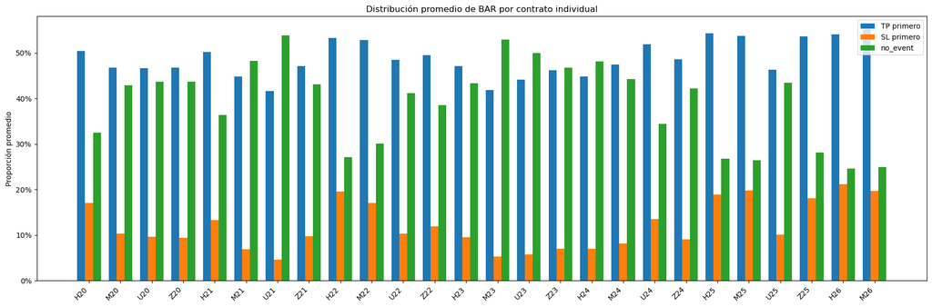

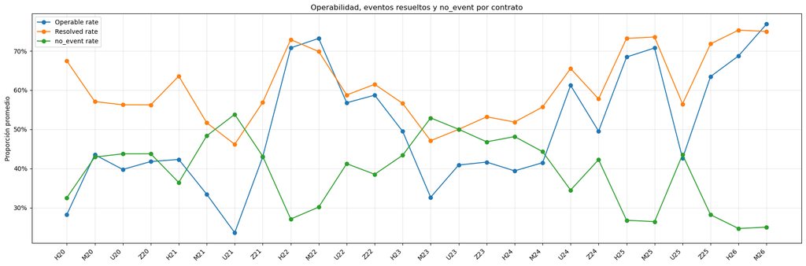

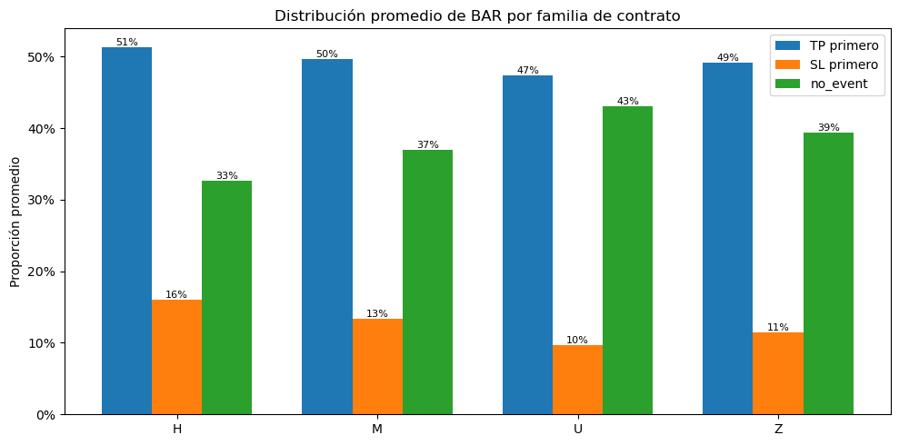

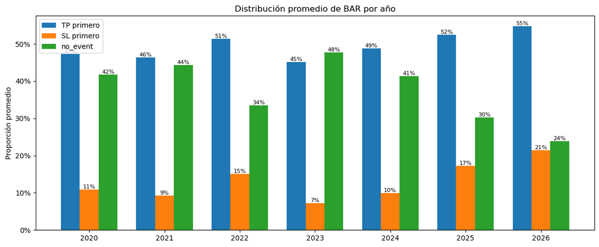

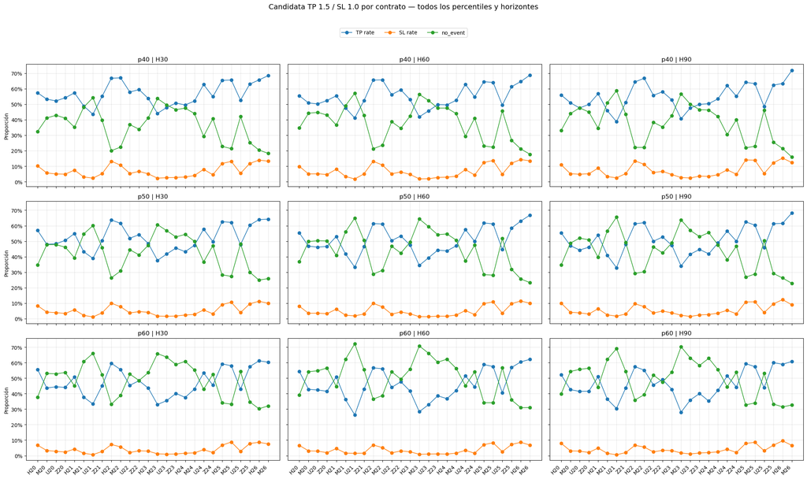

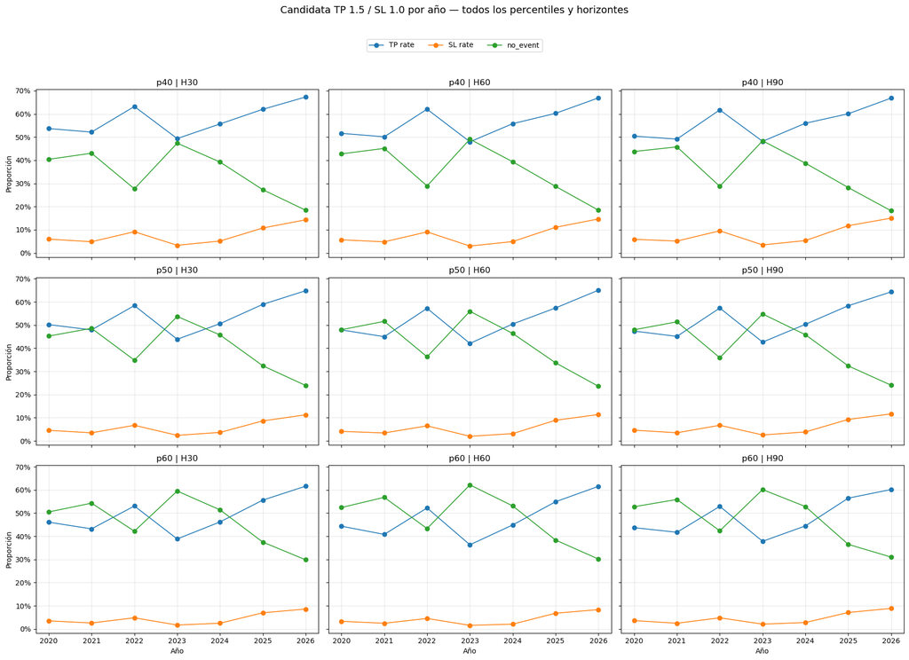

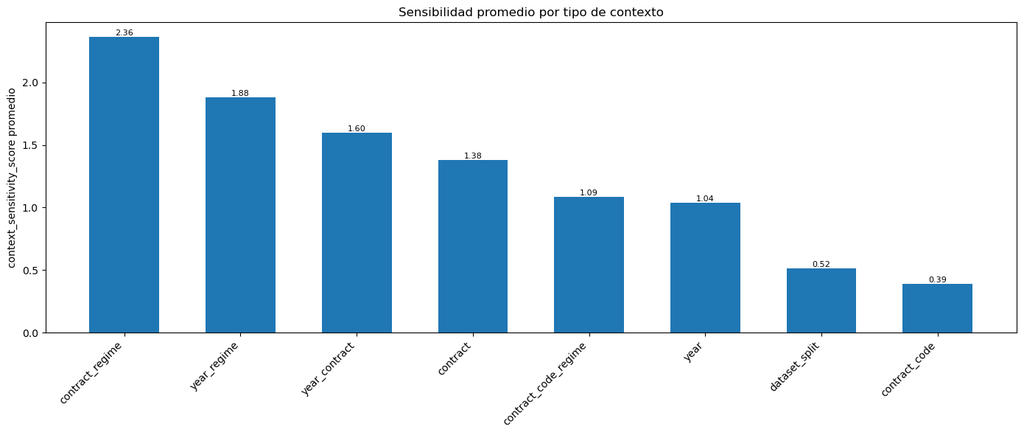

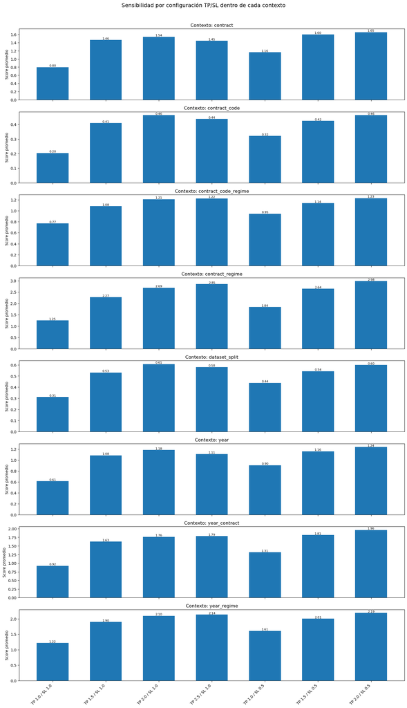

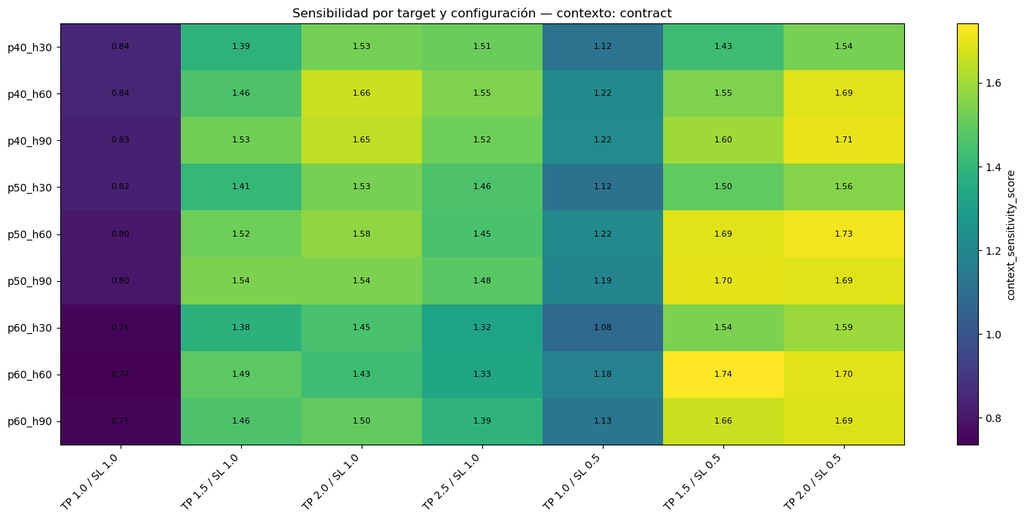

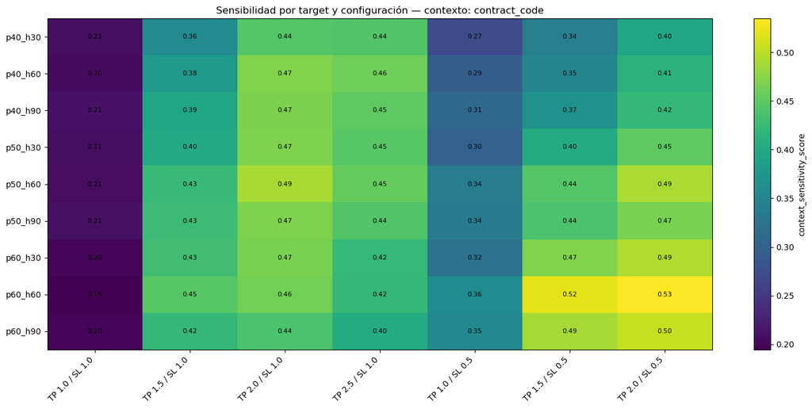

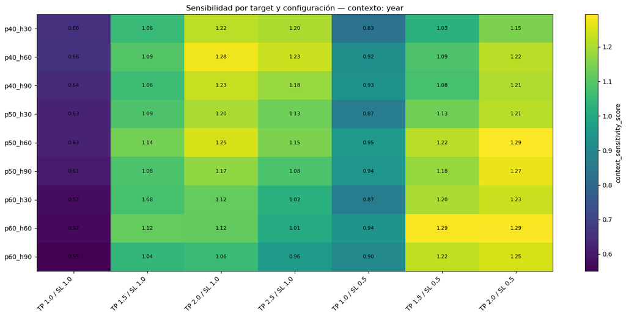

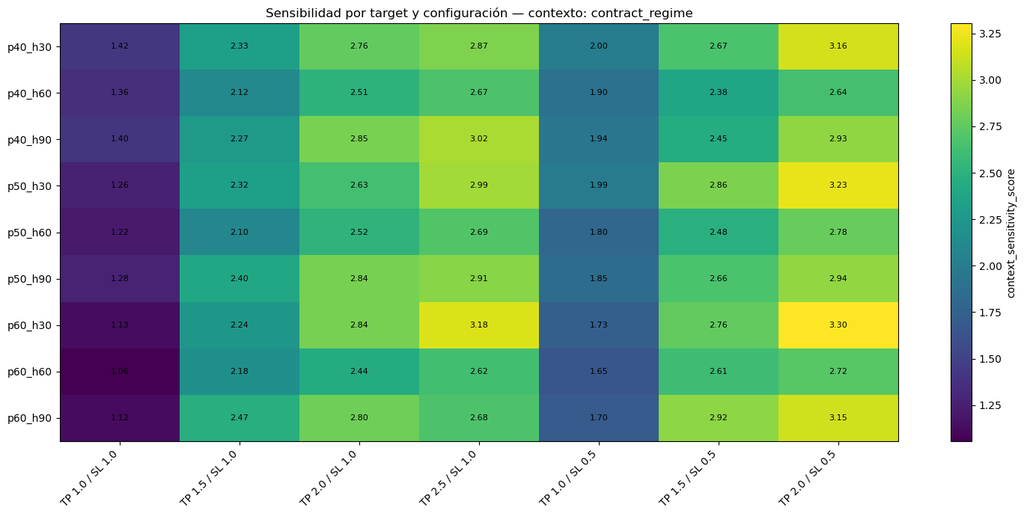

[3 more figures not shown]

```
Celda 3 finalizada correctamente.
```

```python
df_contract_config_plot = df_bar_context_contract_by_config.copy()
df_contract_config_plot = add_contract_sort(df_contract_config_plot, contract_col="contract")
df_contract_config_plot = add_config_label_and_order(df_contract_config_plot)

pivot_contract_tp = (
    df_contract_config_plot
    .pivot_table(
        index="contract",
        columns="config_label",
        values="tp_rate_mean",
        aggfunc="first"
    )
    .reindex(index=contracts_order)
    .reindex(columns=config_labels)
)

plot_heatmap_with_values(
    pivot_data=pivot_contract_tp,
    title="TP rate promedio por contrato y configuración TP/SL",
    value_format="{:.0%}",
    figsize=(15, 10),
    colorbar_label="TP rate",
    vmin=0,
    vmax=1
)

pivot_contract_no_event = (
    df_contract_config_plot
    .pivot_table(
        index="contract",
        columns="config_label",
        values="no_event_rate_mean",
        aggfunc="first"
    )
    .reindex(index=contracts_order)
    .reindex(columns=config_labels)
)

plot_heatmap_with_values(
    pivot_data=pivot_contract_no_event,
    title="no_event rate promedio por contrato y configuración TP/SL",
    value_format="{:.0%}",
    figsize=(15, 10),
    colorbar_label="no_event rate",
    vmin=0,
    vmax=1
)

print("\nCelda 3 finalizada correctamente.")
```

### Celda 4 — Guardado y tabla final para observaciones

```python
# Celda 4 — Guardado y tabla final para observaciones
# ============================================================

print("Guardado y tabla final de análisis por contrato y contexto - BAR")
print("=" * 80)

# ------------------------------------------------------------
# Validar objetos necesarios
# ------------------------------------------------------------

required_objects = [
    "df_bar_context_analysis",
    "df_bar_context_contract",
    "df_bar_context_contract_code",
    "df_bar_context_year",
    "df_bar_context_dataset_split",
    "df_bar_context_year_contract",
    "df_bar_context_contract_regime",
    "df_bar_context_year_regime",
    "df_bar_context_contract_code_regime",

    "df_bar_context_by_context_type",
    "df_bar_context_by_contract",
    "df_bar_context_by_contract_code",
    "df_bar_context_by_year",
    "df_bar_context_by_dataset_split",
    "df_bar_context_contract_by_config",

    "df_bar_context_candidate_tp15_sl10_contract",
    "df_bar_context_candidate_tp15_sl10_contract_code",
    "df_bar_context_candidate_tp15_sl10_year",

    "df_bar_context_sensitivity_by_target",
    "df_bar_context_sensitivity_by_context_type",
    "df_bar_context_sensitivity_by_config",
    "df_bar_context_sensitivity_by_target_base",

    "MNQ_TARGETS_PATH",
]

missing_objects = [
    obj for obj in required_objects
    if obj not in globals()
]

if missing_objects:
    raise NameError(
        "Faltan objetos necesarios. "
        f"Debes correr las celdas anteriores: {missing_objects}"
    )

# ------------------------------------------------------------
# Definir rutas de guardado
# ------------------------------------------------------------

MNQ_TARGETS_BAR_CONTEXT_ANALYSIS_CSV = (
    MNQ_TARGETS_PATH / "mnq_targets_bar_context_analysis.csv"
)

MNQ_TARGETS_BAR_CONTEXT_CONTRACT_CSV = (
    MNQ_TARGETS_PATH / "mnq_targets_bar_context_contract.csv"
)

MNQ_TARGETS_BAR_CONTEXT_CONTRACT_CODE_CSV = (
    MNQ_TARGETS_PATH / "mnq_targets_bar_context_contract_code.csv"
)

MNQ_TARGETS_BAR_CONTEXT_YEAR_CSV = (
    MNQ_TARGETS_PATH / "mnq_targets_bar_context_year.csv"
)

MNQ_TARGETS_BAR_CONTEXT_DATASET_SPLIT_CSV = (
    MNQ_TARGETS_PATH / "mnq_targets_bar_context_dataset_split.csv"
)

MNQ_TARGETS_BAR_CONTEXT_YEAR_CONTRACT_CSV = (
    MNQ_TARGETS_PATH / "mnq_targets_bar_context_year_contract.csv"
)

MNQ_TARGETS_BAR_CONTEXT_CONTRACT_REGIME_CSV = (
    MNQ_TARGETS_PATH / "mnq_targets_bar_context_contract_regime.csv"
)

MNQ_TARGETS_BAR_CONTEXT_YEAR_REGIME_CSV = (
    MNQ_TARGETS_PATH / "mnq_targets_bar_context_year_regime.csv"
)

MNQ_TARGETS_BAR_CONTEXT_CONTRACT_CODE_REGIME_CSV = (
    MNQ_TARGETS_PATH / "mnq_targets_bar_context_contract_code_regime.csv"
)

MNQ_TARGETS_BAR_CONTEXT_BY_CONTEXT_TYPE_CSV = (
    MNQ_TARGETS_PATH / "mnq_targets_bar_context_by_context_type.csv"
)

MNQ_TARGETS_BAR_CONTEXT_BY_CONTRACT_CSV = (
    MNQ_TARGETS_PATH / "mnq_targets_bar_context_by_contract.csv"
)

MNQ_TARGETS_BAR_CONTEXT_BY_CONTRACT_CODE_CSV = (
    MNQ_TARGETS_PATH / "mnq_targets_bar_context_by_contract_code.csv"
)

MNQ_TARGETS_BAR_CONTEXT_BY_YEAR_CSV = (
    MNQ_TARGETS_PATH / "mnq_targets_bar_context_by_year.csv"
)

MNQ_TARGETS_BAR_CONTEXT_BY_DATASET_SPLIT_CSV = (
    MNQ_TARGETS_PATH / "mnq_targets_bar_context_by_dataset_split.csv"
)

MNQ_TARGETS_BAR_CONTEXT_CONTRACT_BY_CONFIG_CSV = (
    MNQ_TARGETS_PATH / "mnq_targets_bar_context_contract_by_config.csv"
)

MNQ_TARGETS_BAR_CONTEXT_CANDIDATE_TP15_SL10_CONTRACT_CSV = (
    MNQ_TARGETS_PATH / "mnq_targets_bar_context_candidate_tp15_sl10_contract.csv"
)

MNQ_TARGETS_BAR_CONTEXT_CANDIDATE_TP15_SL10_CONTRACT_CODE_CSV = (
    MNQ_TARGETS_PATH / "mnq_targets_bar_context_candidate_tp15_sl10_contract_code.csv"
)

MNQ_TARGETS_BAR_CONTEXT_CANDIDATE_TP15_SL10_YEAR_CSV = (
    MNQ_TARGETS_PATH / "mnq_targets_bar_context_candidate_tp15_sl10_year.csv"
)

MNQ_TARGETS_BAR_CONTEXT_SENSITIVITY_BY_TARGET_CSV = (
    MNQ_TARGETS_PATH / "mnq_targets_bar_context_sensitivity_by_target.csv"
)

MNQ_TARGETS_BAR_CONTEXT_SENSITIVITY_BY_CONTEXT_TYPE_CSV = (
    MNQ_TARGETS_PATH / "mnq_targets_bar_context_sensitivity_by_context_type.csv"
)

MNQ_TARGETS_BAR_CONTEXT_SENSITIVITY_BY_CONFIG_CSV = (
    MNQ_TARGETS_PATH / "mnq_targets_bar_context_sensitivity_by_config.csv"
)

MNQ_TARGETS_BAR_CONTEXT_SENSITIVITY_BY_TARGET_BASE_CSV = (
    MNQ_TARGETS_PATH / "mnq_targets_bar_context_sensitivity_by_target_base.csv"
)

MNQ_TARGETS_BAR_CONTEXT_FINAL_TABLE_CSV = (
    MNQ_TARGETS_PATH / "mnq_targets_bar_context_final_table.csv"
)

MNQ_TARGETS_BAR_CONTEXT_PROFILE_COUNTS_CSV = (
    MNQ_TARGETS_PATH / "mnq_targets_bar_context_profile_counts.csv"
)

MNQ_TARGETS_BAR_CONTEXT_REPORT_TXT = (
    MNQ_TARGETS_PATH / "mnq_targets_bar_context_report.txt"
)

# ------------------------------------------------------------
# Crear tabla final de sensibilidad por contexto
# ------------------------------------------------------------

df_bar_context_final_table = df_bar_context_sensitivity_by_target.copy()

if "context_type" not in df_bar_context_final_table.columns:
    raise KeyError(
        "No existe la columna context_type en df_bar_context_sensitivity_by_target. "
        "Revisa la salida de la Celda 2."
    )

# ------------------------------------------------------------
# Clasificación relativa dentro de cada tipo de contexto
# ------------------------------------------------------------
# Menor score = menor dependencia de ese contexto.
# Mayor score = mayor dependencia de ese contexto.
#
# Se evita groupby().apply() para no perder la columna context_type
# en algunas versiones de pandas.
# ------------------------------------------------------------

classified_context_groups = []

for context_type, group in df_bar_context_final_table.groupby("context_type", dropna=False):

    group = group.copy()

    q33 = group["context_sensitivity_score"].quantile(0.33)
    q66 = group["context_sensitivity_score"].quantile(0.66)

    group["context_sensitivity_profile"] = np.where(
        group["context_sensitivity_score"].isna(),
        "sin_clasificar",
        np.where(
            group["context_sensitivity_score"] <= q33,
            "menor_sensibilidad",
            np.where(
                group["context_sensitivity_score"] <= q66,
                "sensibilidad_intermedia",
                "mayor_sensibilidad"
            )
        )
    )
```

```python
    classified_context_groups.append(group)

df_bar_context_final_table = (
    pd.concat(classified_context_groups, ignore_index=True)
    if classified_context_groups
    else pd.DataFrame()
)

# ------------------------------------------------------------
# Validar columnas necesarias para ordenar
# ------------------------------------------------------------

sort_cols = [
    "context_type",
    "context_sensitivity_score",
    "percentile",
    "horizon",
    "sl_mult",
    "tp_mult",
]

missing_sort_cols = [
    col for col in sort_cols
    if col not in df_bar_context_final_table.columns
]

if missing_sort_cols:
    raise KeyError(
        "Faltan columnas necesarias para ordenar df_bar_context_final_table: "
        f"{missing_sort_cols}\n\n"
        "Columnas disponibles:\n"
        f"{df_bar_context_final_table.columns.tolist()}"
    )

df_bar_context_final_table = (
    df_bar_context_final_table
    .sort_values(
        sort_cols,
        ascending=[True, True, True, True, True, True]
    )
    .reset_index(drop=True)
)

# ------------------------------------------------------------
# Conteo por perfil de sensibilidad
# ------------------------------------------------------------

df_bar_context_sensitivity_profile_counts = (
    df_bar_context_final_table
    .groupby(
        [
            "context_type",
            "context_sensitivity_profile",
        ],
        as_index=False
    )
    .agg(
        n_targets=("bar_col", "count"),

        context_sensitivity_score_mean=("context_sensitivity_score", "mean"),

        operable_rate_range_mean=("operable_rate_range", "mean"),
        tp_rate_range_mean=("tp_rate_range", "mean"),
        sl_rate_range_mean=("sl_rate_range", "mean"),
        no_event_rate_range_mean=("no_event_rate_range", "mean"),
        tp_share_range_mean=("tp_share_over_resolved_range", "mean"),

        expectancy_range_mean=("expectancy_units_range", "mean"),
        event_step_range_mean=("event_step_mean_range", "mean"),
    )
    .sort_values(["context_type", "context_sensitivity_score_mean"])
    .reset_index(drop=True)
)

# ------------------------------------------------------------
# Guardar tablas principales
# ------------------------------------------------------------

df_bar_context_analysis.to_csv(
    MNQ_TARGETS_BAR_CONTEXT_ANALYSIS_CSV,
    index=False
)

df_bar_context_contract.to_csv(
    MNQ_TARGETS_BAR_CONTEXT_CONTRACT_CSV,
    index=False
)

df_bar_context_contract_code.to_csv(
    MNQ_TARGETS_BAR_CONTEXT_CONTRACT_CODE_CSV,
    index=False
)

df_bar_context_year.to_csv(
    MNQ_TARGETS_BAR_CONTEXT_YEAR_CSV,
    index=False
)

df_bar_context_dataset_split.to_csv(
    MNQ_TARGETS_BAR_CONTEXT_DATASET_SPLIT_CSV,
    index=False
)

df_bar_context_year_contract.to_csv(
    MNQ_TARGETS_BAR_CONTEXT_YEAR_CONTRACT_CSV,
    index=False
)

df_bar_context_contract_regime.to_csv(
    MNQ_TARGETS_BAR_CONTEXT_CONTRACT_REGIME_CSV,
    index=False
)

df_bar_context_year_regime.to_csv(
    MNQ_TARGETS_BAR_CONTEXT_YEAR_REGIME_CSV,
    index=False
)

df_bar_context_contract_code_regime.to_csv(
    MNQ_TARGETS_BAR_CONTEXT_CONTRACT_CODE_REGIME_CSV,
    index=False
)

df_bar_context_by_context_type.to_csv(
    MNQ_TARGETS_BAR_CONTEXT_BY_CONTEXT_TYPE_CSV,
    index=False
)

df_bar_context_by_contract.to_csv(
    MNQ_TARGETS_BAR_CONTEXT_BY_CONTRACT_CSV,
    index=False
)

df_bar_context_by_contract_code.to_csv(
    MNQ_TARGETS_BAR_CONTEXT_BY_CONTRACT_CODE_CSV,
    index=False
)

df_bar_context_by_year.to_csv(
    MNQ_TARGETS_BAR_CONTEXT_BY_YEAR_CSV,
    index=False
)

df_bar_context_by_dataset_split.to_csv(
    MNQ_TARGETS_BAR_CONTEXT_BY_DATASET_SPLIT_CSV,
    index=False
)

df_bar_context_contract_by_config.to_csv(
    MNQ_TARGETS_BAR_CONTEXT_CONTRACT_BY_CONFIG_CSV,
    index=False
)

df_bar_context_candidate_tp15_sl10_contract.to_csv(
    MNQ_TARGETS_BAR_CONTEXT_CANDIDATE_TP15_SL10_CONTRACT_CSV,
    index=False
)

df_bar_context_candidate_tp15_sl10_contract_code.to_csv(
    MNQ_TARGETS_BAR_CONTEXT_CANDIDATE_TP15_SL10_CONTRACT_CODE_CSV,
    index=False
)

df_bar_context_candidate_tp15_sl10_year.to_csv(
    MNQ_TARGETS_BAR_CONTEXT_CANDIDATE_TP15_SL10_YEAR_CSV,
    index=False
)

df_bar_context_sensitivity_by_target.to_csv(
    MNQ_TARGETS_BAR_CONTEXT_SENSITIVITY_BY_TARGET_CSV,
    index=False
)

df_bar_context_sensitivity_by_context_type.to_csv(
    MNQ_TARGETS_BAR_CONTEXT_SENSITIVITY_BY_CONTEXT_TYPE_CSV,
    index=False
)

df_bar_context_sensitivity_by_config.to_csv(
    MNQ_TARGETS_BAR_CONTEXT_SENSITIVITY_BY_CONFIG_CSV,
    index=False
)

df_bar_context_sensitivity_by_target_base.to_csv(
    MNQ_TARGETS_BAR_CONTEXT_SENSITIVITY_BY_TARGET_BASE_CSV,
    index=False
)

df_bar_context_final_table.to_csv(
    MNQ_TARGETS_BAR_CONTEXT_FINAL_TABLE_CSV,
    index=False
)

df_bar_context_sensitivity_profile_counts.to_csv(
    MNQ_TARGETS_BAR_CONTEXT_PROFILE_COUNTS_CSV,
    index=False
)

# ------------------------------------------------------------
# Columnas para impresión
# ------------------------------------------------------------

context_type_cols = [
    "context_type",
    "context_description",
    "n_rows",
    "n_targets",
    "n_context_values",
    "operable_rate_mean",
    "tp_rate_mean",
    "sl_rate_mean",
    "no_event_rate_mean",
    "resolved_rate_mean",
    "tp_share_over_resolved_mean",
    "expectancy_units_mean",
    "event_step_mean",
]

contract_cols = [
    "contract",
    "n_targets",
    "total_rows_mean",
    "valid_rows_mean",
    "operable_rate_mean",
    "tp_rate_mean",
    "sl_rate_mean",
    "no_event_rate_mean",
    "resolved_rate_mean",
    "tp_share_over_resolved_mean",
    "expectancy_units_mean",
    "event_step_mean",
]

contract_code_cols = [
    "contract_code",
    "n_targets",
    "total_rows_mean",
    "valid_rows_mean",
    "operable_rate_mean",
    "tp_rate_mean",
    "sl_rate_mean",
    "no_event_rate_mean",
    "resolved_rate_mean",
    "tp_share_over_resolved_mean",
    "expectancy_units_mean",
    "event_step_mean",
]
```

```python
year_cols = [
    "year",
    "n_targets",
    "total_rows_mean",
    "valid_rows_mean",
    "operable_rate_mean",
    "tp_rate_mean",
    "sl_rate_mean",
    "no_event_rate_mean",
    "resolved_rate_mean",
    "tp_share_over_resolved_mean",
    "expectancy_units_mean",
    "event_step_mean",
]

dataset_split_cols = [
    "dataset_split",
    "n_targets",
    "total_rows_mean",
    "valid_rows_mean",
    "operable_rate_mean",
    "tp_rate_mean",
    "sl_rate_mean",
    "no_event_rate_mean",
    "resolved_rate_mean",
    "tp_share_over_resolved_mean",
    "expectancy_units_mean",
    "event_step_mean",
]

candidate_contract_cols = [
    "bar_col",
    "target_base",
    "contract",
    "total_rows",
    "valid_rows",
    "operable_rate",
    "tp_rate",
    "sl_rate",
    "no_event_rate",
    "resolved_rate",
    "tp_share_over_resolved",
    "expectancy_units",
    "event_step_mean",
]

candidate_year_cols = [
    "bar_col",
    "target_base",
    "year",
    "total_rows",
    "valid_rows",
    "operable_rate",
    "tp_rate",
    "sl_rate",
    "no_event_rate",
    "resolved_rate",
    "tp_share_over_resolved",
    "expectancy_units",
    "event_step_mean",
]

sensitivity_context_type_cols = [
    "context_type",
    "n_targets",
    "n_context_values_mean",
    "operable_rate_range_mean",
    "tp_rate_range_mean",
    "sl_rate_range_mean",
    "no_event_rate_range_mean",
    "tp_share_range_mean",
    "expectancy_range_mean",
    "event_step_range_mean",
    "context_sensitivity_score_mean",
    "context_sensitivity_score_max",
]

sensitivity_config_cols = [
    "context_type",
    "tp_sl_config",
    "n_targets",
    "operable_rate_range_mean",
    "tp_rate_range_mean",
    "sl_rate_range_mean",
    "no_event_rate_range_mean",
    "tp_share_range_mean",
    "expectancy_range_mean",
    "context_sensitivity_score_mean",
    "context_sensitivity_score_max",
]

sensitivity_target_base_cols = [
    "context_type",
    "target_base",
    "percentile",
    "horizon",
    "n_configs",
    "operable_rate_range_mean",
    "tp_rate_range_mean",
    "sl_rate_range_mean",
    "no_event_rate_range_mean",
    "tp_share_range_mean",
    "expectancy_range_mean",
    "context_sensitivity_score_mean",
    "context_sensitivity_score_max",
]

final_table_cols = [
    "context_type",
    "bar_col",
    "target_base",
    "tp_sl_config",
    "n_context_values",
    "operable_rate_mean",
    "operable_rate_range",
    "tp_rate_mean",
    "tp_rate_range",
    "sl_rate_mean",
    "sl_rate_range",
    "no_event_rate_mean",
    "no_event_rate_range",
    "resolved_rate_mean",
    "resolved_rate_range",
    "tp_share_over_resolved_mean",
    "tp_share_over_resolved_range",
    "expectancy_units_mean",
    "expectancy_units_range",
    "event_step_mean_mean",
    "event_step_mean_range",
    "context_sensitivity_score",
    "context_sensitivity_profile",
]

profile_count_cols = [
    "context_type",
    "context_sensitivity_profile",
    "n_targets",
    "context_sensitivity_score_mean",
    "operable_rate_range_mean",
    "tp_rate_range_mean",
    "sl_rate_range_mean",
    "no_event_rate_range_mean",
    "tp_share_range_mean",
    "expectancy_range_mean",
    "event_step_range_mean",
]

# ------------------------------------------------------------
# Formateadores
# ------------------------------------------------------------

percent_formatters = {
    "operable_rate_mean": "{:.2%}".format,
    "tp_rate_mean": "{:.2%}".format,
    "sl_rate_mean": "{:.2%}".format,
    "no_event_rate_mean": "{:.2%}".format,
    "resolved_rate_mean": "{:.2%}".format,
    "tp_share_over_resolved_mean": "{:.2%}".format,

    "operable_rate": "{:.2%}".format,
    "tp_rate": "{:.2%}".format,
    "sl_rate": "{:.2%}".format,
    "no_event_rate": "{:.2%}".format,
    "resolved_rate": "{:.2%}".format,
    "tp_share_over_resolved": "{:.2%}".format,

    "operable_rate_range": "{:.2%}".format,
    "tp_rate_range": "{:.2%}".format,
    "sl_rate_range": "{:.2%}".format,
    "no_event_rate_range": "{:.2%}".format,
    "resolved_rate_range": "{:.2%}".format,
    "tp_share_over_resolved_range": "{:.2%}".format,

    "operable_rate_range_mean": "{:.2%}".format,
    "tp_rate_range_mean": "{:.2%}".format,
    "sl_rate_range_mean": "{:.2%}".format,
    "no_event_rate_range_mean": "{:.2%}".format,
    "tp_share_range_mean": "{:.2%}".format,
}

numeric_formatters = {
    "total_rows_mean": "{:.0f}".format,
    "valid_rows_mean": "{:.0f}".format,
    "expectancy_units_mean": "{:.3f}".format,
    "expectancy_units": "{:.3f}".format,
    "expectancy_units_range": "{:.3f}".format,
    "expectancy_range_mean": "{:.3f}".format,
    "event_step_mean": "{:.2f}".format,
    "event_step_mean_mean": "{:.2f}".format,
    "event_step_mean_range": "{:.2f}".format,
    "event_step_range_mean": "{:.2f}".format,
    "n_context_values_mean": "{:.1f}".format,
    "context_sensitivity_score": "{:.3f}".format,
    "context_sensitivity_score_mean": "{:.3f}".format,
    "context_sensitivity_score_max": "{:.3f}".format,
}

formatters = {
    **percent_formatters,
    **numeric_formatters,
}

# ------------------------------------------------------------
# Impresiones principales
# ------------------------------------------------------------

print("\nResumen general por tipo de contexto:")
print(
    df_bar_context_by_context_type[context_type_cols]
    .to_string(
        index=False,
        formatters=formatters
    )
)

print("\nResumen por contrato individual:")
print(
    df_bar_context_by_contract[contract_cols]
    .to_string(
        index=False,
        formatters=formatters
    )
)

print("\nResumen por familia de contrato:")
print(
    df_bar_context_by_contract_code[contract_code_cols]
    .to_string(
        index=False,
        formatters=formatters
    )
)

print("\nResumen por año:")
print(
    df_bar_context_by_year[year_cols]
    .to_string(
        index=False,
        formatters=formatters
    )
)

print("\nResumen por split metodológico:")
print(
    df_bar_context_by_dataset_split[dataset_split_cols]
    .to_string(
        index=False,
        formatters=formatters
    )
)
```

```python
print("\nDetalle por contrato para candidata TP 1.5 / SL 1.0:")
print(
    df_bar_context_candidate_tp15_sl10_contract[candidate_contract_cols]
    .head(120)
    .to_string(
        index=False,
        formatters=formatters
    )
)

print("\nDetalle por año para candidata TP 1.5 / SL 1.0:")
print(
    df_bar_context_candidate_tp15_sl10_year[candidate_year_cols]
    .to_string(
        index=False,
        formatters=formatters
    )
)

print("\nSensibilidad agregada por tipo de contexto:")
print(
    df_bar_context_sensitivity_by_context_type[sensitivity_context_type_cols]
    .to_string(
        index=False,
        formatters=formatters
    )
)

print("\nSensibilidad por configuración TP/SL dentro de cada contexto:")
print(
    df_bar_context_sensitivity_by_config[sensitivity_config_cols]
    .to_string(
        index=False,
        formatters=formatters
    )
)

print("\nSensibilidad por percentil/horizonte dentro de cada contexto:")
print(
    df_bar_context_sensitivity_by_target_base[sensitivity_target_base_cols]
    .to_string(
        index=False,
        formatters=formatters
    )
)

print("\nTabla final de sensibilidad por contrato/contexto:")
print(
    df_bar_context_final_table[final_table_cols]
    .to_string(
        index=False,
        formatters=formatters
    )
)

# ------------------------------------------------------------
# Top targets por contextos principales
# ------------------------------------------------------------

main_contexts_for_print = [
    "contract",
    "contract_code",
    "year",
    "year_contract",
    "contract_regime",
    "year_regime",
]

for context_type in main_contexts_for_print:

    tmp = df_bar_context_final_table[
        df_bar_context_final_table["context_type"] == context_type
    ].copy()

    if tmp.empty:
        continue

    print(f"\nTop 15 targets con menor sensibilidad — contexto: {context_type}")
    print(
        tmp[final_table_cols]
        .head(15)
        .to_string(
            index=False,
            formatters=formatters
        )
    )

    print(f"\nTop 15 targets con mayor sensibilidad — contexto: {context_type}")
    print(
        tmp[final_table_cols]
        .tail(15)
        .sort_values("context_sensitivity_score", ascending=False)
        .to_string(
            index=False,
            formatters=formatters
        )
    )

# ------------------------------------------------------------
# Conteo por perfil de sensibilidad
# ------------------------------------------------------------

print("\nConteo por perfil de sensibilidad contextual:")
print(
    df_bar_context_sensitivity_profile_counts[profile_count_cols]
    .to_string(
        index=False,
        formatters=formatters
    )
)

# ------------------------------------------------------------
# Guardar reporte TXT
# ------------------------------------------------------------

with MNQ_TARGETS_BAR_CONTEXT_REPORT_TXT.open("w", encoding="utf-8") as f:
    f.write("4.11. Análisis por contrato y contexto - BAR\n")
    f.write("=" * 100 + "\n\n")

    f.write("Resumen general por tipo de contexto\n")
    f.write("-" * 100 + "\n")
    f.write(
        df_bar_context_by_context_type[context_type_cols]
        .to_string(
            index=False,
            formatters=formatters
        )
    )

    f.write("\n\n")
    f.write("Resumen por contrato individual\n")
    f.write("-" * 100 + "\n")
    f.write(
        df_bar_context_by_contract[contract_cols]
        .to_string(
            index=False,
            formatters=formatters
        )
    )

    f.write("\n\n")
    f.write("Resumen por familia de contrato\n")
    f.write("-" * 100 + "\n")
    f.write(
        df_bar_context_by_contract_code[contract_code_cols]
        .to_string(
            index=False,
            formatters=formatters
        )
    )

    f.write("\n\n")
    f.write("Resumen por año\n")
    f.write("-" * 100 + "\n")
    f.write(
        df_bar_context_by_year[year_cols]
        .to_string(
            index=False,
            formatters=formatters
        )
    )

    f.write("\n\n")
    f.write("Resumen por split metodológico\n")
    f.write("-" * 100 + "\n")
    f.write(
        df_bar_context_by_dataset_split[dataset_split_cols]
        .to_string(
            index=False,
            formatters=formatters
        )
    )

    f.write("\n\n")
    f.write("Detalle por contrato para candidata TP 1.5 / SL 1.0\n")
    f.write("-" * 100 + "\n")
    f.write(
        df_bar_context_candidate_tp15_sl10_contract[candidate_contract_cols]
        .to_string(
            index=False,
            formatters=formatters
        )
    )

    f.write("\n\n")
    f.write("Detalle por año para candidata TP 1.5 / SL 1.0\n")
    f.write("-" * 100 + "\n")
    f.write(
        df_bar_context_candidate_tp15_sl10_year[candidate_year_cols]
        .to_string(
            index=False,
            formatters=formatters
        )
    )

    f.write("\n\n")
    f.write("Sensibilidad agregada por tipo de contexto\n")
    f.write("-" * 100 + "\n")
    f.write(
        df_bar_context_sensitivity_by_context_type[sensitivity_context_type_cols]
        .to_string(
            index=False,
            formatters=formatters
        )
    )

    f.write("\n\n")
    f.write("Sensibilidad por configuración TP/SL dentro de cada contexto\n")
    f.write("-" * 100 + "\n")
    f.write(
        df_bar_context_sensitivity_by_config[sensitivity_config_cols]
        .to_string(
            index=False,
            formatters=formatters
        )
    )

    f.write("\n\n")
    f.write("Sensibilidad por percentil/horizonte dentro de cada contexto\n")
    f.write("-" * 100 + "\n")
    f.write(
        df_bar_context_sensitivity_by_target_base[sensitivity_target_base_cols]
        .to_string(
            index=False,
            formatters=formatters
        )
    )

    f.write("\n\n")
    f.write("Tabla final de sensibilidad por contrato/contexto\n")
    f.write("-" * 100 + "\n")
    f.write(
        df_bar_context_final_table[final_table_cols]
        .to_string(
            index=False,
            formatters=formatters
        )
    )
```

```python
    f.write("\n\n")
    f.write("Conteo por perfil de sensibilidad contextual\n")
    f.write("-" * 100 + "\n")
    f.write(
        df_bar_context_sensitivity_profile_counts[profile_count_cols]
        .to_string(
            index=False,
            formatters=formatters
        )
    )

# ------------------------------------------------------------
# Confirmación final
# ------------------------------------------------------------

print("\nArchivos guardados:")
print(f"Análisis BAR por contexto:                 {MNQ_TARGETS_BAR_CONTEXT_ANALYSIS_CSV}")
print(f"Contexto contrato individual:              {MNQ_TARGETS_BAR_CONTEXT_CONTRACT_CSV}")
print(f"Contexto familia de contrato:              {MNQ_TARGETS_BAR_CONTEXT_CONTRACT_CODE_CSV}")
print(f"Contexto año:                              {MNQ_TARGETS_BAR_CONTEXT_YEAR_CSV}")
print(f"Contexto dataset split:                    {MNQ_TARGETS_BAR_CONTEXT_DATASET_SPLIT_CSV}")
print(f"Contexto año + contrato:                   {MNQ_TARGETS_BAR_CONTEXT_YEAR_CONTRACT_CSV}")
print(f"Contexto contrato + régimen:               {MNQ_TARGETS_BAR_CONTEXT_CONTRACT_REGIME_CSV}")
print(f"Contexto año + régimen:                    {MNQ_TARGETS_BAR_CONTEXT_YEAR_REGIME_CSV}")
print(f"Contexto familia contrato + régimen:       {MNQ_TARGETS_BAR_CONTEXT_CONTRACT_CODE_REGIME_CSV}")

print(f"Resumen por tipo de contexto:              {MNQ_TARGETS_BAR_CONTEXT_BY_CONTEXT_TYPE_CSV}")
print(f"Resumen por contrato:                      {MNQ_TARGETS_BAR_CONTEXT_BY_CONTRACT_CSV}")
print(f"Resumen por familia de contrato:           {MNQ_TARGETS_BAR_CONTEXT_BY_CONTRACT_CODE_CSV}")
print(f"Resumen por año:                           {MNQ_TARGETS_BAR_CONTEXT_BY_YEAR_CSV}")
print(f"Resumen por split metodológico:            {MNQ_TARGETS_BAR_CONTEXT_BY_DATASET_SPLIT_CSV}")
print(f"Resumen contrato por configuración:        {MNQ_TARGETS_BAR_CONTEXT_CONTRACT_BY_CONFIG_CSV}")

print(f"Candidata TP 1.5 / SL 1.0 por contrato:    {MNQ_TARGETS_BAR_CONTEXT_CANDIDATE_TP15_SL10_CONTRACT_CSV}")
print(f"Candidata TP 1.5 / SL 1.0 por familia:     {MNQ_TARGETS_BAR_CONTEXT_CANDIDATE_TP15_SL10_CONTRACT_CODE_CSV}")
print(f"Candidata TP 1.5 / SL 1.0 por año:         {MNQ_TARGETS_BAR_CONTEXT_CANDIDATE_TP15_SL10_YEAR_CSV}")

print(f"Sensibilidad por target/contexto:          {MNQ_TARGETS_BAR_CONTEXT_SENSITIVITY_BY_TARGET_CSV}")
print(f"Sensibilidad por tipo de contexto:         {MNQ_TARGETS_BAR_CONTEXT_SENSITIVITY_BY_CONTEXT_TYPE_CSV}")
print(f"Sensibilidad por configuración/contexto:   {MNQ_TARGETS_BAR_CONTEXT_SENSITIVITY_BY_CONFIG_CSV}")
print(f"Sensibilidad por percentil/horizonte:      {MNQ_TARGETS_BAR_CONTEXT_SENSITIVITY_BY_TARGET_BASE_CSV}")

print(f"Tabla final contexto:                      {MNQ_TARGETS_BAR_CONTEXT_FINAL_TABLE_CSV}")
print(f"Conteo perfiles contexto:                  {MNQ_TARGETS_BAR_CONTEXT_PROFILE_COUNTS_CSV}")
print(f"Reporte TXT:                               {MNQ_TARGETS_BAR_CONTEXT_REPORT_TXT}")

print("\nCelda 4 finalizada correctamente.")
```

```
Guardado y tabla final de análisis por contrato y contexto - BAR
================================================================================

Resumen general por tipo de contexto:
        context_type                       context_description  n_rows  n_targets  n_context_values operable_rate_mean tp_rate_mean sl_rate_mean no_event_rate_mean resolved_rate_mean tp_share_over_resolved_mean expectancy_units_mean event_step_mean
            contract                       Contrato individual    1638         63                26             50.08%       48.79%       12.04%             39.17%             60.83%                      78.28%                 0.590           30.40
       contract_code               Familia de contrato H/M/U/Z     252         63                 4             49.23%       49.38%       12.62%             37.99%             62.01%                      77.31%                 0.599           29.42
contract_code_regime Familia de contrato + régimen intradiario    1260         63                20             42.29%       49.20%       12.25%             38.55%             61.45%                      77.66%                 0.596           29.03
     contract_regime            Contrato + régimen intradiario    8190         63               130             42.98%       48.44%       11.53%             40.03%             59.97%                      78.67%                 0.585           30.23
       dataset_split                 Development vs final test     126         63                 2             54.66%       50.70%       14.69%             34.61%             65.39%                      75.80%                 0.615           28.00
                year                            Año calendario     441         63                 7             51.86%       49.48%       12.99%             37.53%             62.47%                      77.29%                 0.599           29.47
       year_contract                            Año + contrato    2016         63                32             47.87%       48.51%       11.23%             40.26%             59.74%                      79.34%                 0.589           30.99
         year_regime                 Año + régimen intradiario    2205         63                35             44.64%       49.19%       12.55%             38.25%             61.75%                      77.52%                 0.595           29.19

Resumen por contrato individual:
contract  n_targets total_rows_mean valid_rows_mean operable_rate_mean tp_rate_mean sl_rate_mean no_event_rate_mean resolved_rate_mean tp_share_over_resolved_mean expectancy_units_mean event_step_mean
     H20         63           33168            9358             28.21%       50.43%       17.06%             32.52%             67.48%                      72.56%                 0.600           26.29
     M20         63           38696           16840             43.52%       46.76%       10.33%             42.91%             57.09%                      78.44%                 0.560           31.00
     U20         63           42151           16752             39.74%       46.67%        9.59%             43.74%             56.26%                      79.32%                 0.561           31.38
     Z20         63           36623           15298             41.77%       46.80%        9.45%             43.75%             56.25%                      79.86%                 0.563           32.01
     H21         63           40769           17248             42.31%       50.27%       13.31%             36.42%             63.58%                      76.85%                 0.613           28.63
     M21         63           42151           14081             33.41%       44.80%        6.87%             48.33%             51.67%                      82.50%                 0.537           34.42
     U21         63           41460            9779             23.59%       41.61%        4.56%             53.83%             46.17%                      84.46%                 0.487           37.19
     Z21         63           42842           18397             42.94%       47.10%        9.78%             43.11%             56.89%                      79.81%                 0.568           32.50
     H22         63           42151           29843             70.80%       53.34%       19.58%             27.08%             72.92%                      72.24%                 0.644           25.64
     M22         63           42151           30863             73.22%       52.83%       17.04%             30.13%             69.87%                      74.24%                 0.643           28.01
```

[output cut: 1151 more lines]

### Observaciones principales — 4.11. Análisis por contrato y contexto

El análisis se construyó correctamente sobre los **63 targets BAR**, generando **16.128 filas** al combinar targets con distintos contextos: contrato individual, familia de contrato, año, split metodológico, año+contrato, contrato+régimen, año+régimen y familia de contrato+régimen. Se detectaron **26 contratos individuales**, **4 familias de contrato**, **7 años**, **2 splits metodológicos** y combinaciones contextuales más detalladas.

A nivel general, las métricas promedio de `BAR` son relativamente coherentes entre contextos: el `tp_rate_mean` se mantiene cerca del 48%–51%, el `sl_rate_mean` entre 11%–15%, y el `no_event_rate_mean` entre 34%–40%. Sin embargo, esta estabilidad promedio esconde diferencias importantes cuando se analiza por contrato individual y por año.

Por contrato individual, se observa una heterogeneidad fuerte. Algunos contratos tienen alta operabilidad y alta resolución de eventos, como `H22`, `M22`, `H25`, `M25`, `Z25`, `H26` y `M26`. En cambio, otros contratos como `U21`, `M23`, `U23` y parte de 2023 muestran menor operabilidad, mayor `no_event` y menor velocidad de resolución. Esto indica que no todos los contratos ofrecen el mismo tipo de entorno operativo para `BAR`.

Por familia de contrato, la diferencia es menor. La familia `H` muestra mayor operabilidad promedio, mayor `tp_rate`, pero también mayor `sl_rate`. La familia `U` aparece como la más conservadora: menor operabilidad, menor `tp_rate`, menor `sl_rate` y mayor `no_event`. Sin embargo, la sensibilidad por `contract_code` es la más baja de todos los contextos, con un `context_sensitivity_score_mean` de apenas **0.389**. Esto sugiere que la letra del contrato por sí sola no explica gran parte del comportamiento de `BAR`.

El análisis por año es mucho más relevante. Los años **2020 y 2021** muestran menor operabilidad y mayor `no_event`. El año **2022** aparece como un año claramente más activo, con mayor operabilidad, mayor `tp_rate`, mayor `sl_rate` y menor `no_event`. El año **2023** se comporta como un período más lento o menos resolutivo, con el mayor `no_event` y bajo `sl_rate`. Los años **2025 y 2026** muestran un entorno mucho más activo: suben la operabilidad, el `tp_rate`, el `sl_rate` y baja fuertemente el `no_event`.

La comparación por split metodológico confirma lo anterior. En `development_2020_2024`, la operabilidad promedio es **45.82%**, el `tp_rate_mean` **48.29%**, el `sl_rate_mean` **10.97%** y el `no_event_rate_mean` **40.74%**. En cambio, en `final_test_2025_2026`, la operabilidad sube a **63.50%**, el `tp_rate_mean` a **53.12%**, el `sl_rate_mean` a **18.40%** y el `no_event_rate_mean` baja a **28.48%**. Esto confirma que 2025–2026 no es simplemente “más rentable”, sino un entorno más activo y también más riesgoso.

La candidata `TP 1.5 / SL 1.0` sigue teniendo buen comportamiento general, pero claramente no es estacionaria. En años más activos como 2022, 2025 y 2026 aumenta la tasa de TP y baja el `no_event`, pero también aumenta la tasa de SL. En años más lentos como 2021 y 2023, el `no_event` sube y las operaciones tardan más en resolverse. Esto refuerza que `TP 1.5 / SL 1.0` sigue siendo una candidata razonable, pero debe evaluarse con variables de contexto.

El ranking de sensibilidad contextual es muy claro. El contexto más sensible es `contract_regime`, con un score promedio de **2.361**. Luego aparecen `year_regime` con **1.881**, `year_contract` con **1.598** y `contract` con **1.381**. Los contextos menos sensibles son `dataset_split` con **0.516** y `contract_code` con **0.389**. Esto indica que el comportamiento de `BAR` cambia mucho más cuando se combina contrato o año con régimen intradiario, y mucho menos cuando solo se mira la familia de contrato.

También se confirma el patrón visto antes: `TP 1.0 / SL 1.0` es la configuración más estable, pero sigue siendo un benchmark favorecido por la construcción del target. Las configuraciones más exigentes, como `TP 2.0 / SL 1.0`, `TP 2.5 / SL 1.0` y las variantes con `SL 0.5`, son más sensibles al contexto. Esto significa que cuanto más exigente o más ajustada sea la barrera, más depende el resultado del entorno de mercado.

Un punto metodológico importante: el `context_sensitivity_score` incluye la variación de `operable_rate`. Por eso, los contextos combinados con régimen, especialmente `contract_regime` y `year_regime`, pueden verse muy sensibles en parte porque incluyen regímenes con baja cantidad de ventanas válidas, como `Closing`. Conviene interpretar esos resultados con cautela y, si seguimos profundizando, hacer una versión excluyendo `Closing` o tratándolo por separado.

En síntesis:

```
    Contrato individual     → sí importa, pero principalmente por el período histórico que representa.
    Familia H/M/U/Z         → aporta información, pero no parece ser el factor dominante.
    Año                     → muy importante; 2022, 2025 y 2026 son claramente más activos.
    Split 2020–2024 / 2025–2026 → confirma cambio fuerte fuera de muestra.
    Contrato + régimen      → máxima sensibilidad contextual.
    Año + régimen           → también muy sensible.
```

La conclusión operativa es que `BAR` no debe modelarse como un target completamente estacionario. El modelo probablemente necesitará capturar información de **año, contrato, régimen intradiario, volatilidad reciente y contexto temporal** para generalizar mejor.

Para continuar, mantendría como candidata principal:

```
    bar_p50_h30_tp15_sl10
    bar_p50_h60_tp15_sl10
    bar_p50_h90_tp15_sl10
```

y usaría como comparación selectiva:

```
    bar_p60_h30_tp15_sl10
    bar_p60_h60_tp15_sl10
    bar_p60_h90_tp15_sl10
```

Pero con una advertencia importante: la selección final no debería basarse solo en métricas globales. Debe considerar estabilidad temporal, sensibilidad por contrato, comportamiento por régimen y desempeño fuera de muestra.

## 4.12. Observaciones e interpretación

El análisis del target `BAR` permitió evaluar el comportamiento operativo de las señales generadas a partir de `DIR`, incorporando explícitamente la dinámica entre `Take Profit`, `Stop Loss` y ausencia de evento dentro de cada horizonte temporal.

A diferencia de `DIR`, que solo identifica si existe una dirección significativa dentro de la ventana futura, `BAR` introduce una lógica más cercana a la ejecución operativa. En este caso, no solo importa si el precio se mueve a favor o en contra, sino también qué barrera se alcanza primero. Por este motivo, `BAR` representa un target más exigente y más alineado con la lógica real de una operación.

La construcción de `BAR` se realizó correctamente para todas las combinaciones definidas de percentil, horizonte y configuración TP/SL. Se evaluaron 63 variantes, derivadas de 9 targets base `DIR` y 7 configuraciones de barreras. La validación confirmó que los targets respetan la estructura esperada: solo existen valores válidos cuando `DIR` genera una operación, los eventos se clasifican correctamente como `TP`, `SL` o `no_event`, y no se cruzan días en la construcción de las ventanas futuras.

Una primera conclusión importante es que las configuraciones TP/SL no deben interpretarse de forma aislada. Cada configuración cambia de manera significativa la frecuencia de eventos, la proporción de operaciones resueltas, el tiempo hasta evento y la sensibilidad al contexto. Por lo tanto, la selección de una configuración operativa no puede basarse solamente en la tasa de TP global.

La configuración `TP 1.0 / SL 1.0` mostró el comportamiento más estable y la mayor tasa de resolución. Sin embargo, debe interpretarse principalmente como un benchmark metodológico, ya que está muy favorecida por la propia construcción del target `DIR`. Al utilizar un TP igual al umbral que define la señal direccional, muchas operaciones tienden naturalmente a alcanzar el TP. Por este motivo, aunque es útil como referencia, no parece ser la configuración más realista para evaluar una estrategia operativa más exigente.

La configuración `TP 1.5 / SL 1.0` aparece como la alternativa más equilibrada. Mantiene una tasa de TP razonable, una tasa de SL relativamente baja y una proporción favorable de TP sobre eventos resueltos. Además, no es tan fácil como `TP 1.0 / SL 1.0`, pero tampoco tan restrictiva como `TP 2.0 / SL 1.0` o `TP 2.5 / SL 1.0`. Por este motivo, se mantiene como la principal candidata para continuar el análisis.

Las configuraciones `TP 2.0 / SL 1.0` y `TP 2.5 / SL 1.0` son más exigentes y generan un aumento importante de `no_event`. Esto indica que, aunque pueden representar objetivos operativos más ambiciosos, muchas operaciones no alcanzan ninguna barrera dentro del horizonte evaluado. En consecuencia, estas configuraciones son más difíciles de modelar y más dependientes del contexto de mercado.

Las configuraciones con `SL 0.5` permiten evaluar escenarios de stop más ajustado. Sin embargo, muestran mayor sensibilidad al ruido y al contexto. Un stop más cercano puede mejorar el control de pérdida por operación, pero también aumenta la probabilidad de salida prematura por movimientos adversos pequeños. Por eso, estas configuraciones deben interpretarse como escenarios comparativos más agresivos, no necesariamente como candidatas principales.

El análisis del tiempo hasta evento mostró que los eventos tienden a resolverse más tarde a medida que aumenta el horizonte. Esto es esperable, ya que los horizontes de 60 y 90 minutos ofrecen más espacio temporal para alcanzar una barrera. También se observó que los `SL`, cuando ocurren, suelen presentarse antes que los `TP`, especialmente en configuraciones donde el TP está más lejos que el SL. Esto no significa que las operaciones ganadoras sean lentas en todos los casos, sino que los eventos perdedores tienden a materializarse con mayor rapidez cuando la operación se mueve en contra.

El análisis de estabilidad temporal mostró que `BAR` no es estacionario. Los años 2022, 2025 y 2026 presentan mayor actividad, mayor operabilidad y mayor tasa de eventos resueltos. En cambio, años como 2021 y 2023 muestran más casos de `no_event` y menor resolución operativa. Esto confirma que el comportamiento del target depende fuertemente del contexto histórico del mercado.

La comparación entre `development_2020_2024` y `final_test_2025_2026` es especialmente relevante. En el período final aumentan la operabilidad, la tasa de TP y la tasa de SL, mientras disminuye el `no_event`. Esto indica que 2025–2026 no representa simplemente un entorno más favorable, sino un mercado más activo y también más riesgoso. Por lo tanto, la mejora en TP debe interpretarse junto con el aumento del riesgo de SL.

El análisis por régimen intradiario mostró que `BAR` mantiene una estructura razonablemente consistente entre `Overnight`, `Pre-market`, `Opening` y `Regular`, aunque existen diferencias. `Opening` tiende a mostrar menor tasa de SL, pero mayor proporción de `no_event`. `Pre-market` presenta tiempos promedio hasta evento más altos. `Regular` y `Overnight` muestran un comportamiento más equilibrado y representativo. El régimen `Closing` debe tratarse por separado, ya que para horizontes largos tiene muy pocas ventanas futuras válidas sin cruzar el cierre del día.

El análisis por contrato y contexto confirmó que el comportamiento de `BAR` cambia de forma importante según el período histórico. La familia de contrato `H/M/U/Z` por sí sola no parece explicar gran parte de la variación. En cambio, el año, el contrato individual y, sobre todo, las combinaciones de contrato con régimen o año con régimen muestran una sensibilidad mucho mayor. Esto sugiere que el modelo no debería depender únicamente de la letra del contrato, sino incorporar variables de contexto más informativas.

Una conclusión central es que `BAR` no debe considerarse un target completamente estable en el tiempo. Su comportamiento cambia con el régimen intradiario, el año, el contrato y el nivel general de actividad del mercado. Esto no invalida el target, pero sí implica que cualquier modelo entrenado sobre `BAR` deberá incorporar información contextual para generalizar mejor.

Desde una perspectiva de modelado, los resultados sugieren que no conviene entrenar un modelo ignorando el contexto temporal. Variables como régimen intradiario, volatilidad reciente, rango reciente, año, contrato, volumen y comportamiento previo del precio probablemente serán importantes para explicar cuándo una señal tiene mayor probabilidad de alcanzar TP, SL o no resolver dentro del horizonte.

En términos operativos, la familia de targets más razonable para continuar es:

```
    bar_p50_h30_tp15_sl10
    bar_p50_h60_tp15_sl10
    bar_p50_h90_tp15_sl10
```

Estas variantes representan un punto intermedio entre frecuencia operativa, exigencia del TP, control del SL y estabilidad relativa. Como comparación más selectiva, también resulta conveniente conservar:

```
    bar_p60_h30_tp15_sl10
    bar_p60_h60_tp15_sl10
    bar_p60_h90_tp15_sl10
```

Estas variantes son más restrictivas y pueden ayudar a evaluar si señales más selectivas generan targets más limpios o más difíciles de modelar.

En síntesis, `BAR` aporta una visión operativa mucho más realista que `DIR`, porque incorpora explícitamente la dinámica entre beneficio, pérdida y tiempo. Sin embargo, también introduce mayor complejidad, mayor dependencia del contexto y mayor sensibilidad a la configuración TP/SL. Por este motivo, `BAR` debe interpretarse como un target operativo valioso, pero no como una solución definitiva por sí sola.

La selección final del target no debería basarse únicamente en métricas globales. Debe considerar la distribución de clases, la frecuencia de eventos, el tiempo hasta evento, la estabilidad temporal, el comportamiento por régimen, la sensibilidad por contrato y el desempeño fuera de muestra. Bajo estos criterios, `TP 1.5 / SL 1.0` se mantiene como la configuración más razonable para continuar hacia el análisis del target operativo combinado.

# **5. Preselección de targets DIR y BAR**

Luego de construir y analizar estadísticamente los targets `DIR` y `BAR`, el siguiente paso consiste en reducir el universo de targets candidatos antes de avanzar hacia etapas posteriores del proyecto.

Hasta este punto se evaluaron múltiples variantes de targets direccionales y operativos, considerando distintos percentiles, horizontes temporales y configuraciones de barreras `TP/SL`. Este análisis permitió identificar fortalezas, limitaciones y comportamientos específicos de cada familia de targets.

Sin embargo, no resulta conveniente llevar todas las variantes estudiadas a una etapa posterior. Mantener un número demasiado amplio de targets aumentaría innecesariamente la complejidad del análisis, dificultaría la comparación entre alternativas y podría favorecer decisiones basadas en resultados aislados o poco robustos.

Por este motivo, en este punto se realiza una preselección metodológica de targets `DIR` y `BAR`, priorizando aquellas variantes que presentan mejor equilibrio entre interpretación operativa, frecuencia de observaciones, estabilidad relativa y coherencia con la lógica del proyecto.

La preselección no busca todavía identificar el target definitivo para modelado ni evaluar la existencia de señal predictiva. Ese análisis deberá realizarse posteriormente, utilizando únicamente información disponible en el instante `t` y respetando una separación temporal adecuada entre entrenamiento, validación y prueba final.

El objetivo de este punto es definir un universo reducido, coherente y justificable de targets candidatos que pueda ser utilizado en las siguientes etapas del estudio.

Un aspecto metodológico central es que los targets `BAR` no deben interpretarse de forma aislada. Cada target `BAR` está condicionado por un target `DIR` base, ya que `DIR` define primero si existe una operación `LONG` o `SHORT`, y luego `BAR` evalúa el resultado operativo de esa operación mediante `TP`, `SL` o `no_event`.

Por lo tanto, la preselección se realizará por familias operativas `DIR → BAR`, conservando siempre el target `DIR` correspondiente a cada target `BAR` seleccionado.

## 5.1. Criterios de preselección

La preselección de targets se realiza utilizando criterios estadísticos, operativos y metodológicos derivados de los análisis previos.

En primer lugar, se priorizan targets que hayan sido construidos de forma consistente. Esto implica que respeten la lógica temporal definida, que no crucen días de trading, que presenten valores válidos esperados y que mantengan una interpretación clara de sus clases.

En segundo lugar, se busca conservar targets con una frecuencia operativa razonable. En el caso de `DIR`, esto significa evitar variantes excesivamente activas que puedan introducir demasiado ruido, así como variantes demasiado restrictivas que reduzcan en exceso la cantidad de observaciones útiles. Bajo este criterio, los targets basados en `p50` representan un punto intermedio adecuado.

En tercer lugar, se considera el balance entre clases. Para `DIR`, resulta importante que las clases `LONG` y `SHORT` no estén fuertemente desbalanceadas. Para `BAR`, se evalúa la relación entre `TP`, `SL` y `no_event`, evitando configuraciones demasiado triviales o excesivamente difíciles de resolver.

En cuarto lugar, se considera la estabilidad temporal. Los análisis previos mostraron que tanto `DIR` como `BAR` son sensibles al contexto histórico del mercado. Por lo tanto, se priorizan variantes que, aun mostrando variabilidad temporal, mantengan una estructura interpretable y no dependan de forma extrema de un único período, contrato o régimen.

En quinto lugar, se considera la coherencia operativa. En `BAR`, la configuración `TP 1.0 / SL 1.0` mostró buenos resultados, pero se interpreta principalmente como benchmark, ya que está favorecida por la construcción del target `DIR`. En cambio, la configuración `TP 1.5 / SL 1.0` representa una alternativa más exigente y operativamente más razonable, manteniendo al mismo tiempo una tasa de resolución aceptable y una baja frecuencia relativa de `SL`.

En sexto lugar, se evita ampliar innecesariamente el espacio de búsqueda. Aunque las variantes `p40` y `p60` aportan información útil como escenarios más activos o más selectivos, no resulta necesario conservar todas sus combinaciones en esta etapa. La preselección debe mantener diversidad suficiente sin perder foco metodológico.

Finalmente, se aplica una regla central para relacionar `DIR` y `BAR`:

```
    Todo target BAR preseleccionado debe conservar su target DIR base correspondiente.
```

Esto se debe a que `BAR` depende directamente de `DIR`. El target `DIR` define la existencia y dirección de la operación, mientras que `BAR` evalúa el resultado operativo posterior. Por lo tanto, no sería metodológicamente correcto seleccionar un target `BAR` sin conservar también el `DIR` que le da origen.

Bajo estos criterios, la preselección se realizará por familias operativas, manteniendo pares coherentes de targets `DIR → BAR`.

## 5.2. Targets DIR preseleccionados

A partir del análisis realizado sobre los targets `DIR`, se decide reducir el universo inicial de variantes direccionales a un conjunto más pequeño y metodológicamente consistente.

Los targets `DIR` evaluados originalmente combinaban tres percentiles (`p40`, `p50`, `p60`) y tres horizontes temporales (`H30`, `H60`, `H90`). Esto permitió comparar targets más activos, intermedios y selectivos.

El análisis mostró que las variantes `p40` generan una mayor frecuencia operativa, pero pueden incorporar más ruido al considerar movimientos menos exigentes. Por otro lado, las variantes `p60` son más selectivas, pero reducen la cantidad de observaciones útiles. Las variantes `p50` se ubican en un punto intermedio, manteniendo una frecuencia operativa razonable y un balance adecuado entre señales `LONG` y `SHORT`.

Por este motivo, los targets `DIR` principales seleccionados son:

```
    dir_p50_h30
    dir_p50_h60
    dir_p50_h90
```

Estas tres variantes permiten conservar los tres horizontes temporales relevantes del estudio: corto, medio y largo. Además, al estar basadas en `p50`, representan un equilibrio entre frecuencia operativa, ruido y selectividad.

La inclusión de los tres horizontes es importante porque, aunque la frecuencia global de señales no cambia demasiado entre `H30`, `H60` y `H90`, cada horizonte representa una lógica operativa diferente. `H30` captura movimientos más rápidos, `H60` funciona como un horizonte intermedio y `H90` permite evaluar movimientos más amplios dentro de la sesión.

Además de los targets principales, se conservan dos variantes comparativas:

```
    dir_p40_h60
    dir_p60_h60
```

La variante `dir_p40_h60` representa un escenario más activo, con menor exigencia de movimiento significativo. Su función es servir como referencia para evaluar qué ocurre cuando se permite una mayor frecuencia de señales.

La variante `dir_p60_h60` representa un escenario más selectivo, con mayor exigencia de movimiento significativo. Su función es servir como referencia para evaluar si una señal más restrictiva ofrece un target más limpio o más estable.

Se utiliza `H60` como horizonte comparativo porque representa un punto medio entre `H30` y `H90`. De esta forma, se evita ampliar innecesariamente el espacio de búsqueda, pero se mantiene una comparación útil entre una versión más activa, una versión intermedia y una versión más selectiva.

Por lo tanto, los targets `DIR` preseleccionados son:

```
Targets DIR principales:
dir_p50_h30
dir_p50_h60
dir_p50_h90

Targets DIR comparativos:
dir_p40_h60
dir_p60_h60
```

Esta preselección reduce el universo de targets `DIR` de 9 variantes a 5 variantes, conservando diversidad suficiente para el análisis posterior sin perder foco metodológico.

Finalmente, es importante destacar que esta selección no se realiza de forma aislada. Los targets `DIR` seleccionados también deberán servir como base para los targets `BAR` preseleccionados. Esto asegura coherencia entre la definición direccional de la operación y su posterior evaluación operativa mediante barreras de `TP`, `SL` y `no_event`.

## 5.3. Targets BAR preseleccionados

A partir del análisis realizado sobre los targets `BAR`, se decide reducir el universo inicial de 63 variantes a un conjunto más pequeño de targets operativos candidatos.

Los targets `BAR` evaluados originalmente combinaban distintos percentiles, horizontes temporales y configuraciones de barreras `TP/SL`. Esta evaluación permitió comparar escenarios más simples, más exigentes y más sensibles al ruido.

Una conclusión importante del análisis es que no todas las configuraciones `TP/SL` tienen la misma utilidad metodológica. La configuración `TP 1.0 / SL 1.0` mostró resultados muy estables y alta tasa de resolución, pero debe interpretarse principalmente como benchmark, ya que está favorecida por la construcción del target `DIR`. Al usar un `TP` igual al umbral que define la señal direccional, el target tiende naturalmente a resolver muchas operaciones como `TP`.

Por otro lado, las configuraciones `TP 2.0 / SL 1.0` y `TP 2.5 / SL 1.0` son más exigentes, pero generan una proporción elevada de `no_event`. Esto significa que muchas operaciones no alcanzan ni `TP` ni `SL` dentro del horizonte evaluado, lo que puede dificultar el aprendizaje posterior y aumentar la dependencia del contexto.

Las configuraciones con `SL 0.5` también fueron útiles como escenarios comparativos, pero mostraron mayor sensibilidad al ruido y al contexto. Un `SL` demasiado ajustado puede provocar salidas prematuras por movimientos adversos pequeños, especialmente en datos intradiarios.

Bajo estos criterios, la configuración más razonable para continuar es:

```
    TP 1.5 / SL 1.0
```

Esta configuración representa un punto intermedio entre exigencia operativa y frecuencia de resolución. No es tan simple como `TP 1.0 / SL 1.0`, pero tampoco tan restrictiva como `TP 2.0 / SL 1.0` o `TP 2.5 / SL 1.0`. Además, mantiene una tasa de `TP` razonable, una frecuencia de `SL` relativamente baja y una interpretación operativa clara.

Dado que todo target `BAR` está condicionado por un target `DIR` base, la preselección de `BAR` debe respetar las familias direccionales definidas previamente. Por lo tanto, los targets `BAR` principales corresponden a las variantes `p50` en los tres horizontes temporales:

```
    bar_p50_h30_tp15_sl10
    bar_p50_h60_tp15_sl10
    bar_p50_h90_tp15_sl10
```

Estas variantes permiten evaluar el resultado operativo de las señales direccionales principales:

```
    dir_p50_h30 → bar_p50_h30_tp15_sl10
    dir_p50_h60 → bar_p50_h60_tp15_sl10
    dir_p50_h90 → bar_p50_h90_tp15_sl10
```

Además, se conservan dos targets `BAR` comparativos asociados al horizonte intermedio `H60`:

```
    bar_p40_h60_tp15_sl10
    bar_p60_h60_tp15_sl10
```

La variante `bar_p40_h60_tp15_sl10` permite analizar un escenario más activo, basado en un target direccional menos restrictivo. Su función es observar si una mayor frecuencia de señales puede traducirse en resultados operativos útiles o si introduce demasiado ruido.

La variante `bar_p60_h60_tp15_sl10` permite analizar un escenario más selectivo, basado en un target direccional más exigente. Su función es evaluar si una señal más restrictiva genera mejores condiciones operativas o si reduce demasiado la cantidad de oportunidades.

Por lo tanto, los targets `BAR` preseleccionados son:

```
    Targets BAR principales:
    bar_p50_h30_tp15_sl10
    bar_p50_h60_tp15_sl10
    bar_p50_h90_tp15_sl10

    Targets BAR comparativos:
    bar_p40_h60_tp15_sl10
    bar_p60_h60_tp15_sl10
```

Esta preselección reduce el universo de targets `BAR` de 63 variantes a 5 variantes, manteniendo una relación directa con los targets `DIR` seleccionados.

La lógica final de selección queda organizada por familias operativas:

```
    dir_p50_h30 → bar_p50_h30_tp15_sl10
    dir_p50_h60 → bar_p50_h60_tp15_sl10
    dir_p50_h90 → bar_p50_h90_tp15_sl10
    dir_p40_h60 → bar_p40_h60_tp15_sl10
    dir_p60_h60 → bar_p60_h60_tp15_sl10
```

De esta forma, cada target `BAR` conserva su `DIR` base correspondiente, asegurando coherencia entre la definición de la operación y su evaluación operativa posterior.

## 5.4. Universo reducido de targets candidatos

A partir de los criterios definidos y de la preselección realizada en los puntos anteriores, el universo inicial de targets se reduce de forma significativa.

Originalmente se evaluaron 9 variantes de `DIR` y 63 variantes de `BAR`, lo que daba un total de 72 targets analizados. Aunque este conjunto amplio fue útil para estudiar el comportamiento estadístico y operativo de distintas alternativas, no resulta conveniente trasladarlo completo a las siguientes etapas del proyecto.

La preselección reduce este universo a 5 familias operativas, donde cada familia conserva la relación metodológica entre un target direccional `DIR` y su correspondiente target operativo `BAR`.

El universo reducido queda definido de la siguiente manera:

```
    Familias principales:

    dir_p50_h30 → bar_p50_h30_tp15_sl10
    dir_p50_h60 → bar_p50_h60_tp15_sl10
    dir_p50_h90 → bar_p50_h90_tp15_sl10

    Familias comparativas:

    dir_p40_h60 → bar_p40_h60_tp15_sl10
    dir_p60_h60 → bar_p60_h60_tp15_sl10
```

En total, se conservan 10 targets candidatos:

```
    Targets DIR:

    dir_p50_h30
    dir_p50_h60
    dir_p50_h90
    dir_p40_h60
    dir_p60_h60

    Targets BAR:

    bar_p50_h30_tp15_sl10
    bar_p50_h60_tp15_sl10
    bar_p50_h90_tp15_sl10
    bar_p40_h60_tp15_sl10
    bar_p60_h60_tp15_sl10
```

Esta selección mantiene tres familias principales basadas en `p50`, correspondientes a los horizontes `H30`, `H60` y `H90`. Estas variantes representan el núcleo central del análisis, ya que ofrecen un equilibrio razonable entre frecuencia operativa, balance de clases, interpretación y selectividad.

Además, se conservan dos familias comparativas en el horizonte `H60`: una más activa (`p40`) y una más selectiva (`p60`). Estas variantes permiten evaluar la sensibilidad de los resultados frente al nivel de exigencia del threshold, sin ampliar innecesariamente el espacio de búsqueda.

La elección de `H60` como horizonte comparativo responde a que representa un punto intermedio entre `H30` y `H90`. Esto permite comparar targets más activos y más selectivos bajo una ventana temporal equilibrada.

El universo reducido conserva diversidad suficiente para estudiar distintos enfoques:

```
    DIR p50       → dirección significativa equilibrada
    BAR p50       → resultado operativo equilibrado
    DIR p40_h60   → dirección más activa
    BAR p40_h60   → resultado operativo de señales más frecuentes
    DIR p60_h60   → dirección más selectiva
    BAR p60_h60   → resultado operativo de señales más exigentes
```

Esta reducción permite mantener el análisis enfocado y metodológicamente consistente. Al mismo tiempo, evita que las siguientes etapas se vean afectadas por un número excesivo de variantes, muchas de las cuales cumplen funciones similares o presentan limitaciones ya identificadas.

Por lo tanto, las siguientes etapas del estudio deberán concentrarse en este universo reducido de 5 familias operativas y 10 targets candidatos, manteniendo siempre la relación:

```
    DIR define la dirección de la operación.
    BAR evalúa el resultado operativo de esa operación.
```

La selección definitiva del target no se realiza todavía en este punto. Esta preselección simplemente define un conjunto razonable y justificable de candidatos sobre los cuales podrá profundizarse en etapas posteriores.

## 5.5. Consideraciones para la evaluación predictiva posterior

La preselección realizada en este punto no implica todavía que los targets seleccionados tengan señal predictiva suficiente para entrenar modelos rentables o robustos.

Hasta esta etapa, el análisis se concentró en la construcción, validación, distribución, estabilidad e interpretación operativa de los targets `DIR` y `BAR`. Es decir, se evaluó si los targets están correctamente definidos, si tienen una frecuencia razonable, si presentan una estructura interpretable y si su comportamiento es coherente con la lógica del proyecto.

Sin embargo, estos análisis no responden todavía una pregunta distinta y más exigente:

```
    ¿Existe información disponible en el instante t que permita predecir estos targets de manera útil?
```

Responder esa pregunta requiere una etapa posterior específica, orientada a evaluar señal predictiva. Esa evaluación deberá realizarse utilizando únicamente variables observables en el momento de entrada, sin incorporar información futura ni resultados derivados de la ventana que se busca predecir.

Por este motivo, no se entrenan modelos en este punto. Tampoco se comparan métricas predictivas como `accuracy`, `f1_score`, `precision`, `recall` o métricas de performance de estrategia. Incluir ese análisis en esta etapa mezclaría dos objetivos distintos: la definición metodológica de targets y la evaluación predictiva de modelos.

La evaluación predictiva posterior deberá respetar algunos principios básicos:

```
    1. Usar únicamente información disponible en t.
    2. Mantener separación temporal estricta entre entrenamiento, validación y prueba.
    3. Evitar splits aleatorios.
    4. No utilizar 2025–2026 para seleccionar o ajustar targets.
    5. Comparar los modelos contra benchmarks simples.
    6. Evaluar estabilidad fuera de muestra.
    7. Analizar resultados por año, régimen y contrato.
```

En particular, será importante verificar si los targets preseleccionados mantienen algún grado de predictibilidad en distintos contextos de mercado. Los análisis previos mostraron que tanto `DIR` como `BAR` son sensibles al año, al contrato y al régimen intradiario. Por lo tanto, la evaluación predictiva no deberá limitarse a una métrica global, sino que deberá considerar también la robustez temporal y contextual.

Para `DIR`, la evaluación futura deberá analizar si es posible anticipar de manera útil la dirección significativa del movimiento, distinguiendo entre señales `LONG`, `SHORT` y `NO_SIGNAL`.

Para `BAR`, la evaluación futura deberá analizar si es posible anticipar el resultado operativo de una señal ya definida por `DIR`, distinguiendo entre `TP`, `SL` y `no_event`. También podrá evaluarse una versión binaria más simple, como `TP` frente a `no_TP`, si resulta útil para una primera aproximación.

En consecuencia, el rol de esta sección no es demostrar que los targets son predictivos, sino dejar establecido que la predictibilidad deberá evaluarse en una etapa posterior, una vez definido el universo reducido de candidatos.

De esta manera, se mantiene una separación clara entre dos etapas del proyecto:

```
    Stage actual:
    Preselección metodológica de targets.

    Stage posterior:
    Evaluación de señal predictiva y entrenamiento de modelos.
```

Esta separación permite evitar decisiones prematuras y reduce el riesgo de seleccionar targets únicamente por su comportamiento descriptivo. Un target puede estar bien construido y ser operativamente razonable, pero aun así no ser fácilmente predecible. Por eso, la selección final deberá depender de una evaluación posterior con modelos, validación temporal y análisis fuera de muestra.

## 5.6. Conclusiones y targets que pasan a la siguiente etapa

El proceso de preselección permitió reducir el universo inicial de targets `DIR` y `BAR` a un conjunto más acotado, coherente y metodológicamente justificable.

El objetivo de esta reducción no fue seleccionar todavía el target definitivo del proyecto, sino definir un grupo razonable de candidatos sobre los cuales continuar el análisis en etapas posteriores. Esta decisión permite evitar una exploración excesivamente amplia y facilita una comparación más ordenada entre alternativas.

La preselección se basó en los resultados obtenidos en los análisis anteriores, considerando principalmente la consistencia de construcción, la frecuencia operativa, el balance entre clases, la estabilidad temporal, la interpretación operativa y la relación metodológica entre `DIR` y `BAR`.

Una conclusión central es que los targets `DIR` basados en `p50` representan el núcleo principal de la preselección. Estas variantes ofrecen un equilibrio razonable entre frecuencia de señales y selectividad, evitando tanto el exceso de actividad de `p40` como la mayor restricción de `p60`.

Por este motivo, se conservan como familias principales:

```
    dir_p50_h30 → bar_p50_h30_tp15_sl10
    dir_p50_h60 → bar_p50_h60_tp15_sl10
    dir_p50_h90 → bar_p50_h90_tp15_sl10
```

Estas tres familias permiten mantener los horizontes temporales principales del estudio: corto, medio y largo. De esta forma, se conserva la posibilidad de comparar si una lógica operativa de 30, 60 o 90 minutos resulta más adecuada en etapas posteriores.

Además, se conservan dos familias comparativas en el horizonte intermedio `H60`:

```
    dir_p40_h60 → bar_p40_h60_tp15_sl10
    dir_p60_h60 → bar_p60_h60_tp15_sl10
```

La primera permite representar un escenario más activo, con mayor frecuencia de señales. La segunda permite representar un escenario más selectivo, con menor frecuencia de señales pero mayor exigencia de movimiento significativo. Ambas cumplen una función comparativa, no necesariamente principal.

En el caso de `BAR`, se selecciona la configuración `TP 1.5 / SL 1.0` como alternativa operativa principal. Esta configuración mostró un equilibrio más razonable que `TP 1.0 / SL 1.0`, que queda interpretada como benchmark, y que las configuraciones más exigentes como `TP 2.0 / SL 1.0` o `TP 2.5 / SL 1.0`, que generan una proporción elevada de `no_event`.

El universo reducido que pasa a la siguiente etapa queda compuesto por los siguientes targets:

```
    Targets DIR:

        dir_p50_h30
        dir_p50_h60
        dir_p50_h90
        dir_p40_h60
        dir_p60_h60

    Targets BAR:

        bar_p50_h30_tp15_sl10
        bar_p50_h60_tp15_sl10
        bar_p50_h90_tp15_sl10
        bar_p40_h60_tp15_sl10
        bar_p60_h60_tp15_sl10
```

En total, se conservan 10 targets organizados en 5 familias operativas `DIR → BAR`.

Esta organización es importante porque `BAR` no es independiente de `DIR`. Cada target `BAR` depende del target `DIR` que define previamente la dirección de la operación. Por lo tanto, los targets seleccionados deben interpretarse como pares metodológicos y no como columnas aisladas.

La etapa posterior deberá evaluar si estos targets presentan señal predictiva real utilizando únicamente información disponible en el instante `t`, con separación temporal estricta y sin utilizar el período 2025–2026 para ajustar decisiones metodológicas.

En síntesis, la preselección deja definido un conjunto reducido, interpretable y operativo de targets candidatos. Este conjunto mantiene diversidad suficiente para comparar horizontes, niveles de selectividad y lógica direccional versus lógica operativa, pero evita continuar con un espacio de búsqueda demasiado amplio.

La selección definitiva del target deberá realizarse más adelante, luego de evaluar la predictibilidad, la robustez temporal y el desempeño fuera de muestra de estas familias candidatas.

# **6. OPC — Target operativo combinado**

Luego de analizar los targets `DIR` y `BAR`, el siguiente paso consiste en construir y estudiar un target operativo combinado, denominado `OPC`.

El target `DIR` permitió identificar si dentro de una ventana futura existía una dirección significativa del movimiento, clasificando cada observación como `LONG`, `SHORT` o `NO_SIGNAL`.

El target `BAR`, por su parte, permitió evaluar el resultado operativo de una señal direccional, indicando si una operación alcanzaba primero el `Take Profit`, el `Stop Loss` o si no resolvía dentro del horizonte temporal definido.

El target `OPC` combina ambas dimensiones en una sola variable categórica:

```
    Dirección de la operación + resultado operativo de esa dirección
```

En términos simples:

```
    OPC = DIR + BAR
```

Esta expresión no debe interpretarse como una suma matemática, sino como una combinación lógica entre:

```
    DIR = dirección significativa del movimiento futuro
    BAR = resultado operativo asociado a esa dirección
```

De esta manera, `OPC` busca representar una categoría operativa más completa. No solo indica si el mercado presentó una dirección significativa, sino también si esa dirección habría dado lugar a una operación ganadora o perdedora bajo una regla de barreras determinada.

En este estudio, `OPC` se construirá únicamente sobre el universo reducido de targets candidatos definido en el punto anterior. Es decir, no se volverá a abrir el análisis sobre todas las variantes originales de `DIR` y `BAR`, sino sobre las familias operativas preseleccionadas:

```
    dir_p50_h30 → bar_p50_h30_tp15_sl10
    dir_p50_h60 → bar_p50_h60_tp15_sl10
    dir_p50_h90 → bar_p50_h90_tp15_sl10

    dir_p40_h60 → bar_p40_h60_tp15_sl10
    dir_p60_h60 → bar_p60_h60_tp15_sl10
```

Esto permite mantener coherencia metodológica y evitar una expansión innecesaria del espacio de búsqueda.

El análisis de `OPC` no tiene como objetivo entrenar modelos en esta etapa. Al igual que con `DIR` y `BAR`, primero se busca construir, validar y estudiar estadísticamente el target antes de evaluar su posible señal predictiva en una etapa posterior.

## 6.1. Objetivo del target OPC

El objetivo del target `OPC` es integrar en una sola etiqueta la dirección operativa de una observación y el resultado operativo asociado a esa dirección.

Mientras que `DIR` responde a la pregunta:

```
    ¿Existe una dirección significativa del movimiento futuro?
```

y `BAR` responde a la pregunta:

```
    ¿Qué ocurre primero: TP, SL o no_event?
```

el target `OPC` busca responder una pregunta más completa:

```
    ¿Qué tipo de evento operativo representa esta observación?
```

Esto permite clasificar cada observación en categorías como:

```
    LONG ganador
    LONG perdedor
    SHORT ganador
    SHORT perdedor
    NO_TRADE
```

La ventaja de `OPC` es que resume en una sola variable la lógica completa de una posible operación. En lugar de estudiar por separado la dirección y el resultado, `OPC` permite analizar directamente el tipo de evento operativo que se habría generado.

Esto puede resultar útil para etapas posteriores del proyecto, ya que un modelo podría intentar aprender no solo si existe una dirección significativa, sino también si esa dirección tiene mayor probabilidad de convertirse en una operación favorable.

Sin embargo, `OPC` también introduce mayor complejidad. Al combinar dirección y resultado, el número de clases aumenta y algunas categorías pueden quedar desbalanceadas. Por este motivo, será necesario analizar cuidadosamente su distribución, estabilidad temporal y comportamiento por régimen antes de considerarlo como candidato para modelado.

## 6.2. Lógica de construcción de OPC

La construcción de `OPC` parte de la relación entre un target `DIR` y su correspondiente target `BAR`.

Primero, `DIR` define si existe una dirección operativa válida:

```
    DIR =  1  → dirección LONG
    DIR = -1  → dirección SHORT
    DIR =  0  → sin dirección operativa clara
```

Luego, para las observaciones con dirección válida, `BAR` evalúa el resultado operativo de esa dirección:

```
    BAR =  1  → Take Profit alcanzado primero
    BAR = -1  → Stop Loss alcanzado primero
    BAR =  0  → sin resolución operativa dentro del horizonte
```

La combinación lógica entre `DIR` y `BAR` genera las clases de `OPC`.

Las combinaciones conceptuales son:

| DIR | BAR | Etiqueta lógica | Interpretación |
| --- | --- | --- | --- |
| `1` | `1` | `LONG_TP` | LONG con Take Profit alcanzado primero |
| `1` | `-1` | `LONG_SL` | LONG con Stop Loss alcanzado primero |
| `-1` | `1` | `SHORT_TP` | SHORT con Take Profit alcanzado primero |
| `-1` | `-1` | `SHORT_SL` | SHORT con Stop Loss alcanzado primero |
| `0` | cualquiera | `NO_TRADE` | Sin operación válida |
| cualquiera | `0` | `NO_TRADE` | Sin resolución operativa dentro del horizonte |

En esta definición, las observaciones sin dirección operativa clara y las observaciones que no resuelven dentro del horizonte se agrupan bajo la clase `NO_TRADE`.

Esta decisión simplifica la interpretación operativa del target. Desde esta perspectiva, una observación solo se considera operativa si tiene una dirección válida y además alcanza una barrera de resultado dentro del horizonte definido.

Por lo tanto, `OPC` se enfocará en cinco clases principales:

```
    LONG_TP
    LONG_SL
    SHORT_TP
    SHORT_SL
    NO_TRADE
```

Para evitar ambigüedades, no se utilizarán etiquetas como `11`, `10`, `-11` o `-10`. En este estudio, `BAR = -1` representa Stop Loss alcanzado primero, mientras que `BAR = 0` representa ausencia de resolución operativa. Por lo tanto, una etiqueta como `10` podría confundirse con `DIR = 1` y `BAR = 0`, cuando en realidad se quiere distinguir claramente entre operación perdedora y operación sin resolución.

Por este motivo, se utilizarán etiquetas nominales explícitas.

## 6.3. Codificación de clases

Aunque conceptualmente `OPC` se interpreta mediante etiquetas nominales, para facilitar su análisis y almacenamiento también se podrá utilizar una codificación numérica.

La codificación propuesta es:

| Clase OPC | Etiqueta lógica | Interpretación |
| --- | --- | --- |
| `0` | `NO_TRADE` | No trade / sin resolución operativa |
| `1` | `LONG_TP` | LONG ganador |
| `2` | `LONG_SL` | LONG perdedor |
| `3` | `SHORT_TP` | SHORT ganador |
| `4` | `SHORT_SL` | SHORT perdedor |

Esta codificación debe interpretarse únicamente como una representación categórica.

La clase `4` no es mayor que la clase `1`, ni la clase `2` representa una magnitud superior a la clase `0`. Cada número identifica un tipo distinto de evento operativo.

Por lo tanto, `OPC` no debe tratarse como una variable ordinal ni como una variable continua. En etapas posteriores, si se utiliza como target de Machine Learning, deberá tratarse como un problema de clasificación multiclase nominal.

Una consideración importante es que esta versión principal de `OPC` agrupa los casos `BAR = 0` dentro de `NO_TRADE`. Esto permite mantener un target más compacto y operativamente más claro. No obstante, si en etapas posteriores se desea estudiar con mayor detalle las operaciones que tuvieron dirección pero no alcanzaron ninguna barrera, podría construirse una versión auxiliar más granular que distinga entre `LONG_NO_EVENT` y `SHORT_NO_EVENT`.

Para este análisis principal, se mantiene la versión compacta de cinco clases.

## 6.4. Construcción práctica de OPC

Esta celda deja creados estos objetos principales:

```
    df_targets_opc
    df_opc_metadata
    df_opc_summary
    df_opc_selected_families
```

Y los targets OPC construidos son:

```
    opc_p50_h30_tp15_sl10
    opc_p50_h60_tp15_sl10
    opc_p50_h90_tp15_sl10
    opc_p40_h60_tp15_sl10
    opc_p60_h60_tp15_sl10
```

```python
# 6.4. Construcción práctica de OPC
# ============================================================

import numpy as np
import pandas as pd

print("Construcción práctica de targets OPC")
print("=" * 80)

# ------------------------------------------------------------
# 1) Cargar objetos si no están en memoria
# ------------------------------------------------------------

# Intentar cargar DIR si no está en memoria
if "df_targets_dir" not in globals():
    if "MNQ_TARGETS_DIR_PARQUET" in globals():
        if MNQ_TARGETS_DIR_PARQUET.exists():
            df_targets_dir = pd.read_parquet(MNQ_TARGETS_DIR_PARQUET)
            print(f"df_targets_dir cargado desde: {MNQ_TARGETS_DIR_PARQUET}")
        else:
            print("MNQ_TARGETS_DIR_PARQUET existe como variable, pero el archivo no fue encontrado.")
    else:
        print("df_targets_dir no está en memoria y no se encontró MNQ_TARGETS_DIR_PARQUET.")

# Intentar cargar BAR si no está en memoria
if "df_targets_bar" not in globals():
    if "MNQ_TARGETS_BAR_PARQUET" in globals():
        if MNQ_TARGETS_BAR_PARQUET.exists():
            df_targets_bar = pd.read_parquet(MNQ_TARGETS_BAR_PARQUET)
            print(f"df_targets_bar cargado desde: {MNQ_TARGETS_BAR_PARQUET}")
        else:
            print("MNQ_TARGETS_BAR_PARQUET existe como variable, pero el archivo no fue encontrado.")
    else:
        print("df_targets_bar no está en memoria y no se encontró MNQ_TARGETS_BAR_PARQUET.")

# ------------------------------------------------------------
# 2) Validar objetos base
# ------------------------------------------------------------

required_objects = [
    "df_targets_bar",
]

missing_objects = [
    obj for obj in required_objects
    if obj not in globals()
]

if missing_objects:
    raise NameError(
        "Faltan objetos necesarios para construir OPC: "
        f"{missing_objects}"
    )

# ------------------------------------------------------------
# 3) Definir familias operativas preseleccionadas
# ------------------------------------------------------------

OPC_SELECTED_FAMILIES = [
    {
        "family_name": "p50_h30",
        "target_role": "principal",
        "dir_col": "dir_p50_h30",
        "bar_col": "bar_p50_h30_tp15_sl10",
        "percentile": 50,
        "horizon": 30,
        "tp_mult": 1.5,
        "sl_mult": 1.0,
    },
    {
        "family_name": "p50_h60",
        "target_role": "principal",
        "dir_col": "dir_p50_h60",
        "bar_col": "bar_p50_h60_tp15_sl10",
        "percentile": 50,
        "horizon": 60,
        "tp_mult": 1.5,
        "sl_mult": 1.0,
    },
    {
        "family_name": "p50_h90",
        "target_role": "principal",
        "dir_col": "dir_p50_h90",
        "bar_col": "bar_p50_h90_tp15_sl10",
        "percentile": 50,
        "horizon": 90,
        "tp_mult": 1.5,
        "sl_mult": 1.0,
    },
    {
        "family_name": "p40_h60",
        "target_role": "comparativo_activo",
        "dir_col": "dir_p40_h60",
        "bar_col": "bar_p40_h60_tp15_sl10",
        "percentile": 40,
        "horizon": 60,
        "tp_mult": 1.5,
        "sl_mult": 1.0,
    },
    {
        "family_name": "p60_h60",
        "target_role": "comparativo_selectivo",
        "dir_col": "dir_p60_h60",
        "bar_col": "bar_p60_h60_tp15_sl10",
        "percentile": 60,
        "horizon": 60,
        "tp_mult": 1.5,
        "sl_mult": 1.0,
    },
]

df_opc_selected_families = pd.DataFrame(OPC_SELECTED_FAMILIES)

print("\nFamilias operativas seleccionadas para OPC:")
print(
    df_opc_selected_families[
        [
            "family_name",
            "target_role",
            "dir_col",
            "bar_col",
            "percentile",
            "horizon",
            "tp_mult",
            "sl_mult",
        ]
    ].to_string(index=False)
)

# ------------------------------------------------------------
# 4) Funciones auxiliares para ubicar columnas
# ------------------------------------------------------------

def get_column_from_available_sources(col_name):
    """
    Busca una columna en los dataframes disponibles.
    Prioridad:
    1. df_targets_bar
    2. df_targets_dir

    Devuelve la serie alineada al índice de df_targets_bar.
    """

    if col_name in df_targets_bar.columns:
        return df_targets_bar[col_name].copy()

    if "df_targets_dir" in globals():
        if col_name in df_targets_dir.columns:
            return df_targets_dir[col_name].reindex(df_targets_bar.index).copy()

    raise KeyError(
        f"No se encontró la columna requerida: {col_name}"
    )


def build_opc_from_dir_bar(dir_series, bar_series):
    """
    Construye OPC a partir de DIR y BAR.

    Reglas:
    - DIR NaN                  -> OPC NaN
    - DIR = 0                  -> NO_TRADE
    - DIR = 1  y BAR = 1       -> LONG_TP
    - DIR = 1  y BAR = -1      -> LONG_SL
    - DIR = -1 y BAR = 1       -> SHORT_TP
    - DIR = -1 y BAR = -1      -> SHORT_SL
    - DIR +/-1 y BAR = 0       -> NO_TRADE
    - DIR +/-1 y BAR NaN       -> NaN, caso no esperado
    """

    dir_series = dir_series.copy()
    bar_series = bar_series.copy()

    opc_label = pd.Series(
        data=np.nan,
        index=dir_series.index,
        dtype="object"
    )

    opc_class = pd.Series(
        data=np.nan,
        index=dir_series.index,
        dtype="float"
    )

    # NO_TRADE por ausencia de dirección operativa
    mask_no_signal = dir_series.eq(0)

    # NO_TRADE por operación sin resolución dentro del horizonte
    mask_no_event = dir_series.isin([1, -1]) & bar_series.eq(0)

    # Eventos operativos resueltos
    mask_long_tp = dir_series.eq(1) & bar_series.eq(1)
    mask_long_sl = dir_series.eq(1) & bar_series.eq(-1)
    mask_short_tp = dir_series.eq(-1) & bar_series.eq(1)
    mask_short_sl = dir_series.eq(-1) & bar_series.eq(-1)

    opc_label.loc[mask_no_signal | mask_no_event] = "NO_TRADE"
    opc_label.loc[mask_long_tp] = "LONG_TP"
    opc_label.loc[mask_long_sl] = "LONG_SL"
    opc_label.loc[mask_short_tp] = "SHORT_TP"
    opc_label.loc[mask_short_sl] = "SHORT_SL"
```

```python
    class_map = {
        "NO_TRADE": 0,
        "LONG_TP": 1,
        "LONG_SL": 2,
        "SHORT_TP": 3,
        "SHORT_SL": 4,
    }

    opc_class = opc_label.map(class_map).astype("float")

    return opc_label, opc_class


# ------------------------------------------------------------
# 5) Validar columnas requeridas
# ------------------------------------------------------------

missing_required_columns = []

for family in OPC_SELECTED_FAMILIES:

    dir_col = family["dir_col"]
    bar_col = family["bar_col"]

    try:
        _ = get_column_from_available_sources(dir_col)
    except KeyError:
        missing_required_columns.append(dir_col)

    try:
        _ = get_column_from_available_sources(bar_col)
    except KeyError:
        missing_required_columns.append(bar_col)

if missing_required_columns:
    raise KeyError(
        "Faltan columnas necesarias para construir OPC:\n"
        f"{missing_required_columns}"
    )

print("\nTodas las columnas DIR y BAR requeridas fueron encontradas.")

# ------------------------------------------------------------
# 6) Crear dataframe base de OPC
# ------------------------------------------------------------

# Columnas de contexto que conviene conservar si existen
context_columns_candidates = [
    "date",
    "minute_of_day",
    "regime_id",
    "regime_name",
    "contract",
    "contract_code",
    "year",
    "dataset_split",
    "open",
    "high",
    "low",
    "close",
    "volume",
]

context_columns = [
    col for col in context_columns_candidates
    if col in df_targets_bar.columns
]

df_targets_opc = df_targets_bar[context_columns].copy()

print(f"\nColumnas de contexto conservadas: {context_columns}")

# ------------------------------------------------------------
# 7) Construir targets OPC
# ------------------------------------------------------------

opc_metadata_records = []
opc_summary_records = []

for family in OPC_SELECTED_FAMILIES:

    family_name = family["family_name"]
    target_role = family["target_role"]
    dir_col = family["dir_col"]
    bar_col = family["bar_col"]
    percentile = family["percentile"]
    horizon = family["horizon"]
    tp_mult = family["tp_mult"]
    sl_mult = family["sl_mult"]

    # Nombre del target OPC
    opc_col = bar_col.replace("bar_", "opc_")
    opc_label_col = f"{opc_col}_label"

    # Recuperar series
    dir_series = get_column_from_available_sources(dir_col)
    bar_series = get_column_from_available_sources(bar_col)

    # Construir OPC
    opc_label, opc_class = build_opc_from_dir_bar(
        dir_series=dir_series,
        bar_series=bar_series
    )

    # Guardar columnas originales necesarias para trazabilidad
    df_targets_opc[dir_col] = dir_series
    df_targets_opc[bar_col] = bar_series

    # Guardar columnas OPC
    df_targets_opc[opc_label_col] = opc_label
    df_targets_opc[opc_col] = opc_class

    # Casos no esperados:
    # DIR operativo pero BAR NaN
    unexpected_bar_nan = (
        dir_series.isin([1, -1])
        & bar_series.isna()
    ).sum()

    # Casos NaN esperados:
    # DIR NaN por falta de ventana futura
    dir_nan_count = dir_series.isna().sum()
    opc_nan_count = opc_class.isna().sum()

    # Distribución de clases
    value_counts = (
        opc_label
        .value_counts(dropna=False)
        .rename_axis("opc_label")
        .reset_index(name="count")
    )

    total_rows = len(opc_label)
    valid_rows = opc_label.notna().sum()
    nan_rows = opc_label.isna().sum()

    class_counts = {
        "NO_TRADE": int((opc_label == "NO_TRADE").sum()),
        "LONG_TP": int((opc_label == "LONG_TP").sum()),
        "LONG_SL": int((opc_label == "LONG_SL").sum()),
        "SHORT_TP": int((opc_label == "SHORT_TP").sum()),
        "SHORT_SL": int((opc_label == "SHORT_SL").sum()),
    }

    class_ratios = {
        key: value / valid_rows if valid_rows > 0 else np.nan
        for key, value in class_counts.items()
    }

    resolved_trade_count = (
        class_counts["LONG_TP"]
        + class_counts["LONG_SL"]
        + class_counts["SHORT_TP"]
        + class_counts["SHORT_SL"]
    )

    winner_count = (
        class_counts["LONG_TP"]
        + class_counts["SHORT_TP"]
    )

    loser_count = (
        class_counts["LONG_SL"]
        + class_counts["SHORT_SL"]
    )

    long_count = (
        class_counts["LONG_TP"]
        + class_counts["LONG_SL"]
    )

    short_count = (
        class_counts["SHORT_TP"]
        + class_counts["SHORT_SL"]
    )

    opc_summary_records.append(
        {
            "opc_col": opc_col,
            "opc_label_col": opc_label_col,
            "family_name": family_name,
            "target_role": target_role,
            "dir_col": dir_col,
            "bar_col": bar_col,
            "percentile": percentile,
            "horizon": horizon,
            "tp_mult": tp_mult,
            "sl_mult": sl_mult,

            "total_rows": total_rows,
            "valid_rows": valid_rows,
            "nan_rows": nan_rows,
            "nan_ratio": nan_rows / total_rows if total_rows > 0 else np.nan,

            "no_trade_count": class_counts["NO_TRADE"],
            "long_tp_count": class_counts["LONG_TP"],
            "long_sl_count": class_counts["LONG_SL"],
            "short_tp_count": class_counts["SHORT_TP"],
            "short_sl_count": class_counts["SHORT_SL"],

            "no_trade_ratio": class_ratios["NO_TRADE"],
            "long_tp_ratio": class_ratios["LONG_TP"],
            "long_sl_ratio": class_ratios["LONG_SL"],
            "short_tp_ratio": class_ratios["SHORT_TP"],
            "short_sl_ratio": class_ratios["SHORT_SL"],

            "resolved_trade_count": resolved_trade_count,
            "resolved_trade_ratio": resolved_trade_count / valid_rows if valid_rows > 0 else np.nan,

            "winner_count": winner_count,
            "loser_count": loser_count,
            "winner_ratio": winner_count / valid_rows if valid_rows > 0 else np.nan,
            "loser_ratio": loser_count / valid_rows if valid_rows > 0 else np.nan,
```

```python
            "winner_share_over_resolved": winner_count / resolved_trade_count if resolved_trade_count > 0 else np.nan,
            "loser_share_over_resolved": loser_count / resolved_trade_count if resolved_trade_count > 0 else np.nan,

            "long_count": long_count,
            "short_count": short_count,
            "long_ratio": long_count / valid_rows if valid_rows > 0 else np.nan,
            "short_ratio": short_count / valid_rows if valid_rows > 0 else np.nan,
            "long_share_over_resolved": long_count / resolved_trade_count if resolved_trade_count > 0 else np.nan,
            "short_share_over_resolved": short_count / resolved_trade_count if resolved_trade_count > 0 else np.nan,

            "dir_nan_count": dir_nan_count,
            "opc_nan_count": opc_nan_count,
            "unexpected_bar_nan_count": int(unexpected_bar_nan),
        }
    )

    opc_metadata_records.append(
        {
            "family_name": family_name,
            "target_role": target_role,
            "dir_col": dir_col,
            "bar_col": bar_col,
            "opc_col": opc_col,
            "opc_label_col": opc_label_col,
            "percentile": percentile,
            "horizon": horizon,
            "tp_mult": tp_mult,
            "sl_mult": sl_mult,
            "class_0": "NO_TRADE",
            "class_1": "LONG_TP",
            "class_2": "LONG_SL",
            "class_3": "SHORT_TP",
            "class_4": "SHORT_SL",
            "description": "OPC combina DIR y BAR en una clase operativa nominal.",
        }
    )

df_opc_metadata = pd.DataFrame(opc_metadata_records)
df_opc_summary = pd.DataFrame(opc_summary_records)

# ------------------------------------------------------------
# 8) Ordenar columnas OPC
# ------------------------------------------------------------

base_cols = context_columns.copy()

selected_target_cols = []

for family in OPC_SELECTED_FAMILIES:

    dir_col = family["dir_col"]
    bar_col = family["bar_col"]
    opc_col = bar_col.replace("bar_", "opc_")
    opc_label_col = f"{opc_col}_label"

    selected_target_cols.extend(
        [
            dir_col,
            bar_col,
            opc_label_col,
            opc_col,
        ]
    )

# Evitar duplicados manteniendo orden
ordered_cols = []
for col in base_cols + selected_target_cols:
    if col in df_targets_opc.columns and col not in ordered_cols:
        ordered_cols.append(col)

df_targets_opc = df_targets_opc[ordered_cols].copy()

# ------------------------------------------------------------
# 9) Mostrar resumen
# ------------------------------------------------------------

percent_cols = [
    "nan_ratio",
    "no_trade_ratio",
    "long_tp_ratio",
    "long_sl_ratio",
    "short_tp_ratio",
    "short_sl_ratio",
    "resolved_trade_ratio",
    "winner_ratio",
    "loser_ratio",
    "winner_share_over_resolved",
    "long_share_over_resolved",
    "short_share_over_resolved",
]

formatters = {
    col: "{:.2%}".format
    for col in percent_cols
}

print("\nResumen de targets OPC construidos:")
print(
    df_opc_summary[
        [
            "opc_col",
            "target_role",
            "valid_rows",
            "nan_rows",
            "nan_ratio",
            "no_trade_ratio",
            "long_tp_ratio",
            "long_sl_ratio",
            "short_tp_ratio",
            "short_sl_ratio",
            "resolved_trade_ratio",
            "winner_share_over_resolved",
            "long_share_over_resolved",
            "short_share_over_resolved",
            "unexpected_bar_nan_count",
        ]
    ].to_string(
        index=False,
        formatters=formatters
    )
)

print("\nMetadata OPC:")
print(
    df_opc_metadata[
        [
            "family_name",
            "target_role",
            "dir_col",
            "bar_col",
            "opc_col",
            "opc_label_col",
            "percentile",
            "horizon",
            "tp_mult",
            "sl_mult",
        ]
    ].to_string(index=False)
)

print("\nVista previa de df_targets_opc:")
print(df_targets_opc.head().to_string())

# ------------------------------------------------------------
# 10) Guardado de resultados
# ------------------------------------------------------------

if "MNQ_TARGETS_PATH" in globals():

    MNQ_TARGETS_PATH.mkdir(parents=True, exist_ok=True)

    MNQ_TARGETS_OPC_PARQUET = (
        MNQ_TARGETS_PATH / "mnq_targets_opc.parquet"
    )

    MNQ_TARGETS_OPC_METADATA_PARQUET = (
        MNQ_TARGETS_PATH / "mnq_targets_opc_metadata.parquet"
    )

    MNQ_TARGETS_OPC_METADATA_CSV = (
        MNQ_TARGETS_PATH / "mnq_targets_opc_metadata.csv"
    )

    MNQ_TARGETS_OPC_SUMMARY_CSV = (
        MNQ_TARGETS_PATH / "mnq_targets_opc_summary.csv"
    )

    MNQ_TARGETS_OPC_SELECTED_FAMILIES_CSV = (
        MNQ_TARGETS_PATH / "mnq_targets_opc_selected_families.csv"
    )

    df_targets_opc.to_parquet(MNQ_TARGETS_OPC_PARQUET)
    df_opc_metadata.to_parquet(MNQ_TARGETS_OPC_METADATA_PARQUET)
    df_opc_metadata.to_csv(MNQ_TARGETS_OPC_METADATA_CSV, index=False)
    df_opc_summary.to_csv(MNQ_TARGETS_OPC_SUMMARY_CSV, index=False)
    df_opc_selected_families.to_csv(
        MNQ_TARGETS_OPC_SELECTED_FAMILIES_CSV,
        index=False
    )

    print("\nArchivos guardados:")
    print(f"Targets OPC:                  {MNQ_TARGETS_OPC_PARQUET}")
    print(f"Metadata OPC parquet:         {MNQ_TARGETS_OPC_METADATA_PARQUET}")
    print(f"Metadata OPC csv:             {MNQ_TARGETS_OPC_METADATA_CSV}")
    print(f"Resumen OPC:                  {MNQ_TARGETS_OPC_SUMMARY_CSV}")
    print(f"Familias OPC seleccionadas:   {MNQ_TARGETS_OPC_SELECTED_FAMILIES_CSV}")

else:
    print("\nMNQ_TARGETS_PATH no está definido. No se guardaron archivos.")

print("\nConstrucción práctica de OPC finalizada correctamente.")
```

```
Construcción práctica de targets OPC
================================================================================

Familias operativas seleccionadas para OPC:
family_name           target_role     dir_col               bar_col  percentile  horizon  tp_mult  sl_mult
    p50_h30             principal dir_p50_h30 bar_p50_h30_tp15_sl10          50       30      1.5      1.0
    p50_h60             principal dir_p50_h60 bar_p50_h60_tp15_sl10          50       60      1.5      1.0
    p50_h90             principal dir_p50_h90 bar_p50_h90_tp15_sl10          50       90      1.5      1.0
    p40_h60    comparativo_activo dir_p40_h60 bar_p40_h60_tp15_sl10          40       60      1.5      1.0
    p60_h60 comparativo_selectivo dir_p60_h60 bar_p60_h60_tp15_sl10          60       60      1.5      1.0

Todas las columnas DIR y BAR requeridas fueron encontradas.

Columnas de contexto conservadas: ['date', 'minute_of_day', 'regime_id', 'contract', 'year', 'open', 'high', 'low', 'close', 'volume']

Resumen de targets OPC construidos:
              opc_col           target_role  valid_rows  nan_rows nan_ratio no_trade_ratio long_tp_ratio long_sl_ratio short_tp_ratio short_sl_ratio resolved_trade_ratio winner_share_over_resolved long_share_over_resolved short_share_over_resolved  unexpected_bar_nan_count
opc_p50_h30_tp15_sl10             principal      979602     44460     4.34%         67.92%        13.54%         1.54%         15.46%          1.55%               32.08%                     90.38%                   47.00%                    53.00%                         0
opc_p50_h60_tp15_sl10             principal      935142     88920     8.68%         68.80%        12.87%         1.52%         15.34%          1.48%               31.20%                     90.41%                   46.12%                    53.88%                         0
opc_p50_h90_tp15_sl10             principal      890682    133380    13.02%         68.40%        12.84%         1.63%         15.55%          1.58%               31.60%                     89.83%                   45.79%                    54.21%                         0
opc_p40_h60_tp15_sl10    comparativo_activo      935142     88920     8.68%         59.39%        16.85%         2.34%         19.09%          2.33%               40.61%                     88.51%                   47.26%                    52.74%                         0
opc_p60_h60_tp15_sl10 comparativo_selectivo      935142     88920     8.68%         76.81%         9.47%         0.94%         11.89%          0.89%               23.19%                     92.10%                   44.87%                    55.13%                         0

Metadata OPC:
family_name           target_role     dir_col               bar_col               opc_col               opc_label_col  percentile  horizon  tp_mult  sl_mult
    p50_h30             principal dir_p50_h30 bar_p50_h30_tp15_sl10 opc_p50_h30_tp15_sl10 opc_p50_h30_tp15_sl10_label          50       30      1.5      1.0
    p50_h60             principal dir_p50_h60 bar_p50_h60_tp15_sl10 opc_p50_h60_tp15_sl10 opc_p50_h60_tp15_sl10_label          50       60      1.5      1.0
    p50_h90             principal dir_p50_h90 bar_p50_h90_tp15_sl10 opc_p50_h90_tp15_sl10 opc_p50_h90_tp15_sl10_label          50       90      1.5      1.0
    p40_h60    comparativo_activo dir_p40_h60 bar_p40_h60_tp15_sl10 opc_p40_h60_tp15_sl10 opc_p40_h60_tp15_sl10_label          40       60      1.5      1.0
    p60_h60 comparativo_selectivo dir_p60_h60 bar_p60_h60_tp15_sl10 opc_p60_h60_tp15_sl10 opc_p60_h60_tp15_sl10_label          60       60      1.5      1.0

Vista previa de df_targets_opc:
```

[output cut: 16 more lines]

### Observaciones rápidas:

La construcción de `OPC` fue consistente: las 5 familias operativas fueron generadas correctamente y no aparecen casos inesperados de `BAR NaN` cuando `DIR` era operable.

Los `NaN` aumentan con el horizonte, como era esperable: `H30` tiene 4.34%, `H60` 8.68% y `H90` 13.02%. Esto confirma que se está respetando la regla de no cruzar días.

En los targets principales `p50`, la clase dominante es `NO_TRADE`, alrededor de 68%. Esto era esperable porque `NO_TRADE` agrupa tanto ausencia de dirección operativa como ausencia de resolución por barreras.

La proporción de trades resueltos en `p50` queda bastante estable entre horizontes: aproximadamente 31%–32%. Esto indica que `H30`, `H60` y `H90` tienen una estructura operativa similar bajo `TP 1.5 / SL 1.0`.

Entre los trades resueltos, el porcentaje ganador es alto: alrededor de 90%. Esto refleja lo que ya vimos en `BAR`: la configuración `TP 1.5 / SL 1.0` mantiene una proporción favorable de TP sobre operaciones resueltas.

Hay una leve inclinación hacia operaciones `SHORT`: en los targets `p50`, los `SHORT` representan aproximadamente 53%–54% de los trades resueltos, mientras que los `LONG` quedan cerca de 46%–47%.

El target comparativo activo `opc_p40_h60_tp15_sl10` reduce bastante `NO_TRADE` a 59.39% y aumenta los trades resueltos a 40.61%. Es más operativo, pero probablemente más ruidoso.

El target comparativo selectivo `opc_p60_h60_tp15_sl10` aumenta `NO_TRADE` a 76.81% y reduce los trades resueltos a 23.19%. Es más exigente, pero con menos muestras útiles.

`p60_h60` tiene el mayor `winner_share_over_resolved`, con 92.10%. Esto sugiere que la versión más selectiva genera menos operaciones, pero más limpias entre las que resuelven.

En síntesis: `OPC` quedó bien construido. Los targets principales `p50` son equilibrados y comparables entre horizontes. `p40_h60` sirve como versión activa y `p60_h60` como versión selectiva.

## 6.5. Validación de consistencia

Esta celda deja creados estos objetos:

```
    df_opc_column_validation
    df_opc_value_validation
    df_opc_mapping_validation
    df_opc_nan_validation
    df_opc_class_balance_validation
    df_opc_validation_summary
```

Y valida principalmente:

```
    1. Existencia de columnas DIR, BAR y OPC.
    2. Valores permitidos en etiquetas OPC.
    3. Valores permitidos en clases numéricas.
    4. Consistencia etiqueta ↔ clase.
    5. Consistencia DIR + BAR → OPC.
    6. Manejo correcto de NaN.
    7. Reglas NO_TRADE.
    8. Ausencia de casos inesperados.
```

```python
# 6.5. Validación de consistencia de OPC
# ============================================================

import numpy as np
import pandas as pd

print("Validación de consistencia de targets OPC")
print("=" * 80)

# ------------------------------------------------------------
# 1) Validar objetos necesarios
# ------------------------------------------------------------

required_objects = [
    "df_targets_opc",
    "df_opc_metadata",
    "df_opc_selected_families",
]

missing_objects = [
    obj for obj in required_objects
    if obj not in globals()
]

if missing_objects:
    raise NameError(
        "Faltan objetos necesarios para validar OPC: "
        f"{missing_objects}"
    )

print("Objetos base encontrados correctamente.")

# ------------------------------------------------------------
# 2) Definir mapa de clases OPC
# ------------------------------------------------------------

OPC_CLASS_MAP = {
    "NO_TRADE": 0,
    "LONG_TP": 1,
    "LONG_SL": 2,
    "SHORT_TP": 3,
    "SHORT_SL": 4,
}

OPC_ALLOWED_LABELS = set(OPC_CLASS_MAP.keys())
OPC_ALLOWED_CLASSES = set(OPC_CLASS_MAP.values())

print("\nMapa de clases OPC:")
for label, value in OPC_CLASS_MAP.items():
    print(f"{value}: {label}")

# ------------------------------------------------------------
# 3) Función para construir etiqueta OPC esperada
# ------------------------------------------------------------

def expected_opc_label_from_dir_bar(dir_series, bar_series):
    """
    Reconstruye la etiqueta OPC esperada a partir de DIR y BAR.

    Reglas:
    - DIR NaN                  -> NaN
    - DIR = 0                  -> NO_TRADE
    - DIR = 1  y BAR = 1       -> LONG_TP
    - DIR = 1  y BAR = -1      -> LONG_SL
    - DIR = -1 y BAR = 1       -> SHORT_TP
    - DIR = -1 y BAR = -1      -> SHORT_SL
    - DIR +/-1 y BAR = 0       -> NO_TRADE
    - DIR +/-1 y BAR NaN       -> NaN, caso no esperado
    """

    expected_label = pd.Series(
        data=np.nan,
        index=dir_series.index,
        dtype="object"
    )

    mask_no_signal = dir_series.eq(0)
    mask_no_event = dir_series.isin([1, -1]) & bar_series.eq(0)

    mask_long_tp = dir_series.eq(1) & bar_series.eq(1)
    mask_long_sl = dir_series.eq(1) & bar_series.eq(-1)

    mask_short_tp = dir_series.eq(-1) & bar_series.eq(1)
    mask_short_sl = dir_series.eq(-1) & bar_series.eq(-1)

    expected_label.loc[mask_no_signal | mask_no_event] = "NO_TRADE"
    expected_label.loc[mask_long_tp] = "LONG_TP"
    expected_label.loc[mask_long_sl] = "LONG_SL"
    expected_label.loc[mask_short_tp] = "SHORT_TP"
    expected_label.loc[mask_short_sl] = "SHORT_SL"

    return expected_label


# ------------------------------------------------------------
# 4) Validar existencia de columnas
# ------------------------------------------------------------

required_columns_records = []

for _, row in df_opc_metadata.iterrows():

    dir_col = row["dir_col"]
    bar_col = row["bar_col"]
    opc_label_col = row["opc_label_col"]
    opc_col = row["opc_col"]

    required_columns_records.append(
        {
            "family_name": row["family_name"],
            "dir_col": dir_col,
            "dir_col_exists": dir_col in df_targets_opc.columns,
            "bar_col": bar_col,
            "bar_col_exists": bar_col in df_targets_opc.columns,
            "opc_label_col": opc_label_col,
            "opc_label_col_exists": opc_label_col in df_targets_opc.columns,
            "opc_col": opc_col,
            "opc_col_exists": opc_col in df_targets_opc.columns,
        }
    )

df_opc_column_validation = pd.DataFrame(required_columns_records)

print("\nValidación de columnas requeridas:")
print(df_opc_column_validation.to_string(index=False))

missing_cols = []

for col in [
    "dir_col",
    "bar_col",
    "opc_label_col",
    "opc_col",
]:
    missing_tmp = df_opc_column_validation.loc[
        ~df_opc_column_validation[f"{col}_exists"],
        col
    ].tolist()

    missing_cols.extend(missing_tmp)

if missing_cols:
    raise KeyError(
        "Faltan columnas necesarias para validar OPC:\n"
        f"{missing_cols}"
    )

print("\nTodas las columnas requeridas existen en df_targets_opc.")

# ------------------------------------------------------------
# 5) Validaciones por target OPC
# ------------------------------------------------------------

value_validation_records = []
mapping_validation_records = []
nan_validation_records = []
class_balance_records = []

for _, row in df_opc_metadata.iterrows():

    family_name = row["family_name"]
    target_role = row["target_role"]

    dir_col = row["dir_col"]
    bar_col = row["bar_col"]
    opc_label_col = row["opc_label_col"]
    opc_col = row["opc_col"]

    dir_series = df_targets_opc[dir_col]
    bar_series = df_targets_opc[bar_col]
    opc_label = df_targets_opc[opc_label_col]
    opc_class = df_targets_opc[opc_col]

    total_rows = len(df_targets_opc)

    # --------------------------------------------------------
    # Valores permitidos en labels
    # --------------------------------------------------------

    observed_labels = set(
        opc_label.dropna().unique().tolist()
    )

    invalid_labels = sorted(
        list(observed_labels - OPC_ALLOWED_LABELS)
    )

    # --------------------------------------------------------
    # Valores permitidos en clases numéricas
    # --------------------------------------------------------

    observed_classes = set(
        opc_class.dropna().astype(int).unique().tolist()
    )

    invalid_classes = sorted(
        list(observed_classes - OPC_ALLOWED_CLASSES)
    )

    non_integer_class_count = (
        opc_class
        .dropna()
        .apply(lambda x: float(x).is_integer())
        .eq(False)
        .sum()
    )

    value_validation_records.append(
        {
            "family_name": family_name,
            "target_role": target_role,
            "opc_col": opc_col,
            "opc_label_col": opc_label_col,
            "total_rows": total_rows,
            "observed_labels": sorted(list(observed_labels)),
            "invalid_labels": invalid_labels,
            "n_invalid_labels": len(invalid_labels),
            "observed_classes": sorted(list(observed_classes)),
            "invalid_classes": invalid_classes,
            "n_invalid_classes": len(invalid_classes),
            "non_integer_class_count": int(non_integer_class_count),
        }
    )
```

```python
    # --------------------------------------------------------
    # Consistencia label ↔ clase numérica
    # --------------------------------------------------------

    expected_class_from_label = opc_label.map(OPC_CLASS_MAP).astype("float")

    label_class_mismatch_mask = (
        expected_class_from_label.notna()
        & opc_class.notna()
        & expected_class_from_label.ne(opc_class)
    )

    label_class_nan_mismatch_mask = (
        expected_class_from_label.isna()
        ^ opc_class.isna()
    )

    label_class_mismatch_count = int(label_class_mismatch_mask.sum())
    label_class_nan_mismatch_count = int(label_class_nan_mismatch_mask.sum())

    # --------------------------------------------------------
    # Consistencia DIR + BAR → OPC
    # --------------------------------------------------------

    expected_label = expected_opc_label_from_dir_bar(
        dir_series=dir_series,
        bar_series=bar_series
    )

    expected_class = expected_label.map(OPC_CLASS_MAP).astype("float")

    mapping_label_mismatch_mask = (
        expected_label.notna()
        & opc_label.notna()
        & expected_label.ne(opc_label)
    )

    mapping_label_nan_mismatch_mask = (
        expected_label.isna()
        ^ opc_label.isna()
    )

    mapping_class_mismatch_mask = (
        expected_class.notna()
        & opc_class.notna()
        & expected_class.ne(opc_class)
    )

    mapping_class_nan_mismatch_mask = (
        expected_class.isna()
        ^ opc_class.isna()
    )

    mapping_validation_records.append(
        {
            "family_name": family_name,
            "target_role": target_role,
            "dir_col": dir_col,
            "bar_col": bar_col,
            "opc_col": opc_col,
            "opc_label_col": opc_label_col,

            "label_class_mismatch_count": label_class_mismatch_count,
            "label_class_nan_mismatch_count": label_class_nan_mismatch_count,

            "mapping_label_mismatch_count": int(mapping_label_mismatch_mask.sum()),
            "mapping_label_nan_mismatch_count": int(mapping_label_nan_mismatch_mask.sum()),

            "mapping_class_mismatch_count": int(mapping_class_mismatch_mask.sum()),
            "mapping_class_nan_mismatch_count": int(mapping_class_nan_mismatch_mask.sum()),
        }
    )

    # --------------------------------------------------------
    # Validación de NaN y casos no esperados
    # --------------------------------------------------------

    dir_nan_count = int(dir_series.isna().sum())
    bar_nan_count = int(bar_series.isna().sum())
    opc_label_nan_count = int(opc_label.isna().sum())
    opc_class_nan_count = int(opc_class.isna().sum())

    # Caso no esperado:
    # DIR operativo pero BAR NaN
    unexpected_bar_nan_count = int(
        (
            dir_series.isin([1, -1])
            & bar_series.isna()
        ).sum()
    )

    # DIR NaN debería producir OPC NaN
    dir_nan_opc_not_nan_count = int(
        (
            dir_series.isna()
            & opc_label.notna()
        ).sum()
    )

    # DIR = 0 debería producir NO_TRADE
    dir_zero_not_no_trade_count = int(
        (
            dir_series.eq(0)
            & opc_label.ne("NO_TRADE")
        ).sum()
    )

    # DIR operativo + BAR = 0 debería producir NO_TRADE
    bar_zero_not_no_trade_count = int(
        (
            dir_series.isin([1, -1])
            & bar_series.eq(0)
            & opc_label.ne("NO_TRADE")
        ).sum()
    )

    nan_validation_records.append(
        {
            "family_name": family_name,
            "target_role": target_role,
            "opc_col": opc_col,

            "total_rows": total_rows,

            "dir_nan_count": dir_nan_count,
            "bar_nan_count": bar_nan_count,
            "opc_label_nan_count": opc_label_nan_count,
            "opc_class_nan_count": opc_class_nan_count,

            "dir_nan_ratio": dir_nan_count / total_rows if total_rows > 0 else np.nan,
            "opc_nan_ratio": opc_class_nan_count / total_rows if total_rows > 0 else np.nan,

            "unexpected_bar_nan_count": unexpected_bar_nan_count,
            "dir_nan_opc_not_nan_count": dir_nan_opc_not_nan_count,
            "dir_zero_not_no_trade_count": dir_zero_not_no_trade_count,
            "bar_zero_not_no_trade_count": bar_zero_not_no_trade_count,
        }
    )

    # --------------------------------------------------------
    # Distribución de clases para control
    # --------------------------------------------------------

    class_counts = (
        opc_label
        .value_counts(dropna=False)
        .rename_axis("opc_label")
        .reset_index(name="count")
    )

    valid_rows = opc_label.notna().sum()

    for _, class_row in class_counts.iterrows():

        class_label = class_row["opc_label"]
        class_count = int(class_row["count"])

        class_balance_records.append(
            {
                "family_name": family_name,
                "target_role": target_role,
                "opc_col": opc_col,
                "opc_label": class_label,
                "count": class_count,
                "ratio_over_valid": (
                    class_count / valid_rows
                    if valid_rows > 0 and pd.notna(class_label)
                    else np.nan
                ),
                "ratio_over_total": class_count / total_rows if total_rows > 0 else np.nan,
            }
        )

# ------------------------------------------------------------
# 6) Crear dataframes de validación
# ------------------------------------------------------------

df_opc_value_validation = pd.DataFrame(value_validation_records)
df_opc_mapping_validation = pd.DataFrame(mapping_validation_records)
df_opc_nan_validation = pd.DataFrame(nan_validation_records)
df_opc_class_balance_validation = pd.DataFrame(class_balance_records)

# ------------------------------------------------------------
# 7) Resumen general de validación
# ------------------------------------------------------------
```

```python
df_opc_validation_summary = pd.DataFrame(
    [
        {
            "validation_check": "columnas_requeridas",
            "status": "OK" if not missing_cols else "ERROR",
            "error_count": len(missing_cols),
        },
        {
            "validation_check": "labels_permitidos",
            "status": (
                "OK"
                if df_opc_value_validation["n_invalid_labels"].sum() == 0
                else "ERROR"
            ),
            "error_count": int(df_opc_value_validation["n_invalid_labels"].sum()),
        },
        {
            "validation_check": "clases_permitidas",
            "status": (
                "OK"
                if df_opc_value_validation["n_invalid_classes"].sum() == 0
                else "ERROR"
            ),
            "error_count": int(df_opc_value_validation["n_invalid_classes"].sum()),
        },
        {
            "validation_check": "clases_enteras",
            "status": (
                "OK"
                if df_opc_value_validation["non_integer_class_count"].sum() == 0
                else "ERROR"
            ),
            "error_count": int(df_opc_value_validation["non_integer_class_count"].sum()),
        },
        {
            "validation_check": "label_vs_clase",
            "status": (
                "OK"
                if (
                    df_opc_mapping_validation["label_class_mismatch_count"].sum() == 0
                    and df_opc_mapping_validation["label_class_nan_mismatch_count"].sum() == 0
                )
                else "ERROR"
            ),
            "error_count": int(
                df_opc_mapping_validation["label_class_mismatch_count"].sum()
                + df_opc_mapping_validation["label_class_nan_mismatch_count"].sum()
            ),
        },
        {
            "validation_check": "dir_bar_vs_opc",
            "status": (
                "OK"
                if (
                    df_opc_mapping_validation["mapping_label_mismatch_count"].sum() == 0
                    and df_opc_mapping_validation["mapping_label_nan_mismatch_count"].sum() == 0
                    and df_opc_mapping_validation["mapping_class_mismatch_count"].sum() == 0
                    and df_opc_mapping_validation["mapping_class_nan_mismatch_count"].sum() == 0
                )
                else "ERROR"
            ),
            "error_count": int(
                df_opc_mapping_validation["mapping_label_mismatch_count"].sum()
                + df_opc_mapping_validation["mapping_label_nan_mismatch_count"].sum()
                + df_opc_mapping_validation["mapping_class_mismatch_count"].sum()
                + df_opc_mapping_validation["mapping_class_nan_mismatch_count"].sum()
            ),
        },
        {
            "validation_check": "dir_operativo_bar_nan",
            "status": (
                "OK"
                if df_opc_nan_validation["unexpected_bar_nan_count"].sum() == 0
                else "ERROR"
            ),
            "error_count": int(df_opc_nan_validation["unexpected_bar_nan_count"].sum()),
        },
        {
            "validation_check": "dir_nan_opc_nan",
            "status": (
                "OK"
                if df_opc_nan_validation["dir_nan_opc_not_nan_count"].sum() == 0
                else "ERROR"
            ),
            "error_count": int(df_opc_nan_validation["dir_nan_opc_not_nan_count"].sum()),
        },
        {
            "validation_check": "dir_0_no_trade",
            "status": (
                "OK"
                if df_opc_nan_validation["dir_zero_not_no_trade_count"].sum() == 0
                else "ERROR"
            ),
            "error_count": int(df_opc_nan_validation["dir_zero_not_no_trade_count"].sum()),
        },
        {
            "validation_check": "bar_0_no_trade",
            "status": (
                "OK"
                if df_opc_nan_validation["bar_zero_not_no_trade_count"].sum() == 0
                else "ERROR"
            ),
            "error_count": int(df_opc_nan_validation["bar_zero_not_no_trade_count"].sum()),
        },
    ]
)

# ------------------------------------------------------------
# 8) Imprimir resultados
# ------------------------------------------------------------

print("\nResumen general de validación OPC:")
print(df_opc_validation_summary.to_string(index=False))

print("\nValidación de valores permitidos:")
print(
    df_opc_value_validation[
        [
            "family_name",
            "target_role",
            "opc_col",
            "observed_labels",
            "invalid_labels",
            "observed_classes",
            "invalid_classes",
            "non_integer_class_count",
        ]
    ].to_string(index=False)
)

print("\nValidación de consistencia DIR + BAR -> OPC:")
print(
    df_opc_mapping_validation.to_string(index=False)
)

print("\nValidación de NaN y reglas NO_TRADE:")
print(
    df_opc_nan_validation.to_string(
        index=False,
        formatters={
            "dir_nan_ratio": "{:.2%}".format,
            "opc_nan_ratio": "{:.2%}".format,
        }
    )
)

print("\nDistribución de clases usada como control:")
print(
    df_opc_class_balance_validation.to_string(
        index=False,
        formatters={
            "ratio_over_valid": "{:.2%}".format,
            "ratio_over_total": "{:.2%}".format,
        }
    )
)

# ------------------------------------------------------------
# 9) Guardado de validaciones
# ------------------------------------------------------------

if "MNQ_TARGETS_PATH" in globals():

    MNQ_TARGETS_OPC_COLUMN_VALIDATION_CSV = (
        MNQ_TARGETS_PATH / "mnq_targets_opc_column_validation.csv"
    )

    MNQ_TARGETS_OPC_VALUE_VALIDATION_CSV = (
        MNQ_TARGETS_PATH / "mnq_targets_opc_value_validation.csv"
    )

    MNQ_TARGETS_OPC_MAPPING_VALIDATION_CSV = (
        MNQ_TARGETS_PATH / "mnq_targets_opc_mapping_validation.csv"
    )

    MNQ_TARGETS_OPC_NAN_VALIDATION_CSV = (
        MNQ_TARGETS_PATH / "mnq_targets_opc_nan_validation.csv"
    )
```

```python
    MNQ_TARGETS_OPC_CLASS_BALANCE_VALIDATION_CSV = (
        MNQ_TARGETS_PATH / "mnq_targets_opc_class_balance_validation.csv"
    )

    MNQ_TARGETS_OPC_VALIDATION_SUMMARY_CSV = (
        MNQ_TARGETS_PATH / "mnq_targets_opc_validation_summary.csv"
    )

    df_opc_column_validation.to_csv(
        MNQ_TARGETS_OPC_COLUMN_VALIDATION_CSV,
        index=False
    )

    df_opc_value_validation.to_csv(
        MNQ_TARGETS_OPC_VALUE_VALIDATION_CSV,
        index=False
    )

    df_opc_mapping_validation.to_csv(
        MNQ_TARGETS_OPC_MAPPING_VALIDATION_CSV,
        index=False
    )

    df_opc_nan_validation.to_csv(
        MNQ_TARGETS_OPC_NAN_VALIDATION_CSV,
        index=False
    )

    df_opc_class_balance_validation.to_csv(
        MNQ_TARGETS_OPC_CLASS_BALANCE_VALIDATION_CSV,
        index=False
    )

    df_opc_validation_summary.to_csv(
        MNQ_TARGETS_OPC_VALIDATION_SUMMARY_CSV,
        index=False
    )

    print("\nArchivos de validación guardados:")
    print(f"Columnas OPC:              {MNQ_TARGETS_OPC_COLUMN_VALIDATION_CSV}")
    print(f"Valores OPC:               {MNQ_TARGETS_OPC_VALUE_VALIDATION_CSV}")
    print(f"Mapping DIR/BAR/OPC:       {MNQ_TARGETS_OPC_MAPPING_VALIDATION_CSV}")
    print(f"NaN OPC:                   {MNQ_TARGETS_OPC_NAN_VALIDATION_CSV}")
    print(f"Balance de clases OPC:     {MNQ_TARGETS_OPC_CLASS_BALANCE_VALIDATION_CSV}")
    print(f"Resumen validación OPC:    {MNQ_TARGETS_OPC_VALIDATION_SUMMARY_CSV}")

else:
    print("\nMNQ_TARGETS_PATH no está definido. No se guardaron archivos.")

# ------------------------------------------------------------
# 10) Resultado final
# ------------------------------------------------------------

n_errors = df_opc_validation_summary["error_count"].sum()

if n_errors == 0:
    print("\nValidación OPC finalizada correctamente: no se detectaron errores.")
else:
    print("\nValidación OPC finalizada con errores.")
    print(f"Cantidad total de errores detectados: {n_errors}")
```

```
Validación de consistencia de targets OPC
================================================================================
Objetos base encontrados correctamente.

Mapa de clases OPC:
0: NO_TRADE
1: LONG_TP
2: LONG_SL
3: SHORT_TP
4: SHORT_SL

Validación de columnas requeridas:
family_name     dir_col  dir_col_exists               bar_col  bar_col_exists               opc_label_col  opc_label_col_exists               opc_col  opc_col_exists
    p50_h30 dir_p50_h30            True bar_p50_h30_tp15_sl10            True opc_p50_h30_tp15_sl10_label                  True opc_p50_h30_tp15_sl10            True
    p50_h60 dir_p50_h60            True bar_p50_h60_tp15_sl10            True opc_p50_h60_tp15_sl10_label                  True opc_p50_h60_tp15_sl10            True
    p50_h90 dir_p50_h90            True bar_p50_h90_tp15_sl10            True opc_p50_h90_tp15_sl10_label                  True opc_p50_h90_tp15_sl10            True
    p40_h60 dir_p40_h60            True bar_p40_h60_tp15_sl10            True opc_p40_h60_tp15_sl10_label                  True opc_p40_h60_tp15_sl10            True
    p60_h60 dir_p60_h60            True bar_p60_h60_tp15_sl10            True opc_p60_h60_tp15_sl10_label                  True opc_p60_h60_tp15_sl10            True

Todas las columnas requeridas existen en df_targets_opc.

Resumen general de validación OPC:
     validation_check status  error_count
  columnas_requeridas     OK            0
    labels_permitidos     OK            0
    clases_permitidas     OK            0
       clases_enteras     OK            0
       label_vs_clase     OK            0
       dir_bar_vs_opc     OK            0
dir_operativo_bar_nan     OK            0
      dir_nan_opc_nan     OK            0
       dir_0_no_trade     OK            0
       bar_0_no_trade     OK            0

Validación de valores permitidos:
family_name           target_role               opc_col                                  observed_labels invalid_labels observed_classes invalid_classes  non_integer_class_count
    p50_h30             principal opc_p50_h30_tp15_sl10 [LONG_SL, LONG_TP, NO_TRADE, SHORT_SL, SHORT_TP]             []  [0, 1, 2, 3, 4]              []                        0
    p50_h60             principal opc_p50_h60_tp15_sl10 [LONG_SL, LONG_TP, NO_TRADE, SHORT_SL, SHORT_TP]             []  [0, 1, 2, 3, 4]              []                        0
    p50_h90             principal opc_p50_h90_tp15_sl10 [LONG_SL, LONG_TP, NO_TRADE, SHORT_SL, SHORT_TP]             []  [0, 1, 2, 3, 4]              []                        0
    p40_h60    comparativo_activo opc_p40_h60_tp15_sl10 [LONG_SL, LONG_TP, NO_TRADE, SHORT_SL, SHORT_TP]             []  [0, 1, 2, 3, 4]              []                        0
```

[output cut: 45 more lines]

```
    p60_h60 comparativo_selectivo opc_p60_h60_tp15_sl10  SHORT_TP 111200           11.89%           10.86%
    p60_h60 comparativo_selectivo opc_p60_h60_tp15_sl10       NaN  88920              NaN            8.68%
    p60_h60 comparativo_selectivo opc_p60_h60_tp15_sl10   LONG_TP  88560            9.47%            8.65%
    p60_h60 comparativo_selectivo opc_p60_h60_tp15_sl10   LONG_SL   8768            0.94%            0.86%
    p60_h60 comparativo_selectivo opc_p60_h60_tp15_sl10  SHORT_SL   8369            0.89%            0.82%

Archivos de validación guardados:
Columnas OPC:              c:\Users\heguu\OneDrive\Escritorio\neural_profit_local\data\04_mnq_targets\mnq_targets_opc_column_validation.csv
Valores OPC:               c:\Users\heguu\OneDrive\Escritorio\neural_profit_local\data\04_mnq_targets\mnq_targets_opc_value_validation.csv
Mapping DIR/BAR/OPC:       c:\Users\heguu\OneDrive\Escritorio\neural_profit_local\data\04_mnq_targets\mnq_targets_opc_mapping_validation.csv
NaN OPC:                   c:\Users\heguu\OneDrive\Escritorio\neural_profit_local\data\04_mnq_targets\mnq_targets_opc_nan_validation.csv
Balance de clases OPC:     c:\Users\heguu\OneDrive\Escritorio\neural_profit_local\data\04_mnq_targets\mnq_targets_opc_class_balance_validation.csv
Resumen validación OPC:    c:\Users\heguu\OneDrive\Escritorio\neural_profit_local\data\04_mnq_targets\mnq_targets_opc_validation_summary.csv

Validación OPC finalizada correctamente: no se detectaron errores.
```

Observaciones rápidas:

- La validación cerró perfecta: **0 errores** en todos los checks.
- Todas las columnas `DIR`, `BAR`, `OPC_label` y `OPC` existen correctamente.
- Las clases son válidas: `0, 1, 2, 3, 4`.
- No hay inconsistencias entre etiqueta y clase numérica.
- La relación `DIR + BAR → OPC` está correctamente mapeada.
- Los `NaN` de `OPC` coinciden con los `NaN` de `DIR`, como corresponde.
- No hay casos problemáticos de `DIR` operativo con `BAR NaN`.
- `DIR = 0` se convierte correctamente en `NO_TRADE`.
- `BAR = 0` también se convierte correctamente en `NO_TRADE`.
- La clase dominante sigue siendo `NO_TRADE`, especialmente en `p60_h60`.
- `p40_h60` es la versión más activa.
- `p60_h60` es la versión más selectiva.
- Podemos dar por cerrado el punto **6.5** y avanzar al análisis de distribución global.

## 6.6. Distribución global de clases

Esta celda deja creados estos objetos principales:

```
    df_opc_global_distribution
    df_opc_class_distribution_long
    df_opc_distribution_by_role
    df_opc_distribution_by_family
    df_opc_most_active_ranking
    df_opc_most_selective_ranking
    df_opc_winner_share_ranking
    df_opc_class_distribution_pivot
```

Con esto vamos a poder ver claramente:

- qué target OPC tiene más operaciones resueltas,
- cuál es más selectivo,
- qué proporción ocupa NO_TRADE,
- qué peso tienen LONG_TP y SHORT_TP,
- qué tan desbalanceadas quedan las clases,
- y si p40/p50/p60 cumplen el rol esperado.

```python
# 6.6. Distribución global de clases OPC
# ============================================================

import numpy as np
import pandas as pd

print("Distribución global de clases OPC")
print("=" * 80)

# ------------------------------------------------------------
# 1) Validar objetos necesarios
# ------------------------------------------------------------

required_objects = [
    "df_targets_opc",
    "df_opc_metadata",
]

missing_objects = [
    obj for obj in required_objects
    if obj not in globals()
]

if missing_objects:
    raise NameError(
        "Faltan objetos necesarios para analizar distribución OPC: "
        f"{missing_objects}"
    )

print("Objetos base encontrados correctamente.")

# ------------------------------------------------------------
# 2) Definir clases OPC
# ------------------------------------------------------------

OPC_CLASS_ORDER = [
    "NO_TRADE",
    "LONG_TP",
    "LONG_SL",
    "SHORT_TP",
    "SHORT_SL",
]

OPC_CLASS_MAP = {
    "NO_TRADE": 0,
    "LONG_TP": 1,
    "LONG_SL": 2,
    "SHORT_TP": 3,
    "SHORT_SL": 4,
}

print("\nClases OPC analizadas:")
for label in OPC_CLASS_ORDER:
    print(f"{OPC_CLASS_MAP[label]}: {label}")

# ------------------------------------------------------------
# 3) Calcular distribución global por target OPC
# ------------------------------------------------------------

global_distribution_records = []
class_distribution_records = []

for _, row in df_opc_metadata.iterrows():

    family_name = row["family_name"]
    target_role = row["target_role"]

    dir_col = row["dir_col"]
    bar_col = row["bar_col"]
    opc_col = row["opc_col"]
    opc_label_col = row["opc_label_col"]

    percentile = row["percentile"]
    horizon = row["horizon"]
    tp_mult = row["tp_mult"]
    sl_mult = row["sl_mult"]

    if opc_label_col not in df_targets_opc.columns:
        raise KeyError(f"No existe la columna {opc_label_col} en df_targets_opc.")

    opc_label = df_targets_opc[opc_label_col]

    total_rows = len(opc_label)
    valid_rows = int(opc_label.notna().sum())
    nan_rows = int(opc_label.isna().sum())

    class_counts = {
        label: int((opc_label == label).sum())
        for label in OPC_CLASS_ORDER
    }

    class_ratios = {
        label: class_counts[label] / valid_rows if valid_rows > 0 else np.nan
        for label in OPC_CLASS_ORDER
    }

    # Métricas agregadas
    no_trade_count = class_counts["NO_TRADE"]

    long_tp_count = class_counts["LONG_TP"]
    long_sl_count = class_counts["LONG_SL"]
    short_tp_count = class_counts["SHORT_TP"]
    short_sl_count = class_counts["SHORT_SL"]

    resolved_trade_count = (
        long_tp_count
        + long_sl_count
        + short_tp_count
        + short_sl_count
    )

    winner_count = long_tp_count + short_tp_count
    loser_count = long_sl_count + short_sl_count

    long_count = long_tp_count + long_sl_count
    short_count = short_tp_count + short_sl_count

    # Ratios sobre filas válidas
    no_trade_ratio = no_trade_count / valid_rows if valid_rows > 0 else np.nan
    resolved_trade_ratio = resolved_trade_count / valid_rows if valid_rows > 0 else np.nan

    winner_ratio = winner_count / valid_rows if valid_rows > 0 else np.nan
    loser_ratio = loser_count / valid_rows if valid_rows > 0 else np.nan

    long_ratio = long_count / valid_rows if valid_rows > 0 else np.nan
    short_ratio = short_count / valid_rows if valid_rows > 0 else np.nan

    # Ratios condicionados a trades resueltos
    winner_share_over_resolved = (
        winner_count / resolved_trade_count
        if resolved_trade_count > 0
        else np.nan
    )

    loser_share_over_resolved = (
        loser_count / resolved_trade_count
        if resolved_trade_count > 0
        else np.nan
    )

    long_share_over_resolved = (
        long_count / resolved_trade_count
        if resolved_trade_count > 0
        else np.nan
    )

    short_share_over_resolved = (
        short_count / resolved_trade_count
        if resolved_trade_count > 0
        else np.nan
    )

    long_tp_share_over_long = (
        long_tp_count / long_count
        if long_count > 0
        else np.nan
    )

    short_tp_share_over_short = (
        short_tp_count / short_count
        if short_count > 0
        else np.nan
    )

    # Clase dominante
    valid_class_counts = {
        label: class_counts[label]
        for label in OPC_CLASS_ORDER
    }

    majority_class = max(
        valid_class_counts,
        key=valid_class_counts.get
    )

    majority_class_count = valid_class_counts[majority_class]

    majority_class_ratio = (
        majority_class_count / valid_rows
        if valid_rows > 0
        else np.nan
    )

    # Guardar resumen por target
    global_distribution_records.append(
        {
            "opc_col": opc_col,
            "opc_label_col": opc_label_col,
            "family_name": family_name,
            "target_role": target_role,
            "dir_col": dir_col,
            "bar_col": bar_col,
            "percentile": percentile,
            "horizon": horizon,
            "tp_mult": tp_mult,
            "sl_mult": sl_mult,

            "total_rows": total_rows,
            "valid_rows": valid_rows,
            "nan_rows": nan_rows,
            "nan_ratio": nan_rows / total_rows if total_rows > 0 else np.nan,

            "no_trade_count": no_trade_count,
            "long_tp_count": long_tp_count,
            "long_sl_count": long_sl_count,
            "short_tp_count": short_tp_count,
            "short_sl_count": short_sl_count,

            "no_trade_ratio": no_trade_ratio,
            "long_tp_ratio": class_ratios["LONG_TP"],
            "long_sl_ratio": class_ratios["LONG_SL"],
            "short_tp_ratio": class_ratios["SHORT_TP"],
            "short_sl_ratio": class_ratios["SHORT_SL"],

            "resolved_trade_count": resolved_trade_count,
            "resolved_trade_ratio": resolved_trade_ratio,

            "winner_count": winner_count,
            "loser_count": loser_count,
            "winner_ratio": winner_ratio,
            "loser_ratio": loser_ratio,
```

```python
            "winner_share_over_resolved": winner_share_over_resolved,
            "loser_share_over_resolved": loser_share_over_resolved,

            "long_count": long_count,
            "short_count": short_count,
            "long_ratio": long_ratio,
            "short_ratio": short_ratio,

            "long_share_over_resolved": long_share_over_resolved,
            "short_share_over_resolved": short_share_over_resolved,

            "long_tp_share_over_long": long_tp_share_over_long,
            "short_tp_share_over_short": short_tp_share_over_short,

            "majority_class": majority_class,
            "majority_class_count": majority_class_count,
            "majority_class_ratio": majority_class_ratio,
        }
    )

    # Guardar distribución larga por clase
    for label in OPC_CLASS_ORDER:

        class_count = class_counts[label]

        class_distribution_records.append(
            {
                "opc_col": opc_col,
                "family_name": family_name,
                "target_role": target_role,
                "percentile": percentile,
                "horizon": horizon,
                "tp_mult": tp_mult,
                "sl_mult": sl_mult,

                "opc_label": label,
                "opc_class": OPC_CLASS_MAP[label],
                "count": class_count,
                "ratio_over_valid": class_count / valid_rows if valid_rows > 0 else np.nan,
                "ratio_over_total": class_count / total_rows if total_rows > 0 else np.nan,
            }
        )

    # Agregar NaN como control, no como clase OPC
    class_distribution_records.append(
        {
            "opc_col": opc_col,
            "family_name": family_name,
            "target_role": target_role,
            "percentile": percentile,
            "horizon": horizon,
            "tp_mult": tp_mult,
            "sl_mult": sl_mult,

            "opc_label": "NaN",
            "opc_class": np.nan,
            "count": nan_rows,
            "ratio_over_valid": np.nan,
            "ratio_over_total": nan_rows / total_rows if total_rows > 0 else np.nan,
        }
    )

df_opc_global_distribution = pd.DataFrame(global_distribution_records)
df_opc_class_distribution_long = pd.DataFrame(class_distribution_records)

# ------------------------------------------------------------
# 4) Tablas agregadas
# ------------------------------------------------------------

df_opc_distribution_by_role = (
    df_opc_global_distribution
    .groupby("target_role", as_index=False)
    .agg(
        n_targets=("opc_col", "count"),

        valid_rows_mean=("valid_rows", "mean"),
        nan_ratio_mean=("nan_ratio", "mean"),

        no_trade_ratio_mean=("no_trade_ratio", "mean"),
        resolved_trade_ratio_mean=("resolved_trade_ratio", "mean"),

        long_tp_ratio_mean=("long_tp_ratio", "mean"),
        long_sl_ratio_mean=("long_sl_ratio", "mean"),
        short_tp_ratio_mean=("short_tp_ratio", "mean"),
        short_sl_ratio_mean=("short_sl_ratio", "mean"),

        winner_ratio_mean=("winner_ratio", "mean"),
        loser_ratio_mean=("loser_ratio", "mean"),
        winner_share_over_resolved_mean=("winner_share_over_resolved", "mean"),

        long_share_over_resolved_mean=("long_share_over_resolved", "mean"),
        short_share_over_resolved_mean=("short_share_over_resolved", "mean"),

        majority_class_ratio_mean=("majority_class_ratio", "mean"),
    )
    .sort_values("resolved_trade_ratio_mean", ascending=False)
    .reset_index(drop=True)
)

df_opc_distribution_by_family = (
    df_opc_global_distribution
    .sort_values(
        ["target_role", "percentile", "horizon"]
    )
    .reset_index(drop=True)
)

# Ranking de targets más operativos
df_opc_most_active_ranking = (
    df_opc_global_distribution
    .sort_values(
        "resolved_trade_ratio",
        ascending=False
    )
    .reset_index(drop=True)
)

# Ranking de targets más selectivos
df_opc_most_selective_ranking = (
    df_opc_global_distribution
    .sort_values(
        "no_trade_ratio",
        ascending=False
    )
    .reset_index(drop=True)
)

# Ranking por proporción ganadora entre trades resueltos
df_opc_winner_share_ranking = (
    df_opc_global_distribution
    .sort_values(
        "winner_share_over_resolved",
        ascending=False
    )
    .reset_index(drop=True)
)

# Tabla pivot para lectura rápida de distribución por clase
df_opc_class_distribution_pivot = (
    df_opc_class_distribution_long[
        df_opc_class_distribution_long["opc_label"] != "NaN"
    ]
    .pivot_table(
        index="opc_col",
        columns="opc_label",
        values="ratio_over_valid",
        aggfunc="first"
    )
    .reset_index()
)

# Asegurar orden de columnas
pivot_cols = ["opc_col"] + OPC_CLASS_ORDER
df_opc_class_distribution_pivot = df_opc_class_distribution_pivot[
    [col for col in pivot_cols if col in df_opc_class_distribution_pivot.columns]
]

# ------------------------------------------------------------
# 5) Mostrar resultados
# ------------------------------------------------------------

percent_cols_main = [
    "nan_ratio",
    "no_trade_ratio",
    "long_tp_ratio",
    "long_sl_ratio",
    "short_tp_ratio",
    "short_sl_ratio",
    "resolved_trade_ratio",
    "winner_ratio",
    "loser_ratio",
    "winner_share_over_resolved",
    "long_share_over_resolved",
    "short_share_over_resolved",
    "majority_class_ratio",
]

formatters_main = {
    col: "{:.2%}".format
    for col in percent_cols_main
}

print("\nDistribución global por target OPC:")
print(
    df_opc_global_distribution[
        [
            "opc_col",
            "target_role",
            "valid_rows",
            "nan_rows",
            "nan_ratio",
            "no_trade_ratio",
            "long_tp_ratio",
            "long_sl_ratio",
            "short_tp_ratio",
            "short_sl_ratio",
            "resolved_trade_ratio",
            "winner_share_over_resolved",
            "long_share_over_resolved",
            "short_share_over_resolved",
            "majority_class",
            "majority_class_ratio",
        ]
    ].to_string(
        index=False,
        formatters=formatters_main
    )
)
```

```python
print("\nDistribución por clase en formato largo:")
print(
    df_opc_class_distribution_long.to_string(
        index=False,
        formatters={
            "ratio_over_valid": "{:.2%}".format,
            "ratio_over_total": "{:.2%}".format,
        }
    )
)

print("\nResumen agregado por tipo de target:")
print(
    df_opc_distribution_by_role.to_string(
        index=False,
        formatters={
            "nan_ratio_mean": "{:.2%}".format,
            "no_trade_ratio_mean": "{:.2%}".format,
            "resolved_trade_ratio_mean": "{:.2%}".format,
            "long_tp_ratio_mean": "{:.2%}".format,
            "long_sl_ratio_mean": "{:.2%}".format,
            "short_tp_ratio_mean": "{:.2%}".format,
            "short_sl_ratio_mean": "{:.2%}".format,
            "winner_ratio_mean": "{:.2%}".format,
            "loser_ratio_mean": "{:.2%}".format,
            "winner_share_over_resolved_mean": "{:.2%}".format,
            "long_share_over_resolved_mean": "{:.2%}".format,
            "short_share_over_resolved_mean": "{:.2%}".format,
            "majority_class_ratio_mean": "{:.2%}".format,
        }
    )
)

print("\nRanking de targets más operativos:")
print(
    df_opc_most_active_ranking[
        [
            "opc_col",
            "target_role",
            "resolved_trade_ratio",
            "no_trade_ratio",
            "winner_share_over_resolved",
        ]
    ].to_string(
        index=False,
        formatters={
            "resolved_trade_ratio": "{:.2%}".format,
            "no_trade_ratio": "{:.2%}".format,
            "winner_share_over_resolved": "{:.2%}".format,
        }
    )
)

print("\nRanking de targets más selectivos:")
print(
    df_opc_most_selective_ranking[
        [
            "opc_col",
            "target_role",
            "no_trade_ratio",
            "resolved_trade_ratio",
            "winner_share_over_resolved",
        ]
    ].to_string(
        index=False,
        formatters={
            "no_trade_ratio": "{:.2%}".format,
            "resolved_trade_ratio": "{:.2%}".format,
            "winner_share_over_resolved": "{:.2%}".format,
        }
    )
)

print("\nRanking por proporción ganadora entre trades resueltos:")
print(
    df_opc_winner_share_ranking[
        [
            "opc_col",
            "target_role",
            "winner_share_over_resolved",
            "resolved_trade_ratio",
            "no_trade_ratio",
        ]
    ].to_string(
        index=False,
        formatters={
            "winner_share_over_resolved": "{:.2%}".format,
            "resolved_trade_ratio": "{:.2%}".format,
            "no_trade_ratio": "{:.2%}".format,
        }
    )
)

print("\nDistribución porcentual por clase:")
print(
    df_opc_class_distribution_pivot.to_string(
        index=False,
        formatters={
            col: "{:.2%}".format
            for col in OPC_CLASS_ORDER
            if col in df_opc_class_distribution_pivot.columns
        }
    )
)

# ------------------------------------------------------------
# 6) Guardado de resultados
# ------------------------------------------------------------

if "MNQ_TARGETS_PATH" in globals():

    MNQ_TARGETS_OPC_GLOBAL_DISTRIBUTION_CSV = (
        MNQ_TARGETS_PATH / "mnq_targets_opc_global_distribution.csv"
    )

    MNQ_TARGETS_OPC_CLASS_DISTRIBUTION_LONG_CSV = (
        MNQ_TARGETS_PATH / "mnq_targets_opc_class_distribution_long.csv"
    )

    MNQ_TARGETS_OPC_DISTRIBUTION_BY_ROLE_CSV = (
        MNQ_TARGETS_PATH / "mnq_targets_opc_distribution_by_role.csv"
    )

    MNQ_TARGETS_OPC_DISTRIBUTION_BY_FAMILY_CSV = (
        MNQ_TARGETS_PATH / "mnq_targets_opc_distribution_by_family.csv"
    )

    MNQ_TARGETS_OPC_MOST_ACTIVE_RANKING_CSV = (
        MNQ_TARGETS_PATH / "mnq_targets_opc_most_active_ranking.csv"
    )

    MNQ_TARGETS_OPC_MOST_SELECTIVE_RANKING_CSV = (
        MNQ_TARGETS_PATH / "mnq_targets_opc_most_selective_ranking.csv"
    )

    MNQ_TARGETS_OPC_WINNER_SHARE_RANKING_CSV = (
        MNQ_TARGETS_PATH / "mnq_targets_opc_winner_share_ranking.csv"
    )

    MNQ_TARGETS_OPC_CLASS_DISTRIBUTION_PIVOT_CSV = (
        MNQ_TARGETS_PATH / "mnq_targets_opc_class_distribution_pivot.csv"
    )

    df_opc_global_distribution.to_csv(
        MNQ_TARGETS_OPC_GLOBAL_DISTRIBUTION_CSV,
        index=False
    )

    df_opc_class_distribution_long.to_csv(
        MNQ_TARGETS_OPC_CLASS_DISTRIBUTION_LONG_CSV,
        index=False
    )

    df_opc_distribution_by_role.to_csv(
        MNQ_TARGETS_OPC_DISTRIBUTION_BY_ROLE_CSV,
        index=False
    )

    df_opc_distribution_by_family.to_csv(
        MNQ_TARGETS_OPC_DISTRIBUTION_BY_FAMILY_CSV,
        index=False
    )

    df_opc_most_active_ranking.to_csv(
        MNQ_TARGETS_OPC_MOST_ACTIVE_RANKING_CSV,
        index=False
    )

    df_opc_most_selective_ranking.to_csv(
        MNQ_TARGETS_OPC_MOST_SELECTIVE_RANKING_CSV,
        index=False
    )

    df_opc_winner_share_ranking.to_csv(
        MNQ_TARGETS_OPC_WINNER_SHARE_RANKING_CSV,
        index=False
    )

    df_opc_class_distribution_pivot.to_csv(
        MNQ_TARGETS_OPC_CLASS_DISTRIBUTION_PIVOT_CSV,
        index=False
    )

    print("\nArchivos guardados:")
    print(f"Distribución global OPC:          {MNQ_TARGETS_OPC_GLOBAL_DISTRIBUTION_CSV}")
    print(f"Distribución larga por clase:     {MNQ_TARGETS_OPC_CLASS_DISTRIBUTION_LONG_CSV}")
    print(f"Distribución por rol:             {MNQ_TARGETS_OPC_DISTRIBUTION_BY_ROLE_CSV}")
    print(f"Distribución por familia:         {MNQ_TARGETS_OPC_DISTRIBUTION_BY_FAMILY_CSV}")
    print(f"Ranking más operativos:           {MNQ_TARGETS_OPC_MOST_ACTIVE_RANKING_CSV}")
    print(f"Ranking más selectivos:           {MNQ_TARGETS_OPC_MOST_SELECTIVE_RANKING_CSV}")
    print(f"Ranking winner share:             {MNQ_TARGETS_OPC_WINNER_SHARE_RANKING_CSV}")
    print(f"Pivot distribución por clase:     {MNQ_TARGETS_OPC_CLASS_DISTRIBUTION_PIVOT_CSV}")

else:
    print("\nMNQ_TARGETS_PATH no está definido. No se guardaron archivos.")

print("\nDistribución global de clases OPC finalizada correctamente.")
```

```
Distribución global de clases OPC
================================================================================
Objetos base encontrados correctamente.

Clases OPC analizadas:
0: NO_TRADE
1: LONG_TP
2: LONG_SL
3: SHORT_TP
4: SHORT_SL

Distribución global por target OPC:
              opc_col           target_role  valid_rows  nan_rows nan_ratio no_trade_ratio long_tp_ratio long_sl_ratio short_tp_ratio short_sl_ratio resolved_trade_ratio winner_share_over_resolved long_share_over_resolved short_share_over_resolved majority_class majority_class_ratio
opc_p50_h30_tp15_sl10             principal      979602     44460     4.34%         67.92%        13.54%         1.54%         15.46%          1.55%               32.08%                     90.38%                   47.00%                    53.00%       NO_TRADE               67.92%
opc_p50_h60_tp15_sl10             principal      935142     88920     8.68%         68.80%        12.87%         1.52%         15.34%          1.48%               31.20%                     90.41%                   46.12%                    53.88%       NO_TRADE               68.80%
opc_p50_h90_tp15_sl10             principal      890682    133380    13.02%         68.40%        12.84%         1.63%         15.55%          1.58%               31.60%                     89.83%                   45.79%                    54.21%       NO_TRADE               68.40%
opc_p40_h60_tp15_sl10    comparativo_activo      935142     88920     8.68%         59.39%        16.85%         2.34%         19.09%          2.33%               40.61%                     88.51%                   47.26%                    52.74%       NO_TRADE               59.39%
opc_p60_h60_tp15_sl10 comparativo_selectivo      935142     88920     8.68%         76.81%         9.47%         0.94%         11.89%          0.89%               23.19%                     92.10%                   44.87%                    55.13%       NO_TRADE               76.81%

Distribución por clase en formato largo:
              opc_col family_name           target_role  percentile  horizon  tp_mult  sl_mult opc_label  opc_class  count ratio_over_valid ratio_over_total
opc_p50_h30_tp15_sl10     p50_h30             principal          50       30      1.5      1.0  NO_TRADE        0.0 665304           67.92%           64.97%
opc_p50_h30_tp15_sl10     p50_h30             principal          50       30      1.5      1.0   LONG_TP        1.0 132636           13.54%           12.95%
opc_p50_h30_tp15_sl10     p50_h30             principal          50       30      1.5      1.0   LONG_SL        2.0  15085            1.54%            1.47%
opc_p50_h30_tp15_sl10     p50_h30             principal          50       30      1.5      1.0  SHORT_TP        3.0 151418           15.46%           14.79%
opc_p50_h30_tp15_sl10     p50_h30             principal          50       30      1.5      1.0  SHORT_SL        4.0  15159            1.55%            1.48%
opc_p50_h30_tp15_sl10     p50_h30             principal          50       30      1.5      1.0       NaN        NaN  44460              NaN            4.34%
opc_p50_h60_tp15_sl10     p50_h60             principal          50       60      1.5      1.0  NO_TRADE        0.0 643374           68.80%           62.83%
opc_p50_h60_tp15_sl10     p50_h60             principal          50       60      1.5      1.0   LONG_TP        1.0 120384           12.87%           11.76%
opc_p50_h60_tp15_sl10     p50_h60             principal          50       60      1.5      1.0   LONG_SL        2.0  14172            1.52%            1.38%
opc_p50_h60_tp15_sl10     p50_h60             principal          50       60      1.5      1.0  SHORT_TP        3.0 143412           15.34%           14.00%
opc_p50_h60_tp15_sl10     p50_h60             principal          50       60      1.5      1.0  SHORT_SL        4.0  13800            1.48%            1.35%
opc_p50_h60_tp15_sl10     p50_h60             principal          50       60      1.5      1.0       NaN        NaN  88920              NaN            8.68%
opc_p50_h90_tp15_sl10     p50_h90             principal          50       90      1.5      1.0  NO_TRADE        0.0 609262           68.40%           59.49%
opc_p50_h90_tp15_sl10     p50_h90             principal          50       90      1.5      1.0   LONG_TP        1.0 114341           12.84%           11.17%
opc_p50_h90_tp15_sl10     p50_h90             principal          50       90      1.5      1.0   LONG_SL        2.0  14518            1.63%            1.42%
opc_p50_h90_tp15_sl10     p50_h90             principal          50       90      1.5      1.0  SHORT_TP        3.0 138461           15.55%           13.52%
opc_p50_h90_tp15_sl10     p50_h90             principal          50       90      1.5      1.0  SHORT_SL        4.0  14100            1.58%            1.38%
opc_p50_h90_tp15_sl10     p50_h90             principal          50       90      1.5      1.0       NaN        NaN 133380              NaN           13.02%
opc_p40_h60_tp15_sl10     p40_h60    comparativo_activo          40       60      1.5      1.0  NO_TRADE        0.0 555377           59.39%           54.23%
```

[output cut: 46 more lines]

```
opc_p50_h60_tp15_sl10   68.80%  12.87%   1.52%   15.34%    1.48%
opc_p50_h90_tp15_sl10   68.40%  12.84%   1.63%   15.55%    1.58%
opc_p60_h60_tp15_sl10   76.81%   9.47%   0.94%   11.89%    0.89%

Archivos guardados:
Distribución global OPC:          c:\Users\heguu\OneDrive\Escritorio\neural_profit_local\data\04_mnq_targets\mnq_targets_opc_global_distribution.csv
Distribución larga por clase:     c:\Users\heguu\OneDrive\Escritorio\neural_profit_local\data\04_mnq_targets\mnq_targets_opc_class_distribution_long.csv
Distribución por rol:             c:\Users\heguu\OneDrive\Escritorio\neural_profit_local\data\04_mnq_targets\mnq_targets_opc_distribution_by_role.csv
Distribución por familia:         c:\Users\heguu\OneDrive\Escritorio\neural_profit_local\data\04_mnq_targets\mnq_targets_opc_distribution_by_family.csv
Ranking más operativos:           c:\Users\heguu\OneDrive\Escritorio\neural_profit_local\data\04_mnq_targets\mnq_targets_opc_most_active_ranking.csv
Ranking más selectivos:           c:\Users\heguu\OneDrive\Escritorio\neural_profit_local\data\04_mnq_targets\mnq_targets_opc_most_selective_ranking.csv
Ranking winner share:             c:\Users\heguu\OneDrive\Escritorio\neural_profit_local\data\04_mnq_targets\mnq_targets_opc_winner_share_ranking.csv
Pivot distribución por clase:     c:\Users\heguu\OneDrive\Escritorio\neural_profit_local\data\04_mnq_targets\mnq_targets_opc_class_distribution_pivot.csv

Distribución global de clases OPC finalizada correctamente.
```

**Observaciones rápidas:**

- `NO_TRADE` domina en todos los targets, especialmente en `p60_h60` con **76.81%**.
- Los targets principales `p50` son bastante consistentes: `NO_TRADE` ~68% y trades resueltos ~31%–32%.
- `p40_h60` es el más activo: **40.61%** de trades resueltos.
- `p60_h60` es el más selectivo: solo **23.19%** de trades resueltos.
- Entre trades resueltos, la proporción ganadora es alta en todos los casos: ~88%–92%.
- `p60_h60` tiene mejor calidad relativa: **92.10%** de ganadores entre resueltos.
- `p40_h60` tiene más oportunidades, pero menor proporción ganadora relativa.
- Hay leve sesgo hacia `SHORT_TP` frente a `LONG_TP` en todos los targets.
- Las clases perdedoras (`LONG_SL`, `SHORT_SL`) son muy bajas, alrededor de 1%–2.3%.
- Los targets `p50` siguen siendo el mejor equilibrio entre frecuencia, estabilidad y selectividad.
- Mejor candidato preliminar: opc_p50_h30_tp15_sl10
- Candidato alternativo equilibrado: opc_p50_h60_tp15_sl10
- Más activo: opc_p40_h60_tp15_sl10
- Más selectivo: opc_p60_h60_tp15_sl10

## 6.7. Análisis temporal

```python
# 6.7. Análisis temporal de targets OPC
# ============================================================

import numpy as np
import pandas as pd

print("Análisis temporal de targets OPC")
print("=" * 80)

# ------------------------------------------------------------
# 1) Validar objetos necesarios
# ------------------------------------------------------------

required_objects = [
    "df_targets_opc",
    "df_opc_metadata",
]

missing_objects = [
    obj for obj in required_objects
    if obj not in globals()
]

if missing_objects:
    raise NameError(
        "Faltan objetos necesarios para analizar OPC temporalmente: "
        f"{missing_objects}"
    )

print("Objetos base encontrados correctamente.")

# ------------------------------------------------------------
# 2) Definir clases OPC
# ------------------------------------------------------------

OPC_CLASS_ORDER = [
    "NO_TRADE",
    "LONG_TP",
    "LONG_SL",
    "SHORT_TP",
    "SHORT_SL",
]

OPC_CLASS_MAP = {
    "NO_TRADE": 0,
    "LONG_TP": 1,
    "LONG_SL": 2,
    "SHORT_TP": 3,
    "SHORT_SL": 4,
}

# ------------------------------------------------------------
# 3) Preparar dataframe temporal base
# ------------------------------------------------------------

df_opc_temporal_base = df_targets_opc.copy()

# Crear columna year si no existe
if "year" not in df_opc_temporal_base.columns:

    if "date" in df_opc_temporal_base.columns:
        date_series_tmp = pd.to_datetime(df_opc_temporal_base["date"])
    else:
        date_series_tmp = pd.to_datetime(df_opc_temporal_base.index)

    df_opc_temporal_base["year"] = date_series_tmp.dt.year

else:
    date_series_tmp = pd.to_datetime(df_opc_temporal_base["date"]) if "date" in df_opc_temporal_base.columns else pd.to_datetime(df_opc_temporal_base.index)

# Crear year_quarter
df_opc_temporal_base["year_quarter"] = (
    date_series_tmp.dt.year.astype(str)
    + "Q"
    + date_series_tmp.dt.quarter.astype(str)
)

# Crear dataset_split
df_opc_temporal_base["dataset_split"] = np.where(
    df_opc_temporal_base["year"].between(2020, 2024),
    "development_2020_2024",
    np.where(
        df_opc_temporal_base["year"].between(2025, 2026),
        "final_test_2025_2026",
        "other"
    )
)

print("\nColumnas temporales preparadas:")
print("year")
print("year_quarter")
print("dataset_split")

print("\nValores de dataset_split:")
print(df_opc_temporal_base["dataset_split"].value_counts().to_string())

# ------------------------------------------------------------
# 4) Definir períodos temporales a analizar
# ------------------------------------------------------------

period_definitions = [
    {
        "period_type": "dataset_split",
        "period_col": "dataset_split",
    },
    {
        "period_type": "year",
        "period_col": "year",
    },
    {
        "period_type": "quarter",
        "period_col": "year_quarter",
    },
]

# ------------------------------------------------------------
# 5) Función auxiliar para calcular distribución OPC
# ------------------------------------------------------------

def calculate_opc_distribution(opc_label, mask):
    """
    Calcula distribución de clases OPC para un subconjunto temporal.
    """

    tmp = opc_label.loc[mask]

    total_rows = len(tmp)
    valid_rows = int(tmp.notna().sum())
    nan_rows = int(tmp.isna().sum())

    class_counts = {
        label: int((tmp == label).sum())
        for label in OPC_CLASS_ORDER
    }

    class_ratios = {
        label: class_counts[label] / valid_rows if valid_rows > 0 else np.nan
        for label in OPC_CLASS_ORDER
    }

    no_trade_count = class_counts["NO_TRADE"]

    long_tp_count = class_counts["LONG_TP"]
    long_sl_count = class_counts["LONG_SL"]
    short_tp_count = class_counts["SHORT_TP"]
    short_sl_count = class_counts["SHORT_SL"]

    resolved_trade_count = (
        long_tp_count
        + long_sl_count
        + short_tp_count
        + short_sl_count
    )

    winner_count = long_tp_count + short_tp_count
    loser_count = long_sl_count + short_sl_count

    long_count = long_tp_count + long_sl_count
    short_count = short_tp_count + short_sl_count

    no_trade_ratio = no_trade_count / valid_rows if valid_rows > 0 else np.nan
    resolved_trade_ratio = resolved_trade_count / valid_rows if valid_rows > 0 else np.nan

    winner_ratio = winner_count / valid_rows if valid_rows > 0 else np.nan
    loser_ratio = loser_count / valid_rows if valid_rows > 0 else np.nan

    long_ratio = long_count / valid_rows if valid_rows > 0 else np.nan
    short_ratio = short_count / valid_rows if valid_rows > 0 else np.nan

    winner_share_over_resolved = (
        winner_count / resolved_trade_count
        if resolved_trade_count > 0
        else np.nan
    )

    loser_share_over_resolved = (
        loser_count / resolved_trade_count
        if resolved_trade_count > 0
        else np.nan
    )

    long_share_over_resolved = (
        long_count / resolved_trade_count
        if resolved_trade_count > 0
        else np.nan
    )

    short_share_over_resolved = (
        short_count / resolved_trade_count
        if resolved_trade_count > 0
        else np.nan
    )

    majority_class = None
    majority_class_count = np.nan
    majority_class_ratio = np.nan

    if valid_rows > 0:
        majority_class = max(class_counts, key=class_counts.get)
        majority_class_count = class_counts[majority_class]
        majority_class_ratio = majority_class_count / valid_rows

    return {
        "total_rows": total_rows,
        "valid_rows": valid_rows,
        "nan_rows": nan_rows,
        "nan_ratio": nan_rows / total_rows if total_rows > 0 else np.nan,

        "no_trade_count": no_trade_count,
        "long_tp_count": long_tp_count,
        "long_sl_count": long_sl_count,
        "short_tp_count": short_tp_count,
        "short_sl_count": short_sl_count,

        "no_trade_ratio": no_trade_ratio,
        "long_tp_ratio": class_ratios["LONG_TP"],
        "long_sl_ratio": class_ratios["LONG_SL"],
        "short_tp_ratio": class_ratios["SHORT_TP"],
        "short_sl_ratio": class_ratios["SHORT_SL"],
```

```python
        "resolved_trade_count": resolved_trade_count,
        "resolved_trade_ratio": resolved_trade_ratio,

        "winner_count": winner_count,
        "loser_count": loser_count,
        "winner_ratio": winner_ratio,
        "loser_ratio": loser_ratio,

        "winner_share_over_resolved": winner_share_over_resolved,
        "loser_share_over_resolved": loser_share_over_resolved,

        "long_count": long_count,
        "short_count": short_count,
        "long_ratio": long_ratio,
        "short_ratio": short_ratio,

        "long_share_over_resolved": long_share_over_resolved,
        "short_share_over_resolved": short_share_over_resolved,

        "majority_class": majority_class,
        "majority_class_count": majority_class_count,
        "majority_class_ratio": majority_class_ratio,
    }

# ------------------------------------------------------------
# 6) Calcular distribución temporal por target y período
# ------------------------------------------------------------

temporal_records = []

for _, meta_row in df_opc_metadata.iterrows():

    opc_col = meta_row["opc_col"]
    opc_label_col = meta_row["opc_label_col"]

    family_name = meta_row["family_name"]
    target_role = meta_row["target_role"]

    percentile = meta_row["percentile"]
    horizon = meta_row["horizon"]
    tp_mult = meta_row["tp_mult"]
    sl_mult = meta_row["sl_mult"]

    if opc_label_col not in df_opc_temporal_base.columns:
        raise KeyError(f"No existe la columna {opc_label_col}.")

    opc_label = df_opc_temporal_base[opc_label_col]

    for period_def in period_definitions:

        period_type = period_def["period_type"]
        period_col = period_def["period_col"]

        period_values = sorted(
            df_opc_temporal_base[period_col].dropna().unique().tolist()
        )

        for period_value in period_values:

            mask = df_opc_temporal_base[period_col].eq(period_value)

            metrics = calculate_opc_distribution(
                opc_label=opc_label,
                mask=mask
            )

            temporal_records.append(
                {
                    "opc_col": opc_col,
                    "opc_label_col": opc_label_col,
                    "family_name": family_name,
                    "target_role": target_role,
                    "percentile": percentile,
                    "horizon": horizon,
                    "tp_mult": tp_mult,
                    "sl_mult": sl_mult,

                    "period_type": period_type,
                    "period_col": period_col,
                    "period_value": period_value,

                    **metrics,
                }
            )

df_opc_temporal_distribution = pd.DataFrame(temporal_records)

print("\nFilas generadas en df_opc_temporal_distribution:")
print(len(df_opc_temporal_distribution))

print("\nPeríodos analizados:")
print(
    df_opc_temporal_distribution
    .groupby("period_type")["period_value"]
    .nunique()
    .to_string()
)

# ------------------------------------------------------------
# 7) Resumen por split temporal
# ------------------------------------------------------------

df_opc_temporal_by_split = (
    df_opc_temporal_distribution[
        df_opc_temporal_distribution["period_type"] == "dataset_split"
    ]
    .groupby("period_value", as_index=False)
    .agg(
        n_targets=("opc_col", "count"),
        no_trade_ratio_mean=("no_trade_ratio", "mean"),
        resolved_trade_ratio_mean=("resolved_trade_ratio", "mean"),
        long_tp_ratio_mean=("long_tp_ratio", "mean"),
        long_sl_ratio_mean=("long_sl_ratio", "mean"),
        short_tp_ratio_mean=("short_tp_ratio", "mean"),
        short_sl_ratio_mean=("short_sl_ratio", "mean"),
        winner_ratio_mean=("winner_ratio", "mean"),
        loser_ratio_mean=("loser_ratio", "mean"),
        winner_share_over_resolved_mean=("winner_share_over_resolved", "mean"),
        long_share_over_resolved_mean=("long_share_over_resolved", "mean"),
        short_share_over_resolved_mean=("short_share_over_resolved", "mean"),
    )
    .sort_values("period_value")
    .reset_index(drop=True)
)

# ------------------------------------------------------------
# 8) Comparación development vs final_test por target
# ------------------------------------------------------------

split_tmp = df_opc_temporal_distribution[
    df_opc_temporal_distribution["period_type"] == "dataset_split"
].copy()

dev_split_name = "development_2020_2024"
final_split_name = "final_test_2025_2026"

metrics_to_compare = [
    "no_trade_ratio",
    "long_tp_ratio",
    "long_sl_ratio",
    "short_tp_ratio",
    "short_sl_ratio",
    "resolved_trade_ratio",
    "winner_ratio",
    "loser_ratio",
    "winner_share_over_resolved",
    "long_share_over_resolved",
    "short_share_over_resolved",
]

id_cols = [
    "opc_col",
    "family_name",
    "target_role",
    "percentile",
    "horizon",
    "tp_mult",
    "sl_mult",
]

dev_tmp = (
    split_tmp[split_tmp["period_value"] == dev_split_name]
    [id_cols + metrics_to_compare]
    .copy()
)

final_tmp = (
    split_tmp[split_tmp["period_value"] == final_split_name]
    [id_cols + metrics_to_compare]
    .copy()
)

dev_tmp = dev_tmp.rename(
    columns={metric: f"{metric}_development" for metric in metrics_to_compare}
)

final_tmp = final_tmp.rename(
    columns={metric: f"{metric}_final_test" for metric in metrics_to_compare}
)

df_opc_split_comparison = dev_tmp.merge(
    final_tmp,
    on=id_cols,
    how="inner"
)

for metric in metrics_to_compare:

    df_opc_split_comparison[f"{metric}_diff"] = (
        df_opc_split_comparison[f"{metric}_final_test"]
        - df_opc_split_comparison[f"{metric}_development"]
    )

    df_opc_split_comparison[f"{metric}_diff_abs"] = (
        df_opc_split_comparison[f"{metric}_diff"].abs()
    )

# Score simple de cambio en distribución de clases OPC
class_ratio_cols = [
    "no_trade_ratio",
    "long_tp_ratio",
    "long_sl_ratio",
    "short_tp_ratio",
    "short_sl_ratio",
]
```